# YOLO Object Detection Model Training with Ultralytics

The Ultralytics Pytorch framework is used to train a YOLOv8 pre-trained model using SAR SLC imagery converted from complex64 numpy arrays to uint8 PNG format.

The orginal training dataset comprises 3114 pixel crops (96 x 96 pixels) from 40 full size SAR SLC scenes which were processed using a 'mainstream' method and an 'alternative' method (see Section 5, SARFish_Project_Part_1 Jupyter notebook). The validation and test sets consist of 463 and 253 dual-processed image crops, respectively.

## 1. Setup

```python
# Better error messages in notebooks
%load_ext autoreload
%autoreload 2
```

```python
# Set up data paths
import sys
from pathlib import Path

# Get to project root from notebook location
PROJECT_ROOT = Path.cwd().parent
# Add "src" to Python's module search path sys.path
sys.path.append(str(PROJECT_ROOT / "src"))

# Define project paths
DATA_DIR = PROJECT_ROOT / "data"
CONFIG_DIR = PROJECT_ROOT / "configs"
RUNS_DIR = PROJECT_ROOT / "runs"

print(f"PROJECT_ROOT: {PROJECT_ROOT}")
print(f"DATA_DIR:     {DATA_DIR}")
print(f"CONFIG_DIR:   {CONFIG_DIR}")
print(f"RUNS_DIR:     {RUNS_DIR}")
```

```
PROJECT_ROOT: /home/peterm/UWA/CITS5014/SARFish/modelling
DATA_DIR:     /home/peterm/UWA/CITS5014/SARFish/modelling/data
CONFIG_DIR:   /home/peterm/UWA/CITS5014/SARFish/modelling/configs
RUNS_DIR:     /home/peterm/UWA/CITS5014/SARFish/modelling/runs
```

```python
# Complete SAR Dataset Conversion Script
#import torch
#import numpy as np
#import cv2

from datetime import datetime
#import shutil
import yaml
#from tqdm import tqdm
from ultralytics import YOLO
from plot_loss_curves import plot_total_loss
```

## 2. Model Inspection (YOLOv8)

```python
#%run {PROJECT_ROOT / 'src/yolov8n_model_explorer'}
```

### Proposed Freezing Strategies:

For YOLOv8n fine-tuning on SAR data:

1. CONSERVATIVE (Freeze backbone only):  
   Freezes modules 0-9
   - Freezes: 1,272,656 parameters (40.3%)
   - Trains: 1,884,544 parameters (59.7%)
2. MODERATE (Freeze backbone + early neck):  
   Freezes modules 0-12
3. AGGRESSIVE (Freeze most, train detection head only):  
   Freezes modules 0-20

## 3. Model training

```python
# Enable TensorBoard logging
#!yolo settings tensorboard=True
```

```python
%load_ext tensorboard
%tensorboard --logdir /home/peterm/UWA/CITS5014/SARFish/modelling/runs
```

[interactive chart not shown]

### 3.1 Single/Dual-Phase, no augmentation

Create the data .yaml configuration file:

```python
# Create data configuration used by both single and dual-phase training
import yaml

data_config = {
    'path':   str(PROJECT_ROOT / 'data'),
    'train':  'train',
    'val':    'val',
    'test':   'test',
    'nc': 2,
    'names':  ['is_vessel', 'is_fishing']
}

# Save to configs directory
yaml_path = CONFIG_DIR / 'sar_data_no_aug.yaml'
with open(yaml_path, 'w') as f:
    yaml.dump(data_config, f)
```

#### 3.1.1 Single Phase, mainstream pre-processing, default parameters

```python
# Load the model
model = YOLO('yolov8n.pt')
```

```python
# Create a timestamp for the training run
timestamp = datetime.now().strftime('%Y%m%d_%H%M')

# Train the model
results = model.train(
    data=str(yaml_path),
    epochs=100,
    batch=16,
    imgsz=640,
    freeze=None,
    plots=True,
    project=RUNS_DIR / 'train_png_no_aug',
    name=timestamp,

    # Augmentation parameters (nullified)
    auto_augment=None,
    hsv_h=0.0,
    hsv_s=0.0,
    hsv_v=0.0,
    translate=0.0,
    scale=0.0,
    fliplr=0.0,
    mosaic=0.0
)
```

```
New https://pypi.org/project/ultralytics/8.3.176 available 😃 Update with 'pip install -U ultralytics'
Ultralytics 8.3.152 🚀 Python-3.10.12 torch-2.6.0+cu124 CUDA:0 (NVIDIA RTX 2000 Ada Generation Laptop GPU, 8188MiB)
engine/trainer: agnostic_nms=False, amp=True, augment=False, auto_augment=None, batch=16, bgr=0.0, box=7.5, cache=False, cfg=None, classes=None, close_mosaic=10, cls=0.5, conf=None, copy_paste=0.0, copy_paste_mode=flip, cos_lr=False, cutmix=0.0, data=/home/peterm/UWA/CITS5014/SARFish/modelling/confi…
Overriding model.yaml nc=80 with nc=2

                   from  n    params  module                                       arguments
  0                  -1  1       464  ultralytics.nn.modules.conv.Conv             [3, 16, 3, 2]
  1                  -1  1      4672  ultralytics.nn.modules.conv.Conv             [16, 32, 3, 2]
  2                  -1  1      7360  ultralytics.nn.modules.block.C2f             [32, 32, 1, True]
  3                  -1  1     18560  ultralytics.nn.modules.conv.Conv             [32, 64, 3, 2]
  4                  -1  2     49664  ultralytics.nn.modules.block.C2f             [64, 64, 2, True]
  5                  -1  1     73984  ultralytics.nn.modules.conv.Conv             [64, 128, 3, 2]
  6                  -1  2    197632  ultralytics.nn.modules.block.C2f             [128, 128, 2, True]
  7                  -1  1    295424  ultralytics.nn.modules.conv.Conv             [128, 256, 3, 2]
  8                  -1  1    460288  ultralytics.nn.modules.block.C2f             [256, 256, 1, True]
  9                  -1  1    164608  ultralytics.nn.modules.block.SPPF            [256, 256, 5]
 10                  -1  1         0  torch.nn.modules.upsampling.Upsample         [None, 2, 'nearest']
 11             [-1, 6]  1         0  ultralytics.nn.modules.conv.Concat           [1]
 12                  -1  1    148224  ultralytics.nn.modules.block.C2f             [384, 128, 1]
 13                  -1  1         0  torch.nn.modules.upsampling.Upsample         [None, 2, 'nearest']
 14             [-1, 4]  1         0  ultralytics.nn.modules.conv.Concat           [1]
 15                  -1  1     37248  ultralytics.nn.modules.block.C2f             [192, 64, 1]
 16                  -1  1     36992  ultralytics.nn.modules.conv.Conv             [64, 64, 3, 2]
 17            [-1, 12]  1         0  ultralytics.nn.modules.conv.Concat           [1]
 18                  -1  1    123648  ultralytics.nn.modules.block.C2f             [192, 128, 1]
 19                  -1  1    147712  ultralytics.nn.modules.conv.Conv             [128, 128, 3, 2]
 20             [-1, 9]  1         0  ultralytics.nn.modules.conv.Concat           [1]
 21                  -1  1    493056  ultralytics.nn.modules.block.C2f             [384, 256, 1]
 22        [15, 18, 21]  1    751702  ultralytics.nn.modules.head.Detect           [2, [64, 128, 256]]
Model summary: 129 layers, 3,011,238 parameters, 3,011,222 gradients, 8.2 GFLOPs

Transferred 319/355 items from pretrained weights
TensorBoard: Start with 'tensorboard --logdir /home/peterm/UWA/CITS5014/SARFish/modelling/runs/train_png_no_aug/20250811_1432', view at http://localhost:6006/
Freezing layer 'model.22.dfl.conv.weight'
AMP: running Automatic Mixed Precision (AMP) checks...
AMP: checks passed ✅
train: Fast image access ✅ (ping: 0.0±0.0 ms, read: 2845.9±1244.3 MB/s, size: 26.7 KB)
```

```
train: Scanning /home/peterm/UWA/CITS5014/SARFish/modelling/data/train/labels.cache... 3114 images, 0 backgrounds, 0 cor
```

```
albumentations: Blur(p=0.01, blur_limit=(3, 7)), MedianBlur(p=0.01, blur_limit=(3, 7)), ToGray(p=0.01, method='weighted_average', num_output_channels=3), CLAHE(p=0.01, clip_limit=(1.0, 4.0), tile_grid_size=(8, 8))
```

```
val: Fast image access ✅ (ping: 0.0±0.0 ms, read: 1461.8±1082.2 MB/s, size: 25.6 KB)
```

```
val: Scanning /home/peterm/UWA/CITS5014/SARFish/modelling/data/val/labels.cache... 463 images, 0 backgrounds, 0 corrupt:
```

```
Plotting labels to /home/peterm/UWA/CITS5014/SARFish/modelling/runs/train_png_no_aug/20250811_1432/labels.jpg...
optimizer: 'optimizer=auto' found, ignoring 'lr0=0.01' and 'momentum=0.937' and determining best 'optimizer', 'lr0' and 'momentum' automatically...
optimizer: AdamW(lr=0.001667, momentum=0.9) with parameter groups 57 weight(decay=0.0), 64 weight(decay=0.0005), 63 bias(decay=0.0)
TensorBoard: model graph visualization added ✅
Image sizes 640 train, 640 val
Using 8 dataloader workers
Logging results to /home/peterm/UWA/CITS5014/SARFish/modelling/runs/train_png_no_aug/20250811_1432
Starting training for 100 epochs...

      Epoch    GPU_mem   box_loss   cls_loss   dfl_loss  Instances       Size
```

```
      1/100      3.79G      2.365      4.141      2.163         10        640: 100%|██████████| 195/195 [00:32<00:00,  6
                 Class     Images  Instances      Box(P          R      mAP50  mAP50-95): 100%|██████████| 15/15 [00:04<
```

```
                   all        463        463      0.544     0.0317    0.00945    0.00263

      Epoch    GPU_mem   box_loss   cls_loss   dfl_loss  Instances       Size
```

```
      2/100      3.79G      1.701      2.108      1.589         10        640: 100%|██████████| 195/195 [00:34<00:00,  5
                 Class     Images  Instances      Box(P          R      mAP50  mAP50-95): 100%|██████████| 15/15 [00:04<
```

```
                   all        463        463      0.502      0.065    0.00332    0.00122

      Epoch    GPU_mem   box_loss   cls_loss   dfl_loss  Instances       Size
```

```
      3/100      3.79G      1.579      1.665      1.519         10        640: 100%|██████████| 195/195 [00:48<00:00,  4
                 Class     Images  Instances      Box(P          R      mAP50  mAP50-95): 100%|██████████| 15/15 [00:06<
```

```
                   all        463        463      0.509     0.0257    0.00214   0.000494
```

```
      Epoch    GPU_mem   box_loss   cls_loss   dfl_loss  Instances       Size
```

```
      4/100      3.79G      1.543      1.528      1.489         10        640: 100%|██████████| 195/195 [01:05<00:00,  2
                 Class     Images  Instances      Box(P          R      mAP50  mAP50-95): 100%|██████████| 15/15 [00:05<
```

```
                   all        463        463     0.0145      0.443     0.0187    0.00596
```

```
      Epoch    GPU_mem   box_loss   cls_loss   dfl_loss  Instances       Size
```

```
      5/100      3.79G      1.507      1.468       1.47         10        640: 100%|██████████| 195/195 [01:04<00:00,  3
                 Class     Images  Instances      Box(P          R      mAP50  mAP50-95): 100%|██████████| 15/15 [00:05<
```

```
                   all        463        463      0.521     0.0272    0.00412    0.00115
```

```
      Epoch    GPU_mem   box_loss   cls_loss   dfl_loss  Instances       Size
```

```
      6/100      3.79G      1.447      1.407      1.423         10        640: 100%|██████████| 195/195 [01:04<00:00,  3
                 Class     Images  Instances      Box(P          R      mAP50  mAP50-95): 100%|██████████| 15/15 [00:04<
```

```
                   all        463        463      0.516     0.0242    0.00152   0.000395
```

```
      Epoch    GPU_mem   box_loss   cls_loss   dfl_loss  Instances       Size
```

```
      7/100      3.79G      1.431      1.382      1.425         10        640: 100%|██████████| 195/195 [00:32<00:00,  6
                 Class     Images  Instances      Box(P          R      mAP50  mAP50-95): 100%|██████████| 15/15 [00:04<
```

```
                   all        463        463      0.179      0.413      0.182      0.045
```

```
      Epoch    GPU_mem   box_loss   cls_loss   dfl_loss  Instances       Size
```

```
      8/100      3.79G      1.398      1.334      1.402         10        640: 100%|██████████| 195/195 [00:38<00:00,  5
                 Class     Images  Instances      Box(P          R      mAP50  mAP50-95): 100%|██████████| 15/15 [00:05<
```

```
                   all        463        463      0.512     0.0257    0.00716    0.00227
```

```
      Epoch    GPU_mem   box_loss   cls_loss   dfl_loss  Instances       Size
```

```
      9/100      3.79G      1.353      1.328       1.38         10        640: 100%|██████████| 195/195 [01:05<00:00,  2
                 Class     Images  Instances      Box(P          R      mAP50  mAP50-95): 100%|██████████| 15/15 [00:05<
```

```
                   all        463        463      0.524     0.0468    0.00815     0.0021
```

```
      Epoch    GPU_mem   box_loss   cls_loss   dfl_loss  Instances       Size
```

```
     10/100      3.79G      1.317      1.273      1.355         10        640: 100%|██████████| 195/195 [01:04<00:00,  3
                 Class     Images  Instances      Box(P          R      mAP50  mAP50-95): 100%|██████████| 15/15 [00:06<
```

```
                   all        463        463      0.741      0.175      0.194     0.0592
```

```
      Epoch    GPU_mem   box_loss   cls_loss   dfl_loss  Instances       Size
```

```
     11/100      3.79G      1.273      1.229      1.333         10        640: 100%|██████████| 195/195 [01:04<00:00,  3
                 Class     Images  Instances      Box(P          R      mAP50  mAP50-95): 100%|██████████| 15/15 [00:05<
```

```
                   all        463        463      0.695      0.142      0.124     0.0378
```

```
      Epoch    GPU_mem   box_loss   cls_loss   dfl_loss  Instances       Size
```

```
     12/100      3.79G      1.247      1.186      1.309         10        640: 100%|██████████| 195/195 [00:33<00:00,  5
                 Class     Images  Instances      Box(P          R      mAP50  mAP50-95): 100%|██████████| 15/15 [00:03<
```

```
                   all        463        463      0.635     0.0695     0.0509     0.0139
```

```
      Epoch    GPU_mem   box_loss   cls_loss   dfl_loss  Instances       Size
```

```
     13/100      3.82G      1.213      1.138      1.283         10        640: 100%|██████████| 195/195 [00:35<00:00,  5
                 Class     Images  Instances      Box(P          R      mAP50  mAP50-95): 100%|██████████| 15/15 [00:06<
```

```
                   all        463        463      0.522     0.0227    0.00766    0.00209
```

```
      Epoch    GPU_mem   box_loss   cls_loss   dfl_loss  Instances       Size
```

```
     14/100      3.84G      1.166      1.086      1.255         10        640: 100%|██████████| 195/195 [01:05<00:00,  2
                 Class     Images  Instances      Box(P          R      mAP50  mAP50-95): 100%|██████████| 15/15 [00:05<
```

```
                   all        463        463      0.652     0.0876     0.0722     0.0181
```

```
      Epoch    GPU_mem   box_loss   cls_loss   dfl_loss  Instances       Size
```

```
     15/100      3.86G      1.135      1.039      1.237         10        640: 100%|██████████| 195/195 [01:04<00:00,  3
                 Class     Images  Instances      Box(P          R      mAP50  mAP50-95): 100%|██████████| 15/15 [00:05<
```

```
                   all        463        463      0.154      0.282      0.166     0.0494
```

```
      Epoch    GPU_mem   box_loss   cls_loss   dfl_loss  Instances       Size
```

```
     16/100      3.86G      1.092     0.9797      1.202         10        640: 100%|██████████| 195/195 [01:04<00:00,  3
                 Class     Images  Instances      Box(P          R      mAP50  mAP50-95): 100%|██████████| 15/15 [00:05<
```

```
                   all        463        463     0.0892     0.0944     0.0317     0.0088
```

```
      Epoch    GPU_mem   box_loss   cls_loss   dfl_loss  Instances       Size
```

```
     17/100      3.86G      1.049     0.9206      1.172         10        640: 100%|██████████| 195/195 [00:32<00:00,  5
                 Class     Images  Instances      Box(P          R      mAP50  mAP50-95): 100%|██████████| 15/15 [00:03<
```

```
                   all        463        463      0.132      0.077     0.0683     0.0209
```

```
      Epoch    GPU_mem   box_loss   cls_loss   dfl_loss  Instances       Size
```

```
     18/100      3.86G      1.012     0.8733      1.151         10        640: 100%|██████████| 195/195 [00:34<00:00,  5
                 Class     Images  Instances      Box(P          R      mAP50  mAP50-95): 100%|██████████| 15/15 [00:05<
```

```
                   all        463        463      0.238      0.127      0.132       0.04
```

```
      Epoch    GPU_mem   box_loss   cls_loss   dfl_loss  Instances       Size
```

```
     19/100      3.86G     0.9733     0.8199      1.127         10        640: 100%|██████████| 195/195 [01:06<00:00,  2
                 Class     Images  Instances      Box(P          R      mAP50  mAP50-95): 100%|██████████| 15/15 [00:05<
```

```
                   all        463        463      0.215      0.216      0.135     0.0384
```

```
      Epoch    GPU_mem   box_loss   cls_loss   dfl_loss  Instances       Size
```

```
     20/100      3.86G     0.9334     0.7836      1.105         10        640: 100%|██████████| 195/195 [01:04<00:00,  3
                 Class     Images  Instances      Box(P          R      mAP50  mAP50-95): 100%|██████████| 15/15 [00:05<
```

```
                   all        463        463       0.36      0.141      0.134     0.0417
```

```
      Epoch    GPU_mem   box_loss   cls_loss   dfl_loss  Instances       Size
```

```
     21/100      3.86G     0.9024     0.7247      1.081         10        640: 100%|██████████| 195/195 [01:04<00:00,  3
                 Class     Images  Instances      Box(P          R      mAP50  mAP50-95): 100%|██████████| 15/15 [00:05<
```

```
                   all        463        463      0.234      0.185      0.155     0.0427
```

```
      Epoch    GPU_mem   box_loss   cls_loss   dfl_loss  Instances       Size
```

```
     22/100      3.86G     0.8591     0.6732      1.055         10        640: 100%|██████████| 195/195 [00:32<00:00,  5
                 Class     Images  Instances      Box(P          R      mAP50  mAP50-95): 100%|██████████| 15/15 [00:03<
```

```
                   all        463        463     0.0909     0.0778     0.0282    0.00714
```

```
      Epoch    GPU_mem   box_loss   cls_loss   dfl_loss  Instances       Size
```

```
     23/100      3.86G     0.8324     0.6404      1.043         10        640: 100%|██████████| 195/195 [00:31<00:00,  6
                 Class     Images  Instances      Box(P          R      mAP50  mAP50-95): 100%|██████████| 15/15 [00:03<
```

```
                   all        463        463      0.248      0.186      0.148     0.0478
```

```
      Epoch    GPU_mem   box_loss   cls_loss   dfl_loss  Instances       Size
```

```
     24/100      3.86G     0.7989     0.6205      1.023         10        640: 100%|██████████| 195/195 [00:51<00:00,  3
                 Class     Images  Instances      Box(P          R      mAP50  mAP50-95): 100%|██████████| 15/15 [00:05<
```

```
                   all        463        463      0.161      0.125     0.0947     0.0274
```

```
      Epoch    GPU_mem   box_loss   cls_loss   dfl_loss  Instances       Size
```

```
     25/100      3.86G     0.7578     0.5787     0.9997         10        640: 100%|██████████| 195/195 [01:04<00:00,  3
                 Class     Images  Instances      Box(P          R      mAP50  mAP50-95): 100%|██████████| 15/15 [00:05<
```

```
                   all        463        463      0.568     0.0665     0.0475     0.0132
```

```
      Epoch    GPU_mem   box_loss   cls_loss   dfl_loss  Instances       Size
```

```
     26/100      3.86G     0.7302     0.5429     0.9837         10        640: 100%|██████████| 195/195 [01:05<00:00,  2
                 Class     Images  Instances      Box(P          R      mAP50  mAP50-95): 100%|██████████| 15/15 [00:05<
```

```
                   all        463        463      0.257      0.125      0.134     0.0391
```

```
      Epoch    GPU_mem   box_loss   cls_loss   dfl_loss  Instances       Size
```

```
     27/100      3.86G     0.6927     0.5215     0.9705         10        640: 100%|██████████| 195/195 [01:04<00:00,  3
                 Class     Images  Instances      Box(P          R      mAP50  mAP50-95): 100%|██████████| 15/15 [00:05<
```

```
                   all        463        463      0.233       0.13      0.134     0.0421
```

```
      Epoch    GPU_mem   box_loss   cls_loss   dfl_loss  Instances       Size
```

```
     28/100      3.86G     0.6732     0.5021     0.9591         10        640: 100%|██████████| 195/195 [00:37<00:00,  5
                 Class     Images  Instances      Box(P          R      mAP50  mAP50-95): 100%|██████████| 15/15 [00:04<
```

```
                   all        463        463      0.208      0.234      0.144     0.0402
```

```
      Epoch    GPU_mem   box_loss   cls_loss   dfl_loss  Instances       Size
```

```
     29/100      3.86G     0.6281     0.4655     0.9373         10        640: 100%|██████████| 195/195 [00:35<00:00,  5
                 Class     Images  Instances      Box(P          R      mAP50  mAP50-95): 100%|██████████| 15/15 [00:04<
```

```
                   all        463        463      0.188      0.153       0.11     0.0319
```

```
      Epoch    GPU_mem   box_loss   cls_loss   dfl_loss  Instances       Size
```

```
     30/100      3.86G     0.6031     0.4691     0.9244         10        640: 100%|██████████| 195/195 [00:54<00:00,  3
                 Class     Images  Instances      Box(P          R      mAP50  mAP50-95): 100%|██████████| 15/15 [00:06<
```

```
                   all        463        463      0.251      0.206      0.134     0.0346
```

```
      Epoch    GPU_mem   box_loss   cls_loss   dfl_loss  Instances       Size
```

```
     31/100      3.86G     0.5682     0.4369     0.9098         10        640: 100%|██████████| 195/195 [01:04<00:00,  3
                 Class     Images  Instances      Box(P          R      mAP50  mAP50-95): 100%|██████████| 15/15 [00:05<
```

```
                   all        463        463      0.246      0.179      0.136     0.0406
```

```
      Epoch    GPU_mem   box_loss   cls_loss   dfl_loss  Instances       Size
```

```
     32/100      3.86G     0.5498     0.4231     0.9016         10        640: 100%|██████████| 195/195 [01:04<00:00,  3
                 Class     Images  Instances      Box(P          R      mAP50  mAP50-95): 100%|██████████| 15/15 [00:05<
```

```
                   all        463        463      0.141      0.135     0.0916     0.0213
```

```
      Epoch    GPU_mem   box_loss   cls_loss   dfl_loss  Instances       Size
```

```
     33/100      3.86G     0.5128     0.3998     0.8919         10        640: 100%|██████████| 195/195 [01:04<00:00,  3
                 Class     Images  Instances      Box(P          R      mAP50  mAP50-95): 100%|██████████| 15/15 [00:05<
```

```
                   all        463        463      0.175      0.192      0.154     0.0397
```

```
      Epoch    GPU_mem   box_loss   cls_loss   dfl_loss  Instances       Size
```

```
     34/100      3.86G     0.4897     0.3842     0.8783         10        640: 100%|██████████| 195/195 [00:32<00:00,  6
                 Class     Images  Instances      Box(P          R      mAP50  mAP50-95): 100%|██████████| 15/15 [00:04<
```

```
                   all        463        463      0.199      0.153      0.128     0.0354
```

```
      Epoch    GPU_mem   box_loss   cls_loss   dfl_loss  Instances       Size
```

```
     35/100      3.86G      0.464      0.371     0.8688         10        640: 100%|██████████| 195/195 [00:32<00:00,  6
                 Class     Images  Instances      Box(P          R      mAP50  mAP50-95): 100%|██████████| 15/15 [00:03<
```

```
                   all        463        463      0.252      0.198      0.154     0.0437
```

```
      Epoch    GPU_mem   box_loss   cls_loss   dfl_loss  Instances       Size
```

```
     36/100      3.86G     0.4534     0.3559      0.868         10        640: 100%|██████████| 195/195 [00:51<00:00,  3
                 Class     Images  Instances      Box(P          R      mAP50  mAP50-95): 100%|██████████| 15/15 [00:05<
```

```
                   all        463        463     0.0606      0.198     0.0606     0.0151
```

```
      Epoch    GPU_mem   box_loss   cls_loss   dfl_loss  Instances       Size
```

```
     37/100      3.86G     0.4356     0.3451     0.8615         10        640: 100%|██████████| 195/195 [01:04<00:00,  3
                 Class     Images  Instances      Box(P          R      mAP50  mAP50-95): 100%|██████████| 15/15 [00:05<
```

```
                   all        463        463      0.234      0.191      0.131     0.0383
```

```
      Epoch    GPU_mem   box_loss   cls_loss   dfl_loss  Instances       Size
```

```
     38/100      3.86G      0.415     0.3339     0.8515         10        640: 100%|██████████| 195/195 [01:04<00:00,  3
                 Class     Images  Instances      Box(P          R      mAP50  mAP50-95): 100%|██████████| 15/15 [00:05<
```

```
                   all        463        463      0.221       0.22      0.149     0.0394
```

```
      Epoch    GPU_mem   box_loss   cls_loss   dfl_loss  Instances       Size
```

```
     39/100      3.86G     0.3974     0.3203      0.845         10        640: 100%|██████████| 195/195 [01:04<00:00,  3
                 Class     Images  Instances      Box(P          R      mAP50  mAP50-95): 100%|██████████| 15/15 [00:05<
```

```
                   all        463        463      0.181      0.136      0.104       0.03
```

```
      Epoch    GPU_mem   box_loss   cls_loss   dfl_loss  Instances       Size
```

```
     40/100      3.86G     0.3766     0.3084      0.839         10        640: 100%|██████████| 195/195 [00:31<00:00,  6
                 Class     Images  Instances      Box(P          R      mAP50  mAP50-95): 100%|██████████| 15/15 [00:03<
```

```
                   all        463        463       0.24       0.23      0.142     0.0428
```

```
      Epoch    GPU_mem   box_loss   cls_loss   dfl_loss  Instances       Size
```

```
     41/100      3.86G     0.3613      0.298     0.8316         10        640: 100%|██████████| 195/195 [00:32<00:00,  6
                 Class     Images  Instances      Box(P          R      mAP50  mAP50-95): 100%|██████████| 15/15 [00:03<
```

```
                   all        463        463      0.216      0.221      0.173     0.0493
```

```
      Epoch    GPU_mem   box_loss   cls_loss   dfl_loss  Instances       Size
```

```
     42/100      3.86G     0.3486     0.2902      0.826         10        640: 100%|██████████| 195/195 [00:55<00:00,  3
                 Class     Images  Instances      Box(P          R      mAP50  mAP50-95): 100%|██████████| 15/15 [00:05<
```

```
                   all        463        463      0.273      0.252      0.168     0.0493
```

```
      Epoch    GPU_mem   box_loss   cls_loss   dfl_loss  Instances       Size
```

```
     43/100      3.86G      0.343     0.2845     0.8259         10        640: 100%|██████████| 195/195 [01:04<00:00,  3
                 Class     Images  Instances      Box(P          R      mAP50  mAP50-95): 100%|██████████| 15/15 [00:05<
```

```
                   all        463        463      0.246      0.207      0.157     0.0451
```

```
      Epoch    GPU_mem   box_loss   cls_loss   dfl_loss  Instances       Size
```

```
     44/100      3.86G     0.3287     0.2739     0.8194         10        640: 100%|██████████| 195/195 [01:04<00:00,  3
                 Class     Images  Instances      Box(P          R      mAP50  mAP50-95): 100%|██████████| 15/15 [00:05<
```

```
                   all        463        463      0.261      0.165      0.161     0.0461
```

```
      Epoch    GPU_mem   box_loss   cls_loss   dfl_loss  Instances       Size
```

```
     45/100      3.86G     0.3115     0.2649     0.8177         10        640: 100%|██████████| 195/195 [00:31<00:00,  6
                 Class     Images  Instances      Box(P          R      mAP50  mAP50-95): 100%|██████████| 15/15 [00:03<
```

```
                   all        463        463      0.262      0.226      0.155      0.047
```

```
      Epoch    GPU_mem   box_loss   cls_loss   dfl_loss  Instances       Size
```

```
     46/100      3.86G     0.3137      0.271      0.818         10        640: 100%|██████████| 195/195 [00:33<00:00,  5
                 Class     Images  Instances      Box(P          R      mAP50  mAP50-95): 100%|██████████| 15/15 [00:06<
```

```
                   all        463        463      0.228      0.212      0.166     0.0484
```

```
      Epoch    GPU_mem   box_loss   cls_loss   dfl_loss  Instances       Size
```

```
     47/100      3.86G     0.3024      0.259     0.8122         10        640: 100%|██████████| 195/195 [01:06<00:00,  2
                 Class     Images  Instances      Box(P          R      mAP50  mAP50-95): 100%|██████████| 15/15 [00:05<
```

```
                   all        463        463      0.296       0.19      0.175     0.0509
```

```
      Epoch    GPU_mem   box_loss   cls_loss   dfl_loss  Instances       Size
```

```
     48/100      3.86G      0.287     0.2467     0.8053         10        640: 100%|██████████| 195/195 [01:04<00:00,  3
                 Class     Images  Instances      Box(P          R      mAP50  mAP50-95): 100%|██████████| 15/15 [00:05<
```

```
                   all        463        463        0.3      0.182      0.165     0.0443
```

```
      Epoch    GPU_mem   box_loss   cls_loss   dfl_loss  Instances       Size
```

```
     49/100      3.86G     0.2851     0.2414      0.807         10        640: 100%|██████████| 195/195 [01:04<00:00,  3
                 Class     Images  Instances      Box(P          R      mAP50  mAP50-95): 100%|██████████| 15/15 [00:05<
```

```
                   all        463        463      0.244      0.222      0.166      0.044
```

```
      Epoch    GPU_mem   box_loss   cls_loss   dfl_loss  Instances       Size
```

```
     50/100      3.86G     0.2791     0.2381     0.8046         10        640: 100%|██████████| 195/195 [00:42<00:00,  4
                 Class     Images  Instances      Box(P          R      mAP50  mAP50-95): 100%|██████████| 15/15 [00:04<
```

```
                   all        463        463      0.233      0.233      0.161     0.0443
```

```
      Epoch    GPU_mem   box_loss   cls_loss   dfl_loss  Instances       Size
```

```
     51/100      3.86G     0.2689     0.2311      0.799         10        640: 100%|██████████| 195/195 [00:31<00:00,  6
                 Class     Images  Instances      Box(P          R      mAP50  mAP50-95): 100%|██████████| 15/15 [00:03<
```

```
                   all        463        463      0.242      0.203      0.159     0.0473
```

```
      Epoch    GPU_mem   box_loss   cls_loss   dfl_loss  Instances       Size
```

```
     52/100      3.86G     0.2541     0.2231     0.7957         10        640: 100%|██████████| 195/195 [00:44<00:00,  4
                 Class     Images  Instances      Box(P          R      mAP50  mAP50-95): 100%|██████████| 15/15 [00:05<
```

```
                   all        463        463      0.224      0.227      0.163     0.0441
```

```
      Epoch    GPU_mem   box_loss   cls_loss   dfl_loss  Instances       Size
```

```
     53/100      3.86G     0.2625     0.2265     0.7971         10        640: 100%|██████████| 195/195 [01:05<00:00,  2
                 Class     Images  Instances      Box(P          R      mAP50  mAP50-95): 100%|██████████| 15/15 [00:06<
```

```
                   all        463        463      0.265      0.231      0.158     0.0405
```

```
      Epoch    GPU_mem   box_loss   cls_loss   dfl_loss  Instances       Size
```

```
     54/100      3.86G     0.2519       0.22     0.7936         10        640: 100%|██████████| 195/195 [01:04<00:00,  3
                 Class     Images  Instances      Box(P          R      mAP50  mAP50-95): 100%|██████████| 15/15 [00:06<
```

```
                   all        463        463      0.171      0.151     0.0995      0.027
```

```
      Epoch    GPU_mem   box_loss   cls_loss   dfl_loss  Instances       Size
```

```
     55/100      3.86G     0.2394     0.2104     0.7921         10        640: 100%|██████████| 195/195 [01:04<00:00,  3
                 Class     Images  Instances      Box(P          R      mAP50  mAP50-95): 100%|██████████| 15/15 [00:05<
```

```
                   all        463        463      0.182      0.174      0.135      0.032
```

```
      Epoch    GPU_mem   box_loss   cls_loss   dfl_loss  Instances       Size
```

```
     56/100      3.86G     0.2286     0.2055     0.7872         10        640: 100%|██████████| 195/195 [00:44<00:00,  4
                 Class     Images  Instances      Box(P          R      mAP50  mAP50-95): 100%|██████████| 15/15 [00:04<
```

```
                   all        463        463      0.207      0.187      0.125     0.0338
```

```
      Epoch    GPU_mem   box_loss   cls_loss   dfl_loss  Instances       Size
```

```
     57/100      3.86G     0.2193     0.1958     0.7844         10        640: 100%|██████████| 195/195 [00:31<00:00,  6
                 Class     Images  Instances      Box(P          R      mAP50  mAP50-95): 100%|██████████| 15/15 [00:03<
```

```
                   all        463        463      0.195      0.193      0.122     0.0351
```

```
      Epoch    GPU_mem   box_loss   cls_loss   dfl_loss  Instances       Size
```

```
     58/100      3.86G     0.2212     0.1993     0.7853         10        640: 100%|██████████| 195/195 [00:54<00:00,  3
                 Class     Images  Instances      Box(P          R      mAP50  mAP50-95): 100%|██████████| 15/15 [00:05<
```

```
                   all        463        463      0.194      0.136      0.118     0.0336
```

```
      Epoch    GPU_mem   box_loss   cls_loss   dfl_loss  Instances       Size
```

```
     59/100      3.86G     0.2233     0.1954     0.7864         10        640: 100%|██████████| 195/195 [01:04<00:00,  3
                 Class     Images  Instances      Box(P          R      mAP50  mAP50-95): 100%|██████████| 15/15 [00:06<
```

```
                   all        463        463      0.194      0.172      0.126     0.0365
```

```
      Epoch    GPU_mem   box_loss   cls_loss   dfl_loss  Instances       Size
```

```
     60/100      3.86G     0.2185     0.1928     0.7855         10        640: 100%|██████████| 195/195 [01:04<00:00,  3
                 Class     Images  Instances      Box(P          R      mAP50  mAP50-95): 100%|██████████| 15/15 [00:05<
```

```
                   all        463        463      0.304      0.151      0.162     0.0462
```

```
      Epoch    GPU_mem   box_loss   cls_loss   dfl_loss  Instances       Size
```

```
     61/100      3.86G     0.2094     0.1888     0.7814         10        640: 100%|██████████| 195/195 [00:35<00:00,  5
                 Class     Images  Instances      Box(P          R      mAP50  mAP50-95): 100%|██████████| 15/15 [00:03<
```

```
                   all        463        463      0.229      0.207      0.148     0.0405
```

```
      Epoch    GPU_mem   box_loss   cls_loss   dfl_loss  Instances       Size
```

```
     62/100      3.86G      0.205     0.1846     0.7797         10        640: 100%|██████████| 195/195 [00:32<00:00,  5
                 Class     Images  Instances      Box(P          R      mAP50  mAP50-95): 100%|██████████| 15/15 [00:03<
```

```
                   all        463        463      0.249      0.222      0.158     0.0444
```

```
      Epoch    GPU_mem   box_loss   cls_loss   dfl_loss  Instances       Size
```

```
     63/100      3.86G     0.2058      0.184     0.7818         10        640: 100%|██████████| 195/195 [00:52<00:00,  3
                 Class     Images  Instances      Box(P          R      mAP50  mAP50-95): 100%|██████████| 15/15 [00:05<
```

```
                   all        463        463      0.283      0.136      0.137     0.0398
```

```
      Epoch    GPU_mem   box_loss   cls_loss   dfl_loss  Instances       Size
```

```
     64/100      3.86G     0.1986     0.1819     0.7797         10        640: 100%|██████████| 195/195 [01:04<00:00,  3
                 Class     Images  Instances      Box(P          R      mAP50  mAP50-95): 100%|██████████| 15/15 [00:05<
```

```
                   all        463        463      0.234      0.158       0.15     0.0425
```

```
      Epoch    GPU_mem   box_loss   cls_loss   dfl_loss  Instances       Size
```

```
     65/100      3.86G     0.1966     0.1765     0.7785         10        640: 100%|██████████| 195/195 [01:04<00:00,  3
                 Class     Images  Instances      Box(P          R      mAP50  mAP50-95): 100%|██████████| 15/15 [00:05<
```

```
                   all        463        463      0.113      0.328       0.15     0.0443
```

```
      Epoch    GPU_mem   box_loss   cls_loss   dfl_loss  Instances       Size
```

```
     66/100      3.86G     0.1856      0.168      0.774         10        640: 100%|██████████| 195/195 [01:04<00:00,  3
                 Class     Images  Instances      Box(P          R      mAP50  mAP50-95): 100%|██████████| 15/15 [00:04<
```

```
                   all        463        463       0.27      0.184      0.171     0.0469
```

```
      Epoch    GPU_mem   box_loss   cls_loss   dfl_loss  Instances       Size
```

```
     67/100      3.86G     0.1802     0.1646     0.7733         10        640: 100%|██████████| 195/195 [00:30<00:00,  6
                 Class     Images  Instances      Box(P          R      mAP50  mAP50-95): 100%|██████████| 15/15 [00:04<
```

```
                   all        463        463      0.228      0.242      0.153     0.0411
```

```
      Epoch    GPU_mem   box_loss   cls_loss   dfl_loss  Instances       Size
```

```
     68/100      3.86G     0.1746     0.1615      0.772         10        640: 100%|██████████| 195/195 [00:32<00:00,  6
                 Class     Images  Instances      Box(P          R      mAP50  mAP50-95): 100%|██████████| 15/15 [00:03<
```

```
                   all        463        463      0.314      0.184      0.171     0.0463
```

```
      Epoch    GPU_mem   box_loss   cls_loss   dfl_loss  Instances       Size
```

```
     69/100      3.86G     0.1693     0.1569     0.7682         10        640: 100%|██████████| 195/195 [00:53<00:00,  3
                 Class     Images  Instances      Box(P          R      mAP50  mAP50-95): 100%|██████████| 15/15 [00:06<
```

```
                   all        463        463      0.128      0.381      0.163     0.0456
```

```
      Epoch    GPU_mem   box_loss   cls_loss   dfl_loss  Instances       Size
```

```
     70/100      3.86G     0.1618     0.1517     0.7673         10        640: 100%|██████████| 195/195 [01:04<00:00,  3
                 Class     Images  Instances      Box(P          R      mAP50  mAP50-95): 100%|██████████| 15/15 [00:06<
```

```
                   all        463        463      0.301      0.181      0.155     0.0418
```

```
      Epoch    GPU_mem   box_loss   cls_loss   dfl_loss  Instances       Size
```

```
     71/100      3.86G     0.1741     0.1599     0.7734         10        640: 100%|██████████| 195/195 [01:04<00:00,  3
                 Class     Images  Instances      Box(P          R      mAP50  mAP50-95): 100%|██████████| 15/15 [00:05<
```

```
                   all        463        463      0.256      0.159       0.15     0.0421
```

```
      Epoch    GPU_mem   box_loss   cls_loss   dfl_loss  Instances       Size
```

```
     72/100      3.86G     0.1683     0.1558     0.7713         10        640: 100%|██████████| 195/195 [01:04<00:00,  3
                 Class     Images  Instances      Box(P          R      mAP50  mAP50-95): 100%|██████████| 15/15 [00:05<
```

```
                   all        463        463      0.282      0.186      0.172     0.0458
```

```
      Epoch    GPU_mem   box_loss   cls_loss   dfl_loss  Instances       Size
```

```
     73/100      3.86G     0.1603     0.1513     0.7676         10        640: 100%|██████████| 195/195 [01:04<00:00,  3
                 Class     Images  Instances      Box(P          R      mAP50  mAP50-95): 100%|██████████| 15/15 [00:06<
```

```
                   all        463        463      0.252      0.157      0.155     0.0419
```

```
      Epoch    GPU_mem   box_loss   cls_loss   dfl_loss  Instances       Size
```

```
     74/100      3.86G     0.1594      0.149     0.7682         10        640: 100%|██████████| 195/195 [00:32<00:00,  5
                 Class     Images  Instances      Box(P          R      mAP50  mAP50-95): 100%|██████████| 15/15 [00:03<
```

```
                   all        463        463      0.246      0.182      0.151     0.0432
```

```
      Epoch    GPU_mem   box_loss   cls_loss   dfl_loss  Instances       Size
```

```
     75/100      3.86G     0.1487     0.1411     0.7639         10        640: 100%|██████████| 195/195 [00:34<00:00,  5
                 Class     Images  Instances      Box(P          R      mAP50  mAP50-95): 100%|██████████| 15/15 [00:05<
```

```
                   all        463        463      0.248      0.204      0.168     0.0451

      Epoch    GPU_mem   box_loss   cls_loss   dfl_loss  Instances       Size
```

```
     76/100      3.86G     0.1501     0.1435     0.7662         10        640: 100%|██████████| 195/195 [01:05<00:00,  3
                 Class     Images  Instances      Box(P          R      mAP50  mAP50-95): 100%|██████████| 15/15 [00:05<
```

```
                   all        463        463      0.243      0.224      0.173     0.0447
```

```
      Epoch    GPU_mem   box_loss   cls_loss   dfl_loss  Instances       Size
```

```
     77/100      3.86G     0.1481     0.1401     0.7644         10        640: 100%|██████████| 195/195 [01:04<00:00,  3
                 Class     Images  Instances      Box(P          R      mAP50  mAP50-95): 100%|██████████| 15/15 [00:05<
```

```
                   all        463        463      0.284      0.212      0.182     0.0488
```

```
      Epoch    GPU_mem   box_loss   cls_loss   dfl_loss  Instances       Size
```

```
     78/100      3.86G      0.139     0.1333     0.7635         10        640: 100%|██████████| 195/195 [01:04<00:00,  3
                 Class     Images  Instances      Box(P          R      mAP50  mAP50-95): 100%|██████████| 15/15 [00:04<
```

```
                   all        463        463      0.257      0.164      0.152     0.0424
```

```
      Epoch    GPU_mem   box_loss   cls_loss   dfl_loss  Instances       Size
```

```
     79/100      3.86G      0.138     0.1342     0.7622         10        640: 100%|██████████| 195/195 [00:32<00:00,  6
                 Class     Images  Instances      Box(P          R      mAP50  mAP50-95): 100%|██████████| 15/15 [00:04<
```

```
                   all        463        463      0.281      0.171      0.155     0.0434
```

```
      Epoch    GPU_mem   box_loss   cls_loss   dfl_loss  Instances       Size
```

```
     80/100      3.86G     0.1371     0.1344     0.7621         10        640: 100%|██████████| 195/195 [00:33<00:00,  5
                 Class     Images  Instances      Box(P          R      mAP50  mAP50-95): 100%|██████████| 15/15 [00:03<
```

```
                   all        463        463      0.246      0.181      0.148     0.0402
```

```
      Epoch    GPU_mem   box_loss   cls_loss   dfl_loss  Instances       Size
```

```
     81/100      3.86G     0.1332     0.1311     0.7617         10        640: 100%|██████████| 195/195 [00:56<00:00,  3
                 Class     Images  Instances      Box(P          R      mAP50  mAP50-95): 100%|██████████| 15/15 [00:06<
```

```
                   all        463        463      0.201      0.176      0.147     0.0429
```

```
      Epoch    GPU_mem   box_loss   cls_loss   dfl_loss  Instances       Size
```

```
     82/100      3.86G     0.1353     0.1314     0.7655         10        640: 100%|██████████| 195/195 [01:04<00:00,  3
                 Class     Images  Instances      Box(P          R      mAP50  mAP50-95): 100%|██████████| 15/15 [00:05<
```

```
                   all        463        463      0.248      0.154      0.122     0.0345
```

```
      Epoch    GPU_mem   box_loss   cls_loss   dfl_loss  Instances       Size
```

```
     83/100      3.86G     0.1287      0.126     0.7613         10        640: 100%|██████████| 195/195 [01:04<00:00,  3
                 Class     Images  Instances      Box(P          R      mAP50  mAP50-95): 100%|██████████| 15/15 [00:05<
```

```
                   all        463        463      0.207      0.154      0.131     0.0347
```

```
      Epoch    GPU_mem   box_loss   cls_loss   dfl_loss  Instances       Size
```

```
     84/100      3.86G     0.1317     0.1288     0.7624         10        640: 100%|██████████| 195/195 [00:39<00:00,  4
                 Class     Images  Instances      Box(P          R      mAP50  mAP50-95): 100%|██████████| 15/15 [00:04<
```

```
                   all        463        463      0.277      0.135      0.131     0.0371
```

```
      Epoch    GPU_mem   box_loss   cls_loss   dfl_loss  Instances       Size
```

```
     85/100      3.86G     0.1303      0.126     0.7626         10        640: 100%|██████████| 195/195 [00:32<00:00,  5
                 Class     Images  Instances      Box(P          R      mAP50  mAP50-95): 100%|██████████| 15/15 [00:04<
```

```
                   all        463        463      0.246      0.178      0.144     0.0409
```

```
      Epoch    GPU_mem   box_loss   cls_loss   dfl_loss  Instances       Size
```

```
     86/100      3.86G     0.1232     0.1202     0.7605         10        640: 100%|██████████| 195/195 [00:51<00:00,  3
                 Class     Images  Instances      Box(P          R      mAP50  mAP50-95): 100%|██████████| 15/15 [00:05<
```

```
                   all        463        463      0.267      0.161      0.122     0.0346
```

```
      Epoch    GPU_mem   box_loss   cls_loss   dfl_loss  Instances       Size
```

```
     87/100      3.86G     0.1226     0.1202     0.7598         10        640: 100%|██████████| 195/195 [01:04<00:00,  3
                 Class     Images  Instances      Box(P          R      mAP50  mAP50-95): 100%|██████████| 15/15 [00:05<
```

```
                   all        463        463      0.253      0.175      0.149     0.0406
```

```
      Epoch    GPU_mem   box_loss   cls_loss   dfl_loss  Instances       Size
```

```
     88/100      3.86G      0.118     0.1175     0.7595         10        640: 100%|██████████| 195/195 [01:04<00:00,  3
                 Class     Images  Instances      Box(P          R      mAP50  mAP50-95): 100%|██████████| 15/15 [00:05<
```

```
                   all        463        463      0.242      0.165      0.153     0.0438
```

```
      Epoch    GPU_mem   box_loss   cls_loss   dfl_loss  Instances       Size
```

```
     89/100      3.86G     0.1128     0.1121     0.7585         10        640: 100%|██████████| 195/195 [01:03<00:00,  3
                 Class     Images  Instances      Box(P          R      mAP50  mAP50-95): 100%|██████████| 15/15 [00:05<
```

```
                   all        463        463      0.227      0.165      0.143      0.039
```

```
      Epoch    GPU_mem   box_loss   cls_loss   dfl_loss  Instances       Size
```

```
     90/100      3.86G     0.1122     0.1141     0.7606         10        640: 100%|██████████| 195/195 [00:32<00:00,  6
                 Class     Images  Instances      Box(P          R      mAP50  mAP50-95): 100%|██████████| 15/15 [00:03<
```

```
                   all        463        463      0.227      0.165      0.143     0.0401
```

```
Closing dataloader mosaic
albumentations: Blur(p=0.01, blur_limit=(3, 7)), MedianBlur(p=0.01, blur_limit=(3, 7)), ToGray(p=0.01, method='weighted_average', num_output_channels=3), CLAHE(p=0.01, clip_limit=(1.0, 4.0), tile_grid_size=(8, 8))

      Epoch    GPU_mem   box_loss   cls_loss   dfl_loss  Instances       Size
```

```
     91/100      3.86G     0.1085     0.1097     0.7579         10        640: 100%|██████████| 195/195 [00:35<00:00,  5
                 Class     Images  Instances      Box(P          R      mAP50  mAP50-95): 100%|██████████| 15/15 [00:03<
```

```
                   all        463        463      0.279      0.175      0.156     0.0434
```

```
      Epoch    GPU_mem   box_loss   cls_loss   dfl_loss  Instances       Size
```

```
     92/100      3.86G     0.1044     0.1074     0.7573         10        640: 100%|██████████| 195/195 [00:52<00:00,  3
                 Class     Images  Instances      Box(P          R      mAP50  mAP50-95): 100%|██████████| 15/15 [00:05<
```

```
                   all        463        463      0.259       0.16      0.142       0.04
```

```
      Epoch    GPU_mem   box_loss   cls_loss   dfl_loss  Instances       Size
```

```
     93/100      3.86G     0.1002     0.1031     0.7558         10        640: 100%|██████████| 195/195 [01:05<00:00,  2
                 Class     Images  Instances      Box(P          R      mAP50  mAP50-95): 100%|██████████| 15/15 [00:05<
```

```
                   all        463        463      0.253      0.148      0.129     0.0375
```

```
      Epoch    GPU_mem   box_loss   cls_loss   dfl_loss  Instances       Size
```

```
     94/100      3.86G     0.1017      0.103     0.7586         10        640: 100%|██████████| 195/195 [01:04<00:00,  3
                 Class     Images  Instances      Box(P          R      mAP50  mAP50-95): 100%|██████████| 15/15 [00:05<
```

```
                   all        463        463      0.267      0.169      0.155     0.0426
```

```
      Epoch    GPU_mem   box_loss   cls_loss   dfl_loss  Instances       Size
```

```
     95/100      3.86G    0.09685      0.101     0.7561         10        640: 100%|██████████| 195/195 [00:32<00:00,  5
                 Class     Images  Instances      Box(P          R      mAP50  mAP50-95): 100%|██████████| 15/15 [00:04<
```

```
                   all        463        463      0.277      0.173      0.159     0.0448
```

```
      Epoch    GPU_mem   box_loss   cls_loss   dfl_loss  Instances       Size
```

```
     96/100      3.86G    0.09501    0.09854     0.7552         10        640: 100%|██████████| 195/195 [00:33<00:00,  5
                 Class     Images  Instances      Box(P          R      mAP50  mAP50-95): 100%|██████████| 15/15 [00:04<
```

```
                   all        463        463      0.284      0.155      0.151     0.0408
```

```
      Epoch    GPU_mem   box_loss   cls_loss   dfl_loss  Instances       Size
```

```
     97/100      3.86G    0.09166     0.0955      0.755         10        640: 100%|██████████| 195/195 [00:53<00:00,  3
                 Class     Images  Instances      Box(P          R      mAP50  mAP50-95): 100%|██████████| 15/15 [00:06<
```

```
                   all        463        463      0.288      0.162      0.157     0.0419
```

```
      Epoch    GPU_mem   box_loss   cls_loss   dfl_loss  Instances       Size
```

```
     98/100      3.86G    0.08816    0.09225     0.7546         10        640: 100%|██████████| 195/195 [01:04<00:00,  3
                 Class     Images  Instances      Box(P          R      mAP50  mAP50-95): 100%|██████████| 15/15 [00:06<
```

```
                   all        463        463      0.285      0.162      0.158     0.0433
```

```
      Epoch    GPU_mem   box_loss   cls_loss   dfl_loss  Instances       Size
```

```
     99/100      3.86G    0.08398    0.08844     0.7537         10        640: 100%|██████████| 195/195 [01:04<00:00,  3
                 Class     Images  Instances      Box(P          R      mAP50  mAP50-95): 100%|██████████| 15/15 [00:04<
```

```
                   all        463        463      0.276      0.164      0.157     0.0432
```

```
      Epoch    GPU_mem   box_loss   cls_loss   dfl_loss  Instances       Size
```

```
    100/100      3.86G    0.08758    0.08962     0.7573         10        640: 100%|██████████| 195/195 [00:32<00:00,  6
                 Class     Images  Instances      Box(P          R      mAP50  mAP50-95): 100%|██████████| 15/15 [00:04<
```

```
                   all        463        463       0.29      0.164      0.154     0.0428
```

```
100 epochs completed in 1.592 hours.
Optimizer stripped from /home/peterm/UWA/CITS5014/SARFish/modelling/runs/train_png_no_aug/20250811_1432/weights/last.pt, 6.3MB
Optimizer stripped from /home/peterm/UWA/CITS5014/SARFish/modelling/runs/train_png_no_aug/20250811_1432/weights/best.pt, 6.3MB

Validating /home/peterm/UWA/CITS5014/SARFish/modelling/runs/train_png_no_aug/20250811_1432/weights/best.pt...
Ultralytics 8.3.152 🚀 Python-3.10.12 torch-2.6.0+cu124 CUDA:0 (NVIDIA RTX 2000 Ada Generation Laptop GPU, 8188MiB)
Model summary (fused): 72 layers, 3,006,038 parameters, 0 gradients, 8.1 GFLOPs
```

```
                 Class     Images  Instances      Box(P          R      mAP50  mAP50-95): 100%|██████████| 15/15 [00:06<
```

```
                   all        463        463      0.746      0.175      0.193     0.0588
             is_vessel        331        331      0.492       0.35       0.34      0.105
            is_fishing        132        132          1          0     0.0455     0.0129
Speed: 0.3ms preprocess, 2.6ms inference, 0.0ms loss, 3.4ms postprocess per image
Results saved to /home/peterm/UWA/CITS5014/SARFish/modelling/runs/train_png_no_aug/20250811_1432
```

```python
results_path = RUNS_DIR / 'train_png_no_aug' / '20250811_1432'
```

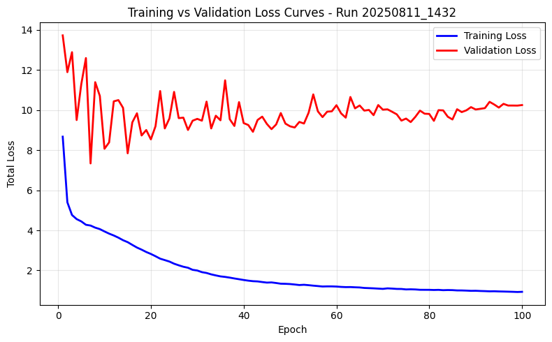

```python
plot_total_loss(str(results_path / 'results.csv'))
```

#### 3.1.2 Dual-Phase, mainstream pre-processing, default parameters

##### 3.1.2.1 Phase I training (freeze modules 0-21)

[Note uses the same data .yaml file as in 3.1.1]

```python
# Load the model
model = YOLO('yolov8n.pt')
```

```python
# Create a timestamp for the training run
timestamp = datetime.now().strftime('%Y%m%d_%H%M')

# Train the model
results1 = model.train(
    data=str(yaml_path),
    epochs=10,
    batch=16,
    imgsz=640,
    freeze=22,  # freeze modules 0-21; trains only Detect (module 22)
    plots=True,
    project=RUNS_DIR / 'train_png_no_aug',
    name=timestamp,

    # Augmentation parameters (nullified)
    auto_augment=None,
    hsv_h=0.0,
    hsv_s=0.0,
    hsv_v=0.0,
    translate=0.0,
    scale=0.0,
    fliplr=0.0,
    mosaic=0.0
)
```

[output not shown]

[output cut: 117 more lines]

```
Freezing layer 'model.21.cv1.bn.weight'
Freezing layer 'model.21.cv1.bn.bias'
Freezing layer 'model.21.cv2.conv.weight'
Freezing layer 'model.21.cv2.bn.weight'
Freezing layer 'model.21.cv2.bn.bias'
Freezing layer 'model.21.m.0.cv1.conv.weight'
Freezing layer 'model.21.m.0.cv1.bn.weight'
Freezing layer 'model.21.m.0.cv1.bn.bias'
Freezing layer 'model.21.m.0.cv2.conv.weight'
Freezing layer 'model.21.m.0.cv2.bn.weight'
Freezing layer 'model.21.m.0.cv2.bn.bias'
Freezing layer 'model.22.dfl.conv.weight'
AMP: running Automatic Mixed Precision (AMP) checks...
AMP: checks passed ✅
train: Fast image access ✅ (ping: 0.0±0.0 ms, read: 101.0±13.1 MB/s, size: 26.7 KB)
```

```
train: Scanning /home/peterm/UWA/CITS5014/SARFish/modelling/data/train/labels.cache... 3114 images, 0 backgrounds, 0 cor
```

```
albumentations: Blur(p=0.01, blur_limit=(3, 7)), MedianBlur(p=0.01, blur_limit=(3, 7)), ToGray(p=0.01, method='weighted_average', num_output_channels=3), CLAHE(p=0.01, clip_limit=(1.0, 4.0), tile_grid_size=(8, 8))
val: Fast image access ✅ (ping: 0.0±0.0 ms, read: 64.7±11.1 MB/s, size: 25.6 KB)
```

```
val: Scanning /home/peterm/UWA/CITS5014/SARFish/modelling/data/val/labels.cache... 463 images, 0 backgrounds, 0 corrupt:
```

[output not shown]

```
       1/10     0.746G       2.64      5.215       2.26         10        640: 100%|██████████| 195/195 [00:18<00:00, 10
                 Class     Images  Instances      Box(P          R      mAP50  mAP50-95): 100%|██████████| 15/15 [00:03<
```

```
                   all        463        463      0.565      0.201      0.079     0.0177

      Epoch    GPU_mem   box_loss   cls_loss   dfl_loss  Instances       Size
```

```
       2/10      1.14G      2.065      3.219      1.658         10        640: 100%|██████████| 195/195 [00:16<00:00, 11
                 Class     Images  Instances      Box(P          R      mAP50  mAP50-95): 100%|██████████| 15/15 [00:03<
```

```
                   all        463        463      0.554      0.178     0.0568     0.0188
```

```
      Epoch    GPU_mem   box_loss   cls_loss   dfl_loss  Instances       Size
```

```
       3/10      1.15G      1.953      2.573       1.58         10        640: 100%|██████████| 195/195 [00:21<00:00,  8
                 Class     Images  Instances      Box(P          R      mAP50  mAP50-95): 100%|██████████| 15/15 [00:04<
```

```
                   all        463        463      0.192      0.413     0.0716     0.0226

      Epoch    GPU_mem   box_loss   cls_loss   dfl_loss  Instances       Size
```

```
       4/10      1.16G      1.886      2.335      1.534         10        640: 100%|██████████| 195/195 [00:20<00:00,  9
                 Class     Images  Instances      Box(P          R      mAP50  mAP50-95): 100%|██████████| 15/15 [00:03<
```

```
                   all        463        463      0.279      0.386     0.0919     0.0256
```

```
      Epoch    GPU_mem   box_loss   cls_loss   dfl_loss  Instances       Size
```

```
       5/10      1.17G      1.821      2.233        1.5         10        640: 100%|██████████| 195/195 [00:19<00:00,  9
                 Class     Images  Instances      Box(P          R      mAP50  mAP50-95): 100%|██████████| 15/15 [00:04<
```

```
                   all        463        463      0.562      0.131      0.041     0.0119

      Epoch    GPU_mem   box_loss   cls_loss   dfl_loss  Instances       Size
```

```
       6/10      1.18G      1.769      2.152      1.472         10        640: 100%|██████████| 195/195 [00:21<00:00,  9
                 Class     Images  Instances      Box(P          R      mAP50  mAP50-95): 100%|██████████| 15/15 [00:04<
```

```
                   all        463        463     0.0409      0.257     0.0665     0.0181

      Epoch    GPU_mem   box_loss   cls_loss   dfl_loss  Instances       Size
```

```
       7/10      1.18G      1.714      2.058      1.434         10        640: 100%|██████████| 195/195 [00:19<00:00,  9
                 Class     Images  Instances      Box(P          R      mAP50  mAP50-95): 100%|██████████| 15/15 [00:03<
```

```
                   all        463        463      0.137      0.378     0.0891     0.0244

      Epoch    GPU_mem   box_loss   cls_loss   dfl_loss  Instances       Size
```

```
       8/10      1.18G      1.668      1.984      1.408         10        640: 100%|██████████| 195/195 [00:20<00:00,  9
                 Class     Images  Instances      Box(P          R      mAP50  mAP50-95): 100%|██████████| 15/15 [00:03<
```

```
                   all        463        463     0.0333     0.0785       0.03    0.00916

      Epoch    GPU_mem   box_loss   cls_loss   dfl_loss  Instances       Size
```

```
       9/10      1.18G      1.594      1.915      1.368         10        640: 100%|██████████| 195/195 [00:20<00:00,  9
                 Class     Images  Instances      Box(P          R      mAP50  mAP50-95): 100%|██████████| 15/15 [00:04<
```

```
                   all        463        463     0.0518      0.127     0.0413     0.0115

      Epoch    GPU_mem   box_loss   cls_loss   dfl_loss  Instances       Size
```

```
      10/10      1.18G      1.549      1.863      1.347         10        640: 100%|██████████| 195/195 [00:20<00:00,  9
                 Class     Images  Instances      Box(P          R      mAP50  mAP50-95): 100%|██████████| 15/15 [00:04<
```

```
                   all        463        463     0.0625      0.136     0.0582      0.018

10 epochs completed in 0.068 hours.
Optimizer stripped from /home/peterm/UWA/CITS5014/SARFish/modelling/runs/train_png_no_aug_20250806_1408/weights/last.pt, 6.2MB
Optimizer stripped from /home/peterm/UWA/CITS5014/SARFish/modelling/runs/train_png_no_aug_20250806_1408/weights/best.pt, 6.2MB

Validating /home/peterm/UWA/CITS5014/SARFish/modelling/runs/train_png_no_aug_20250806_1408/weights/best.pt...
Ultralytics 8.3.152 🚀 Python-3.10.12 torch-2.6.0+cu124 CUDA:0 (NVIDIA RTX 2000 Ada Generation Laptop GPU, 8188MiB)
Model summary (fused): 72 layers, 3,006,038 parameters, 0 gradients, 8.1 GFLOPs
```

```
                 Class     Images  Instances      Box(P          R      mAP50  mAP50-95): 100%|██████████| 15/15 [00:04<
```

```
                   all        463        463      0.273      0.386     0.0919     0.0256
             is_vessel        331        331     0.0722      0.749      0.103     0.0306
            is_fishing        132        132      0.474     0.0227     0.0811     0.0205
Speed: 0.2ms preprocess, 2.2ms inference, 0.0ms loss, 2.3ms postprocess per image
Results saved to /home/peterm/UWA/CITS5014/SARFish/modelling/runs/train_png_no_aug_20250806_1408
```

```python
results_path = RUNS_DIR / 'train_png_no_aug' / '20250806_1408'
```

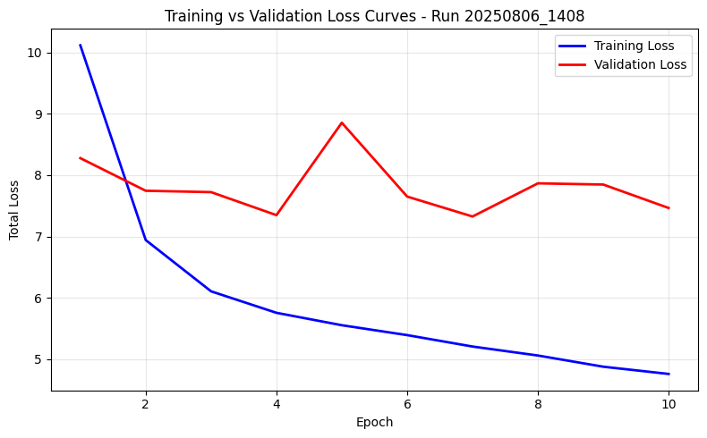

```python
plot_total_loss(str(results_path / 'results.csv'))
```

##### 3.1.2.2 Phase II training (unfreeze modules 17-21)

[Note uses the same data .yaml file as in 3.1.1]

```python
model=YOLO('/home/peterm/UWA/CITS5014/SARFish/modelling/runs/train_png_no_aug_20250806_1408/weights/best.pt')
```

```python
# Create a timestamp for the training run
timestamp = datetime.now().strftime('%Y%m%d_%H%M')

# Train the model
results2 = model.train(
    data=str(yaml_path),
    epochs=100,
    lr0=0.0001,
    warmup_epochs=0,
    optimizer='AdamW',
    weight_decay=0.0005,
    batch=16,
    imgsz=640,
    freeze=17,  # freeze layers 0-16 (~80%)
    plots=True,
    project=RUNS_DIR / 'train_png_no_aug',
    name=timestamp,

    # Augmentation parameters (nullified)
    auto_augment=None,
    hsv_h=0.0,
    hsv_s=0.0,
    hsv_v=0.0,
    translate=0.0,
    scale=0.0,
    fliplr=0.0,
    mosaic=0.0
)
```

[output not shown]

```python
results_path = RUNS_DIR / 'train_png_no_aug' / '20250806_1536'
```

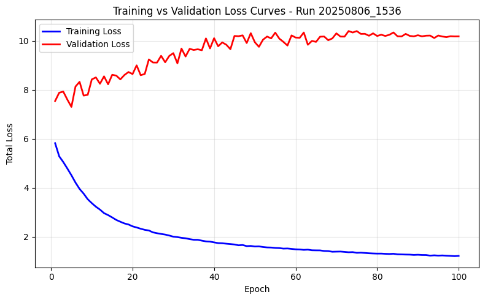

```python
plot_total_loss(str(results_path / 'results.csv'))
```

### 3.2 Single-Phase, in situ augmentation

#### 3.2.1 Mainstream processing, in situ augmentation (hvrt)

Create the data .yaml configuration file:

```python
# Create data configuration
import yaml

data_config = {
    'path':   str(PROJECT_ROOT / 'data'),
    'train':  'train',
    'val':    'val',
    'test':   'test',
    'nc': 2,
    'names':  ['is_vessel', 'is_fishing']
}

# Save to configs directory
yaml_path = CONFIG_DIR / 'sar_data_aug.yaml'
with open(yaml_path, 'w') as f:
    yaml.dump(data_config, f)
```

```python
# Load the model
model = YOLO('yolov8n.pt')
```

```python
# Create a timestamp for the training run
timestamp = datetime.now().strftime('%Y%m%d_%H%M')

# Train the model
results = model.train(
    data=str(yaml_path),
    epochs=100,
    batch=16,
    imgsz=640,
    freeze=None,
    plots=True,
    project=RUNS_DIR / 'train_png_aug',
    name=timestamp,

    # Augmentation parameters
    auto_augment=None,
    hsv_h=0.0,
    hsv_s=0.0,
    hsv_v=0.0,
    translate=0.1,  # transaltion (+/- fraction)
    degrees=15.0,   # rotation (+/- degrees)
    scale=0.0,
    fliplr=0.5,     # horizontal flip (prob)
    flipud=0.5,     # vertical flip (prob.)
    mosaic=0.0
)
```

```
New https://pypi.org/project/ultralytics/8.3.174 available 😃 Update with 'pip install -U ultralytics'
Ultralytics 8.3.152 🚀 Python-3.10.12 torch-2.6.0+cu124 CUDA:0 (NVIDIA RTX 2000 Ada Generation Laptop GPU, 8188MiB)
engine/trainer: agnostic_nms=False, amp=True, augment=False, auto_augment=None, batch=16, bgr=0.0, box=7.5, cache=False, cfg=None, classes=None, close_mosaic=10, cls=0.5, conf=None, copy_paste=0.0, copy_paste_mode=flip, cos_lr=False, cutmix=0.0, data=/home/peterm/UWA/CITS5014/SARFish/modelling/confi…
Overriding model.yaml nc=80 with nc=2

                   from  n    params  module                                       arguments
  0                  -1  1       464  ultralytics.nn.modules.conv.Conv             [3, 16, 3, 2]
  1                  -1  1      4672  ultralytics.nn.modules.conv.Conv             [16, 32, 3, 2]
  2                  -1  1      7360  ultralytics.nn.modules.block.C2f             [32, 32, 1, True]
  3                  -1  1     18560  ultralytics.nn.modules.conv.Conv             [32, 64, 3, 2]
  4                  -1  2     49664  ultralytics.nn.modules.block.C2f             [64, 64, 2, True]
  5                  -1  1     73984  ultralytics.nn.modules.conv.Conv             [64, 128, 3, 2]
  6                  -1  2    197632  ultralytics.nn.modules.block.C2f             [128, 128, 2, True]
  7                  -1  1    295424  ultralytics.nn.modules.conv.Conv             [128, 256, 3, 2]
  8                  -1  1    460288  ultralytics.nn.modules.block.C2f             [256, 256, 1, True]
  9                  -1  1    164608  ultralytics.nn.modules.block.SPPF            [256, 256, 5]
 10                  -1  1         0  torch.nn.modules.upsampling.Upsample         [None, 2, 'nearest']
 11             [-1, 6]  1         0  ultralytics.nn.modules.conv.Concat           [1]
 12                  -1  1    148224  ultralytics.nn.modules.block.C2f             [384, 128, 1]
 13                  -1  1         0  torch.nn.modules.upsampling.Upsample         [None, 2, 'nearest']
 14             [-1, 4]  1         0  ultralytics.nn.modules.conv.Concat           [1]
 15                  -1  1     37248  ultralytics.nn.modules.block.C2f             [192, 64, 1]
 16                  -1  1     36992  ultralytics.nn.modules.conv.Conv             [64, 64, 3, 2]
 17            [-1, 12]  1         0  ultralytics.nn.modules.conv.Concat           [1]
 18                  -1  1    123648  ultralytics.nn.modules.block.C2f             [192, 128, 1]
 19                  -1  1    147712  ultralytics.nn.modules.conv.Conv             [128, 128, 3, 2]
 20             [-1, 9]  1         0  ultralytics.nn.modules.conv.Concat           [1]
 21                  -1  1    493056  ultralytics.nn.modules.block.C2f             [384, 256, 1]
 22        [15, 18, 21]  1    751702  ultralytics.nn.modules.head.Detect           [2, [64, 128, 256]]
Model summary: 129 layers, 3,011,238 parameters, 3,011,222 gradients, 8.2 GFLOPs

Transferred 319/355 items from pretrained weights
TensorBoard: Start with 'tensorboard --logdir /home/peterm/UWA/CITS5014/SARFish/modelling/runs/train_png_aug/20250806_1926', view at http://localhost:6006/
Freezing layer 'model.22.dfl.conv.weight'
AMP: running Automatic Mixed Precision (AMP) checks...
AMP: checks passed ✅
train: Fast image access ✅ (ping: 0.0±0.0 ms, read: 95.8±12.6 MB/s, size: 26.7 KB)
```

```
train: Scanning /home/peterm/UWA/CITS5014/SARFish/modelling/data/train/labels.cache... 3114 images, 0 backgrounds, 0 cor
```

```
albumentations: Blur(p=0.01, blur_limit=(3, 7)), MedianBlur(p=0.01, blur_limit=(3, 7)), ToGray(p=0.01, method='weighted_average', num_output_channels=3), CLAHE(p=0.01, clip_limit=(1.0, 4.0), tile_grid_size=(8, 8))
```

```
val: Fast image access ✅ (ping: 0.0±0.0 ms, read: 42.4±10.3 MB/s, size: 25.6 KB)
```

```
val: Scanning /home/peterm/UWA/CITS5014/SARFish/modelling/data/val/labels.cache... 463 images, 0 backgrounds, 0 corrupt:
```

```
Plotting labels to /home/peterm/UWA/CITS5014/SARFish/modelling/runs/train_png_aug/20250806_1926/labels.jpg...
optimizer: 'optimizer=auto' found, ignoring 'lr0=0.01' and 'momentum=0.937' and determining best 'optimizer', 'lr0' and 'momentum' automatically...
optimizer: AdamW(lr=0.001667, momentum=0.9) with parameter groups 57 weight(decay=0.0), 64 weight(decay=0.0005), 63 bias(decay=0.0)
TensorBoard: model graph visualization added ✅
Image sizes 640 train, 640 val
Using 8 dataloader workers
Logging results to /home/peterm/UWA/CITS5014/SARFish/modelling/runs/train_png_aug/20250806_1926
Starting training for 100 epochs...

      Epoch    GPU_mem   box_loss   cls_loss   dfl_loss  Instances       Size
```

```
      1/100      1.96G      2.235      3.934       2.11         10        640: 100%|██████████| 195/195 [00:31<00:00,  6
                 Class     Images  Instances      Box(P          R      mAP50  mAP50-95): 100%|██████████| 15/15 [00:03<
```

```
                   all        463        463      0.517     0.0181    0.00521    0.00136
```

```
      Epoch    GPU_mem   box_loss   cls_loss   dfl_loss  Instances       Size
```

```
      2/100       2.1G       1.84      2.283      1.707         10        640: 100%|██████████| 195/195 [00:45<00:00,  4
                 Class     Images  Instances      Box(P          R      mAP50  mAP50-95): 100%|██████████| 15/15 [00:06<
```

```
                   all        463        463      0.521     0.0332     0.0106    0.00264

      Epoch    GPU_mem   box_loss   cls_loss   dfl_loss  Instances       Size
```

```
      3/100      2.12G      1.781      1.846      1.653         10        640: 100%|██████████| 195/195 [01:09<00:00,  2
                 Class     Images  Instances      Box(P          R      mAP50  mAP50-95): 100%|██████████| 15/15 [00:05<
```

```
                   all        463        463      0.502     0.0272    0.00069   0.000166

      Epoch    GPU_mem   box_loss   cls_loss   dfl_loss  Instances       Size
```

```
      4/100      2.12G      1.746      1.684      1.634         10        640: 100%|██████████| 195/195 [00:32<00:00,  6
                 Class     Images  Instances      Box(P          R      mAP50  mAP50-95): 100%|██████████| 15/15 [00:04<
```

```
                   all        463        463      0.637      0.168      0.109     0.0284
```

```
      Epoch    GPU_mem   box_loss   cls_loss   dfl_loss  Instances       Size
```

```
      5/100      2.12G      1.657      1.625       1.58         10        640: 100%|██████████| 195/195 [00:33<00:00,  5
                 Class     Images  Instances      Box(P          R      mAP50  mAP50-95): 100%|██████████| 15/15 [00:03<
```

```
                   all        463        463       0.52     0.0498    0.00483    0.00128
```

```
      Epoch    GPU_mem   box_loss   cls_loss   dfl_loss  Instances       Size
```

```
      6/100      2.12G      1.634      1.598      1.564         10        640: 100%|██████████| 195/195 [00:35<00:00,  5
                 Class     Images  Instances      Box(P          R      mAP50  mAP50-95): 100%|██████████| 15/15 [00:05<
```

```
                   all        463        463       0.51     0.0287    0.00253   0.000656
```

```
      Epoch    GPU_mem   box_loss   cls_loss   dfl_loss  Instances       Size
```

```
      7/100      2.13G      1.598      1.573      1.548         10        640: 100%|██████████| 195/195 [01:10<00:00,  2
                 Class     Images  Instances      Box(P          R      mAP50  mAP50-95): 100%|██████████| 15/15 [00:05<
```

```
                   all        463        463      0.234      0.353      0.213     0.0701
```

```
      Epoch    GPU_mem   box_loss   cls_loss   dfl_loss  Instances       Size
```

```
      8/100      2.13G      1.572      1.528      1.526         10        640: 100%|██████████| 195/195 [00:32<00:00,  6
                 Class     Images  Instances      Box(P          R      mAP50  mAP50-95): 100%|██████████| 15/15 [00:04<
```

```
                   all        463        463      0.622     0.0937     0.0695     0.0197
```

```
      Epoch    GPU_mem   box_loss   cls_loss   dfl_loss  Instances       Size
```

```
      9/100      2.16G      1.579      1.524      1.523         10        640: 100%|██████████| 195/195 [00:32<00:00,  5
                 Class     Images  Instances      Box(P          R      mAP50  mAP50-95): 100%|██████████| 15/15 [00:04<
```

```
                   all        463        463      0.516     0.0347    0.00756    0.00145
```

```
      Epoch    GPU_mem   box_loss   cls_loss   dfl_loss  Instances       Size
```

```
     10/100      2.18G      1.545      1.493      1.494         10        640: 100%|██████████| 195/195 [00:33<00:00,  5
                 Class     Images  Instances      Box(P          R      mAP50  mAP50-95): 100%|██████████| 15/15 [00:03<
```

```
                   all        463        463      0.587      0.118     0.0494     0.0112
```

```
      Epoch    GPU_mem   box_loss   cls_loss   dfl_loss  Instances       Size
```

```
     11/100       2.2G      1.546      1.509      1.502         10        640: 100%|██████████| 195/195 [01:01<00:00,  3
                 Class     Images  Instances      Box(P          R      mAP50  mAP50-95): 100%|██████████| 15/15 [00:06<
```

```
                   all        463        463       0.75      0.146       0.15     0.0603
```

```
      Epoch    GPU_mem   box_loss   cls_loss   dfl_loss  Instances       Size
```

```
     12/100       2.2G      1.523      1.473      1.491         10        640: 100%|██████████| 195/195 [00:47<00:00,  4
                 Class     Images  Instances      Box(P          R      mAP50  mAP50-95): 100%|██████████| 15/15 [00:04<
```

```
                   all        463        463      0.587     0.0634     0.0361    0.00957
```

```
      Epoch    GPU_mem   box_loss   cls_loss   dfl_loss  Instances       Size
```

```
     13/100       2.2G      1.511      1.465      1.478         10        640: 100%|██████████| 195/195 [00:33<00:00,  5
                 Class     Images  Instances      Box(P          R      mAP50  mAP50-95): 100%|██████████| 15/15 [00:03<
```

```
                   all        463        463      0.621     0.0816     0.0786     0.0283
```

```
      Epoch    GPU_mem   box_loss   cls_loss   dfl_loss  Instances       Size
```

```
     14/100       2.2G      1.504      1.466      1.485         10        640: 100%|██████████| 195/195 [00:32<00:00,  6
                 Class     Images  Instances      Box(P          R      mAP50  mAP50-95): 100%|██████████| 15/15 [00:03<
```

```
                   all        463        463      0.722       0.13      0.166     0.0509
```

```
      Epoch    GPU_mem   box_loss   cls_loss   dfl_loss  Instances       Size
```

```
     15/100       2.2G      1.494      1.445      1.474         10        640: 100%|██████████| 195/195 [00:45<00:00,  4
                 Class     Images  Instances      Box(P          R      mAP50  mAP50-95): 100%|██████████| 15/15 [00:05<
```

```
                   all        463        463      0.558     0.0755     0.0611      0.019
```

```
      Epoch    GPU_mem   box_loss   cls_loss   dfl_loss  Instances       Size
```

```
     16/100       2.2G      1.466      1.433      1.463         10        640: 100%|██████████| 195/195 [01:09<00:00,  2
                 Class     Images  Instances      Box(P          R      mAP50  mAP50-95): 100%|██████████| 15/15 [00:04<
```

```
                   all        463        463       0.55      0.107     0.0679     0.0178
```

```
      Epoch    GPU_mem   box_loss   cls_loss   dfl_loss  Instances       Size
```

```
     17/100       2.2G      1.459      1.434      1.445         10        640: 100%|██████████| 195/195 [00:32<00:00,  5
                 Class     Images  Instances      Box(P          R      mAP50  mAP50-95): 100%|██████████| 15/15 [00:04<
```

```
                   all        463        463       0.27       0.32      0.243     0.0894
```

```
      Epoch    GPU_mem   box_loss   cls_loss   dfl_loss  Instances       Size
```

```
     18/100       2.2G      1.463      1.444       1.46         10        640: 100%|██████████| 195/195 [00:32<00:00,  6
                 Class     Images  Instances      Box(P          R      mAP50  mAP50-95): 100%|██████████| 15/15 [00:03<
```

```
                   all        463        463     0.0553      0.524      0.084     0.0289
```

```
      Epoch    GPU_mem   box_loss   cls_loss   dfl_loss  Instances       Size
```

```
     19/100       2.2G      1.457      1.423      1.459         10        640: 100%|██████████| 195/195 [00:35<00:00,  5
                 Class     Images  Instances      Box(P          R      mAP50  mAP50-95): 100%|██████████| 15/15 [00:05<
```

```
                   all        463        463      0.205      0.391      0.211     0.0687
```

```
      Epoch    GPU_mem   box_loss   cls_loss   dfl_loss  Instances       Size
```

```
     20/100       2.2G      1.462      1.415      1.465         10        640: 100%|██████████| 195/195 [01:09<00:00,  2
                 Class     Images  Instances      Box(P          R      mAP50  mAP50-95): 100%|██████████| 15/15 [00:05<
```

```
                   all        463        463      0.744      0.158      0.215     0.0739
```

```
      Epoch    GPU_mem   box_loss   cls_loss   dfl_loss  Instances       Size
```

```
     21/100       2.2G      1.437        1.4      1.437         10        640: 100%|██████████| 195/195 [00:32<00:00,  5
                 Class     Images  Instances      Box(P          R      mAP50  mAP50-95): 100%|██████████| 15/15 [00:04<
```

```
                   all        463        463      0.177      0.362      0.158     0.0517
```

```
      Epoch    GPU_mem   box_loss   cls_loss   dfl_loss  Instances       Size
```

```
     22/100       2.2G      1.447      1.407      1.447         10        640: 100%|██████████| 195/195 [00:32<00:00,  5
                 Class     Images  Instances      Box(P          R      mAP50  mAP50-95): 100%|██████████| 15/15 [00:04<
```

```
                   all        463        463      0.706      0.142      0.164     0.0559
```

```
      Epoch    GPU_mem   box_loss   cls_loss   dfl_loss  Instances       Size
```

```
     23/100       2.2G      1.437      1.403      1.438         10        640: 100%|██████████| 195/195 [00:33<00:00,  5
                 Class     Images  Instances      Box(P          R      mAP50  mAP50-95): 100%|██████████| 15/15 [00:03<
```

```
                   all        463        463      0.811      0.153      0.192     0.0827
```

```
      Epoch    GPU_mem   box_loss   cls_loss   dfl_loss  Instances       Size
```

```
     24/100       2.2G      1.441      1.396      1.442         10        640: 100%|██████████| 195/195 [00:53<00:00,  3
                 Class     Images  Instances      Box(P          R      mAP50  mAP50-95): 100%|██████████| 15/15 [00:05<
```

```
                   all        463        463      0.761      0.289      0.315      0.128
```

```
      Epoch    GPU_mem   box_loss   cls_loss   dfl_loss  Instances       Size
```

```
     25/100       2.2G      1.415      1.385      1.426         10        640: 100%|██████████| 195/195 [00:55<00:00,  3
                 Class     Images  Instances      Box(P          R      mAP50  mAP50-95): 100%|██████████| 15/15 [00:03<
```

```
                   all        463        463      0.774      0.183       0.18     0.0726
```

```
      Epoch    GPU_mem   box_loss   cls_loss   dfl_loss  Instances       Size
```

```
     26/100       2.2G      1.412      1.375      1.425         10        640: 100%|██████████| 195/195 [00:33<00:00,  5
                 Class     Images  Instances      Box(P          R      mAP50  mAP50-95): 100%|██████████| 15/15 [00:03<
```

```
                   all        463        463      0.211      0.298      0.194     0.0596
```

```
      Epoch    GPU_mem   box_loss   cls_loss   dfl_loss  Instances       Size
```

```
     27/100       2.2G      1.415      1.376      1.419         10        640: 100%|██████████| 195/195 [00:31<00:00,  6
                 Class     Images  Instances      Box(P          R      mAP50  mAP50-95): 100%|██████████| 15/15 [00:03<
```

```
                   all        463        463      0.271      0.406      0.286     0.0882
```

```
      Epoch    GPU_mem   box_loss   cls_loss   dfl_loss  Instances       Size
```

```
     28/100       2.2G      1.409       1.38      1.419         10        640: 100%|██████████| 195/195 [00:47<00:00,  4
                 Class     Images  Instances      Box(P          R      mAP50  mAP50-95): 100%|██████████| 15/15 [00:06<
```

```
                   all        463        463      0.704     0.0612     0.0678     0.0183
```

```
      Epoch    GPU_mem   box_loss   cls_loss   dfl_loss  Instances       Size
```

```
     29/100       2.2G      1.401      1.377      1.421         10        640: 100%|██████████| 195/195 [01:06<00:00,  2
                 Class     Images  Instances      Box(P          R      mAP50  mAP50-95): 100%|██████████| 15/15 [00:04<
```

```
                   all        463        463      0.752      0.213      0.271      0.107
```

```
      Epoch    GPU_mem   box_loss   cls_loss   dfl_loss  Instances       Size
```

```
     30/100       2.2G      1.395      1.375      1.407         10        640: 100%|██████████| 195/195 [00:31<00:00,  6
                 Class     Images  Instances      Box(P          R      mAP50  mAP50-95): 100%|██████████| 15/15 [00:03<
```

```
                   all        463        463      0.789      0.134      0.233     0.0898
```

```
      Epoch    GPU_mem   box_loss   cls_loss   dfl_loss  Instances       Size
```

```
     31/100       2.2G      1.393      1.365      1.405         10        640: 100%|██████████| 195/195 [00:33<00:00,  5
                 Class     Images  Instances      Box(P          R      mAP50  mAP50-95): 100%|██████████| 15/15 [00:04<
```

```
                   all        463        463      0.807      0.112       0.16     0.0707
```

```
      Epoch    GPU_mem   box_loss   cls_loss   dfl_loss  Instances       Size
```

```
     32/100       2.2G      1.392      1.366      1.412         10        640: 100%|██████████| 195/195 [00:31<00:00,  6
                 Class     Images  Instances      Box(P          R      mAP50  mAP50-95): 100%|██████████| 15/15 [00:04<
```

```
                   all        463        463       0.79      0.264      0.349      0.158
```

```
      Epoch    GPU_mem   box_loss   cls_loss   dfl_loss  Instances       Size
```

```
     33/100       2.2G      1.385      1.364      1.401         10        640: 100%|██████████| 195/195 [00:50<00:00,  3
                 Class     Images  Instances      Box(P          R      mAP50  mAP50-95): 100%|██████████| 15/15 [00:06<
```

```
                   all        463        463      0.303      0.414      0.348      0.146
```

```
      Epoch    GPU_mem   box_loss   cls_loss   dfl_loss  Instances       Size
```

```
     34/100       2.2G      1.376      1.358      1.401         10        640: 100%|██████████| 195/195 [01:10<00:00,  2
                 Class     Images  Instances      Box(P          R      mAP50  mAP50-95): 100%|██████████| 15/15 [00:04<
```

```
                   all        463        463      0.724      0.131      0.182     0.0803
```

```
      Epoch    GPU_mem   box_loss   cls_loss   dfl_loss  Instances       Size
```

```
     35/100       2.2G      1.383      1.349      1.414         10        640: 100%|██████████| 195/195 [00:31<00:00,  6
                 Class     Images  Instances      Box(P          R      mAP50  mAP50-95): 100%|██████████| 15/15 [00:03<
```

```
                   all        463        463      0.272      0.394      0.285       0.11
```

```
      Epoch    GPU_mem   box_loss   cls_loss   dfl_loss  Instances       Size
```

```
     36/100       2.2G      1.381       1.35      1.403         10        640: 100%|██████████| 195/195 [00:32<00:00,  6
                 Class     Images  Instances      Box(P          R      mAP50  mAP50-95): 100%|██████████| 15/15 [00:03<
```

```
                   all        463        463      0.241      0.319      0.278     0.0993
```

```
      Epoch    GPU_mem   box_loss   cls_loss   dfl_loss  Instances       Size
```

```
     37/100       2.2G      1.382      1.335      1.409         10        640: 100%|██████████| 195/195 [00:31<00:00,  6
                 Class     Images  Instances      Box(P          R      mAP50  mAP50-95): 100%|██████████| 15/15 [00:04<
```

```
                   all        463        463      0.265       0.52       0.32      0.113
```

```
      Epoch    GPU_mem   box_loss   cls_loss   dfl_loss  Instances       Size
```

```
     38/100       2.2G      1.372      1.334      1.408         10        640: 100%|██████████| 195/195 [00:44<00:00,  4
                 Class     Images  Instances      Box(P          R      mAP50  mAP50-95): 100%|██████████| 15/15 [00:05<
```

```
                   all        463        463      0.213      0.278      0.173     0.0629
```

```
      Epoch    GPU_mem   box_loss   cls_loss   dfl_loss  Instances       Size
```

```
     39/100       2.2G      1.368      1.336      1.395         10        640: 100%|██████████| 195/195 [01:09<00:00,  2
                 Class     Images  Instances      Box(P          R      mAP50  mAP50-95): 100%|██████████| 15/15 [00:05<
```

```
                   all        463        463       0.66      0.182      0.181     0.0616
```

```
      Epoch    GPU_mem   box_loss   cls_loss   dfl_loss  Instances       Size
```

```
     40/100       2.2G      1.359      1.337      1.382         10        640: 100%|██████████| 195/195 [00:31<00:00,  6
                 Class     Images  Instances      Box(P          R      mAP50  mAP50-95): 100%|██████████| 15/15 [00:03<
```

```
                   all        463        463      0.618      0.281      0.215     0.0726
```

```
      Epoch    GPU_mem   box_loss   cls_loss   dfl_loss  Instances       Size
```

```
     41/100       2.2G       1.35       1.33      1.381         10        640: 100%|██████████| 195/195 [00:33<00:00,  5
                 Class     Images  Instances      Box(P          R      mAP50  mAP50-95): 100%|██████████| 15/15 [00:03<
```

```
                   all        463        463      0.726      0.115      0.181     0.0653
```

```
      Epoch    GPU_mem   box_loss   cls_loss   dfl_loss  Instances       Size
```

```
     42/100       2.2G      1.358      1.331      1.385         10        640: 100%|██████████| 195/195 [00:33<00:00,  5
                 Class     Images  Instances      Box(P          R      mAP50  mAP50-95): 100%|██████████| 15/15 [00:06<
```

```
                   all        463        463      0.836      0.258      0.354      0.149
```

```
      Epoch    GPU_mem   box_loss   cls_loss   dfl_loss  Instances       Size
```

```
     43/100       2.2G      1.352      1.329      1.379         10        640: 100%|██████████| 195/195 [01:10<00:00,  2
                 Class     Images  Instances      Box(P          R      mAP50  mAP50-95): 100%|██████████| 15/15 [00:06<
```

```
                   all        463        463      0.802      0.181       0.27     0.0971
```

```
      Epoch    GPU_mem   box_loss   cls_loss   dfl_loss  Instances       Size
```

```
     44/100       2.2G      1.333      1.325      1.374         10        640: 100%|██████████| 195/195 [01:09<00:00,  2
                 Class     Images  Instances      Box(P          R      mAP50  mAP50-95): 100%|██████████| 15/15 [00:04<
```

```
                   all        463        463      0.332      0.451       0.37      0.134
```

```
      Epoch    GPU_mem   box_loss   cls_loss   dfl_loss  Instances       Size
```

```
     45/100       2.2G      1.343      1.327      1.384         10        640: 100%|██████████| 195/195 [00:32<00:00,  6
                 Class     Images  Instances      Box(P          R      mAP50  mAP50-95): 100%|██████████| 15/15 [00:03<
```

```
                   all        463        463      0.355      0.538      0.438      0.172
```

```
      Epoch    GPU_mem   box_loss   cls_loss   dfl_loss  Instances       Size
```

```
     46/100       2.2G       1.35      1.314      1.377         10        640: 100%|██████████| 195/195 [00:32<00:00,  5
                 Class     Images  Instances      Box(P          R      mAP50  mAP50-95): 100%|██████████| 15/15 [00:03<
```

```
                   all        463        463      0.334      0.478       0.37       0.14
```

```
      Epoch    GPU_mem   box_loss   cls_loss   dfl_loss  Instances       Size
```

```
     47/100       2.2G      1.345       1.32      1.383         10        640: 100%|██████████| 195/195 [00:58<00:00,  3
                 Class     Images  Instances      Box(P          R      mAP50  mAP50-95): 100%|██████████| 15/15 [00:06<
```

```
                   all        463        463      0.384      0.377      0.368      0.162
```

```
      Epoch    GPU_mem   box_loss   cls_loss   dfl_loss  Instances       Size
```

```
     48/100       2.2G      1.334      1.317      1.377         10        640: 100%|██████████| 195/195 [01:10<00:00,  2
                 Class     Images  Instances      Box(P          R      mAP50  mAP50-95): 100%|██████████| 15/15 [00:06<
```

```
                   all        463        463       0.33      0.486       0.39      0.164
```

```
      Epoch    GPU_mem   box_loss   cls_loss   dfl_loss  Instances       Size
```

```
     49/100       2.2G      1.339      1.306      1.373         10        640: 100%|██████████| 195/195 [01:09<00:00,  2
                 Class     Images  Instances      Box(P          R      mAP50  mAP50-95): 100%|██████████| 15/15 [00:05<
```

```
                   all        463        463       0.21      0.451      0.256      0.106
```

```
      Epoch    GPU_mem   box_loss   cls_loss   dfl_loss  Instances       Size
```

```
     50/100       2.2G      1.325      1.306      1.366         10        640: 100%|██████████| 195/195 [00:34<00:00,  5
                 Class     Images  Instances      Box(P          R      mAP50  mAP50-95): 100%|██████████| 15/15 [00:04<
```

```
                   all        463        463      0.684       0.24      0.259      0.107
```

```
      Epoch    GPU_mem   box_loss   cls_loss   dfl_loss  Instances       Size
```

```
     51/100       2.2G      1.323        1.3      1.372         10        640: 100%|██████████| 195/195 [00:34<00:00,  5
                 Class     Images  Instances      Box(P          R      mAP50  mAP50-95): 100%|██████████| 15/15 [00:06<
```

```
                   all        463        463      0.292      0.397      0.357      0.148
```

```
      Epoch    GPU_mem   box_loss   cls_loss   dfl_loss  Instances       Size
```

```
     52/100       2.2G      1.333      1.303      1.374         10        640: 100%|██████████| 195/195 [01:10<00:00,  2
                 Class     Images  Instances      Box(P          R      mAP50  mAP50-95): 100%|██████████| 15/15 [00:05<
```

```
                   all        463        463      0.283      0.459      0.342      0.142
```

```
      Epoch    GPU_mem   box_loss   cls_loss   dfl_loss  Instances       Size
```

```
     53/100       2.2G      1.319      1.289      1.364         10        640: 100%|██████████| 195/195 [01:10<00:00,  2
                 Class     Images  Instances      Box(P          R      mAP50  mAP50-95): 100%|██████████| 15/15 [00:05<
```

```
                   all        463        463      0.128      0.479       0.24      0.115
```

```
      Epoch    GPU_mem   box_loss   cls_loss   dfl_loss  Instances       Size
```

```
     54/100       2.2G       1.33      1.297      1.373         10        640: 100%|██████████| 195/195 [01:11<00:00,  2
                 Class     Images  Instances      Box(P          R      mAP50  mAP50-95): 100%|██████████| 15/15 [00:05<
```

```
                   all        463        463      0.164      0.378      0.258      0.111
```

```
      Epoch    GPU_mem   box_loss   cls_loss   dfl_loss  Instances       Size
```

```
     55/100       2.2G      1.311      1.292      1.356         10        640: 100%|██████████| 195/195 [01:10<00:00,  2
                 Class     Images  Instances      Box(P          R      mAP50  mAP50-95): 100%|██████████| 15/15 [00:06<
```

```
                   all        463        463      0.896      0.162      0.282       0.12
```

```
      Epoch    GPU_mem   box_loss   cls_loss   dfl_loss  Instances       Size
```

```
     56/100       2.2G      1.315      1.297      1.356         10        640: 100%|██████████| 195/195 [00:35<00:00,  5
                 Class     Images  Instances      Box(P          R      mAP50  mAP50-95): 100%|██████████| 15/15 [00:03<
```

```
                   all        463        463      0.329       0.54      0.395      0.167
```

```
      Epoch    GPU_mem   box_loss   cls_loss   dfl_loss  Instances       Size
```

```
     57/100       2.2G       1.31      1.287      1.359         10        640: 100%|██████████| 195/195 [00:37<00:00,  5
                 Class     Images  Instances      Box(P          R      mAP50  mAP50-95): 100%|██████████| 15/15 [00:06<
```

```
                   all        463        463      0.827      0.234      0.338      0.136
```

```
      Epoch    GPU_mem   box_loss   cls_loss   dfl_loss  Instances       Size
```

```
     58/100       2.2G      1.298      1.278      1.349         10        640: 100%|██████████| 195/195 [01:10<00:00,  2
                 Class     Images  Instances      Box(P          R      mAP50  mAP50-95): 100%|██████████| 15/15 [00:05<
```

```
                   all        463        463      0.323      0.478      0.392       0.16
```

```
      Epoch    GPU_mem   box_loss   cls_loss   dfl_loss  Instances       Size
```

```
     59/100       2.2G      1.313      1.287      1.351         10        640: 100%|██████████| 195/195 [01:09<00:00,  2
                 Class     Images  Instances      Box(P          R      mAP50  mAP50-95): 100%|██████████| 15/15 [00:06<
```

```
                   all        463        463      0.267      0.425      0.351      0.143
```

```
      Epoch    GPU_mem   box_loss   cls_loss   dfl_loss  Instances       Size
```

```
     60/100       2.2G      1.303      1.286      1.348         10        640: 100%|██████████| 195/195 [01:09<00:00,  2
                 Class     Images  Instances      Box(P          R      mAP50  mAP50-95): 100%|██████████| 15/15 [00:05<
```

```
                   all        463        463      0.216      0.359      0.311      0.128
```

```
      Epoch    GPU_mem   box_loss   cls_loss   dfl_loss  Instances       Size
```

```
     61/100       2.2G      1.305      1.262       1.35         10        640: 100%|██████████| 195/195 [00:32<00:00,  6
                 Class     Images  Instances      Box(P          R      mAP50  mAP50-95): 100%|██████████| 15/15 [00:03<
```

```
                   all        463        463      0.262      0.376      0.306      0.108
```

```
      Epoch    GPU_mem   box_loss   cls_loss   dfl_loss  Instances       Size
```

```
     62/100       2.2G      1.298      1.268       1.35         10        640: 100%|██████████| 195/195 [00:32<00:00,  6
                 Class     Images  Instances      Box(P          R      mAP50  mAP50-95): 100%|██████████| 15/15 [00:03<
```

```
                   all        463        463      0.266      0.322      0.305      0.131
```

```
      Epoch    GPU_mem   box_loss   cls_loss   dfl_loss  Instances       Size
```

```
     63/100       2.2G      1.292      1.265      1.345         10        640: 100%|██████████| 195/195 [00:54<00:00,  3
                 Class     Images  Instances      Box(P          R      mAP50  mAP50-95): 100%|██████████| 15/15 [00:06<
```

```
                   all        463        463      0.279      0.403      0.345      0.148
```

```
      Epoch    GPU_mem   box_loss   cls_loss   dfl_loss  Instances       Size
```

```
     64/100       2.2G      1.292      1.259      1.343         10        640: 100%|██████████| 195/195 [01:10<00:00,  2
                 Class     Images  Instances      Box(P          R      mAP50  mAP50-95): 100%|██████████| 15/15 [00:05<
```

```
                   all        463        463      0.364      0.455      0.393      0.145
```

```
      Epoch    GPU_mem   box_loss   cls_loss   dfl_loss  Instances       Size
```

```
     65/100       2.2G      1.277      1.254      1.341         10        640: 100%|██████████| 195/195 [01:10<00:00,  2
                 Class     Images  Instances      Box(P          R      mAP50  mAP50-95): 100%|██████████| 15/15 [00:05<
```

```
                   all        463        463      0.802      0.292      0.369      0.159
```

```
      Epoch    GPU_mem   box_loss   cls_loss   dfl_loss  Instances       Size
```

```
     66/100       2.2G       1.29      1.252      1.343         10        640: 100%|██████████| 195/195 [00:34<00:00,  5
                 Class     Images  Instances      Box(P          R      mAP50  mAP50-95): 100%|██████████| 15/15 [00:03<
```

```
                   all        463        463      0.337      0.444      0.378      0.162
```

```
      Epoch    GPU_mem   box_loss   cls_loss   dfl_loss  Instances       Size
```

```
     67/100       2.2G      1.278      1.252      1.332         10        640: 100%|██████████| 195/195 [00:33<00:00,  5
                 Class     Images  Instances      Box(P          R      mAP50  mAP50-95): 100%|██████████| 15/15 [00:04<
```

```
                   all        463        463      0.257       0.38      0.353      0.138
```

```
      Epoch    GPU_mem   box_loss   cls_loss   dfl_loss  Instances       Size
```

```
     68/100       2.2G      1.282      1.242      1.337         10        640: 100%|██████████| 195/195 [00:53<00:00,  3
                 Class     Images  Instances      Box(P          R      mAP50  mAP50-95): 100%|██████████| 15/15 [00:06<
```

```
                   all        463        463      0.366      0.383      0.372      0.135
```

```
      Epoch    GPU_mem   box_loss   cls_loss   dfl_loss  Instances       Size
```

```
     69/100       2.2G      1.276      1.247      1.333         10        640: 100%|██████████| 195/195 [01:09<00:00,  2
                 Class     Images  Instances      Box(P          R      mAP50  mAP50-95): 100%|██████████| 15/15 [00:06<
```

```
                   all        463        463      0.417      0.572      0.461       0.19
```

```
      Epoch    GPU_mem   box_loss   cls_loss   dfl_loss  Instances       Size
```

```
     70/100       2.2G      1.273      1.231      1.335         10        640: 100%|██████████| 195/195 [01:09<00:00,  2
                 Class     Images  Instances      Box(P          R      mAP50  mAP50-95): 100%|██████████| 15/15 [00:05<
```

```
                   all        463        463      0.426      0.472      0.436      0.164
```

```
      Epoch    GPU_mem   box_loss   cls_loss   dfl_loss  Instances       Size
```

```
     71/100       2.2G      1.279      1.233      1.339         10        640: 100%|██████████| 195/195 [00:46<00:00,  4
                 Class     Images  Instances      Box(P          R      mAP50  mAP50-95): 100%|██████████| 15/15 [00:03<
```

```
                   all        463        463       0.32      0.442      0.378      0.144
```

```
      Epoch    GPU_mem   box_loss   cls_loss   dfl_loss  Instances       Size
```

```
     72/100       2.2G      1.275      1.231      1.329         10        640: 100%|██████████| 195/195 [00:34<00:00,  5
                 Class     Images  Instances      Box(P          R      mAP50  mAP50-95): 100%|██████████| 15/15 [00:04<
```

```
                   all        463        463      0.392      0.465      0.408      0.166
```

```
      Epoch    GPU_mem   box_loss   cls_loss   dfl_loss  Instances       Size
```

```
     73/100       2.2G      1.271      1.225       1.33         10        640: 100%|██████████| 195/195 [00:37<00:00,  5
                 Class     Images  Instances      Box(P          R      mAP50  mAP50-95): 100%|██████████| 15/15 [00:06<
```

```
                   all        463        463      0.428      0.563      0.443      0.179
```

```
      Epoch    GPU_mem   box_loss   cls_loss   dfl_loss  Instances       Size
```

```
     74/100       2.2G      1.262      1.218      1.325         10        640: 100%|██████████| 195/195 [01:10<00:00,  2
                 Class     Images  Instances      Box(P          R      mAP50  mAP50-95): 100%|██████████| 15/15 [00:05<
```

```
                   all        463        463      0.386      0.455      0.404      0.171
```

```
      Epoch    GPU_mem   box_loss   cls_loss   dfl_loss  Instances       Size
```

```
     75/100       2.2G       1.25      1.219       1.32         10        640: 100%|██████████| 195/195 [01:09<00:00,  2
                 Class     Images  Instances      Box(P          R      mAP50  mAP50-95): 100%|██████████| 15/15 [00:05<
```

```
                   all        463        463      0.359      0.539      0.419      0.162
```

```
      Epoch    GPU_mem   box_loss   cls_loss   dfl_loss  Instances       Size
```

```
     76/100       2.2G      1.251      1.219      1.327         10        640: 100%|██████████| 195/195 [01:10<00:00,  2
                 Class     Images  Instances      Box(P          R      mAP50  mAP50-95): 100%|██████████| 15/15 [00:05<
```

```
                   all        463        463      0.309      0.512       0.39      0.164
```

```
      Epoch    GPU_mem   box_loss   cls_loss   dfl_loss  Instances       Size
```

```
     77/100       2.2G      1.256      1.207      1.323         10        640: 100%|██████████| 195/195 [01:09<00:00,  2
                 Class     Images  Instances      Box(P          R      mAP50  mAP50-95): 100%|██████████| 15/15 [00:04<
```

```
                   all        463        463      0.321      0.422      0.371      0.165
```

```
      Epoch    GPU_mem   box_loss   cls_loss   dfl_loss  Instances       Size
```

```
     78/100       2.2G      1.253      1.204      1.319         10        640: 100%|██████████| 195/195 [00:34<00:00,  5
                 Class     Images  Instances      Box(P          R      mAP50  mAP50-95): 100%|██████████| 15/15 [00:03<
```

```
                   all        463        463      0.356      0.384      0.378      0.166
```

```
      Epoch    GPU_mem   box_loss   cls_loss   dfl_loss  Instances       Size
```

```
     79/100       2.2G      1.245      1.205      1.315         10        640: 100%|██████████| 195/195 [00:37<00:00,  5
                 Class     Images  Instances      Box(P          R      mAP50  mAP50-95): 100%|██████████| 15/15 [00:06<
```

```
                   all        463        463      0.363      0.444      0.381      0.155
```

```
      Epoch    GPU_mem   box_loss   cls_loss   dfl_loss  Instances       Size
```

```
     80/100       2.2G      1.244      1.196      1.315         10        640: 100%|██████████| 195/195 [01:11<00:00,  2
                 Class     Images  Instances      Box(P          R      mAP50  mAP50-95): 100%|██████████| 15/15 [00:05<
```

```
                   all        463        463        0.3      0.341      0.377      0.161
```

```
      Epoch    GPU_mem   box_loss   cls_loss   dfl_loss  Instances       Size
```

```
     81/100       2.2G      1.237      1.191      1.309         10        640: 100%|██████████| 195/195 [01:10<00:00,  2
                 Class     Images  Instances      Box(P          R      mAP50  mAP50-95): 100%|██████████| 15/15 [00:06<
```

```
                   all        463        463      0.294      0.461      0.405       0.17
```

```
      Epoch    GPU_mem   box_loss   cls_loss   dfl_loss  Instances       Size
```

```
     82/100       2.2G      1.239      1.181      1.315         10        640: 100%|██████████| 195/195 [01:09<00:00,  2
                 Class     Images  Instances      Box(P          R      mAP50  mAP50-95): 100%|██████████| 15/15 [00:04<
```

```
                   all        463        463      0.378      0.506      0.435      0.166
```

```
      Epoch    GPU_mem   box_loss   cls_loss   dfl_loss  Instances       Size
```

```
     83/100       2.2G      1.237      1.185      1.313         10        640: 100%|██████████| 195/195 [00:34<00:00,  5
                 Class     Images  Instances      Box(P          R      mAP50  mAP50-95): 100%|██████████| 15/15 [00:04<
```

```
                   all        463        463      0.361      0.433       0.37      0.144
```

```
      Epoch    GPU_mem   box_loss   cls_loss   dfl_loss  Instances       Size
```

```
     84/100       2.2G      1.244      1.195      1.318         10        640: 100%|██████████| 195/195 [00:38<00:00,  5
                 Class     Images  Instances      Box(P          R      mAP50  mAP50-95): 100%|██████████| 15/15 [00:04<
```

```
                   all        463        463      0.326      0.518      0.409      0.182
```

```
      Epoch    GPU_mem   box_loss   cls_loss   dfl_loss  Instances       Size
```

```
     85/100       2.2G      1.229      1.178      1.314         10        640: 100%|██████████| 195/195 [00:55<00:00,  3
                 Class     Images  Instances      Box(P          R      mAP50  mAP50-95): 100%|██████████| 15/15 [00:05<
```

```
                   all        463        463      0.337      0.512      0.422      0.183
```

```
      Epoch    GPU_mem   box_loss   cls_loss   dfl_loss  Instances       Size
```

```
     86/100       2.2G      1.221       1.17      1.304         10        640: 100%|██████████| 195/195 [01:10<00:00,  2
                 Class     Images  Instances      Box(P          R      mAP50  mAP50-95): 100%|██████████| 15/15 [00:05<
```

```
                   all        463        463      0.347      0.539      0.441      0.191
```

```
      Epoch    GPU_mem   box_loss   cls_loss   dfl_loss  Instances       Size
```

```
     87/100       2.2G      1.219      1.165      1.306         10        640: 100%|██████████| 195/195 [01:10<00:00,  2
                 Class     Images  Instances      Box(P          R      mAP50  mAP50-95): 100%|██████████| 15/15 [00:05<
```

```
                   all        463        463      0.338        0.5      0.432      0.183
```

```
      Epoch    GPU_mem   box_loss   cls_loss   dfl_loss  Instances       Size
```

```
     88/100       2.2G      1.228      1.164      1.304         10        640: 100%|██████████| 195/195 [00:32<00:00,  5
                 Class     Images  Instances      Box(P          R      mAP50  mAP50-95): 100%|██████████| 15/15 [00:03<
```

```
                   all        463        463      0.349      0.525      0.436      0.182
```

```
      Epoch    GPU_mem   box_loss   cls_loss   dfl_loss  Instances       Size
```

```
     89/100       2.2G      1.214      1.163        1.3         10        640: 100%|██████████| 195/195 [00:38<00:00,  5
                 Class     Images  Instances      Box(P          R      mAP50  mAP50-95): 100%|██████████| 15/15 [00:06<
```

```
                   all        463        463      0.352      0.484      0.427      0.174
```

```
      Epoch    GPU_mem   box_loss   cls_loss   dfl_loss  Instances       Size
```

```
     90/100       2.2G      1.214       1.16      1.295         10        640: 100%|██████████| 195/195 [01:10<00:00,  2
                 Class     Images  Instances      Box(P          R      mAP50  mAP50-95): 100%|██████████| 15/15 [00:05<
```

```
                   all        463        463      0.327      0.464      0.411      0.167
```

```
Closing dataloader mosaic
albumentations: Blur(p=0.01, blur_limit=(3, 7)), MedianBlur(p=0.01, blur_limit=(3, 7)), ToGray(p=0.01, method='weighted_average', num_output_channels=3), CLAHE(p=0.01, clip_limit=(1.0, 4.0), tile_grid_size=(8, 8))

      Epoch    GPU_mem   box_loss   cls_loss   dfl_loss  Instances       Size
```

```
     91/100       2.2G      1.212       1.15      1.294         10        640: 100%|██████████| 195/195 [01:10<00:00,  2
                 Class     Images  Instances      Box(P          R      mAP50  mAP50-95): 100%|██████████| 15/15 [00:06<
```

```
                   all        463        463      0.317      0.456      0.397      0.163
```

```
      Epoch    GPU_mem   box_loss   cls_loss   dfl_loss  Instances       Size
```

```
     92/100       2.2G        1.2      1.145      1.288         10        640: 100%|██████████| 195/195 [00:32<00:00,  5
                 Class     Images  Instances      Box(P          R      mAP50  mAP50-95): 100%|██████████| 15/15 [00:03<
```

```
                   all        463        463      0.291      0.537      0.419      0.175
```

```
      Epoch    GPU_mem   box_loss   cls_loss   dfl_loss  Instances       Size
```

```
     93/100       2.2G      1.203      1.145      1.289         10        640: 100%|██████████| 195/195 [00:41<00:00,  4
                 Class     Images  Instances      Box(P          R      mAP50  mAP50-95): 100%|██████████| 15/15 [00:05<
```

```
                   all        463        463      0.358      0.573      0.438      0.181
```

```
      Epoch    GPU_mem   box_loss   cls_loss   dfl_loss  Instances       Size
```

```
     94/100       2.2G      1.201      1.141      1.286         10        640: 100%|██████████| 195/195 [01:11<00:00,  2
                 Class     Images  Instances      Box(P          R      mAP50  mAP50-95): 100%|██████████| 15/15 [00:05<
```

```
                   all        463        463      0.337      0.571      0.445      0.182
```

```
      Epoch    GPU_mem   box_loss   cls_loss   dfl_loss  Instances       Size
```

```
     95/100       2.2G      1.205       1.14       1.29         10        640: 100%|██████████| 195/195 [01:10<00:00,  2
                 Class     Images  Instances      Box(P          R      mAP50  mAP50-95): 100%|██████████| 15/15 [00:06<
```

```
                   all        463        463      0.359      0.508      0.434      0.179
```

```
      Epoch    GPU_mem   box_loss   cls_loss   dfl_loss  Instances       Size
```

```
     96/100       2.2G      1.198      1.131      1.288         10        640: 100%|██████████| 195/195 [01:09<00:00,  2
                 Class     Images  Instances      Box(P          R      mAP50  mAP50-95): 100%|██████████| 15/15 [00:04<
```

```
                   all        463        463      0.363      0.527      0.447      0.188
```

```
      Epoch    GPU_mem   box_loss   cls_loss   dfl_loss  Instances       Size
```

```
     97/100       2.2G      1.197      1.134      1.288         10        640: 100%|██████████| 195/195 [00:33<00:00,  5
                 Class     Images  Instances      Box(P          R      mAP50  mAP50-95): 100%|██████████| 15/15 [00:03<
```

```
                   all        463        463      0.351      0.547      0.439       0.18
```

```
      Epoch    GPU_mem   box_loss   cls_loss   dfl_loss  Instances       Size
```

```
     98/100       2.2G      1.189      1.124      1.281         10        640: 100%|██████████| 195/195 [00:35<00:00,  5
                 Class     Images  Instances      Box(P          R      mAP50  mAP50-95): 100%|██████████| 15/15 [00:03<
```

```
                   all        463        463      0.354       0.55      0.438      0.177
```

```
      Epoch    GPU_mem   box_loss   cls_loss   dfl_loss  Instances       Size
```

```
     99/100       2.2G      1.197      1.124      1.283         10        640: 100%|██████████| 195/195 [00:58<00:00,  3
                 Class     Images  Instances      Box(P          R      mAP50  mAP50-95): 100%|██████████| 15/15 [00:05<
```

```
                   all        463        463      0.342      0.517      0.427      0.176
```

```
      Epoch    GPU_mem   box_loss   cls_loss   dfl_loss  Instances       Size
```

```
    100/100       2.2G      1.187      1.123      1.279         10        640: 100%|██████████| 195/195 [01:10<00:00,  2
                 Class     Images  Instances      Box(P          R      mAP50  mAP50-95): 100%|██████████| 15/15 [00:05<
```

```
                   all        463        463       0.34      0.515      0.421      0.169
```

```
100 epochs completed in 1.537 hours.
Optimizer stripped from /home/peterm/UWA/CITS5014/SARFish/modelling/runs/train_png_aug/20250806_1926/weights/last.pt, 6.3MB
Optimizer stripped from /home/peterm/UWA/CITS5014/SARFish/modelling/runs/train_png_aug/20250806_1926/weights/best.pt, 6.3MB

Validating /home/peterm/UWA/CITS5014/SARFish/modelling/runs/train_png_aug/20250806_1926/weights/best.pt...
Ultralytics 8.3.152 🚀 Python-3.10.12 torch-2.6.0+cu124 CUDA:0 (NVIDIA RTX 2000 Ada Generation Laptop GPU, 8188MiB)
Model summary (fused): 72 layers, 3,006,038 parameters, 0 gradients, 8.1 GFLOPs
```

```
                 Class     Images  Instances      Box(P          R      mAP50  mAP50-95): 100%|██████████| 15/15 [00:06<
```

```
                   all        463        463      0.415      0.575      0.462      0.189
             is_vessel        331        331      0.478      0.785      0.676      0.288
            is_fishing        132        132      0.353      0.364      0.247     0.0907
Speed: 0.3ms preprocess, 3.7ms inference, 0.0ms loss, 2.7ms postprocess per image
Results saved to /home/peterm/UWA/CITS5014/SARFish/modelling/runs/train_png_aug/20250806_1926
```

```python
results_path = RUNS_DIR / 'train_png_aug' / '20250806_1926'
```

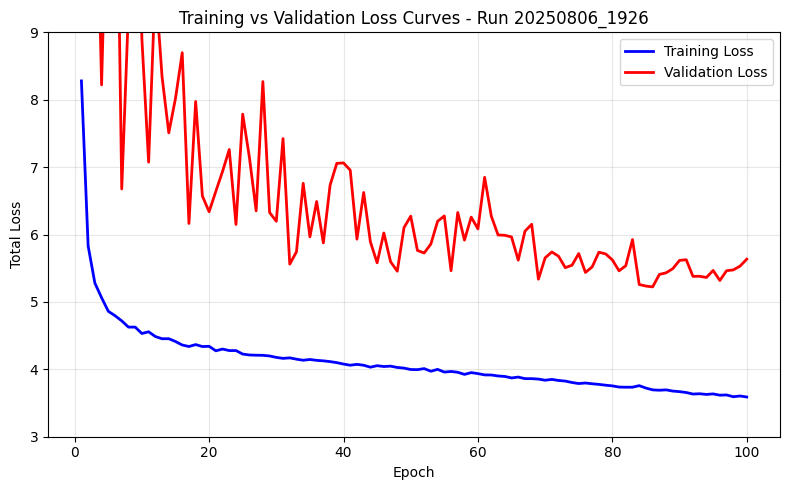

```python
plot_total_loss(str(results_path / 'results.csv'), ylim=(3, 9))
```

#### 3.2.2 Mainstream processing, in situ augmentation (hvrt + mosaic)

Note: Uses same data .yaml file as above ('sar_data_aug.yaml')

```python
# Load the model
model = YOLO('yolov8n.pt')
```

```python
# Create a timestamp for the training run
timestamp = datetime.now().strftime('%Y%m%d_%H%M')

# Train the model
results = model.train(
    data=str(yaml_path),
    epochs=100,
    batch=16,
    imgsz=640,
    freeze=None,
    plots=True,
    project=RUNS_DIR / 'train_png_aug',
    name=timestamp,

    # Augmentation parameters
    auto_augment=None,
    hsv_h=0.0,
    hsv_s=0.0,
    hsv_v=0.0,
    translate=0.1,  # transaltion (+/- fraction)
    degrees=15.0,    # rotation (+/- degrees)
    scale=0.0,
    fliplr=0.5,     # horizontal flip (prob)
    flipud=0.5,     # vertical flip (prob.)
    mosaic=1.0
)
```

```
New https://pypi.org/project/ultralytics/8.3.174 available 😃 Update with 'pip install -U ultralytics'
Ultralytics 8.3.152 🚀 Python-3.10.12 torch-2.6.0+cu124 CUDA:0 (NVIDIA RTX 2000 Ada Generation Laptop GPU, 8188MiB)
engine/trainer: agnostic_nms=False, amp=True, augment=False, auto_augment=None, batch=16, bgr=0.0, box=7.5, cache=False, cfg=None, classes=None, close_mosaic=10, cls=0.5, conf=None, copy_paste=0.0, copy_paste_mode=flip, cos_lr=False, cutmix=0.0, data=/home/peterm/UWA/CITS5014/SARFish/modelling/confi…
Overriding model.yaml nc=80 with nc=2

                   from  n    params  module                                       arguments
  0                  -1  1       464  ultralytics.nn.modules.conv.Conv             [3, 16, 3, 2]
  1                  -1  1      4672  ultralytics.nn.modules.conv.Conv             [16, 32, 3, 2]
  2                  -1  1      7360  ultralytics.nn.modules.block.C2f             [32, 32, 1, True]
  3                  -1  1     18560  ultralytics.nn.modules.conv.Conv             [32, 64, 3, 2]
  4                  -1  2     49664  ultralytics.nn.modules.block.C2f             [64, 64, 2, True]
  5                  -1  1     73984  ultralytics.nn.modules.conv.Conv             [64, 128, 3, 2]
  6                  -1  2    197632  ultralytics.nn.modules.block.C2f             [128, 128, 2, True]
  7                  -1  1    295424  ultralytics.nn.modules.conv.Conv             [128, 256, 3, 2]
  8                  -1  1    460288  ultralytics.nn.modules.block.C2f             [256, 256, 1, True]
  9                  -1  1    164608  ultralytics.nn.modules.block.SPPF            [256, 256, 5]
 10                  -1  1         0  torch.nn.modules.upsampling.Upsample         [None, 2, 'nearest']
 11             [-1, 6]  1         0  ultralytics.nn.modules.conv.Concat           [1]
 12                  -1  1    148224  ultralytics.nn.modules.block.C2f             [384, 128, 1]
 13                  -1  1         0  torch.nn.modules.upsampling.Upsample         [None, 2, 'nearest']
 14             [-1, 4]  1         0  ultralytics.nn.modules.conv.Concat           [1]
 15                  -1  1     37248  ultralytics.nn.modules.block.C2f             [192, 64, 1]
 16                  -1  1     36992  ultralytics.nn.modules.conv.Conv             [64, 64, 3, 2]
 17            [-1, 12]  1         0  ultralytics.nn.modules.conv.Concat           [1]
 18                  -1  1    123648  ultralytics.nn.modules.block.C2f             [192, 128, 1]
 19                  -1  1    147712  ultralytics.nn.modules.conv.Conv             [128, 128, 3, 2]
 20             [-1, 9]  1         0  ultralytics.nn.modules.conv.Concat           [1]
 21                  -1  1    493056  ultralytics.nn.modules.block.C2f             [384, 256, 1]
 22        [15, 18, 21]  1    751702  ultralytics.nn.modules.head.Detect           [2, [64, 128, 256]]
Model summary: 129 layers, 3,011,238 parameters, 3,011,222 gradients, 8.2 GFLOPs

Transferred 319/355 items from pretrained weights
TensorBoard: Start with 'tensorboard --logdir /home/peterm/UWA/CITS5014/SARFish/modelling/runs/train_png_aug/20250806_2127', view at http://localhost:6006/
Freezing layer 'model.22.dfl.conv.weight'
AMP: running Automatic Mixed Precision (AMP) checks...
AMP: checks passed ✅
train: Fast image access ✅ (ping: 0.0±0.0 ms, read: 60.7±33.4 MB/s, size: 26.7 KB)
```

```
train: Scanning /home/peterm/UWA/CITS5014/SARFish/modelling/data/train/labels.cache... 3114 images, 0 backgrounds, 0 cor
```

```
albumentations: Blur(p=0.01, blur_limit=(3, 7)), MedianBlur(p=0.01, blur_limit=(3, 7)), ToGray(p=0.01, method='weighted_average', num_output_channels=3), CLAHE(p=0.01, clip_limit=(1.0, 4.0), tile_grid_size=(8, 8))
```

```
val: Fast image access ✅ (ping: 0.0±0.0 ms, read: 23.4±8.8 MB/s, size: 25.6 KB)
```

```
val: Scanning /home/peterm/UWA/CITS5014/SARFish/modelling/data/val/labels.cache... 463 images, 0 backgrounds, 0 corrupt:
```

```
Plotting labels to /home/peterm/UWA/CITS5014/SARFish/modelling/runs/train_png_aug/20250806_2127/labels.jpg...
optimizer: 'optimizer=auto' found, ignoring 'lr0=0.01' and 'momentum=0.937' and determining best 'optimizer', 'lr0' and 'momentum' automatically...
optimizer: AdamW(lr=0.001667, momentum=0.9) with parameter groups 57 weight(decay=0.0), 64 weight(decay=0.0005), 63 bias(decay=0.0)
TensorBoard: model graph visualization added ✅
Image sizes 640 train, 640 val
Using 8 dataloader workers
Logging results to /home/peterm/UWA/CITS5014/SARFish/modelling/runs/train_png_aug/20250806_2127
Starting training for 100 epochs...

      Epoch    GPU_mem   box_loss   cls_loss   dfl_loss  Instances       Size
```

```
      1/100      2.22G      2.328      3.892      2.273         18        640: 100%|██████████| 195/195 [00:32<00:00,  5
                 Class     Images  Instances      Box(P          R      mAP50  mAP50-95): 100%|██████████| 15/15 [00:03<
```

```
                   all        463        463    0.00142      0.428    0.00145   0.000411

      Epoch    GPU_mem   box_loss   cls_loss   dfl_loss  Instances       Size
```

```
      2/100      2.44G      2.089      2.529      2.026         15        640: 100%|██████████| 195/195 [00:56<00:00,  3
                 Class     Images  Instances      Box(P          R      mAP50  mAP50-95): 100%|██████████| 15/15 [00:05<
```

```
                   all        463        463      0.509     0.0529    0.00274   0.000725
```

```
      Epoch    GPU_mem   box_loss   cls_loss   dfl_loss  Instances       Size
```

```
      3/100      2.45G      2.021      2.158      1.962         14        640: 100%|██████████| 195/195 [01:02<00:00,  3
                 Class     Images  Instances      Box(P          R      mAP50  mAP50-95): 100%|██████████| 15/15 [00:04<
```

```
                   all        463        463      0.501     0.0227    0.00112   0.000306
```

```
      Epoch    GPU_mem   box_loss   cls_loss   dfl_loss  Instances       Size
```

```
      4/100      2.46G      1.974      2.035      1.925         14        640: 100%|██████████| 195/195 [00:38<00:00,  5
                 Class     Images  Instances      Box(P          R      mAP50  mAP50-95): 100%|██████████| 15/15 [00:04<
```

```
                   all        463        463      0.542     0.0861     0.0385    0.00942
```

```
      Epoch    GPU_mem   box_loss   cls_loss   dfl_loss  Instances       Size
```

```
      5/100      2.48G      1.923      1.971       1.86         16        640: 100%|██████████| 195/195 [00:36<00:00,  5
                 Class     Images  Instances      Box(P          R      mAP50  mAP50-95): 100%|██████████| 15/15 [00:04<
```

```
                   all        463        463    0.00268       0.39    0.00229   0.000552

      Epoch    GPU_mem   box_loss   cls_loss   dfl_loss  Instances       Size
```

```
      6/100       2.5G      1.874      1.891      1.818         13        640: 100%|██████████| 195/195 [00:46<00:00,  4
                 Class     Images  Instances      Box(P          R      mAP50  mAP50-95): 100%|██████████| 15/15 [00:06<
```

```
                   all        463        463      0.505     0.0287    0.00386    0.00098
```

```
      Epoch    GPU_mem   box_loss   cls_loss   dfl_loss  Instances       Size
```

```
      7/100       2.5G      1.844      1.842      1.784         14        640: 100%|██████████| 195/195 [01:11<00:00,  2
                 Class     Images  Instances      Box(P          R      mAP50  mAP50-95): 100%|██████████| 15/15 [00:05<
```

```
                   all        463        463      0.541     0.0529     0.0303    0.00674

      Epoch    GPU_mem   box_loss   cls_loss   dfl_loss  Instances       Size
```

```
      8/100       2.5G      1.804      1.796      1.757         13        640: 100%|██████████| 195/195 [01:05<00:00,  2
                 Class     Images  Instances      Box(P          R      mAP50  mAP50-95): 100%|██████████| 15/15 [00:04<
```

```
                   all        463        463     0.0997       0.16     0.0446     0.0112
```

```
      Epoch    GPU_mem   box_loss   cls_loss   dfl_loss  Instances       Size
```

```
      9/100       2.5G      1.759      1.759      1.717         14        640: 100%|██████████| 195/195 [00:36<00:00,  5
                 Class     Images  Instances      Box(P          R      mAP50  mAP50-95): 100%|██████████| 15/15 [00:04<
```

```
                   all        463        463      0.526     0.0967     0.0193    0.00418
```

```
      Epoch    GPU_mem   box_loss   cls_loss   dfl_loss  Instances       Size
```

```
     10/100       2.5G      1.756      1.734      1.708         16        640: 100%|██████████| 195/195 [00:36<00:00,  5
                 Class     Images  Instances      Box(P          R      mAP50  mAP50-95): 100%|██████████| 15/15 [00:04<
```

```
                   all        463        463      0.101       0.27     0.0992     0.0283
```

```
      Epoch    GPU_mem   box_loss   cls_loss   dfl_loss  Instances       Size
```

```
     11/100       2.5G       1.74      1.702      1.693         15        640: 100%|██████████| 195/195 [00:38<00:00,  5
                 Class     Images  Instances      Box(P          R      mAP50  mAP50-95): 100%|██████████| 15/15 [00:05<
```

```
                   all        463        463      0.061      0.169     0.0716     0.0172
```

```
      Epoch    GPU_mem   box_loss   cls_loss   dfl_loss  Instances       Size
```

```
     12/100       2.5G      1.711      1.731      1.671         13        640: 100%|██████████| 195/195 [00:42<00:00,  4
                 Class     Images  Instances      Box(P          R      mAP50  mAP50-95): 100%|██████████| 15/15 [00:06<
```

```
                   all        463        463     0.0159       0.28      0.019    0.00468
```

```
      Epoch    GPU_mem   box_loss   cls_loss   dfl_loss  Instances       Size
```

```
     13/100      2.51G      1.681      1.683      1.656         16        640: 100%|██████████| 195/195 [01:11<00:00,  2
                 Class     Images  Instances      Box(P          R      mAP50  mAP50-95): 100%|██████████| 15/15 [00:05<
```

```
                   all        463        463     0.0198      0.201     0.0164    0.00473
```

```
      Epoch    GPU_mem   box_loss   cls_loss   dfl_loss  Instances       Size
```

```
     14/100      2.51G      1.675      1.659      1.632         13        640: 100%|██████████| 195/195 [00:57<00:00,  3
                 Class     Images  Instances      Box(P          R      mAP50  mAP50-95): 100%|██████████| 15/15 [00:04<
```

```
                   all        463        463      0.542      0.109     0.0365    0.00882
```

```
      Epoch    GPU_mem   box_loss   cls_loss   dfl_loss  Instances       Size
```

```
     15/100      2.51G      1.633      1.651      1.622         13        640: 100%|██████████| 195/195 [00:37<00:00,  5
                 Class     Images  Instances      Box(P          R      mAP50  mAP50-95): 100%|██████████| 15/15 [00:04<
```

```
                   all        463        463     0.0282      0.687     0.0472     0.0128
```

```
      Epoch    GPU_mem   box_loss   cls_loss   dfl_loss  Instances       Size
```

```
     16/100      2.51G      1.624      1.623      1.629         15        640: 100%|██████████| 195/195 [00:37<00:00,  5
                 Class     Images  Instances      Box(P          R      mAP50  mAP50-95): 100%|██████████| 15/15 [00:04<
```

```
                   all        463        463     0.0407      0.591     0.0457     0.0142
```

```
      Epoch    GPU_mem   box_loss   cls_loss   dfl_loss  Instances       Size
```

```
     17/100      2.51G      1.607      1.623      1.605         15        640: 100%|██████████| 195/195 [00:38<00:00,  5
                 Class     Images  Instances      Box(P          R      mAP50  mAP50-95): 100%|██████████| 15/15 [00:06<
```

```
                   all        463        463      0.658      0.121      0.115     0.0285
```

```
      Epoch    GPU_mem   box_loss   cls_loss   dfl_loss  Instances       Size
```

```
     18/100      2.51G      1.621      1.623       1.61         16        640: 100%|██████████| 195/195 [01:11<00:00,  2
                 Class     Images  Instances      Box(P          R      mAP50  mAP50-95): 100%|██████████| 15/15 [00:05<
```

```
                   all        463        463     0.0778      0.396     0.0871     0.0259
```

```
      Epoch    GPU_mem   box_loss   cls_loss   dfl_loss  Instances       Size
```

```
     19/100      2.51G       1.57       1.59      1.582         18        640: 100%|██████████| 195/195 [00:48<00:00,  4
                 Class     Images  Instances      Box(P          R      mAP50  mAP50-95): 100%|██████████| 15/15 [00:04<
```

```
                   all        463        463      0.724       0.21      0.249     0.0793
```

```
      Epoch    GPU_mem   box_loss   cls_loss   dfl_loss  Instances       Size
```

```
     20/100      2.51G      1.557      1.561      1.572         15        640: 100%|██████████| 195/195 [00:34<00:00,  5
                 Class     Images  Instances      Box(P          R      mAP50  mAP50-95): 100%|██████████| 15/15 [00:04<
```

```
                   all        463        463     0.0686      0.339     0.0616     0.0179
```

```
      Epoch    GPU_mem   box_loss   cls_loss   dfl_loss  Instances       Size
```

```
     21/100      2.51G      1.571      1.575      1.587         13        640: 100%|██████████| 195/195 [00:36<00:00,  5
                 Class     Images  Instances      Box(P          R      mAP50  mAP50-95): 100%|██████████| 15/15 [00:04<
```

```
                   all        463        463     0.0748      0.348     0.0875     0.0221
```

```
      Epoch    GPU_mem   box_loss   cls_loss   dfl_loss  Instances       Size
```

```
     22/100      2.51G      1.562      1.582      1.579         13        640: 100%|██████████| 195/195 [00:34<00:00,  5
                 Class     Images  Instances      Box(P          R      mAP50  mAP50-95): 100%|██████████| 15/15 [00:06<
```

```
                   all        463        463      0.633      0.169      0.124     0.0339

      Epoch    GPU_mem   box_loss   cls_loss   dfl_loss  Instances       Size
```

```
     23/100      2.51G      1.563      1.581      1.585         14        640: 100%|██████████| 195/195 [01:10<00:00,  2
                 Class     Images  Instances      Box(P          R      mAP50  mAP50-95): 100%|██████████| 15/15 [00:05<
```

```
                   all        463        463      0.684       0.11      0.154     0.0402
```

```
      Epoch    GPU_mem   box_loss   cls_loss   dfl_loss  Instances       Size
```

```
     24/100      2.51G      1.537      1.574      1.567         12        640: 100%|██████████| 195/195 [00:36<00:00,  5
                 Class     Images  Instances      Box(P          R      mAP50  mAP50-95): 100%|██████████| 15/15 [00:04<
```

```
                   all        463        463      0.103      0.401      0.154     0.0419
```

```
      Epoch    GPU_mem   box_loss   cls_loss   dfl_loss  Instances       Size
```

```
     25/100      2.51G      1.535      1.573      1.556         16        640: 100%|██████████| 195/195 [00:32<00:00,  5
                 Class     Images  Instances      Box(P          R      mAP50  mAP50-95): 100%|██████████| 15/15 [00:03<
```

```
                   all        463        463      0.533      0.248     0.0393     0.0125
```

```
      Epoch    GPU_mem   box_loss   cls_loss   dfl_loss  Instances       Size
```

```
     26/100      2.51G      1.507      1.562      1.543         16        640: 100%|██████████| 195/195 [00:38<00:00,  5
                 Class     Images  Instances      Box(P          R      mAP50  mAP50-95): 100%|██████████| 15/15 [00:05<
```

```
                   all        463        463      0.151      0.273     0.0603      0.018
```

```
      Epoch    GPU_mem   box_loss   cls_loss   dfl_loss  Instances       Size
```

```
     27/100      2.51G      1.523      1.571      1.537         13        640: 100%|██████████| 195/195 [01:10<00:00,  2
                 Class     Images  Instances      Box(P          R      mAP50  mAP50-95): 100%|██████████| 15/15 [00:06<
```

```
                   all        463        463     0.0225      0.159     0.0383    0.00903
```

```
      Epoch    GPU_mem   box_loss   cls_loss   dfl_loss  Instances       Size
```

```
     28/100      2.51G      1.511      1.537      1.554         13        640: 100%|██████████| 195/195 [00:32<00:00,  6
                 Class     Images  Instances      Box(P          R      mAP50  mAP50-95): 100%|██████████| 15/15 [00:03<
```

```
                   all        463        463       0.68      0.119      0.158     0.0499
```

```
      Epoch    GPU_mem   box_loss   cls_loss   dfl_loss  Instances       Size
```

```
     29/100      2.51G      1.494      1.545      1.542         14        640: 100%|██████████| 195/195 [00:32<00:00,  6
                 Class     Images  Instances      Box(P          R      mAP50  mAP50-95): 100%|██████████| 15/15 [00:06<
```

```
                   all        463        463      0.683      0.127      0.141      0.038
```

```
      Epoch    GPU_mem   box_loss   cls_loss   dfl_loss  Instances       Size
```

```
     30/100      2.51G      1.472      1.529      1.521         13        640: 100%|██████████| 195/195 [01:10<00:00,  2
                 Class     Images  Instances      Box(P          R      mAP50  mAP50-95): 100%|██████████| 15/15 [00:05<
```

```
                   all        463        463      0.739      0.148      0.229      0.068
```

```
      Epoch    GPU_mem   box_loss   cls_loss   dfl_loss  Instances       Size
```

```
     31/100      2.51G      1.476      1.526      1.512         14        640: 100%|██████████| 195/195 [00:46<00:00,  4
                 Class     Images  Instances      Box(P          R      mAP50  mAP50-95): 100%|██████████| 15/15 [00:04<
```

```
                   all        463        463      0.737      0.181      0.226     0.0782
```

```
      Epoch    GPU_mem   box_loss   cls_loss   dfl_loss  Instances       Size
```

```
     32/100      2.51G      1.489      1.523      1.524         12        640: 100%|██████████| 195/195 [00:32<00:00,  6
                 Class     Images  Instances      Box(P          R      mAP50  mAP50-95): 100%|██████████| 15/15 [00:04<
```

```
                   all        463        463      0.719      0.118      0.154     0.0476
```

```
      Epoch    GPU_mem   box_loss   cls_loss   dfl_loss  Instances       Size
```

```
     33/100      2.51G       1.47      1.522      1.514         12        640: 100%|██████████| 195/195 [00:33<00:00,  5
                 Class     Images  Instances      Box(P          R      mAP50  mAP50-95): 100%|██████████| 15/15 [00:03<
```

```
                   all        463        463     0.0433      0.818      0.101     0.0303
```

```
      Epoch    GPU_mem   box_loss   cls_loss   dfl_loss  Instances       Size
```

```
     34/100      2.51G      1.481      1.532      1.513         12        640: 100%|██████████| 195/195 [00:53<00:00,  3
                 Class     Images  Instances      Box(P          R      mAP50  mAP50-95): 100%|██████████| 15/15 [00:06<
```

```
                   all        463        463      0.774      0.247       0.31       0.11
```

```
      Epoch    GPU_mem   box_loss   cls_loss   dfl_loss  Instances       Size
```

```
     35/100      2.51G      1.452      1.509      1.502         16        640: 100%|██████████| 195/195 [01:01<00:00,  3
                 Class     Images  Instances      Box(P          R      mAP50  mAP50-95): 100%|██████████| 15/15 [00:03<
```

```
                   all        463        463      0.755      0.225      0.289      0.101
```

```
      Epoch    GPU_mem   box_loss   cls_loss   dfl_loss  Instances       Size
```

```
     36/100      2.51G      1.473      1.517      1.515         14        640: 100%|██████████| 195/195 [00:32<00:00,  5
                 Class     Images  Instances      Box(P          R      mAP50  mAP50-95): 100%|██████████| 15/15 [00:04<
```

```
                   all        463        463      0.253       0.47      0.338      0.121
```

```
      Epoch    GPU_mem   box_loss   cls_loss   dfl_loss  Instances       Size
```

```
     37/100      2.51G      1.447      1.506      1.505         15        640: 100%|██████████| 195/195 [00:39<00:00,  4
                 Class     Images  Instances      Box(P          R      mAP50  mAP50-95): 100%|██████████| 15/15 [00:06<
```

```
                   all        463        463      0.814      0.264      0.387      0.149
```

```
      Epoch    GPU_mem   box_loss   cls_loss   dfl_loss  Instances       Size
```

```
     38/100      2.51G      1.427      1.502      1.495         14        640: 100%|██████████| 195/195 [01:09<00:00,  2
                 Class     Images  Instances      Box(P          R      mAP50  mAP50-95): 100%|██████████| 15/15 [00:04<
```

```
                   all        463        463      0.768      0.246       0.27     0.0842
```

```
      Epoch    GPU_mem   box_loss   cls_loss   dfl_loss  Instances       Size
```

```
     39/100      2.51G       1.43      1.504      1.495         16        640: 100%|██████████| 195/195 [00:32<00:00,  6
                 Class     Images  Instances      Box(P          R      mAP50  mAP50-95): 100%|██████████| 15/15 [00:03<
```

```
                   all        463        463      0.738      0.187      0.244     0.0759
```

```
      Epoch    GPU_mem   box_loss   cls_loss   dfl_loss  Instances       Size
```

```
     40/100      2.51G      1.455      1.515       1.51         14        640: 100%|██████████| 195/195 [00:32<00:00,  6
                 Class     Images  Instances      Box(P          R      mAP50  mAP50-95): 100%|██████████| 15/15 [00:03<
```

```
                   all        463        463      0.758      0.227      0.322       0.11
```

```
      Epoch    GPU_mem   box_loss   cls_loss   dfl_loss  Instances       Size
```

```
     41/100      2.51G      1.423      1.496      1.487         15        640: 100%|██████████| 195/195 [00:43<00:00,  4
                 Class     Images  Instances      Box(P          R      mAP50  mAP50-95): 100%|██████████| 15/15 [00:06<
```

```
                   all        463        463      0.279       0.58      0.373      0.142
```

```
      Epoch    GPU_mem   box_loss   cls_loss   dfl_loss  Instances       Size
```

```
     42/100      2.51G      1.444      1.481      1.502         17        640: 100%|██████████| 195/195 [01:07<00:00,  2
                 Class     Images  Instances      Box(P          R      mAP50  mAP50-95): 100%|██████████| 15/15 [00:03<
```

```
                   all        463        463     0.0449      0.568       0.06     0.0184
```

```
      Epoch    GPU_mem   box_loss   cls_loss   dfl_loss  Instances       Size
```

```
     43/100      2.51G      1.404      1.483      1.494         15        640: 100%|██████████| 195/195 [00:31<00:00,  6
                 Class     Images  Instances      Box(P          R      mAP50  mAP50-95): 100%|██████████| 15/15 [00:03<
```

```
                   all        463        463      0.185      0.428      0.223     0.0787
```

```
      Epoch    GPU_mem   box_loss   cls_loss   dfl_loss  Instances       Size
```

```
     44/100      2.51G       1.42      1.495      1.491         12        640: 100%|██████████| 195/195 [00:32<00:00,  5
                 Class     Images  Instances      Box(P          R      mAP50  mAP50-95): 100%|██████████| 15/15 [00:03<
```

```
                   all        463        463      0.814      0.215      0.285       0.11
```

```
      Epoch    GPU_mem   box_loss   cls_loss   dfl_loss  Instances       Size
```

```
     45/100      2.51G      1.429      1.511      1.487         14        640: 100%|██████████| 195/195 [00:39<00:00,  4
                 Class     Images  Instances      Box(P          R      mAP50  mAP50-95): 100%|██████████| 15/15 [00:05<
```

```
                   all        463        463       0.75      0.171      0.271     0.0974
```

```
      Epoch    GPU_mem   box_loss   cls_loss   dfl_loss  Instances       Size
```

```
     46/100      2.51G      1.412      1.481      1.478         13        640: 100%|██████████| 195/195 [01:08<00:00,  2
                 Class     Images  Instances      Box(P          R      mAP50  mAP50-95): 100%|██████████| 15/15 [00:03<
```

```
                   all        463        463      0.676       0.16      0.228     0.0799
```

```
      Epoch    GPU_mem   box_loss   cls_loss   dfl_loss  Instances       Size
```

```
     47/100      2.51G      1.402      1.485      1.475         14        640: 100%|██████████| 195/195 [00:33<00:00,  5
                 Class     Images  Instances      Box(P          R      mAP50  mAP50-95): 100%|██████████| 15/15 [00:04<
```

```
                   all        463        463      0.177       0.45      0.255     0.0965
```

```
      Epoch    GPU_mem   box_loss   cls_loss   dfl_loss  Instances       Size
```

```
     48/100      2.51G      1.392      1.465       1.46         13        640: 100%|██████████| 195/195 [00:34<00:00,  5
                 Class     Images  Instances      Box(P          R      mAP50  mAP50-95): 100%|██████████| 15/15 [00:03<
```

```
                   all        463        463      0.765      0.209      0.305     0.0977
```

```
      Epoch    GPU_mem   box_loss   cls_loss   dfl_loss  Instances       Size
```

```
     49/100      2.51G      1.398      1.481      1.469         13        640: 100%|██████████| 195/195 [00:37<00:00,  5
                 Class     Images  Instances      Box(P          R      mAP50  mAP50-95): 100%|██████████| 15/15 [00:05<
```

```
                   all        463        463       0.79      0.213      0.334      0.126
```

```
      Epoch    GPU_mem   box_loss   cls_loss   dfl_loss  Instances       Size
```

```
     50/100      2.51G      1.405      1.469      1.477         15        640: 100%|██████████| 195/195 [01:10<00:00,  2
                 Class     Images  Instances      Box(P          R      mAP50  mAP50-95): 100%|██████████| 15/15 [00:06<
```

```
                   all        463        463      0.837      0.297      0.408      0.166
```

```
      Epoch    GPU_mem   box_loss   cls_loss   dfl_loss  Instances       Size
```

```
     51/100      2.51G      1.408       1.48      1.462         14        640: 100%|██████████| 195/195 [00:33<00:00,  5
                 Class     Images  Instances      Box(P          R      mAP50  mAP50-95): 100%|██████████| 15/15 [00:03<
```

```
                   all        463        463      0.797       0.23      0.301       0.11
```

```
      Epoch    GPU_mem   box_loss   cls_loss   dfl_loss  Instances       Size
```

```
     52/100      2.51G      1.394      1.454      1.466         14        640: 100%|██████████| 195/195 [00:32<00:00,  5
                 Class     Images  Instances      Box(P          R      mAP50  mAP50-95): 100%|██████████| 15/15 [00:03<
```

```
                   all        463        463      0.729      0.162      0.185     0.0526
```

```
      Epoch    GPU_mem   box_loss   cls_loss   dfl_loss  Instances       Size
```

```
     53/100      2.51G      1.397      1.453      1.468         18        640: 100%|██████████| 195/195 [00:43<00:00,  4
                 Class     Images  Instances      Box(P          R      mAP50  mAP50-95): 100%|██████████| 15/15 [00:06<
```

```
                   all        463        463      0.217      0.445      0.283      0.102

      Epoch    GPU_mem   box_loss   cls_loss   dfl_loss  Instances       Size
```

```
     54/100      2.51G      1.396      1.459      1.461         14        640: 100%|██████████| 195/195 [01:10<00:00,  2
                 Class     Images  Instances      Box(P          R      mAP50  mAP50-95): 100%|██████████| 15/15 [00:04<
```

```
                   all        463        463      0.696      0.141      0.168     0.0413
```

```
      Epoch    GPU_mem   box_loss   cls_loss   dfl_loss  Instances       Size
```

```
     55/100      2.51G      1.398      1.471      1.473         15        640: 100%|██████████| 195/195 [00:30<00:00,  6
                 Class     Images  Instances      Box(P          R      mAP50  mAP50-95): 100%|██████████| 15/15 [00:03<
```

```
                   all        463        463      0.823      0.273      0.388      0.156
```

```
      Epoch    GPU_mem   box_loss   cls_loss   dfl_loss  Instances       Size
```

```
     56/100      2.51G      1.378      1.458      1.467         17        640: 100%|██████████| 195/195 [00:32<00:00,  5
                 Class     Images  Instances      Box(P          R      mAP50  mAP50-95): 100%|██████████| 15/15 [00:03<
```

```
                   all        463        463      0.274       0.47      0.338      0.118
```

```
      Epoch    GPU_mem   box_loss   cls_loss   dfl_loss  Instances       Size
```

```
     57/100      2.51G      1.377      1.465      1.465         15        640: 100%|██████████| 195/195 [00:46<00:00,  4
                 Class     Images  Instances      Box(P          R      mAP50  mAP50-95): 100%|██████████| 15/15 [00:05<
```

```
                   all        463        463       0.31      0.438      0.356      0.127
```

```
      Epoch    GPU_mem   box_loss   cls_loss   dfl_loss  Instances       Size
```

```
     58/100      2.51G      1.377      1.448      1.463         16        640: 100%|██████████| 195/195 [01:05<00:00,  2
                 Class     Images  Instances      Box(P          R      mAP50  mAP50-95): 100%|██████████| 15/15 [00:03<
```

```
                   all        463        463      0.299      0.568      0.467      0.184
```

```
      Epoch    GPU_mem   box_loss   cls_loss   dfl_loss  Instances       Size
```

```
     59/100      2.51G       1.38      1.453      1.465         15        640: 100%|██████████| 195/195 [00:31<00:00,  6
                 Class     Images  Instances      Box(P          R      mAP50  mAP50-95): 100%|██████████| 15/15 [00:04<
```

```
                   all        463        463      0.298      0.501      0.384      0.147
```

```
      Epoch    GPU_mem   box_loss   cls_loss   dfl_loss  Instances       Size
```

```
     60/100      2.51G      1.358      1.431      1.446         14        640: 100%|██████████| 195/195 [00:31<00:00,  6
                 Class     Images  Instances      Box(P          R      mAP50  mAP50-95): 100%|██████████| 15/15 [00:03<
```

```
                   all        463        463      0.244      0.448      0.365      0.146
```

```
      Epoch    GPU_mem   box_loss   cls_loss   dfl_loss  Instances       Size
```

```
     61/100      2.51G      1.369      1.431      1.452         14        640: 100%|██████████| 195/195 [00:35<00:00,  5
                 Class     Images  Instances      Box(P          R      mAP50  mAP50-95): 100%|██████████| 15/15 [00:06<
```

```
                   all        463        463      0.257      0.371      0.274     0.0853
```

```
      Epoch    GPU_mem   box_loss   cls_loss   dfl_loss  Instances       Size
```

```
     62/100      2.51G      1.379      1.452      1.466         15        640: 100%|██████████| 195/195 [01:10<00:00,  2
                 Class     Images  Instances      Box(P          R      mAP50  mAP50-95): 100%|██████████| 15/15 [00:05<
```

```
                   all        463        463      0.247      0.483      0.324      0.107
```

```
      Epoch    GPU_mem   box_loss   cls_loss   dfl_loss  Instances       Size
```

```
     63/100      2.51G      1.354      1.448      1.451         14        640: 100%|██████████| 195/195 [00:31<00:00,  6
                 Class     Images  Instances      Box(P          R      mAP50  mAP50-95): 100%|██████████| 15/15 [00:04<
```

```
                   all        463        463      0.324      0.469      0.413      0.168
```

```
      Epoch    GPU_mem   box_loss   cls_loss   dfl_loss  Instances       Size
```

```
     64/100      2.51G      1.353      1.432      1.442         16        640: 100%|██████████| 195/195 [00:32<00:00,  6
                 Class     Images  Instances      Box(P          R      mAP50  mAP50-95): 100%|██████████| 15/15 [00:03<
```

```
                   all        463        463      0.804      0.273      0.379      0.155
```

```
      Epoch    GPU_mem   box_loss   cls_loss   dfl_loss  Instances       Size
```

```
     65/100      2.51G      1.361      1.428      1.453         16        640: 100%|██████████| 195/195 [00:44<00:00,  4
                 Class     Images  Instances      Box(P          R      mAP50  mAP50-95): 100%|██████████| 15/15 [00:05<
```

```
                   all        463        463       0.27      0.469      0.329      0.112
```

```
      Epoch    GPU_mem   box_loss   cls_loss   dfl_loss  Instances       Size
```

```
     66/100      2.51G      1.358      1.432      1.448         14        640: 100%|██████████| 195/195 [01:05<00:00,  2
                 Class     Images  Instances      Box(P          R      mAP50  mAP50-95): 100%|██████████| 15/15 [00:03<
```

```
                   all        463        463      0.267      0.465      0.304      0.102
```

```
      Epoch    GPU_mem   box_loss   cls_loss   dfl_loss  Instances       Size
```

```
     67/100      2.51G      1.346      1.444      1.437         15        640: 100%|██████████| 195/195 [00:32<00:00,  6
                 Class     Images  Instances      Box(P          R      mAP50  mAP50-95): 100%|██████████| 15/15 [00:03<
```

```
                   all        463        463      0.254      0.502      0.327      0.121
```

```
      Epoch    GPU_mem   box_loss   cls_loss   dfl_loss  Instances       Size
```

```
     68/100      2.51G      1.344      1.426      1.438         14        640: 100%|██████████| 195/195 [00:32<00:00,  5
                 Class     Images  Instances      Box(P          R      mAP50  mAP50-95): 100%|██████████| 15/15 [00:04<
```

```
                   all        463        463       0.79      0.227      0.311      0.103
```

```
      Epoch    GPU_mem   box_loss   cls_loss   dfl_loss  Instances       Size
```

```
     69/100      2.51G      1.353      1.423       1.45         17        640: 100%|██████████| 195/195 [00:47<00:00,  4
                 Class     Images  Instances      Box(P          R      mAP50  mAP50-95): 100%|██████████| 15/15 [00:06<
```

```
                   all        463        463      0.761      0.193      0.261     0.0801
```

```
      Epoch    GPU_mem   box_loss   cls_loss   dfl_loss  Instances       Size
```

```
     70/100      2.51G      1.354      1.414      1.434         18        640: 100%|██████████| 195/195 [00:57<00:00,  3
                 Class     Images  Instances      Box(P          R      mAP50  mAP50-95): 100%|██████████| 15/15 [00:03<
```

```
                   all        463        463      0.289      0.399      0.324      0.114
```

```
      Epoch    GPU_mem   box_loss   cls_loss   dfl_loss  Instances       Size
```

```
     71/100      2.51G      1.335      1.439       1.43         14        640: 100%|██████████| 195/195 [00:31<00:00,  6
                 Class     Images  Instances      Box(P          R      mAP50  mAP50-95): 100%|██████████| 15/15 [00:03<
```

```
                   all        463        463      0.216      0.478      0.264     0.0941
```

```
      Epoch    GPU_mem   box_loss   cls_loss   dfl_loss  Instances       Size
```

```
     72/100      2.51G       1.33      1.421      1.431         13        640: 100%|██████████| 195/195 [00:32<00:00,  6
                 Class     Images  Instances      Box(P          R      mAP50  mAP50-95): 100%|██████████| 15/15 [00:04<
```

```
                   all        463        463      0.302      0.511      0.318      0.123
```

```
      Epoch    GPU_mem   box_loss   cls_loss   dfl_loss  Instances       Size
```

```
     73/100      2.51G      1.344      1.435       1.44         13        640: 100%|██████████| 195/195 [00:37<00:00,  5
                 Class     Images  Instances      Box(P          R      mAP50  mAP50-95): 100%|██████████| 15/15 [00:06<
```

```
                   all        463        463      0.115       0.32      0.137     0.0391
```

```
      Epoch    GPU_mem   box_loss   cls_loss   dfl_loss  Instances       Size
```

```
     74/100      2.51G      1.336      1.416      1.436         15        640: 100%|██████████| 195/195 [01:10<00:00,  2
                 Class     Images  Instances      Box(P          R      mAP50  mAP50-95): 100%|██████████| 15/15 [00:03<
```

```
                   all        463        463      0.261      0.394      0.316      0.109
```

```
      Epoch    GPU_mem   box_loss   cls_loss   dfl_loss  Instances       Size
```

```
     75/100      2.51G      1.334      1.417      1.431         16        640: 100%|██████████| 195/195 [00:30<00:00,  6
                 Class     Images  Instances      Box(P          R      mAP50  mAP50-95): 100%|██████████| 15/15 [00:03<
```

```
                   all        463        463      0.314       0.44      0.349      0.128
```

```
      Epoch    GPU_mem   box_loss   cls_loss   dfl_loss  Instances       Size
```

```
     76/100      2.51G      1.332      1.412       1.43         18        640: 100%|██████████| 195/195 [00:32<00:00,  5
                 Class     Images  Instances      Box(P          R      mAP50  mAP50-95): 100%|██████████| 15/15 [00:03<
```

```
                   all        463        463      0.777      0.213      0.286      0.105
```

```
      Epoch    GPU_mem   box_loss   cls_loss   dfl_loss  Instances       Size
```

```
     77/100      2.51G      1.324      1.397      1.425         15        640: 100%|██████████| 195/195 [00:39<00:00,  4
                 Class     Images  Instances      Box(P          R      mAP50  mAP50-95): 100%|██████████| 15/15 [00:06<
```

```
                   all        463        463      0.296      0.492      0.374      0.149
```

```
      Epoch    GPU_mem   box_loss   cls_loss   dfl_loss  Instances       Size
```

```
     78/100      2.51G       1.33      1.405      1.433         17        640: 100%|██████████| 195/195 [01:05<00:00,  2
                 Class     Images  Instances      Box(P          R      mAP50  mAP50-95): 100%|██████████| 15/15 [00:03<
```

```
                   all        463        463      0.274      0.476      0.386      0.164
```

```
      Epoch    GPU_mem   box_loss   cls_loss   dfl_loss  Instances       Size
```

```
     79/100      2.51G      1.323        1.4      1.426         17        640: 100%|██████████| 195/195 [00:32<00:00,  6
                 Class     Images  Instances      Box(P          R      mAP50  mAP50-95): 100%|██████████| 15/15 [00:03<
```

```
                   all        463        463      0.246      0.485      0.353      0.149
```

```
      Epoch    GPU_mem   box_loss   cls_loss   dfl_loss  Instances       Size
```

```
     80/100      2.51G      1.302      1.422      1.417         13        640: 100%|██████████| 195/195 [00:32<00:00,  6
                 Class     Images  Instances      Box(P          R      mAP50  mAP50-95): 100%|██████████| 15/15 [00:03<
```

```
                   all        463        463      0.254      0.489       0.35      0.146
```

```
      Epoch    GPU_mem   box_loss   cls_loss   dfl_loss  Instances       Size
```

```
     81/100      2.51G      1.311      1.413      1.416         13        640: 100%|██████████| 195/195 [00:32<00:00,  6
                 Class     Images  Instances      Box(P          R      mAP50  mAP50-95): 100%|██████████| 15/15 [00:03<
```

```
                   all        463        463      0.835      0.202      0.312      0.126
```

```
      Epoch    GPU_mem   box_loss   cls_loss   dfl_loss  Instances       Size
```

```
     82/100      2.51G      1.308      1.404      1.414         13        640: 100%|██████████| 195/195 [00:50<00:00,  3
                 Class     Images  Instances      Box(P          R      mAP50  mAP50-95): 100%|██████████| 15/15 [00:06<
```

```
                   all        463        463      0.304      0.432      0.374      0.151

      Epoch    GPU_mem   box_loss   cls_loss   dfl_loss  Instances       Size
```

```
     83/100      2.51G       1.31      1.412      1.429         12        640: 100%|██████████| 195/195 [00:57<00:00,  3
                 Class     Images  Instances      Box(P          R      mAP50  mAP50-95): 100%|██████████| 15/15 [00:03<
```

```
                   all        463        463      0.228      0.391      0.306      0.128
```

```
      Epoch    GPU_mem   box_loss   cls_loss   dfl_loss  Instances       Size
```

```
     84/100      2.51G      1.298      1.402       1.42         11        640: 100%|██████████| 195/195 [00:32<00:00,  6
                 Class     Images  Instances      Box(P          R      mAP50  mAP50-95): 100%|██████████| 15/15 [00:03<
```

```
                   all        463        463      0.333      0.491       0.42      0.179
```

```
      Epoch    GPU_mem   box_loss   cls_loss   dfl_loss  Instances       Size
```

```
     85/100      2.51G       1.31      1.402      1.416         16        640: 100%|██████████| 195/195 [00:32<00:00,  5
                 Class     Images  Instances      Box(P          R      mAP50  mAP50-95): 100%|██████████| 15/15 [00:03<
```

```
                   all        463        463      0.307      0.474      0.392      0.165
```

```
      Epoch    GPU_mem   box_loss   cls_loss   dfl_loss  Instances       Size
```

```
     86/100      2.51G      1.307      1.396      1.415         16        640: 100%|██████████| 195/195 [00:39<00:00,  4
                 Class     Images  Instances      Box(P          R      mAP50  mAP50-95): 100%|██████████| 15/15 [00:06<
```

```
                   all        463        463      0.326      0.555      0.404      0.162
```

```
      Epoch    GPU_mem   box_loss   cls_loss   dfl_loss  Instances       Size
```

```
     87/100      2.51G      1.299      1.402      1.423         12        640: 100%|██████████| 195/195 [01:05<00:00,  2
                 Class     Images  Instances      Box(P          R      mAP50  mAP50-95): 100%|██████████| 15/15 [00:03<
```

```
                   all        463        463      0.277      0.444      0.353      0.129
```

```
      Epoch    GPU_mem   box_loss   cls_loss   dfl_loss  Instances       Size
```

```
     88/100      2.51G      1.303      1.392       1.42         15        640: 100%|██████████| 195/195 [00:31<00:00,  6
                 Class     Images  Instances      Box(P          R      mAP50  mAP50-95): 100%|██████████| 15/15 [00:03<
```

```
                   all        463        463      0.272      0.453      0.348      0.135
```

```
      Epoch    GPU_mem   box_loss   cls_loss   dfl_loss  Instances       Size
```

```
     89/100      2.51G        1.3      1.391      1.415         13        640: 100%|██████████| 195/195 [00:32<00:00,  6
                 Class     Images  Instances      Box(P          R      mAP50  mAP50-95): 100%|██████████| 15/15 [00:03<
```

```
                   all        463        463      0.313      0.433      0.332      0.122
```

```
      Epoch    GPU_mem   box_loss   cls_loss   dfl_loss  Instances       Size
```

```
     90/100      2.51G      1.309      1.398      1.414         15        640: 100%|██████████| 195/195 [00:44<00:00,  4
                 Class     Images  Instances      Box(P          R      mAP50  mAP50-95): 100%|██████████| 15/15 [00:05<
```

```
                   all        463        463      0.291      0.453      0.349      0.133
```

```
Closing dataloader mosaic
albumentations: Blur(p=0.01, blur_limit=(3, 7)), MedianBlur(p=0.01, blur_limit=(3, 7)), ToGray(p=0.01, method='weighted_average', num_output_channels=3), CLAHE(p=0.01, clip_limit=(1.0, 4.0), tile_grid_size=(8, 8))

      Epoch    GPU_mem   box_loss   cls_loss   dfl_loss  Instances       Size
```

```
     91/100      2.51G       1.29      1.276      1.399         10        640: 100%|██████████| 195/195 [00:59<00:00,  3
                 Class     Images  Instances      Box(P          R      mAP50  mAP50-95): 100%|██████████| 15/15 [00:03<
```

```
                   all        463        463      0.291      0.443      0.354      0.144
```

```
      Epoch    GPU_mem   box_loss   cls_loss   dfl_loss  Instances       Size
```

```
     92/100      2.51G      1.279      1.269       1.39         10        640: 100%|██████████| 195/195 [00:32<00:00,  6
                 Class     Images  Instances      Box(P          R      mAP50  mAP50-95): 100%|██████████| 15/15 [00:03<
```

```
                   all        463        463      0.289      0.467      0.367      0.145
```

```
      Epoch    GPU_mem   box_loss   cls_loss   dfl_loss  Instances       Size
```

```
     93/100      2.51G      1.282      1.261      1.387         10        640: 100%|██████████| 195/195 [00:31<00:00,  6
                 Class     Images  Instances      Box(P          R      mAP50  mAP50-95): 100%|██████████| 15/15 [00:03<
```

```
                   all        463        463      0.311      0.472      0.377      0.149
```

```
      Epoch    GPU_mem   box_loss   cls_loss   dfl_loss  Instances       Size
```

```
     94/100      2.51G      1.276      1.259      1.385         10        640: 100%|██████████| 195/195 [00:36<00:00,  5
                 Class     Images  Instances      Box(P          R      mAP50  mAP50-95): 100%|██████████| 15/15 [00:05<
```

```
                   all        463        463      0.298      0.439      0.349       0.13
```

```
      Epoch    GPU_mem   box_loss   cls_loss   dfl_loss  Instances       Size
```

```
     95/100      2.51G      1.276      1.249      1.391         10        640: 100%|██████████| 195/195 [01:05<00:00,  2
                 Class     Images  Instances      Box(P          R      mAP50  mAP50-95): 100%|██████████| 15/15 [00:03<
```

```
                   all        463        463      0.253      0.447      0.331      0.126
```

```
      Epoch    GPU_mem   box_loss   cls_loss   dfl_loss  Instances       Size
```

```
     96/100      2.51G      1.274      1.246       1.39         10        640: 100%|██████████| 195/195 [00:32<00:00,  6
                 Class     Images  Instances      Box(P          R      mAP50  mAP50-95): 100%|██████████| 15/15 [00:03<
```

```
                   all        463        463      0.277      0.431      0.323      0.121
```

```
      Epoch    GPU_mem   box_loss   cls_loss   dfl_loss  Instances       Size
```

```
     97/100      2.51G      1.264      1.247       1.38         10        640: 100%|██████████| 195/195 [00:32<00:00,  6
                 Class     Images  Instances      Box(P          R      mAP50  mAP50-95): 100%|██████████| 15/15 [00:03<
```

```
                   all        463        463      0.264       0.41       0.31      0.111
```

```
      Epoch    GPU_mem   box_loss   cls_loss   dfl_loss  Instances       Size
```

```
     98/100      2.51G      1.262      1.247      1.379         10        640: 100%|██████████| 195/195 [00:32<00:00,  6
                 Class     Images  Instances      Box(P          R      mAP50  mAP50-95): 100%|██████████| 15/15 [00:03<
```

```
                   all        463        463      0.294      0.468       0.37      0.148
```

```
      Epoch    GPU_mem   box_loss   cls_loss   dfl_loss  Instances       Size
```

```
     99/100      2.51G      1.261      1.242      1.377         10        640: 100%|██████████| 195/195 [00:47<00:00,  4
                 Class     Images  Instances      Box(P          R      mAP50  mAP50-95): 100%|██████████| 15/15 [00:06<
```

```
                   all        463        463      0.288      0.469      0.359      0.141
```

```
      Epoch    GPU_mem   box_loss   cls_loss   dfl_loss  Instances       Size
```

```
    100/100      2.51G      1.266      1.236      1.379         10        640: 100%|██████████| 195/195 [00:56<00:00,  3
                 Class     Images  Instances      Box(P          R      mAP50  mAP50-95): 100%|██████████| 15/15 [00:03<
```

```
                   all        463        463      0.268      0.443      0.344      0.134
```

```
100 epochs completed in 1.369 hours.
Optimizer stripped from /home/peterm/UWA/CITS5014/SARFish/modelling/runs/train_png_aug/20250806_2127/weights/last.pt, 6.3MB
Optimizer stripped from /home/peterm/UWA/CITS5014/SARFish/modelling/runs/train_png_aug/20250806_2127/weights/best.pt, 6.3MB

Validating /home/peterm/UWA/CITS5014/SARFish/modelling/runs/train_png_aug/20250806_2127/weights/best.pt...
Ultralytics 8.3.152 🚀 Python-3.10.12 torch-2.6.0+cu124 CUDA:0 (NVIDIA RTX 2000 Ada Generation Laptop GPU, 8188MiB)
Model summary (fused): 72 layers, 3,006,038 parameters, 0 gradients, 8.1 GFLOPs
```

```
                 Class     Images  Instances      Box(P          R      mAP50  mAP50-95): 100%|██████████| 15/15 [00:04<
```

```
                   all        463        463      0.299      0.568      0.466      0.184
             is_vessel        331        331      0.266       0.84      0.684      0.271
            is_fishing        132        132      0.331      0.295      0.248     0.0967
Speed: 0.2ms preprocess, 2.2ms inference, 0.0ms loss, 2.1ms postprocess per image
Results saved to /home/peterm/UWA/CITS5014/SARFish/modelling/runs/train_png_aug/20250806_2127
```

```python
results_path = RUNS_DIR / 'train_png_aug' / '20250806_2127'
```

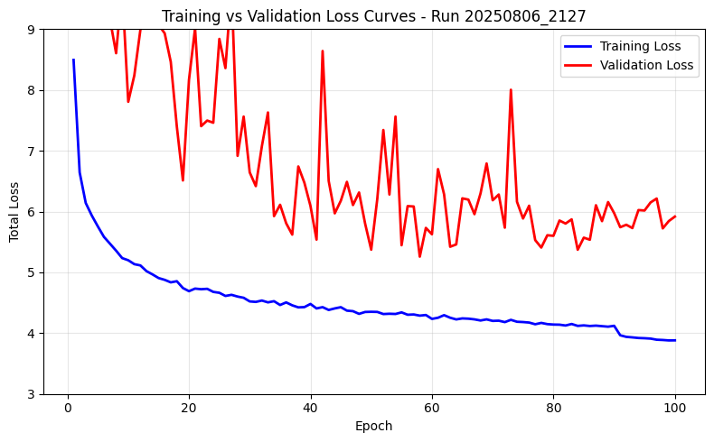

```python
plot_total_loss(str(results_path / 'results.csv'), ylim=(3, 9))
```

Adding mosaic (at probability=1) only adds no real benefit.

Now repeat intitial in situ augmentation run using *alternative processing* (channels=amp/phase/zeros+$\epsilon$)

#### 3.2.3 Alternative processing, in situ augmentation (hvrt)

Create the data .yaml configuration file:

```python
# Create data configuration
import yaml

data_config = {
    'path':   str(PROJECT_ROOT / 'data'),
    'train':  'train_alt',
    'val':    'val_alt',
    'test':   'test_al',
    'nc': 2,
    'names':  ['is_vessel', 'is_fishing']
}

# Save to configs directory
yaml_path = CONFIG_DIR / 'sar_data_aug_alt.yaml'
with open(yaml_path, 'w') as f:
    yaml.dump(data_config, f)
```

```python
# Load the model
model = YOLO('yolov8n.pt')
```

```python
# Create a timestamp for the training run
timestamp = datetime.now().strftime('%Y%m%d_%H%M')

# Train the model
results = model.train(
    data=str(yaml_path),
    epochs=100,
    batch=16,
    imgsz=640,
    freeze=None,
    plots=True,
    project=RUNS_DIR / 'train_png_aug_alt',
    name=timestamp,

    # Augmentation parameters
    auto_augment=None,
    hsv_h=0.0,
    hsv_s=0.0,
    hsv_v=0.0,
    translate=0.1,  # transaltion (+/- fraction)
    degrees=15.0,    # rotation (+/- degrees)
    scale=0.0,
    fliplr=0.5,     # horizontal flip (prob)
    flipud=0.5,     # vertical flip (prob.)
    mosaic=0.0
)
```

```
New https://pypi.org/project/ultralytics/8.3.175 available 😃 Update with 'pip install -U ultralytics'
Ultralytics 8.3.152 🚀 Python-3.10.12 torch-2.6.0+cu124 CUDA:0 (NVIDIA RTX 2000 Ada Generation Laptop GPU, 8188MiB)
engine/trainer: agnostic_nms=False, amp=True, augment=False, auto_augment=None, batch=16, bgr=0.0, box=7.5, cache=False, cfg=None, classes=None, close_mosaic=10, cls=0.5, conf=None, copy_paste=0.0, copy_paste_mode=flip, cos_lr=False, cutmix=0.0, data=/home/peterm/UWA/CITS5014/SARFish/modelling/confi…
Overriding model.yaml nc=80 with nc=2

                   from  n    params  module                                       arguments
  0                  -1  1       464  ultralytics.nn.modules.conv.Conv             [3, 16, 3, 2]
  1                  -1  1      4672  ultralytics.nn.modules.conv.Conv             [16, 32, 3, 2]
  2                  -1  1      7360  ultralytics.nn.modules.block.C2f             [32, 32, 1, True]
  3                  -1  1     18560  ultralytics.nn.modules.conv.Conv             [32, 64, 3, 2]
  4                  -1  2     49664  ultralytics.nn.modules.block.C2f             [64, 64, 2, True]
  5                  -1  1     73984  ultralytics.nn.modules.conv.Conv             [64, 128, 3, 2]
  6                  -1  2    197632  ultralytics.nn.modules.block.C2f             [128, 128, 2, True]
  7                  -1  1    295424  ultralytics.nn.modules.conv.Conv             [128, 256, 3, 2]
  8                  -1  1    460288  ultralytics.nn.modules.block.C2f             [256, 256, 1, True]
  9                  -1  1    164608  ultralytics.nn.modules.block.SPPF            [256, 256, 5]
 10                  -1  1         0  torch.nn.modules.upsampling.Upsample         [None, 2, 'nearest']
 11             [-1, 6]  1         0  ultralytics.nn.modules.conv.Concat           [1]
 12                  -1  1    148224  ultralytics.nn.modules.block.C2f             [384, 128, 1]
 13                  -1  1         0  torch.nn.modules.upsampling.Upsample         [None, 2, 'nearest']
 14             [-1, 4]  1         0  ultralytics.nn.modules.conv.Concat           [1]
 15                  -1  1     37248  ultralytics.nn.modules.block.C2f             [192, 64, 1]
 16                  -1  1     36992  ultralytics.nn.modules.conv.Conv             [64, 64, 3, 2]
 17            [-1, 12]  1         0  ultralytics.nn.modules.conv.Concat           [1]
 18                  -1  1    123648  ultralytics.nn.modules.block.C2f             [192, 128, 1]
 19                  -1  1    147712  ultralytics.nn.modules.conv.Conv             [128, 128, 3, 2]
 20             [-1, 9]  1         0  ultralytics.nn.modules.conv.Concat           [1]
 21                  -1  1    493056  ultralytics.nn.modules.block.C2f             [384, 256, 1]
 22        [15, 18, 21]  1    751702  ultralytics.nn.modules.head.Detect           [2, [64, 128, 256]]
Model summary: 129 layers, 3,011,238 parameters, 3,011,222 gradients, 8.2 GFLOPs

Transferred 319/355 items from pretrained weights
TensorBoard: Start with 'tensorboard --logdir /home/peterm/UWA/CITS5014/SARFish/modelling/runs/train_png_aug_alt/20250807_0938', view at http://localhost:6006/
Freezing layer 'model.22.dfl.conv.weight'
AMP: running Automatic Mixed Precision (AMP) checks...
AMP: checks passed ✅
train: Fast image access ✅ (ping: 0.0±0.0 ms, read: 1424.5±604.8 MB/s, size: 20.6 KB)
```

```
train: Scanning /home/peterm/UWA/CITS5014/SARFish/modelling/data/train_alt/labels... 3114 images, 0 backgrounds, 0 corru
```

```
train: New cache created: /home/peterm/UWA/CITS5014/SARFish/modelling/data/train_alt/labels.cache
```

```
albumentations: Blur(p=0.01, blur_limit=(3, 7)), MedianBlur(p=0.01, blur_limit=(3, 7)), ToGray(p=0.01, method='weighted_average', num_output_channels=3), CLAHE(p=0.01, clip_limit=(1.0, 4.0), tile_grid_size=(8, 8))
val: Fast image access ✅ (ping: 0.0±0.0 ms, read: 728.5±325.4 MB/s, size: 20.6 KB)
```

```
val: Scanning /home/peterm/UWA/CITS5014/SARFish/modelling/data/val_alt/labels... 463 images, 0 backgrounds, 0 corrupt: 1
```

```
val: New cache created: /home/peterm/UWA/CITS5014/SARFish/modelling/data/val_alt/labels.cache
```

```
Plotting labels to /home/peterm/UWA/CITS5014/SARFish/modelling/runs/train_png_aug_alt/20250807_0938/labels.jpg...
optimizer: 'optimizer=auto' found, ignoring 'lr0=0.01' and 'momentum=0.937' and determining best 'optimizer', 'lr0' and 'momentum' automatically...
optimizer: AdamW(lr=0.001667, momentum=0.9) with parameter groups 57 weight(decay=0.0), 64 weight(decay=0.0005), 63 bias(decay=0.0)
TensorBoard: model graph visualization added ✅
Image sizes 640 train, 640 val
Using 8 dataloader workers
Logging results to /home/peterm/UWA/CITS5014/SARFish/modelling/runs/train_png_aug_alt/20250807_0938
Starting training for 100 epochs...

      Epoch    GPU_mem   box_loss   cls_loss   dfl_loss  Instances       Size
```

```
      1/100      1.97G      2.166      3.841      2.091         10        640: 100%|██████████| 195/195 [00:34<00:00,  5
                 Class     Images  Instances      Box(P          R      mAP50  mAP50-95): 100%|██████████| 15/15 [00:03<
```

```
                   all        463        463      0.715       0.24       0.26     0.0773
```

```
      Epoch    GPU_mem   box_loss   cls_loss   dfl_loss  Instances       Size
```

```
      2/100      2.31G      1.807      2.268        1.7         10        640: 100%|██████████| 195/195 [00:34<00:00,  5
                 Class     Images  Instances      Box(P          R      mAP50  mAP50-95): 100%|██████████| 15/15 [00:04<
```

```
                   all        463        463      0.188      0.559      0.294       0.11
```

```
      Epoch    GPU_mem   box_loss   cls_loss   dfl_loss  Instances       Size
```

```
      3/100      2.32G      1.758      1.813      1.665         10        640: 100%|██████████| 195/195 [00:33<00:00,  5
                 Class     Images  Instances      Box(P          R      mAP50  mAP50-95): 100%|██████████| 15/15 [00:04<
```

```
                   all        463        463      0.694      0.189      0.174     0.0608
```

```
      Epoch    GPU_mem   box_loss   cls_loss   dfl_loss  Instances       Size
```

```
      4/100      2.33G      1.751      1.697      1.656         10        640: 100%|██████████| 195/195 [00:32<00:00,  6
                 Class     Images  Instances      Box(P          R      mAP50  mAP50-95): 100%|██████████| 15/15 [00:03<
```

```
                   all        463        463      0.225      0.407      0.262     0.0964
```

```
      Epoch    GPU_mem   box_loss   cls_loss   dfl_loss  Instances       Size
```

```
      5/100      2.35G      1.657      1.624      1.574         10        640: 100%|██████████| 195/195 [00:32<00:00,  6
                 Class     Images  Instances      Box(P          R      mAP50  mAP50-95): 100%|██████████| 15/15 [00:03<
```

```
                   all        463        463       0.22      0.587      0.354      0.154
```

```
      Epoch    GPU_mem   box_loss   cls_loss   dfl_loss  Instances       Size
```

```
      6/100      2.37G      1.621      1.598      1.554         10        640: 100%|██████████| 195/195 [00:32<00:00,  6
                 Class     Images  Instances      Box(P          R      mAP50  mAP50-95): 100%|██████████| 15/15 [00:04<
```

```
                   all        463        463      0.229      0.507      0.378      0.145
```

```
      Epoch    GPU_mem   box_loss   cls_loss   dfl_loss  Instances       Size
```

```
      7/100      2.39G        1.6       1.56      1.551         10        640: 100%|██████████| 195/195 [00:31<00:00,  6
                 Class     Images  Instances      Box(P          R      mAP50  mAP50-95): 100%|██████████| 15/15 [00:03<
```

```
                   all        463        463       0.28        0.5      0.358      0.149
```

```
      Epoch    GPU_mem   box_loss   cls_loss   dfl_loss  Instances       Size
```

```
      8/100       2.4G      1.573      1.543      1.528         10        640: 100%|██████████| 195/195 [00:34<00:00,  5
                 Class     Images  Instances      Box(P          R      mAP50  mAP50-95): 100%|██████████| 15/15 [00:04<
```

```
                   all        463        463      0.349      0.553       0.45      0.188
```

```
      Epoch    GPU_mem   box_loss   cls_loss   dfl_loss  Instances       Size
```

```
      9/100      2.42G      1.575      1.532      1.527         10        640: 100%|██████████| 195/195 [00:34<00:00,  5
                 Class     Images  Instances      Box(P          R      mAP50  mAP50-95): 100%|██████████| 15/15 [00:04<
```

```
                   all        463        463      0.258      0.602      0.399      0.165
```

```
      Epoch    GPU_mem   box_loss   cls_loss   dfl_loss  Instances       Size
```

```
     10/100      2.44G      1.541       1.49      1.499         10        640: 100%|██████████| 195/195 [00:39<00:00,  4
                 Class     Images  Instances      Box(P          R      mAP50  mAP50-95): 100%|██████████| 15/15 [00:03<
```

```
                   all        463        463      0.349        0.6      0.472      0.195
```

```
      Epoch    GPU_mem   box_loss   cls_loss   dfl_loss  Instances       Size
```

```
     11/100      2.46G      1.544      1.489       1.51         10        640: 100%|██████████| 195/195 [00:33<00:00,  5
                 Class     Images  Instances      Box(P          R      mAP50  mAP50-95): 100%|██████████| 15/15 [00:03<
```

```
                   all        463        463      0.377      0.486      0.413      0.183
```

```
      Epoch    GPU_mem   box_loss   cls_loss   dfl_loss  Instances       Size
```

```
     12/100      2.46G      1.512      1.467      1.492         10        640: 100%|██████████| 195/195 [00:34<00:00,  5
                 Class     Images  Instances      Box(P          R      mAP50  mAP50-95): 100%|██████████| 15/15 [00:04<
```

```
                   all        463        463      0.387      0.468      0.446      0.187
```

```
      Epoch    GPU_mem   box_loss   cls_loss   dfl_loss  Instances       Size
```

```
     13/100      2.49G      1.502      1.481       1.49         10        640: 100%|██████████| 195/195 [00:34<00:00,  5
                 Class     Images  Instances      Box(P          R      mAP50  mAP50-95): 100%|██████████| 15/15 [00:03<
```

```
                   all        463        463      0.262      0.712      0.453      0.183
```

```
      Epoch    GPU_mem   box_loss   cls_loss   dfl_loss  Instances       Size
```

```
     14/100      2.51G      1.491      1.473      1.487         10        640: 100%|██████████| 195/195 [00:37<00:00,  5
                 Class     Images  Instances      Box(P          R      mAP50  mAP50-95): 100%|██████████| 15/15 [00:04<
```

```
                   all        463        463      0.334      0.603       0.47      0.193
```

```
      Epoch    GPU_mem   box_loss   cls_loss   dfl_loss  Instances       Size
```

```
     15/100      2.53G      1.486      1.444       1.48         10        640: 100%|██████████| 195/195 [00:39<00:00,  4
                 Class     Images  Instances      Box(P          R      mAP50  mAP50-95): 100%|██████████| 15/15 [00:03<
```

```
                   all        463        463      0.369      0.533      0.464      0.205
```

```
      Epoch    GPU_mem   box_loss   cls_loss   dfl_loss  Instances       Size
```

```
     16/100      2.53G      1.474       1.44       1.47         10        640: 100%|██████████| 195/195 [00:34<00:00,  5
                 Class     Images  Instances      Box(P          R      mAP50  mAP50-95): 100%|██████████| 15/15 [00:04<
```

```
                   all        463        463      0.336      0.573      0.442       0.19
```

```
      Epoch    GPU_mem   box_loss   cls_loss   dfl_loss  Instances       Size
```

```
     17/100      2.56G      1.458       1.44      1.452         10        640: 100%|██████████| 195/195 [00:33<00:00,  5
                 Class     Images  Instances      Box(P          R      mAP50  mAP50-95): 100%|██████████| 15/15 [00:04<
```

```
                   all        463        463      0.438      0.454      0.475      0.215
```

```
      Epoch    GPU_mem   box_loss   cls_loss   dfl_loss  Instances       Size
```

```
     18/100      2.58G       1.45       1.45      1.462         10        640: 100%|██████████| 195/195 [00:33<00:00,  5
                 Class     Images  Instances      Box(P          R      mAP50  mAP50-95): 100%|██████████| 15/15 [00:04<
```

```
                   all        463        463       0.32       0.56      0.469      0.212
```

```
      Epoch    GPU_mem   box_loss   cls_loss   dfl_loss  Instances       Size
```

```
     19/100      2.59G      1.441      1.435      1.458         10        640: 100%|██████████| 195/195 [00:36<00:00,  5
                 Class     Images  Instances      Box(P          R      mAP50  mAP50-95): 100%|██████████| 15/15 [00:05<
```

```
                   all        463        463      0.422      0.528      0.507      0.202
```

```
      Epoch    GPU_mem   box_loss   cls_loss   dfl_loss  Instances       Size
```

```
     20/100       2.6G      1.444      1.422      1.451         10        640: 100%|██████████| 195/195 [01:04<00:00,  3
                 Class     Images  Instances      Box(P          R      mAP50  mAP50-95): 100%|██████████| 15/15 [00:04<
```

```
                   all        463        463      0.312       0.53      0.424      0.168
```

```
      Epoch    GPU_mem   box_loss   cls_loss   dfl_loss  Instances       Size
```

```
     21/100      2.63G      1.436      1.413      1.447         10        640: 100%|██████████| 195/195 [00:32<00:00,  6
                 Class     Images  Instances      Box(P          R      mAP50  mAP50-95): 100%|██████████| 15/15 [00:04<
```

```
                   all        463        463      0.384      0.573      0.509       0.21
```

```
      Epoch    GPU_mem   box_loss   cls_loss   dfl_loss  Instances       Size
```

```
     22/100      2.64G      1.436      1.409      1.451         10        640: 100%|██████████| 195/195 [00:32<00:00,  5
                 Class     Images  Instances      Box(P          R      mAP50  mAP50-95): 100%|██████████| 15/15 [00:04<
```

```
                   all        463        463      0.387      0.525      0.468      0.214
```

```
      Epoch    GPU_mem   box_loss   cls_loss   dfl_loss  Instances       Size
```

```
     23/100      2.66G      1.419        1.4      1.441         10        640: 100%|██████████| 195/195 [00:34<00:00,  5
                 Class     Images  Instances      Box(P          R      mAP50  mAP50-95): 100%|██████████| 15/15 [00:04<
```

```
                   all        463        463      0.347      0.614      0.483      0.214
```

```
      Epoch    GPU_mem   box_loss   cls_loss   dfl_loss  Instances       Size
```

```
     24/100      2.67G      1.423      1.401      1.445         10        640: 100%|██████████| 195/195 [00:32<00:00,  5
                 Class     Images  Instances      Box(P          R      mAP50  mAP50-95): 100%|██████████| 15/15 [00:03<
```

```
                   all        463        463      0.408      0.621      0.544      0.235
```

```
      Epoch    GPU_mem   box_loss   cls_loss   dfl_loss  Instances       Size
```

```
     25/100       2.7G      1.426      1.386      1.443         10        640: 100%|██████████| 195/195 [00:31<00:00,  6
                 Class     Images  Instances      Box(P          R      mAP50  mAP50-95): 100%|██████████| 15/15 [00:03<
```

```
                   all        463        463       0.38      0.558      0.493      0.206
```

```
      Epoch    GPU_mem   box_loss   cls_loss   dfl_loss  Instances       Size
```

```
     26/100      2.71G      1.411      1.386      1.434         10        640: 100%|██████████| 195/195 [00:46<00:00,  4
                 Class     Images  Instances      Box(P          R      mAP50  mAP50-95): 100%|██████████| 15/15 [00:05<
```

```
                   all        463        463      0.471      0.495      0.536      0.242
```

```
      Epoch    GPU_mem   box_loss   cls_loss   dfl_loss  Instances       Size
```

```
     27/100      2.73G      1.414      1.381      1.428         10        640: 100%|██████████| 195/195 [01:02<00:00,  3
                 Class     Images  Instances      Box(P          R      mAP50  mAP50-95): 100%|██████████| 15/15 [00:04<
```

```
                   all        463        463       0.47      0.461      0.492      0.201
```

```
      Epoch    GPU_mem   box_loss   cls_loss   dfl_loss  Instances       Size
```

```
     28/100      2.74G      1.404      1.382      1.424         10        640: 100%|██████████| 195/195 [00:31<00:00,  6
                 Class     Images  Instances      Box(P          R      mAP50  mAP50-95): 100%|██████████| 15/15 [00:03<
```

```
                   all        463        463       0.33      0.623      0.481      0.224
```

```
      Epoch    GPU_mem   box_loss   cls_loss   dfl_loss  Instances       Size
```

```
     29/100      2.76G      1.391      1.379      1.423         10        640: 100%|██████████| 195/195 [00:33<00:00,  5
                 Class     Images  Instances      Box(P          R      mAP50  mAP50-95): 100%|██████████| 15/15 [00:04<
```

```
                   all        463        463      0.403      0.565      0.499      0.207
```

```
      Epoch    GPU_mem   box_loss   cls_loss   dfl_loss  Instances       Size
```

```
     30/100      2.78G      1.392      1.376      1.422         10        640: 100%|██████████| 195/195 [00:32<00:00,  5
                 Class     Images  Instances      Box(P          R      mAP50  mAP50-95): 100%|██████████| 15/15 [00:04<
```

```
                   all        463        463      0.434      0.599      0.554      0.245
```

```
      Epoch    GPU_mem   box_loss   cls_loss   dfl_loss  Instances       Size
```

```
     31/100       2.8G       1.39      1.375      1.416         10        640: 100%|██████████| 195/195 [00:35<00:00,  5
                 Class     Images  Instances      Box(P          R      mAP50  mAP50-95): 100%|██████████| 15/15 [00:04<
```

```
                   all        463        463      0.454      0.516      0.545      0.251
```

```
      Epoch    GPU_mem   box_loss   cls_loss   dfl_loss  Instances       Size
```

```
     32/100      2.81G      1.384      1.378      1.422         10        640: 100%|██████████| 195/195 [00:33<00:00,  5
                 Class     Images  Instances      Box(P          R      mAP50  mAP50-95): 100%|██████████| 15/15 [00:04<
```

```
                   all        463        463      0.391      0.629       0.54      0.247
```

```
      Epoch    GPU_mem   box_loss   cls_loss   dfl_loss  Instances       Size
```

```
     33/100      2.83G      1.392      1.376      1.414         10        640: 100%|██████████| 195/195 [00:33<00:00,  5
                 Class     Images  Instances      Box(P          R      mAP50  mAP50-95): 100%|██████████| 15/15 [00:04<
```

```
                   all        463        463      0.388      0.599      0.506       0.23
```

```
      Epoch    GPU_mem   box_loss   cls_loss   dfl_loss  Instances       Size
```

```
     34/100      2.85G      1.375      1.353      1.415         10        640: 100%|██████████| 195/195 [00:34<00:00,  5
                 Class     Images  Instances      Box(P          R      mAP50  mAP50-95): 100%|██████████| 15/15 [00:05<
```

```
                   all        463        463      0.397      0.596      0.529       0.23
```

```
      Epoch    GPU_mem   box_loss   cls_loss   dfl_loss  Instances       Size
```

```
     35/100      2.87G      1.373      1.352      1.408         10        640: 100%|██████████| 195/195 [00:43<00:00,  4
                 Class     Images  Instances      Box(P          R      mAP50  mAP50-95): 100%|██████████| 15/15 [00:06<
```

```
                   all        463        463      0.452      0.606      0.541      0.237
```

```
      Epoch    GPU_mem   box_loss   cls_loss   dfl_loss  Instances       Size
```

```
     36/100      2.88G       1.37      1.363      1.408         10        640: 100%|██████████| 195/195 [01:03<00:00,  3
                 Class     Images  Instances      Box(P          R      mAP50  mAP50-95): 100%|██████████| 15/15 [00:04<
```

```
                   all        463        463      0.385      0.563      0.512      0.238
```

```
      Epoch    GPU_mem   box_loss   cls_loss   dfl_loss  Instances       Size
```

```
     37/100       2.9G      1.368      1.344      1.406         10        640: 100%|██████████| 195/195 [00:30<00:00,  6
                 Class     Images  Instances      Box(P          R      mAP50  mAP50-95): 100%|██████████| 15/15 [00:03<
```

```
                   all        463        463      0.429      0.547      0.511      0.212
```

```
      Epoch    GPU_mem   box_loss   cls_loss   dfl_loss  Instances       Size
```

```
     38/100      2.92G      1.373      1.341      1.408         10        640: 100%|██████████| 195/195 [00:32<00:00,  6
                 Class     Images  Instances      Box(P          R      mAP50  mAP50-95): 100%|██████████| 15/15 [00:04<
```

```
                   all        463        463      0.442      0.585      0.557      0.254
```

```
      Epoch    GPU_mem   box_loss   cls_loss   dfl_loss  Instances       Size
```

```
     39/100      2.94G      1.373      1.351      1.407         10        640: 100%|██████████| 195/195 [00:32<00:00,  5
                 Class     Images  Instances      Box(P          R      mAP50  mAP50-95): 100%|██████████| 15/15 [00:04<
```

```
                   all        463        463      0.419       0.59      0.519      0.206
```

```
      Epoch    GPU_mem   box_loss   cls_loss   dfl_loss  Instances       Size
```

```
     40/100      2.94G      1.354      1.342      1.393         10        640: 100%|██████████| 195/195 [00:42<00:00,  4
                 Class     Images  Instances      Box(P          R      mAP50  mAP50-95): 100%|██████████| 15/15 [00:06<
```

```
                   all        463        463      0.454      0.575      0.538      0.241
```

```
      Epoch    GPU_mem   box_loss   cls_loss   dfl_loss  Instances       Size
```

```
     41/100      2.97G      1.351       1.34       1.39         10        640: 100%|██████████| 195/195 [01:03<00:00,  3
                 Class     Images  Instances      Box(P          R      mAP50  mAP50-95): 100%|██████████| 15/15 [00:04<
```

```
                   all        463        463       0.39      0.596      0.513      0.226
```

```
      Epoch    GPU_mem   box_loss   cls_loss   dfl_loss  Instances       Size
```

```
     42/100      2.99G      1.352      1.345      1.394         10        640: 100%|██████████| 195/195 [00:31<00:00,  6
                 Class     Images  Instances      Box(P          R      mAP50  mAP50-95): 100%|██████████| 15/15 [00:03<
```

```
                   all        463        463      0.439      0.596      0.538       0.25
```

```
      Epoch    GPU_mem   box_loss   cls_loss   dfl_loss  Instances       Size
```

```
     43/100         3G      1.349      1.334       1.39         10        640: 100%|██████████| 195/195 [00:32<00:00,  6
                 Class     Images  Instances      Box(P          R      mAP50  mAP50-95): 100%|██████████| 15/15 [00:03<
```

```
                   all        463        463      0.453      0.588      0.535      0.232
```

```
      Epoch    GPU_mem   box_loss   cls_loss   dfl_loss  Instances       Size
```

```
     44/100      3.01G      1.341      1.336      1.385         10        640: 100%|██████████| 195/195 [00:31<00:00,  6
                 Class     Images  Instances      Box(P          R      mAP50  mAP50-95): 100%|██████████| 15/15 [00:03<
```

```
                   all        463        463       0.48      0.529      0.547      0.238
```

```
      Epoch    GPU_mem   box_loss   cls_loss   dfl_loss  Instances       Size
```

```
     45/100      3.04G       1.34      1.335       1.39         10        640: 100%|██████████| 195/195 [00:44<00:00,  4
                 Class     Images  Instances      Box(P          R      mAP50  mAP50-95): 100%|██████████| 15/15 [00:05<
```

```
                   all        463        463      0.538      0.545      0.571       0.25
```

```
      Epoch    GPU_mem   box_loss   cls_loss   dfl_loss  Instances       Size
```

```
     46/100      3.05G      1.347      1.325      1.386         10        640: 100%|██████████| 195/195 [00:58<00:00,  3
                 Class     Images  Instances      Box(P          R      mAP50  mAP50-95): 100%|██████████| 15/15 [00:04<
```

```
                   all        463        463      0.448      0.538      0.497       0.21
```

```
      Epoch    GPU_mem   box_loss   cls_loss   dfl_loss  Instances       Size
```

```
     47/100      3.07G      1.357      1.315      1.399         10        640: 100%|██████████| 195/195 [00:31<00:00,  6
                 Class     Images  Instances      Box(P          R      mAP50  mAP50-95): 100%|██████████| 15/15 [00:03<
```

```
                   all        463        463      0.492      0.581      0.563      0.246
```

```
      Epoch    GPU_mem   box_loss   cls_loss   dfl_loss  Instances       Size
```

```
     48/100      3.08G       1.33      1.319      1.388         10        640: 100%|██████████| 195/195 [00:31<00:00,  6
                 Class     Images  Instances      Box(P          R      mAP50  mAP50-95): 100%|██████████| 15/15 [00:04<
```

```
                   all        463        463      0.464      0.581      0.537      0.239
```

```
      Epoch    GPU_mem   box_loss   cls_loss   dfl_loss  Instances       Size
```

```
     49/100      3.11G      1.337      1.313      1.385         10        640: 100%|██████████| 195/195 [00:31<00:00,  6
                 Class     Images  Instances      Box(P          R      mAP50  mAP50-95): 100%|██████████| 15/15 [00:03<
```

```
                   all        463        463      0.438      0.576      0.521      0.232
```

```
      Epoch    GPU_mem   box_loss   cls_loss   dfl_loss  Instances       Size
```

```
     50/100      3.12G      1.329      1.305      1.375         10        640: 100%|██████████| 195/195 [01:00<00:00,  3
                 Class     Images  Instances      Box(P          R      mAP50  mAP50-95): 100%|██████████| 15/15 [00:05<
```

```
                   all        463        463      0.471      0.616      0.548      0.262
```

```
      Epoch    GPU_mem   box_loss   cls_loss   dfl_loss  Instances       Size
```

```
     51/100      3.14G       1.32       1.31      1.375         10        640: 100%|██████████| 195/195 [00:47<00:00,  4
                 Class     Images  Instances      Box(P          R      mAP50  mAP50-95): 100%|██████████| 15/15 [00:03<
```

```
                   all        463        463      0.435      0.612      0.547      0.266
```

```
      Epoch    GPU_mem   box_loss   cls_loss   dfl_loss  Instances       Size
```

```
     52/100      3.15G      1.331      1.306      1.377         10        640: 100%|██████████| 195/195 [00:31<00:00,  6
                 Class     Images  Instances      Box(P          R      mAP50  mAP50-95): 100%|██████████| 15/15 [00:03<
```

```
                   all        463        463      0.412      0.665       0.56      0.258
```

```
      Epoch    GPU_mem   box_loss   cls_loss   dfl_loss  Instances       Size
```

```
     53/100      3.17G      1.326      1.305      1.376         10        640: 100%|██████████| 195/195 [00:30<00:00,  6
                 Class     Images  Instances      Box(P          R      mAP50  mAP50-95): 100%|██████████| 15/15 [00:03<
```

```
                   all        463        463      0.431      0.609      0.551      0.253
```

```
      Epoch    GPU_mem   box_loss   cls_loss   dfl_loss  Instances       Size
```

```
     54/100      3.19G      1.311      1.295      1.374         10        640: 100%|██████████| 195/195 [00:34<00:00,  5
                 Class     Images  Instances      Box(P          R      mAP50  mAP50-95): 100%|██████████| 15/15 [00:05<
```

```
                   all        463        463      0.434      0.612      0.525      0.237
```

```
      Epoch    GPU_mem   box_loss   cls_loss   dfl_loss  Instances       Size
```

```
     55/100      3.21G      1.311      1.294      1.369         10        640: 100%|██████████| 195/195 [01:03<00:00,  3
                 Class     Images  Instances      Box(P          R      mAP50  mAP50-95): 100%|██████████| 15/15 [00:05<
```

```
                   all        463        463      0.447      0.585      0.552      0.231
```

```
      Epoch    GPU_mem   box_loss   cls_loss   dfl_loss  Instances       Size
```

```
     56/100      3.21G      1.316      1.287      1.366         10        640: 100%|██████████| 195/195 [00:33<00:00,  5
                 Class     Images  Instances      Box(P          R      mAP50  mAP50-95): 100%|██████████| 15/15 [00:03<
```

```
                   all        463        463      0.429      0.645      0.533      0.251
```

```
      Epoch    GPU_mem   box_loss   cls_loss   dfl_loss  Instances       Size
```

```
     57/100      3.24G      1.314      1.287      1.373         10        640: 100%|██████████| 195/195 [00:31<00:00,  6
                 Class     Images  Instances      Box(P          R      mAP50  mAP50-95): 100%|██████████| 15/15 [00:03<
```

```
                   all        463        463      0.447      0.587      0.534      0.242
```

```
      Epoch    GPU_mem   box_loss   cls_loss   dfl_loss  Instances       Size
```

```
     58/100      3.26G      1.305       1.28      1.368         10        640: 100%|██████████| 195/195 [00:33<00:00,  5
                 Class     Images  Instances      Box(P          R      mAP50  mAP50-95): 100%|██████████| 15/15 [00:05<
```

```
                   all        463        463      0.463      0.616      0.538      0.263
```

```
      Epoch    GPU_mem   box_loss   cls_loss   dfl_loss  Instances       Size
```

```
     59/100      3.28G      1.317      1.282      1.369         10        640: 100%|██████████| 195/195 [01:03<00:00,  3
                 Class     Images  Instances      Box(P          R      mAP50  mAP50-95): 100%|██████████| 15/15 [00:05<
```

```
                   all        463        463      0.418      0.585      0.525      0.235
```

```
      Epoch    GPU_mem   box_loss   cls_loss   dfl_loss  Instances       Size
```

```
     60/100      3.28G      1.304      1.282       1.36         10        640: 100%|██████████| 195/195 [00:39<00:00,  4
                 Class     Images  Instances      Box(P          R      mAP50  mAP50-95): 100%|██████████| 15/15 [00:03<
```

```
                   all        463        463       0.44      0.615      0.541      0.252
```

```
      Epoch    GPU_mem   box_loss   cls_loss   dfl_loss  Instances       Size
```

```
     61/100      3.31G      1.296      1.267      1.358         10        640: 100%|██████████| 195/195 [00:31<00:00,  6
                 Class     Images  Instances      Box(P          R      mAP50  mAP50-95): 100%|██████████| 15/15 [00:03<
```

```
                   all        463        463      0.437      0.612       0.55      0.238
```

```
      Epoch    GPU_mem   box_loss   cls_loss   dfl_loss  Instances       Size
```

```
     62/100      3.33G      1.296      1.265      1.358         10        640: 100%|██████████| 195/195 [00:31<00:00,  6
                 Class     Images  Instances      Box(P          R      mAP50  mAP50-95): 100%|██████████| 15/15 [00:03<
```

```
                   all        463        463      0.462      0.638      0.534      0.245
```

```
      Epoch    GPU_mem   box_loss   cls_loss   dfl_loss  Instances       Size
```

```
     63/100      3.35G      1.301      1.271      1.355         10        640: 100%|██████████| 195/195 [00:37<00:00,  5
                 Class     Images  Instances      Box(P          R      mAP50  mAP50-95): 100%|██████████| 15/15 [00:05<
```

```
                   all        463        463      0.476      0.581      0.564      0.267
```

```
      Epoch    GPU_mem   box_loss   cls_loss   dfl_loss  Instances       Size
```

```
     64/100      3.35G      1.295      1.263      1.353         10        640: 100%|██████████| 195/195 [01:03<00:00,  3
                 Class     Images  Instances      Box(P          R      mAP50  mAP50-95): 100%|██████████| 15/15 [00:05<
```

```
                   all        463        463      0.451      0.563      0.544      0.258
```

```
      Epoch    GPU_mem   box_loss   cls_loss   dfl_loss  Instances       Size
```

```
     65/100      3.38G       1.28      1.256       1.35         10        640: 100%|██████████| 195/195 [00:31<00:00,  6
                 Class     Images  Instances      Box(P          R      mAP50  mAP50-95): 100%|██████████| 15/15 [00:04<
```

```
                   all        463        463       0.44      0.636       0.52      0.231
```

```
      Epoch    GPU_mem   box_loss   cls_loss   dfl_loss  Instances       Size
```

```
     66/100       3.4G       1.28      1.253      1.346         10        640: 100%|██████████| 195/195 [00:31<00:00,  6
                 Class     Images  Instances      Box(P          R      mAP50  mAP50-95): 100%|██████████| 15/15 [00:03<
```

```
                   all        463        463      0.442      0.602      0.525      0.235
```

```
      Epoch    GPU_mem   box_loss   cls_loss   dfl_loss  Instances       Size
```

```
     67/100      3.41G      1.281       1.26       1.35         10        640: 100%|██████████| 195/195 [00:39<00:00,  5
                 Class     Images  Instances      Box(P          R      mAP50  mAP50-95): 100%|██████████| 15/15 [00:05<
```

```
                   all        463        463       0.45      0.567      0.544      0.246
```

```
      Epoch    GPU_mem   box_loss   cls_loss   dfl_loss  Instances       Size
```

```
     68/100      3.42G      1.278      1.247      1.343         10        640: 100%|██████████| 195/195 [01:03<00:00,  3
                 Class     Images  Instances      Box(P          R      mAP50  mAP50-95): 100%|██████████| 15/15 [00:04<
```

```
                   all        463        463      0.435      0.571      0.548      0.244
```

```
      Epoch    GPU_mem   box_loss   cls_loss   dfl_loss  Instances       Size
```

```
     69/100      3.45G      1.272      1.252      1.338         10        640: 100%|██████████| 195/195 [00:30<00:00,  6
                 Class     Images  Instances      Box(P          R      mAP50  mAP50-95): 100%|██████████| 15/15 [00:03<
```

```
                   all        463        463      0.423      0.603      0.542      0.248
```

```
      Epoch    GPU_mem   box_loss   cls_loss   dfl_loss  Instances       Size
```

```
     70/100      3.46G      1.277      1.237      1.342         10        640: 100%|██████████| 195/195 [00:32<00:00,  6
                 Class     Images  Instances      Box(P          R      mAP50  mAP50-95): 100%|██████████| 15/15 [00:03<
```

```
                   all        463        463       0.46      0.582      0.549      0.261
```

```
      Epoch    GPU_mem   box_loss   cls_loss   dfl_loss  Instances       Size
```

```
     71/100      3.48G      1.273      1.247      1.343         10        640: 100%|██████████| 195/195 [00:36<00:00,  5
                 Class     Images  Instances      Box(P          R      mAP50  mAP50-95): 100%|██████████| 15/15 [00:04<
```

```
                   all        463        463      0.456      0.652      0.562      0.265
```

```
      Epoch    GPU_mem   box_loss   cls_loss   dfl_loss  Instances       Size
```

```
     72/100      3.49G      1.264      1.236      1.329         10        640: 100%|██████████| 195/195 [01:03<00:00,  3
                 Class     Images  Instances      Box(P          R      mAP50  mAP50-95): 100%|██████████| 15/15 [00:05<
```

```
                   all        463        463      0.443      0.653      0.544      0.264
```

```
      Epoch    GPU_mem   box_loss   cls_loss   dfl_loss  Instances       Size
```

```
     73/100      3.52G      1.261      1.222      1.335         10        640: 100%|██████████| 195/195 [00:35<00:00,  5
                 Class     Images  Instances      Box(P          R      mAP50  mAP50-95): 100%|██████████| 15/15 [00:04<
```

```
                   all        463        463      0.438      0.641      0.556      0.256
```

```
      Epoch    GPU_mem   box_loss   cls_loss   dfl_loss  Instances       Size
```

```
     74/100      3.53G       1.26      1.221      1.334         10        640: 100%|██████████| 195/195 [00:30<00:00,  6
                 Class     Images  Instances      Box(P          R      mAP50  mAP50-95): 100%|██████████| 15/15 [00:03<
```

```
                   all        463        463      0.473      0.658      0.535      0.242
```

```
      Epoch    GPU_mem   box_loss   cls_loss   dfl_loss  Instances       Size
```

```
     75/100      3.55G      1.258      1.222      1.335         10        640: 100%|██████████| 195/195 [00:32<00:00,  6
                 Class     Images  Instances      Box(P          R      mAP50  mAP50-95): 100%|██████████| 15/15 [00:05<
```

```
                   all        463        463      0.473      0.615      0.549      0.248
```

```
      Epoch    GPU_mem   box_loss   cls_loss   dfl_loss  Instances       Size
```

```
     76/100      3.56G       1.25      1.221      1.333         10        640: 100%|██████████| 195/195 [01:03<00:00,  3
                 Class     Images  Instances      Box(P          R      mAP50  mAP50-95): 100%|██████████| 15/15 [00:04<
```

```
                   all        463        463      0.438      0.591      0.542      0.256
```

```
      Epoch    GPU_mem   box_loss   cls_loss   dfl_loss  Instances       Size
```

```
     77/100      3.58G      1.254      1.211      1.326         10        640: 100%|██████████| 195/195 [00:43<00:00,  4
                 Class     Images  Instances      Box(P          R      mAP50  mAP50-95): 100%|██████████| 15/15 [00:03<
```

```
                   all        463        463      0.466      0.619      0.538      0.262
```

```
      Epoch    GPU_mem   box_loss   cls_loss   dfl_loss  Instances       Size
```

```
     78/100       3.6G      1.251      1.203      1.322         10        640: 100%|██████████| 195/195 [00:32<00:00,  6
                 Class     Images  Instances      Box(P          R      mAP50  mAP50-95): 100%|██████████| 15/15 [00:04<
```

```
                   all        463        463      0.479      0.639      0.558      0.263
```

```
      Epoch    GPU_mem   box_loss   cls_loss   dfl_loss  Instances       Size
```

```
     79/100      3.62G      1.242      1.211      1.316         10        640: 100%|██████████| 195/195 [00:32<00:00,  5
                 Class     Images  Instances      Box(P          R      mAP50  mAP50-95): 100%|██████████| 15/15 [00:04<
```

```
                   all        463        463      0.446      0.621       0.53      0.251
```

```
      Epoch    GPU_mem   box_loss   cls_loss   dfl_loss  Instances       Size
```

```
     80/100      3.62G      1.237      1.202      1.315         10        640: 100%|██████████| 195/195 [00:42<00:00,  4
                 Class     Images  Instances      Box(P          R      mAP50  mAP50-95): 100%|██████████| 15/15 [00:07<
```

```
                   all        463        463      0.444      0.636      0.557      0.264

      Epoch    GPU_mem   box_loss   cls_loss   dfl_loss  Instances       Size
```

```
     81/100      3.65G      1.236      1.194      1.311         10        640: 100%|██████████| 195/195 [01:04<00:00,  3
                 Class     Images  Instances      Box(P          R      mAP50  mAP50-95): 100%|██████████| 15/15 [00:05<
```

```
                   all        463        463      0.463      0.614      0.559      0.266
```

```
      Epoch    GPU_mem   box_loss   cls_loss   dfl_loss  Instances       Size
```

```
     82/100      3.67G      1.238      1.184      1.314         10        640: 100%|██████████| 195/195 [00:41<00:00,  4
                 Class     Images  Instances      Box(P          R      mAP50  mAP50-95): 100%|██████████| 15/15 [00:03<
```

```
                   all        463        463      0.464      0.632      0.562      0.263
```

```
      Epoch    GPU_mem   box_loss   cls_loss   dfl_loss  Instances       Size
```

```
     83/100      3.69G      1.227      1.182      1.312         10        640: 100%|██████████| 195/195 [00:32<00:00,  6
                 Class     Images  Instances      Box(P          R      mAP50  mAP50-95): 100%|██████████| 15/15 [00:03<
```

```
                   all        463        463      0.462      0.633      0.559      0.266
```

```
      Epoch    GPU_mem   box_loss   cls_loss   dfl_loss  Instances       Size
```

```
     84/100       3.7G      1.235      1.193      1.315         10        640: 100%|██████████| 195/195 [00:31<00:00,  6
                 Class     Images  Instances      Box(P          R      mAP50  mAP50-95): 100%|██████████| 15/15 [00:03<
```

```
                   all        463        463      0.457      0.644      0.558      0.264
```

```
      Epoch    GPU_mem   box_loss   cls_loss   dfl_loss  Instances       Size
```

```
     85/100      3.72G      1.229      1.181      1.313         10        640: 100%|██████████| 195/195 [00:52<00:00,  3
                 Class     Images  Instances      Box(P          R      mAP50  mAP50-95): 100%|██████████| 15/15 [00:05<
```

```
                   all        463        463      0.449      0.683      0.561      0.268
```

```
      Epoch    GPU_mem   box_loss   cls_loss   dfl_loss  Instances       Size
```

```
     86/100      3.74G      1.228      1.173      1.311         10        640: 100%|██████████| 195/195 [01:03<00:00,  3
                 Class     Images  Instances      Box(P          R      mAP50  mAP50-95): 100%|██████████| 15/15 [00:04<
```

```
                   all        463        463      0.459       0.64      0.557      0.265
```

```
      Epoch    GPU_mem   box_loss   cls_loss   dfl_loss  Instances       Size
```

```
     87/100      3.76G      1.221      1.166      1.307         10        640: 100%|██████████| 195/195 [00:31<00:00,  6
                 Class     Images  Instances      Box(P          R      mAP50  mAP50-95): 100%|██████████| 15/15 [00:04<
```

```
                   all        463        463      0.464      0.605      0.567      0.267
```

```
      Epoch    GPU_mem   box_loss   cls_loss   dfl_loss  Instances       Size
```

```
     88/100      3.76G      1.227      1.174      1.306         10        640: 100%|██████████| 195/195 [00:34<00:00,  5
                 Class     Images  Instances      Box(P          R      mAP50  mAP50-95): 100%|██████████| 15/15 [00:04<
```

```
                   all        463        463       0.45      0.656      0.564      0.265
```

```
      Epoch    GPU_mem   box_loss   cls_loss   dfl_loss  Instances       Size
```

```
     89/100      3.79G      1.212      1.156      1.304         10        640: 100%|██████████| 195/195 [00:32<00:00,  5
                 Class     Images  Instances      Box(P          R      mAP50  mAP50-95): 100%|██████████| 15/15 [00:05<
```

```
                   all        463        463      0.447      0.672      0.564      0.265
```

```
      Epoch    GPU_mem   box_loss   cls_loss   dfl_loss  Instances       Size
```

```
     90/100      3.81G      1.218       1.16      1.303         10        640: 100%|██████████| 195/195 [01:04<00:00,  3
                 Class     Images  Instances      Box(P          R      mAP50  mAP50-95): 100%|██████████| 15/15 [00:05<
```

```
                   all        463        463      0.467      0.656      0.554      0.256
```

```
Closing dataloader mosaic
albumentations: Blur(p=0.01, blur_limit=(3, 7)), MedianBlur(p=0.01, blur_limit=(3, 7)), ToGray(p=0.01, method='weighted_average', num_output_channels=3), CLAHE(p=0.01, clip_limit=(1.0, 4.0), tile_grid_size=(8, 8))

      Epoch    GPU_mem   box_loss   cls_loss   dfl_loss  Instances       Size
```

```
     91/100      3.82G      1.213      1.155        1.3         10        640: 100%|██████████| 195/195 [01:03<00:00,  3
                 Class     Images  Instances      Box(P          R      mAP50  mAP50-95): 100%|██████████| 15/15 [00:04<
```

```
                   all        463        463      0.455       0.65       0.54      0.255
```

```
      Epoch    GPU_mem   box_loss   cls_loss   dfl_loss  Instances       Size
```

```
     92/100      3.83G      1.198      1.146      1.291         10        640: 100%|██████████| 195/195 [00:33<00:00,  5
                 Class     Images  Instances      Box(P          R      mAP50  mAP50-95): 100%|██████████| 15/15 [00:03<
```

```
                   all        463        463      0.465      0.639      0.552      0.261
```

```
      Epoch    GPU_mem   box_loss   cls_loss   dfl_loss  Instances       Size
```

```
     93/100      3.86G      1.203      1.148      1.297         10        640: 100%|██████████| 195/195 [00:32<00:00,  5
                 Class     Images  Instances      Box(P          R      mAP50  mAP50-95): 100%|██████████| 15/15 [00:04<
```

```
                   all        463        463      0.458      0.666      0.552      0.262
```

```
      Epoch    GPU_mem   box_loss   cls_loss   dfl_loss  Instances       Size
```

```
     94/100      3.88G      1.204       1.14      1.295         10        640: 100%|██████████| 195/195 [00:34<00:00,  5
                 Class     Images  Instances      Box(P          R      mAP50  mAP50-95): 100%|██████████| 15/15 [00:05<
```

```
                   all        463        463      0.458      0.654      0.534      0.256
```

```
      Epoch    GPU_mem   box_loss   cls_loss   dfl_loss  Instances       Size
```

```
     95/100      3.89G      1.197      1.143       1.29         10        640: 100%|██████████| 195/195 [01:04<00:00,  3
                 Class     Images  Instances      Box(P          R      mAP50  mAP50-95): 100%|██████████| 15/15 [00:05<
```

```
                   all        463        463      0.492      0.653      0.556      0.259
```

```
      Epoch    GPU_mem   box_loss   cls_loss   dfl_loss  Instances       Size
```

```
     96/100       3.9G      1.189      1.133      1.287         10        640: 100%|██████████| 195/195 [00:45<00:00,  4
                 Class     Images  Instances      Box(P          R      mAP50  mAP50-95): 100%|██████████| 15/15 [00:04<
```

```
                   all        463        463      0.488      0.612      0.548      0.259
```

```
      Epoch    GPU_mem   box_loss   cls_loss   dfl_loss  Instances       Size
```

```
     97/100      3.93G      1.193      1.134      1.289         10        640: 100%|██████████| 195/195 [00:34<00:00,  5
                 Class     Images  Instances      Box(P          R      mAP50  mAP50-95): 100%|██████████| 15/15 [00:04<
```

```
                   all        463        463      0.477      0.651      0.554      0.259
```

```
      Epoch    GPU_mem   box_loss   cls_loss   dfl_loss  Instances       Size
```

```
     98/100      3.94G      1.187      1.136      1.285         10        640: 100%|██████████| 195/195 [00:33<00:00,  5
                 Class     Images  Instances      Box(P          R      mAP50  mAP50-95): 100%|██████████| 15/15 [00:04<
```

```
                   all        463        463      0.472      0.653       0.55      0.258

      Epoch    GPU_mem   box_loss   cls_loss   dfl_loss  Instances       Size
```

```
     99/100      3.96G      1.188      1.132      1.285         10        640: 100%|██████████| 195/195 [00:34<00:00,  5
                 Class     Images  Instances      Box(P          R      mAP50  mAP50-95): 100%|██████████| 15/15 [00:04<
```

```
                   all        463        463      0.475      0.638      0.557      0.264
```

```
      Epoch    GPU_mem   box_loss   cls_loss   dfl_loss  Instances       Size
```

```
    100/100      3.97G      1.192      1.136      1.287         10        640: 100%|██████████| 195/195 [00:44<00:00,  4
                 Class     Images  Instances      Box(P          R      mAP50  mAP50-95): 100%|██████████| 15/15 [00:05<
```

```
                   all        463        463      0.504       0.61      0.557      0.261
```

```
100 epochs completed in 1.240 hours.
Optimizer stripped from /home/peterm/UWA/CITS5014/SARFish/modelling/runs/train_png_aug_alt/20250807_0938/weights/last.pt, 6.3MB
Optimizer stripped from /home/peterm/UWA/CITS5014/SARFish/modelling/runs/train_png_aug_alt/20250807_0938/weights/best.pt, 6.3MB

Validating /home/peterm/UWA/CITS5014/SARFish/modelling/runs/train_png_aug_alt/20250807_0938/weights/best.pt...
Ultralytics 8.3.152 🚀 Python-3.10.12 torch-2.6.0+cu124 CUDA:0 (NVIDIA RTX 2000 Ada Generation Laptop GPU, 8188MiB)
Model summary (fused): 72 layers, 3,006,038 parameters, 0 gradients, 8.1 GFLOPs
```

```
                 Class     Images  Instances      Box(P          R      mAP50  mAP50-95): 100%|██████████| 15/15 [00:06<
```

```
                   all        463        463      0.451      0.683      0.562      0.268
             is_vessel        331        331      0.527      0.782      0.758      0.385
            is_fishing        132        132      0.375      0.583      0.366      0.151
Speed: 0.5ms preprocess, 5.9ms inference, 0.0ms loss, 2.2ms postprocess per image
Results saved to /home/peterm/UWA/CITS5014/SARFish/modelling/runs/train_png_aug_alt/20250807_0938
```

```python
results_path = RUNS_DIR / 'train_png_aug_alt' / '20250807_0938'
```

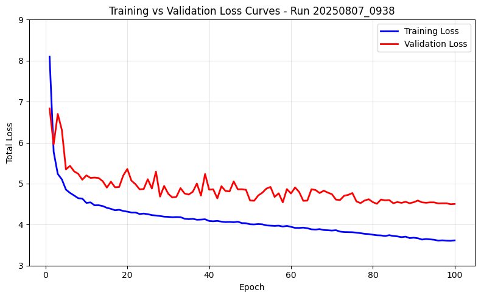

```python
plot_total_loss(str(results_path / 'results.csv'), ylim=(3, 9))
```

A definite improvement. Best so far.

#### 3.2.4 Alternative processing (Extended), in situ augmentation (hvrt)

Resume training Alternate Processig dataset using basic in situ augmentation as this has yielded the best results so far...

Note: Uses same data .yaml file as above ('sar_data_aug_alt.yaml')

```python
model=YOLO('/home/peterm/UWA/CITS5014/SARFish/modelling/runs/train_png_aug_alt/20250807_0938/weights/best.pt')
```

```python
# Create a timestamp for the training run
timestamp = datetime.now().strftime('%Y%m%d_%H%M')

# Train the model
results = model.train(
    data=str(yaml_path),
    epochs=100,
    lr0=0.0001,
    warmup_epochs=0,
    optimizer='AdamW',
    weight_decay=0.0005,

    batch=16,
    imgsz=640,
    freeze=None,
    plots=True,
    project=RUNS_DIR / 'train_png_aug_alt',
    name=timestamp,

    # Augmentation parameters
    auto_augment=None,
    hsv_h=0.0,
    hsv_s=0.0,
    hsv_v=0.0,
    translate=0.1,  # transaltion (+/- fraction)
    degrees=15.0,   # rotation (+/- degrees)
    scale=0.0,
    fliplr=0.5,     # horizontal flip (prob)
    flipud=0.5,     # vertical flip (prob.)
    mosaic=0.0
)
```

```
New https://pypi.org/project/ultralytics/8.3.175 available 😃 Update with 'pip install -U ultralytics'
Ultralytics 8.3.152 🚀 Python-3.10.12 torch-2.6.0+cu124 CUDA:0 (NVIDIA RTX 2000 Ada Generation Laptop GPU, 8188MiB)
engine/trainer: agnostic_nms=False, amp=True, augment=False, auto_augment=None, batch=16, bgr=0.0, box=7.5, cache=False, cfg=None, classes=None, close_mosaic=10, cls=0.5, conf=None, copy_paste=0.0, copy_paste_mode=flip, cos_lr=False, cutmix=0.0, data=/home/peterm/UWA/CITS5014/SARFish/modelling/confi…

                   from  n    params  module                                       arguments
  0                  -1  1       464  ultralytics.nn.modules.conv.Conv             [3, 16, 3, 2]
  1                  -1  1      4672  ultralytics.nn.modules.conv.Conv             [16, 32, 3, 2]
  2                  -1  1      7360  ultralytics.nn.modules.block.C2f             [32, 32, 1, True]
  3                  -1  1     18560  ultralytics.nn.modules.conv.Conv             [32, 64, 3, 2]
  4                  -1  2     49664  ultralytics.nn.modules.block.C2f             [64, 64, 2, True]
  5                  -1  1     73984  ultralytics.nn.modules.conv.Conv             [64, 128, 3, 2]
  6                  -1  2    197632  ultralytics.nn.modules.block.C2f             [128, 128, 2, True]
  7                  -1  1    295424  ultralytics.nn.modules.conv.Conv             [128, 256, 3, 2]
  8                  -1  1    460288  ultralytics.nn.modules.block.C2f             [256, 256, 1, True]
  9                  -1  1    164608  ultralytics.nn.modules.block.SPPF            [256, 256, 5]
 10                  -1  1         0  torch.nn.modules.upsampling.Upsample         [None, 2, 'nearest']
 11             [-1, 6]  1         0  ultralytics.nn.modules.conv.Concat           [1]
 12                  -1  1    148224  ultralytics.nn.modules.block.C2f             [384, 128, 1]
 13                  -1  1         0  torch.nn.modules.upsampling.Upsample         [None, 2, 'nearest']
 14             [-1, 4]  1         0  ultralytics.nn.modules.conv.Concat           [1]
 15                  -1  1     37248  ultralytics.nn.modules.block.C2f             [192, 64, 1]
 16                  -1  1     36992  ultralytics.nn.modules.conv.Conv             [64, 64, 3, 2]
 17            [-1, 12]  1         0  ultralytics.nn.modules.conv.Concat           [1]
 18                  -1  1    123648  ultralytics.nn.modules.block.C2f             [192, 128, 1]
 19                  -1  1    147712  ultralytics.nn.modules.conv.Conv             [128, 128, 3, 2]
 20             [-1, 9]  1         0  ultralytics.nn.modules.conv.Concat           [1]
 21                  -1  1    493056  ultralytics.nn.modules.block.C2f             [384, 256, 1]
 22        [15, 18, 21]  1    751702  ultralytics.nn.modules.head.Detect           [2, [64, 128, 256]]
Model summary: 129 layers, 3,011,238 parameters, 3,011,222 gradients, 8.2 GFLOPs

Transferred 355/355 items from pretrained weights
TensorBoard: Start with 'tensorboard --logdir /home/peterm/UWA/CITS5014/SARFish/modelling/runs/train_png_aug_alt/20250807_1239', view at http://localhost:6006/
Freezing layer 'model.22.dfl.conv.weight'
AMP: running Automatic Mixed Precision (AMP) checks...
AMP: checks passed ✅
train: Fast image access ✅ (ping: 0.1±0.0 ms, read: 33.9±20.3 MB/s, size: 20.6 KB)
```

```
train: Scanning /home/peterm/UWA/CITS5014/SARFish/modelling/data/train_alt/labels.cache... 3114 images, 0 backgrounds, 0
```

```
albumentations: Blur(p=0.01, blur_limit=(3, 7)), MedianBlur(p=0.01, blur_limit=(3, 7)), ToGray(p=0.01, method='weighted_average', num_output_channels=3), CLAHE(p=0.01, clip_limit=(1.0, 4.0), tile_grid_size=(8, 8))
```

```
val: Fast image access ✅ (ping: 0.1±0.0 ms, read: 38.9±9.4 MB/s, size: 20.6 KB)
```

```
val: Scanning /home/peterm/UWA/CITS5014/SARFish/modelling/data/val_alt/labels.cache... 463 images, 0 backgrounds, 0 corr
```

```
Plotting labels to /home/peterm/UWA/CITS5014/SARFish/modelling/runs/train_png_aug_alt/20250807_1239/labels.jpg...
optimizer: AdamW(lr=0.0001, momentum=0.937) with parameter groups 57 weight(decay=0.0), 64 weight(decay=0.0005), 63 bias(decay=0.0)
TensorBoard: model graph visualization added ✅
Image sizes 640 train, 640 val
Using 8 dataloader workers
Logging results to /home/peterm/UWA/CITS5014/SARFish/modelling/runs/train_png_aug_alt/20250807_1239
Starting training for 100 epochs...

      Epoch    GPU_mem   box_loss   cls_loss   dfl_loss  Instances       Size
```

```
      1/100      3.02G      1.213       1.17      1.303         10        640: 100%|██████████| 195/195 [00:30<00:00,  6
                 Class     Images  Instances      Box(P          R      mAP50  mAP50-95): 100%|██████████| 15/15 [00:03<
```

```
                   all        463        463      0.449      0.647      0.548      0.266
```

```
      Epoch    GPU_mem   box_loss   cls_loss   dfl_loss  Instances       Size
```

```
      2/100      3.24G      1.214      1.162      1.303         10        640: 100%|██████████| 195/195 [00:55<00:00,  3
                 Class     Images  Instances      Box(P          R      mAP50  mAP50-95): 100%|██████████| 15/15 [00:06<
```

```
                   all        463        463      0.467      0.633       0.55      0.265
```

```
      Epoch    GPU_mem   box_loss   cls_loss   dfl_loss  Instances       Size
```

```
      3/100      3.24G      1.209      1.157      1.294         10        640: 100%|██████████| 195/195 [01:06<00:00,  2
                 Class     Images  Instances      Box(P          R      mAP50  mAP50-95): 100%|██████████| 15/15 [00:05<
```

```
                   all        463        463      0.458      0.654      0.557      0.267
```

```
      Epoch    GPU_mem   box_loss   cls_loss   dfl_loss  Instances       Size
```

```
      4/100      3.24G      1.209      1.153      1.299         10        640: 100%|██████████| 195/195 [00:33<00:00,  5
                 Class     Images  Instances      Box(P          R      mAP50  mAP50-95): 100%|██████████| 15/15 [00:03<
```

```
                   all        463        463      0.471      0.661       0.55      0.262
```

```
      Epoch    GPU_mem   box_loss   cls_loss   dfl_loss  Instances       Size
```

```
      5/100      3.24G      1.197      1.155      1.291         10        640: 100%|██████████| 195/195 [00:32<00:00,  6
                 Class     Images  Instances      Box(P          R      mAP50  mAP50-95): 100%|██████████| 15/15 [00:04<
```

```
                   all        463        463      0.465      0.648       0.55      0.262
```

```
      Epoch    GPU_mem   box_loss   cls_loss   dfl_loss  Instances       Size
```

```
      6/100      3.24G      1.208      1.153        1.3         10        640: 100%|██████████| 195/195 [00:42<00:00,  4
                 Class     Images  Instances      Box(P          R      mAP50  mAP50-95): 100%|██████████| 15/15 [00:05<
```

```
                   all        463        463      0.476      0.635      0.546      0.263
```

```
      Epoch    GPU_mem   box_loss   cls_loss   dfl_loss  Instances       Size
```

```
      7/100      3.24G      1.201      1.153      1.294         10        640: 100%|██████████| 195/195 [00:42<00:00,  4
                 Class     Images  Instances      Box(P          R      mAP50  mAP50-95): 100%|██████████| 15/15 [00:05<
```

```
                   all        463        463       0.46      0.655      0.553      0.262
```

```
      Epoch    GPU_mem   box_loss   cls_loss   dfl_loss  Instances       Size
```

```
      8/100      3.24G      1.198      1.146      1.295         10        640: 100%|██████████| 195/195 [00:38<00:00,  5
                 Class     Images  Instances      Box(P          R      mAP50  mAP50-95): 100%|██████████| 15/15 [00:04<
```

```
                   all        463        463      0.477       0.63      0.547      0.262
```

```
      Epoch    GPU_mem   box_loss   cls_loss   dfl_loss  Instances       Size
```

```
      9/100      3.24G      1.198      1.145      1.289         10        640: 100%|██████████| 195/195 [00:38<00:00,  5
                 Class     Images  Instances      Box(P          R      mAP50  mAP50-95): 100%|██████████| 15/15 [00:04<
```

```
                   all        463        463      0.481      0.595      0.544      0.262
```

```
      Epoch    GPU_mem   box_loss   cls_loss   dfl_loss  Instances       Size
```

```
     10/100      3.24G      1.203      1.143       1.29         10        640: 100%|██████████| 195/195 [00:46<00:00,  4
                 Class     Images  Instances      Box(P          R      mAP50  mAP50-95): 100%|██████████| 15/15 [00:05<
```

```
                   all        463        463      0.468      0.626      0.552      0.268
```

```
      Epoch    GPU_mem   box_loss   cls_loss   dfl_loss  Instances       Size
```

```
     11/100      3.24G        1.2      1.144      1.292         10        640: 100%|██████████| 195/195 [01:04<00:00,  3
                 Class     Images  Instances      Box(P          R      mAP50  mAP50-95): 100%|██████████| 15/15 [00:05<
```

```
                   all        463        463      0.478      0.632      0.554      0.267
```

```
      Epoch    GPU_mem   box_loss   cls_loss   dfl_loss  Instances       Size
```

```
     12/100      3.24G      1.192      1.142      1.288         10        640: 100%|██████████| 195/195 [00:32<00:00,  6
                 Class     Images  Instances      Box(P          R      mAP50  mAP50-95): 100%|██████████| 15/15 [00:03<
```

```
                   all        463        463      0.481      0.621      0.548      0.262
```

```
      Epoch    GPU_mem   box_loss   cls_loss   dfl_loss  Instances       Size
```

```
     13/100      3.24G      1.193      1.134       1.29         10        640: 100%|██████████| 195/195 [00:32<00:00,  5
                 Class     Images  Instances      Box(P          R      mAP50  mAP50-95): 100%|██████████| 15/15 [00:04<
```

```
                   all        463        463      0.466      0.601      0.553      0.263
```

```
      Epoch    GPU_mem   box_loss   cls_loss   dfl_loss  Instances       Size
```

```
     14/100      3.24G      1.193      1.131      1.286         10        640: 100%|██████████| 195/195 [00:36<00:00,  5
                 Class     Images  Instances      Box(P          R      mAP50  mAP50-95): 100%|██████████| 15/15 [00:06<
```

```
                   all        463        463      0.478      0.605      0.554      0.265
```

```
      Epoch    GPU_mem   box_loss   cls_loss   dfl_loss  Instances       Size
```

```
     15/100      3.24G      1.192      1.134      1.285         10        640: 100%|██████████| 195/195 [01:05<00:00,  2
                 Class     Images  Instances      Box(P          R      mAP50  mAP50-95): 100%|██████████| 15/15 [00:05<
```

```
                   all        463        463      0.471      0.612      0.543      0.262
```

```
      Epoch    GPU_mem   box_loss   cls_loss   dfl_loss  Instances       Size
```

```
     16/100      3.24G      1.191       1.13      1.291         10        640: 100%|██████████| 195/195 [00:31<00:00,  6
                 Class     Images  Instances      Box(P          R      mAP50  mAP50-95): 100%|██████████| 15/15 [00:03<
```

```
                   all        463        463      0.475      0.613       0.56      0.264
```

```
      Epoch    GPU_mem   box_loss   cls_loss   dfl_loss  Instances       Size
```

```
     17/100      3.24G      1.197      1.128      1.287         10        640: 100%|██████████| 195/195 [00:32<00:00,  6
                 Class     Images  Instances      Box(P          R      mAP50  mAP50-95): 100%|██████████| 15/15 [00:03<
```

```
                   all        463        463      0.485       0.65      0.558      0.267
```

```
      Epoch    GPU_mem   box_loss   cls_loss   dfl_loss  Instances       Size
```

```
     18/100      3.24G      1.186       1.13      1.282         10        640: 100%|██████████| 195/195 [00:31<00:00,  6
                 Class     Images  Instances      Box(P          R      mAP50  mAP50-95): 100%|██████████| 15/15 [00:03<
```

```
                   all        463        463      0.474      0.606      0.549      0.264
```

```
      Epoch    GPU_mem   box_loss   cls_loss   dfl_loss  Instances       Size
```

```
     19/100      3.24G      1.192      1.127      1.292         10        640: 100%|██████████| 195/195 [00:54<00:00,  3
                 Class     Images  Instances      Box(P          R      mAP50  mAP50-95): 100%|██████████| 15/15 [00:06<
```

```
                   all        463        463      0.469        0.6      0.545      0.263
```

```
      Epoch    GPU_mem   box_loss   cls_loss   dfl_loss  Instances       Size
```

```
     20/100      3.24G      1.184      1.121      1.285         10        640: 100%|██████████| 195/195 [00:57<00:00,  3
                 Class     Images  Instances      Box(P          R      mAP50  mAP50-95): 100%|██████████| 15/15 [00:04<
```

```
                   all        463        463      0.491        0.6      0.556      0.263
```

```
      Epoch    GPU_mem   box_loss   cls_loss   dfl_loss  Instances       Size
```

```
     21/100      3.24G      1.181      1.122      1.278         10        640: 100%|██████████| 195/195 [00:30<00:00,  6
                 Class     Images  Instances      Box(P          R      mAP50  mAP50-95): 100%|██████████| 15/15 [00:03<
```

```
                   all        463        463      0.473      0.631      0.551      0.262
```

```
      Epoch    GPU_mem   box_loss   cls_loss   dfl_loss  Instances       Size
```

```
     22/100      3.24G      1.183      1.123      1.286         10        640: 100%|██████████| 195/195 [00:31<00:00,  6
                 Class     Images  Instances      Box(P          R      mAP50  mAP50-95): 100%|██████████| 15/15 [00:03<
```

```
                   all        463        463      0.463      0.614      0.549      0.266
```

```
      Epoch    GPU_mem   box_loss   cls_loss   dfl_loss  Instances       Size
```

```
     23/100      3.24G      1.182      1.118      1.285         10        640: 100%|██████████| 195/195 [00:39<00:00,  4
                 Class     Images  Instances      Box(P          R      mAP50  mAP50-95): 100%|██████████| 15/15 [00:05<
```

```
                   all        463        463      0.485      0.626      0.554      0.266
```

```
      Epoch    GPU_mem   box_loss   cls_loss   dfl_loss  Instances       Size
```

```
     24/100      3.24G      1.186      1.129      1.287         10        640: 100%|██████████| 195/195 [01:04<00:00,  3
                 Class     Images  Instances      Box(P          R      mAP50  mAP50-95): 100%|██████████| 15/15 [00:05<
```

```
                   all        463        463      0.476      0.624      0.557      0.269
```

```
      Epoch    GPU_mem   box_loss   cls_loss   dfl_loss  Instances       Size
```

```
     25/100      3.24G      1.188      1.121      1.292         10        640: 100%|██████████| 195/195 [00:33<00:00,  5
                 Class     Images  Instances      Box(P          R      mAP50  mAP50-95): 100%|██████████| 15/15 [00:03<
```

```
                   all        463        463      0.466      0.641      0.546      0.268
```

```
      Epoch    GPU_mem   box_loss   cls_loss   dfl_loss  Instances       Size
```

```
     26/100      3.24G       1.18      1.114      1.285         10        640: 100%|██████████| 195/195 [00:32<00:00,  6
                 Class     Images  Instances      Box(P          R      mAP50  mAP50-95): 100%|██████████| 15/15 [00:04<
```

```
                   all        463        463      0.477      0.629      0.558      0.267
```

```
      Epoch    GPU_mem   box_loss   cls_loss   dfl_loss  Instances       Size
```

```
     27/100      3.24G      1.178      1.111      1.279         10        640: 100%|██████████| 195/195 [00:45<00:00,  4
                 Class     Images  Instances      Box(P          R      mAP50  mAP50-95): 100%|██████████| 15/15 [00:05<
```

```
                   all        463        463      0.472      0.629      0.558      0.265
```

```
      Epoch    GPU_mem   box_loss   cls_loss   dfl_loss  Instances       Size
```

```
     28/100      3.24G      1.184       1.12      1.282         10        640: 100%|██████████| 195/195 [01:05<00:00,  2
                 Class     Images  Instances      Box(P          R      mAP50  mAP50-95): 100%|██████████| 15/15 [00:04<
```

```
                   all        463        463      0.475      0.611       0.56       0.27
```

```
      Epoch    GPU_mem   box_loss   cls_loss   dfl_loss  Instances       Size
```

```
     29/100      3.24G      1.178      1.114      1.282         10        640: 100%|██████████| 195/195 [00:32<00:00,  6
                 Class     Images  Instances      Box(P          R      mAP50  mAP50-95): 100%|██████████| 15/15 [00:03<
```

```
                   all        463        463       0.48      0.629      0.556      0.265
```

```
      Epoch    GPU_mem   box_loss   cls_loss   dfl_loss  Instances       Size
```

```
     30/100      3.24G      1.174      1.112      1.279         10        640: 100%|██████████| 195/195 [00:33<00:00,  5
                 Class     Images  Instances      Box(P          R      mAP50  mAP50-95): 100%|██████████| 15/15 [00:03<
```

```
                   all        463        463      0.497       0.63      0.554      0.267
```

```
      Epoch    GPU_mem   box_loss   cls_loss   dfl_loss  Instances       Size
```

```
     31/100      3.24G       1.18      1.111       1.28         10        640: 100%|██████████| 195/195 [00:33<00:00,  5
                 Class     Images  Instances      Box(P          R      mAP50  mAP50-95): 100%|██████████| 15/15 [00:03<
```

```
                   all        463        463       0.48       0.64      0.559      0.268
```

```
      Epoch    GPU_mem   box_loss   cls_loss   dfl_loss  Instances       Size
```

```
     32/100      3.24G      1.177      1.113      1.282         10        640: 100%|██████████| 195/195 [00:39<00:00,  5
                 Class     Images  Instances      Box(P          R      mAP50  mAP50-95): 100%|██████████| 15/15 [00:04<
```

```
                   all        463        463      0.488      0.624      0.557      0.266
```

```
      Epoch    GPU_mem   box_loss   cls_loss   dfl_loss  Instances       Size
```

```
     33/100      3.24G      1.176      1.109      1.277         10        640: 100%|██████████| 195/195 [00:53<00:00,  3
                 Class     Images  Instances      Box(P          R      mAP50  mAP50-95): 100%|██████████| 15/15 [00:09<
```

```
                   all        463        463      0.469      0.631      0.546      0.262
```

```
      Epoch    GPU_mem   box_loss   cls_loss   dfl_loss  Instances       Size
```

```
     34/100      3.24G      1.169      1.104      1.275         10        640: 100%|██████████| 195/195 [00:59<00:00,  3
                 Class     Images  Instances      Box(P          R      mAP50  mAP50-95): 100%|██████████| 15/15 [00:03<
```

```
                   all        463        463      0.476      0.661      0.552      0.265
```

```
      Epoch    GPU_mem   box_loss   cls_loss   dfl_loss  Instances       Size
```

```
     35/100      3.24G      1.169      1.101      1.274         10        640: 100%|██████████| 195/195 [00:33<00:00,  5
                 Class     Images  Instances      Box(P          R      mAP50  mAP50-95): 100%|██████████| 15/15 [00:04<
```

```
                   all        463        463      0.464       0.64      0.538       0.26

      Epoch    GPU_mem   box_loss   cls_loss   dfl_loss  Instances       Size
```

```
     36/100      3.24G      1.172      1.102      1.275         10        640: 100%|██████████| 195/195 [00:40<00:00,  4
                 Class     Images  Instances      Box(P          R      mAP50  mAP50-95): 100%|██████████| 15/15 [00:04<
```

```
                   all        463        463      0.465      0.675      0.544       0.26
```

```
      Epoch    GPU_mem   box_loss   cls_loss   dfl_loss  Instances       Size
```

```
     37/100      3.24G      1.172      1.103      1.273         10        640: 100%|██████████| 195/195 [00:39<00:00,  4
                 Class     Images  Instances      Box(P          R      mAP50  mAP50-95): 100%|██████████| 15/15 [00:05<
```

```
                   all        463        463      0.475      0.618      0.541       0.26
```

```
      Epoch    GPU_mem   box_loss   cls_loss   dfl_loss  Instances       Size
```

```
     38/100      3.24G      1.168      1.102      1.274         10        640: 100%|██████████| 195/195 [00:39<00:00,  5
                 Class     Images  Instances      Box(P          R      mAP50  mAP50-95): 100%|██████████| 15/15 [00:04<
```

```
                   all        463        463      0.464      0.653       0.54       0.26
```

```
      Epoch    GPU_mem   box_loss   cls_loss   dfl_loss  Instances       Size
```

```
     39/100      3.24G      1.169      1.099      1.274         10        640: 100%|██████████| 195/195 [00:37<00:00,  5
                 Class     Images  Instances      Box(P          R      mAP50  mAP50-95): 100%|██████████| 15/15 [00:04<
```

```
                   all        463        463       0.46      0.625      0.544       0.26
```

```
      Epoch    GPU_mem   box_loss   cls_loss   dfl_loss  Instances       Size
```

```
     40/100      3.24G      1.166        1.1      1.272         10        640: 100%|██████████| 195/195 [00:46<00:00,  4
                 Class     Images  Instances      Box(P          R      mAP50  mAP50-95): 100%|██████████| 15/15 [00:05<
```

```
                   all        463        463      0.471       0.63      0.555      0.265
```

```
      Epoch    GPU_mem   box_loss   cls_loss   dfl_loss  Instances       Size
```

```
     41/100      3.24G      1.161       1.09      1.267         10        640: 100%|██████████| 195/195 [01:05<00:00,  3
                 Class     Images  Instances      Box(P          R      mAP50  mAP50-95): 100%|██████████| 15/15 [00:06<
```

```
                   all        463        463      0.461       0.63      0.547      0.264
```

```
      Epoch    GPU_mem   box_loss   cls_loss   dfl_loss  Instances       Size
```

```
     42/100      3.24G      1.162      1.094      1.271         10        640: 100%|██████████| 195/195 [00:36<00:00,  5
                 Class     Images  Instances      Box(P          R      mAP50  mAP50-95): 100%|██████████| 15/15 [00:04<
```

```
                   all        463        463      0.475      0.618      0.548      0.262
```

```
      Epoch    GPU_mem   box_loss   cls_loss   dfl_loss  Instances       Size
```

```
     43/100      3.24G       1.17      1.096      1.274         10        640: 100%|██████████| 195/195 [00:35<00:00,  5
                 Class     Images  Instances      Box(P          R      mAP50  mAP50-95): 100%|██████████| 15/15 [00:04<
```

```
                   all        463        463      0.459      0.607      0.544      0.264
```

```
      Epoch    GPU_mem   box_loss   cls_loss   dfl_loss  Instances       Size
```

```
     44/100      3.24G      1.169      1.098      1.273         10        640: 100%|██████████| 195/195 [00:43<00:00,  4
                 Class     Images  Instances      Box(P          R      mAP50  mAP50-95): 100%|██████████| 15/15 [00:05<
```

```
                   all        463        463      0.483      0.636      0.553      0.264
```

```
      Epoch    GPU_mem   box_loss   cls_loss   dfl_loss  Instances       Size
```

```
     45/100      3.24G      1.166      1.096      1.279         10        640: 100%|██████████| 195/195 [01:05<00:00,  2
                 Class     Images  Instances      Box(P          R      mAP50  mAP50-95): 100%|██████████| 15/15 [00:05<
```

```
                   all        463        463      0.462      0.657      0.546      0.262
```

```
      Epoch    GPU_mem   box_loss   cls_loss   dfl_loss  Instances       Size
```

```
     46/100      3.24G      1.167      1.091      1.272         10        640: 100%|██████████| 195/195 [00:34<00:00,  5
                 Class     Images  Instances      Box(P          R      mAP50  mAP50-95): 100%|██████████| 15/15 [00:04<
```

```
                   all        463        463       0.46      0.673      0.554      0.265
```

```
      Epoch    GPU_mem   box_loss   cls_loss   dfl_loss  Instances       Size
```

```
     47/100      3.24G      1.162      1.093      1.268         10        640: 100%|██████████| 195/195 [00:33<00:00,  5
                 Class     Images  Instances      Box(P          R      mAP50  mAP50-95): 100%|██████████| 15/15 [00:04<
```

```
                   all        463        463      0.465      0.635      0.549       0.26
```

```
      Epoch    GPU_mem   box_loss   cls_loss   dfl_loss  Instances       Size
```

```
     48/100      3.24G       1.16      1.089      1.273         10        640: 100%|██████████| 195/195 [00:47<00:00,  4
                 Class     Images  Instances      Box(P          R      mAP50  mAP50-95): 100%|██████████| 15/15 [00:05<
```

```
                   all        463        463      0.465      0.673      0.548      0.263
```

```
      Epoch    GPU_mem   box_loss   cls_loss   dfl_loss  Instances       Size
```

```
     49/100      3.24G      1.156      1.089      1.266         10        640: 100%|██████████| 195/195 [01:03<00:00,  3
                 Class     Images  Instances      Box(P          R      mAP50  mAP50-95): 100%|██████████| 15/15 [00:05<
```

```
                   all        463        463      0.469      0.672       0.54      0.258
```

```
      Epoch    GPU_mem   box_loss   cls_loss   dfl_loss  Instances       Size
```

```
     50/100      3.24G       1.15      1.088      1.265         10        640: 100%|██████████| 195/195 [00:44<00:00,  4
                 Class     Images  Instances      Box(P          R      mAP50  mAP50-95): 100%|██████████| 15/15 [00:06<
```

```
                   all        463        463       0.48      0.667      0.553      0.263
```

```
      Epoch    GPU_mem   box_loss   cls_loss   dfl_loss  Instances       Size
```

```
     51/100      3.24G      1.151      1.087      1.264         10        640: 100%|██████████| 195/195 [00:37<00:00,  5
                 Class     Images  Instances      Box(P          R      mAP50  mAP50-95): 100%|██████████| 15/15 [00:04<
```

```
                   all        463        463      0.454      0.663      0.548       0.26
```

```
      Epoch    GPU_mem   box_loss   cls_loss   dfl_loss  Instances       Size
```

```
     52/100      3.24G      1.153      1.085      1.267         10        640: 100%|██████████| 195/195 [00:35<00:00,  5
                 Class     Images  Instances      Box(P          R      mAP50  mAP50-95): 100%|██████████| 15/15 [00:04<
```

```
                   all        463        463      0.478      0.693      0.558      0.263
```

```
      Epoch    GPU_mem   box_loss   cls_loss   dfl_loss  Instances       Size
```

```
     53/100      3.24G      1.157      1.086      1.267         10        640: 100%|██████████| 195/195 [00:36<00:00,  5
                 Class     Images  Instances      Box(P          R      mAP50  mAP50-95): 100%|██████████| 15/15 [00:05<
```

```
                   all        463        463      0.478       0.67      0.549      0.264
```

```
      Epoch    GPU_mem   box_loss   cls_loss   dfl_loss  Instances       Size
```

```
     54/100      3.24G      1.148      1.074      1.262         10        640: 100%|██████████| 195/195 [01:04<00:00,  3
                 Class     Images  Instances      Box(P          R      mAP50  mAP50-95): 100%|██████████| 15/15 [00:05<
```

```
                   all        463        463      0.474      0.679      0.554      0.266
```

```
      Epoch    GPU_mem   box_loss   cls_loss   dfl_loss  Instances       Size
```

```
     55/100      3.24G      1.146      1.081      1.259         10        640: 100%|██████████| 195/195 [00:55<00:00,  3
                 Class     Images  Instances      Box(P          R      mAP50  mAP50-95): 100%|██████████| 15/15 [00:03<
```

```
                   all        463        463      0.453      0.691      0.548      0.263
```

```
      Epoch    GPU_mem   box_loss   cls_loss   dfl_loss  Instances       Size
```

```
     56/100      3.24G      1.156      1.078      1.263         10        640: 100%|██████████| 195/195 [00:33<00:00,  5
                 Class     Images  Instances      Box(P          R      mAP50  mAP50-95): 100%|██████████| 15/15 [00:04<
```

```
                   all        463        463       0.47      0.673      0.558      0.265
```

```
      Epoch    GPU_mem   box_loss   cls_loss   dfl_loss  Instances       Size
```

```
     57/100      3.24G      1.146       1.08      1.265         10        640: 100%|██████████| 195/195 [00:33<00:00,  5
                 Class     Images  Instances      Box(P          R      mAP50  mAP50-95): 100%|██████████| 15/15 [00:04<
```

```
                   all        463        463      0.475      0.687      0.553      0.261
```

```
      Epoch    GPU_mem   box_loss   cls_loss   dfl_loss  Instances       Size
```

```
     58/100      3.24G      1.152      1.074      1.262         10        640: 100%|██████████| 195/195 [00:40<00:00,  4
                 Class     Images  Instances      Box(P          R      mAP50  mAP50-95): 100%|██████████| 15/15 [00:05<
```

```
                   all        463        463      0.478      0.687      0.554      0.262
```

```
      Epoch    GPU_mem   box_loss   cls_loss   dfl_loss  Instances       Size
```

```
     59/100      3.24G      1.157      1.087      1.269         10        640: 100%|██████████| 195/195 [01:03<00:00,  3
                 Class     Images  Instances      Box(P          R      mAP50  mAP50-95): 100%|██████████| 15/15 [00:05<
```

```
                   all        463        463      0.462       0.68      0.554      0.265
```

```
      Epoch    GPU_mem   box_loss   cls_loss   dfl_loss  Instances       Size
```

```
     60/100      3.24G      1.151      1.077      1.263         10        640: 100%|██████████| 195/195 [00:55<00:00,  3
                 Class     Images  Instances      Box(P          R      mAP50  mAP50-95): 100%|██████████| 15/15 [00:04<
```

```
                   all        463        463      0.472      0.678      0.553      0.265
```

```
      Epoch    GPU_mem   box_loss   cls_loss   dfl_loss  Instances       Size
```

```
     61/100      3.24G      1.149      1.079      1.267         10        640: 100%|██████████| 195/195 [00:32<00:00,  5
                 Class     Images  Instances      Box(P          R      mAP50  mAP50-95): 100%|██████████| 15/15 [00:04<
```

```
                   all        463        463       0.46      0.659      0.543      0.261
```

```
      Epoch    GPU_mem   box_loss   cls_loss   dfl_loss  Instances       Size
```

```
     62/100      3.24G      1.142       1.07      1.261         10        640: 100%|██████████| 195/195 [00:33<00:00,  5
                 Class     Images  Instances      Box(P          R      mAP50  mAP50-95): 100%|██████████| 15/15 [00:04<
```

```
                   all        463        463      0.468      0.658      0.549      0.263
```

```
      Epoch    GPU_mem   box_loss   cls_loss   dfl_loss  Instances       Size
```

```
     63/100      3.24G      1.153      1.074      1.265         10        640: 100%|██████████| 195/195 [00:49<00:00,  3
                 Class     Images  Instances      Box(P          R      mAP50  mAP50-95): 100%|██████████| 15/15 [00:06<
```

```
                   all        463        463      0.465      0.669      0.547      0.261
```

```
      Epoch    GPU_mem   box_loss   cls_loss   dfl_loss  Instances       Size
```

```
     64/100      3.24G      1.146      1.073      1.259         10        640: 100%|██████████| 195/195 [01:03<00:00,  3
                 Class     Images  Instances      Box(P          R      mAP50  mAP50-95): 100%|██████████| 15/15 [00:05<
```

```
                   all        463        463      0.465      0.673      0.546       0.26
```

```
      Epoch    GPU_mem   box_loss   cls_loss   dfl_loss  Instances       Size
```

```
     65/100      3.24G      1.135      1.071      1.259         10        640: 100%|██████████| 195/195 [00:58<00:00,  3
                 Class     Images  Instances      Box(P          R      mAP50  mAP50-95): 100%|██████████| 15/15 [00:04<
```

```
                   all        463        463      0.461      0.662      0.544      0.257
```

```
      Epoch    GPU_mem   box_loss   cls_loss   dfl_loss  Instances       Size
```

```
     66/100      3.24G      1.141      1.068      1.257         10        640: 100%|██████████| 195/195 [00:33<00:00,  5
                 Class     Images  Instances      Box(P          R      mAP50  mAP50-95): 100%|██████████| 15/15 [00:04<
```

```
                   all        463        463      0.454      0.681      0.544      0.261
```

```
      Epoch    GPU_mem   box_loss   cls_loss   dfl_loss  Instances       Size
```

```
     67/100      3.24G      1.135      1.067      1.252         10        640: 100%|██████████| 195/195 [00:33<00:00,  5
                 Class     Images  Instances      Box(P          R      mAP50  mAP50-95): 100%|██████████| 15/15 [00:05<
```

```
                   all        463        463      0.467      0.678      0.544      0.258
```

```
      Epoch    GPU_mem   box_loss   cls_loss   dfl_loss  Instances       Size
```

```
     68/100      3.24G      1.141      1.065      1.259         10        640: 100%|██████████| 195/195 [01:04<00:00,  3
                 Class     Images  Instances      Box(P          R      mAP50  mAP50-95): 100%|██████████| 15/15 [00:06<
```

```
                   all        463        463      0.463      0.663      0.542      0.257
```

```
      Epoch    GPU_mem   box_loss   cls_loss   dfl_loss  Instances       Size
```

```
     69/100      3.24G       1.13      1.066       1.25         10        640: 100%|██████████| 195/195 [00:46<00:00,  4
                 Class     Images  Instances      Box(P          R      mAP50  mAP50-95): 100%|██████████| 15/15 [00:03<
```

```
                   all        463        463      0.472      0.684      0.546      0.257
```

```
      Epoch    GPU_mem   box_loss   cls_loss   dfl_loss  Instances       Size
```

```
     70/100      3.24G      1.133      1.057      1.255         10        640: 100%|██████████| 195/195 [00:34<00:00,  5
                 Class     Images  Instances      Box(P          R      mAP50  mAP50-95): 100%|██████████| 15/15 [00:04<
```

```
                   all        463        463      0.465       0.67      0.549       0.26
```

```
      Epoch    GPU_mem   box_loss   cls_loss   dfl_loss  Instances       Size
```

```
     71/100      3.24G      1.143      1.068      1.261         10        640: 100%|██████████| 195/195 [00:34<00:00,  5
                 Class     Images  Instances      Box(P          R      mAP50  mAP50-95): 100%|██████████| 15/15 [00:04<
```

```
                   all        463        463      0.476      0.687      0.545      0.258
```

```
      Epoch    GPU_mem   box_loss   cls_loss   dfl_loss  Instances       Size
```

```
     72/100      3.24G      1.136      1.063      1.252         10        640: 100%|██████████| 195/195 [00:42<00:00,  4
                 Class     Images  Instances      Box(P          R      mAP50  mAP50-95): 100%|██████████| 15/15 [00:06<
```

```
                   all        463        463      0.466      0.664      0.548       0.26
```

```
      Epoch    GPU_mem   box_loss   cls_loss   dfl_loss  Instances       Size
```

```
     73/100      3.24G      1.132      1.062      1.255         10        640: 100%|██████████| 195/195 [01:04<00:00,  3
                 Class     Images  Instances      Box(P          R      mAP50  mAP50-95): 100%|██████████| 15/15 [00:05<
```

```
                   all        463        463      0.471      0.668      0.547      0.261
```

```
      Epoch    GPU_mem   box_loss   cls_loss   dfl_loss  Instances       Size
```

```
     74/100      3.24G      1.134      1.057      1.256         10        640: 100%|██████████| 195/195 [00:47<00:00,  4
                 Class     Images  Instances      Box(P          R      mAP50  mAP50-95): 100%|██████████| 15/15 [00:04<
```

```
                   all        463        463      0.466      0.655       0.55      0.258
```

```
      Epoch    GPU_mem   box_loss   cls_loss   dfl_loss  Instances       Size
```

```
     75/100      3.24G      1.131      1.055      1.254         10        640: 100%|██████████| 195/195 [00:32<00:00,  6
                 Class     Images  Instances      Box(P          R      mAP50  mAP50-95): 100%|██████████| 15/15 [00:03<
```

```
                   all        463        463      0.465      0.684      0.539      0.258
```

```
      Epoch    GPU_mem   box_loss   cls_loss   dfl_loss  Instances       Size
```

```
     76/100      3.24G      1.129      1.061      1.257         10        640: 100%|██████████| 195/195 [00:32<00:00,  6
                 Class     Images  Instances      Box(P          R      mAP50  mAP50-95): 100%|██████████| 15/15 [00:04<
```

```
                   all        463        463      0.472      0.673      0.552       0.26

      Epoch    GPU_mem   box_loss   cls_loss   dfl_loss  Instances       Size
```

```
     77/100      3.24G      1.132       1.06      1.254         10        640: 100%|██████████| 195/195 [00:42<00:00,  4
                 Class     Images  Instances      Box(P          R      mAP50  mAP50-95): 100%|██████████| 15/15 [00:05<
```

```
                   all        463        463      0.468      0.674      0.541      0.259
```

```
      Epoch    GPU_mem   box_loss   cls_loss   dfl_loss  Instances       Size
```

```
     78/100      3.24G       1.13      1.052      1.249         10        640: 100%|██████████| 195/195 [01:04<00:00,  3
                 Class     Images  Instances      Box(P          R      mAP50  mAP50-95): 100%|██████████| 15/15 [00:05<
```

```
                   all        463        463      0.471      0.672      0.542      0.257
```

```
      Epoch    GPU_mem   box_loss   cls_loss   dfl_loss  Instances       Size
```

```
     79/100      3.24G      1.127      1.055      1.244         10        640: 100%|██████████| 195/195 [01:03<00:00,  3
                 Class     Images  Instances      Box(P          R      mAP50  mAP50-95): 100%|██████████| 15/15 [00:05<
```

```
                   all        463        463      0.477      0.665       0.54      0.257
```

```
      Epoch    GPU_mem   box_loss   cls_loss   dfl_loss  Instances       Size
```

```
     80/100      3.24G      1.122      1.052      1.248         10        640: 100%|██████████| 195/195 [00:33<00:00,  5
                 Class     Images  Instances      Box(P          R      mAP50  mAP50-95): 100%|██████████| 15/15 [00:05<
```

```
                   all        463        463      0.481       0.66       0.55      0.259
```

```
      Epoch    GPU_mem   box_loss   cls_loss   dfl_loss  Instances       Size
```

```
     81/100      3.24G      1.128      1.057      1.249         10        640: 100%|██████████| 195/195 [00:33<00:00,  5
                 Class     Images  Instances      Box(P          R      mAP50  mAP50-95): 100%|██████████| 15/15 [00:03<
```

```
                   all        463        463      0.472      0.677      0.549      0.259
```

```
      Epoch    GPU_mem   box_loss   cls_loss   dfl_loss  Instances       Size
```

```
     82/100      3.24G      1.125      1.049      1.248         10        640: 100%|██████████| 195/195 [00:46<00:00,  4
                 Class     Images  Instances      Box(P          R      mAP50  mAP50-95): 100%|██████████| 15/15 [00:06<
```

```
                   all        463        463      0.467      0.678      0.549      0.261
```

```
      Epoch    GPU_mem   box_loss   cls_loss   dfl_loss  Instances       Size
```

```
     83/100      3.24G      1.116      1.048      1.244         10        640: 100%|██████████| 195/195 [01:03<00:00,  3
                 Class     Images  Instances      Box(P          R      mAP50  mAP50-95): 100%|██████████| 15/15 [00:05<
```

```
                   all        463        463      0.466      0.666      0.549      0.258
```

```
      Epoch    GPU_mem   box_loss   cls_loss   dfl_loss  Instances       Size
```

```
     84/100      3.24G      1.135      1.059      1.254         10        640: 100%|██████████| 195/195 [01:03<00:00,  3
                 Class     Images  Instances      Box(P          R      mAP50  mAP50-95): 100%|██████████| 15/15 [00:03<
```

```
                   all        463        463      0.469       0.65      0.547      0.259
```

```
      Epoch    GPU_mem   box_loss   cls_loss   dfl_loss  Instances       Size
```

```
     85/100      3.24G      1.144      1.062      1.257         10        640: 100%|██████████| 195/195 [00:33<00:00,  5
                 Class     Images  Instances      Box(P          R      mAP50  mAP50-95): 100%|██████████| 15/15 [00:04<
```

```
                   all        463        463      0.473      0.644      0.547       0.26
```

```
      Epoch    GPU_mem   box_loss   cls_loss   dfl_loss  Instances       Size
```

```
     86/100      3.24G      1.158      1.071       1.27         10        640: 100%|██████████| 195/195 [00:33<00:00,  5
                 Class     Images  Instances      Box(P          R      mAP50  mAP50-95): 100%|██████████| 15/15 [00:04<
```

```
                   all        463        463      0.469      0.645      0.547      0.259
```

```
      Epoch    GPU_mem   box_loss   cls_loss   dfl_loss  Instances       Size
```

```
     87/100      3.24G       1.16      1.075       1.27         10        640: 100%|██████████| 195/195 [00:38<00:00,  5
                 Class     Images  Instances      Box(P          R      mAP50  mAP50-95): 100%|██████████| 15/15 [00:05<
```

```
                   all        463        463      0.466      0.679      0.547       0.26
```

```
      Epoch    GPU_mem   box_loss   cls_loss   dfl_loss  Instances       Size
```

```
     88/100      3.24G      1.168      1.081       1.27         10        640: 100%|██████████| 195/195 [01:04<00:00,  3
                 Class     Images  Instances      Box(P          R      mAP50  mAP50-95): 100%|██████████| 15/15 [00:05<
```

```
                   all        463        463      0.458      0.692      0.545      0.259
```

```
      Epoch    GPU_mem   box_loss   cls_loss   dfl_loss  Instances       Size
```

```
     89/100      3.24G      1.153      1.069      1.266         10        640: 100%|██████████| 195/195 [01:01<00:00,  3
                 Class     Images  Instances      Box(P          R      mAP50  mAP50-95): 100%|██████████| 15/15 [00:04<
```

```
                   all        463        463      0.463      0.696      0.551       0.26
```

```
      Epoch    GPU_mem   box_loss   cls_loss   dfl_loss  Instances       Size
```

```
     90/100      3.24G      1.163      1.073      1.271         10        640: 100%|██████████| 195/195 [00:33<00:00,  5
                 Class     Images  Instances      Box(P          R      mAP50  mAP50-95): 100%|██████████| 15/15 [00:04<
```

```
                   all        463        463      0.465      0.692      0.549      0.259
```

```
Closing dataloader mosaic
albumentations: Blur(p=0.01, blur_limit=(3, 7)), MedianBlur(p=0.01, blur_limit=(3, 7)), ToGray(p=0.01, method='weighted_average', num_output_channels=3), CLAHE(p=0.01, clip_limit=(1.0, 4.0), tile_grid_size=(8, 8))

      Epoch    GPU_mem   box_loss   cls_loss   dfl_loss  Instances       Size
```

```
     91/100      3.24G      1.163      1.073      1.272         10        640: 100%|██████████| 195/195 [00:37<00:00,  5
                 Class     Images  Instances      Box(P          R      mAP50  mAP50-95): 100%|██████████| 15/15 [00:04<
```

```
                   all        463        463      0.468      0.676      0.542      0.257
```

```
      Epoch    GPU_mem   box_loss   cls_loss   dfl_loss  Instances       Size
```

```
     92/100      3.24G      1.148      1.071      1.264         10        640: 100%|██████████| 195/195 [00:32<00:00,  6
                 Class     Images  Instances      Box(P          R      mAP50  mAP50-95): 100%|██████████| 15/15 [00:03<
```

```
                   all        463        463      0.465      0.685      0.542      0.256
```

```
      Epoch    GPU_mem   box_loss   cls_loss   dfl_loss  Instances       Size
```

```
     93/100      3.24G      1.156      1.072      1.267         10        640: 100%|██████████| 195/195 [00:58<00:00,  3
                 Class     Images  Instances      Box(P          R      mAP50  mAP50-95): 100%|██████████| 15/15 [00:05<
```

```
                   all        463        463      0.467      0.671      0.545      0.258
```

```
      Epoch    GPU_mem   box_loss   cls_loss   dfl_loss  Instances       Size
```

```
     94/100      3.24G      1.161      1.071      1.269         10        640: 100%|██████████| 195/195 [00:58<00:00,  3
                 Class     Images  Instances      Box(P          R      mAP50  mAP50-95): 100%|██████████| 15/15 [00:03<
```

```
                   all        463        463      0.471       0.67      0.545      0.258
```

```
      Epoch    GPU_mem   box_loss   cls_loss   dfl_loss  Instances       Size
```

```
     95/100      3.24G      1.155      1.072      1.267         10        640: 100%|██████████| 195/195 [00:32<00:00,  5
                 Class     Images  Instances      Box(P          R      mAP50  mAP50-95): 100%|██████████| 15/15 [00:03<
```

```
                   all        463        463       0.47      0.668      0.544      0.258
```

```
      Epoch    GPU_mem   box_loss   cls_loss   dfl_loss  Instances       Size
```

```
     96/100      3.24G      1.153       1.07      1.264         10        640: 100%|██████████| 195/195 [00:32<00:00,  5
                 Class     Images  Instances      Box(P          R      mAP50  mAP50-95): 100%|██████████| 15/15 [00:04<
```

```
                   all        463        463      0.466      0.651      0.544      0.258
```

```
      Epoch    GPU_mem   box_loss   cls_loss   dfl_loss  Instances       Size
```

```
     97/100      3.24G      1.157      1.077      1.266         10        640: 100%|██████████| 195/195 [00:33<00:00,  5
                 Class     Images  Instances      Box(P          R      mAP50  mAP50-95): 100%|██████████| 15/15 [00:06<
```

```
                   all        463        463      0.466      0.687      0.545      0.257
```

```
      Epoch    GPU_mem   box_loss   cls_loss   dfl_loss  Instances       Size
```

```
     98/100      3.24G      1.156      1.074      1.266         10        640: 100%|██████████| 195/195 [01:04<00:00,  3
                 Class     Images  Instances      Box(P          R      mAP50  mAP50-95): 100%|██████████| 15/15 [00:05<
```

```
                   all        463        463      0.462      0.692      0.548      0.258
```

```
      Epoch    GPU_mem   box_loss   cls_loss   dfl_loss  Instances       Size
```

```
     99/100      3.24G      1.158      1.076      1.267         10        640: 100%|██████████| 195/195 [00:45<00:00,  4
                 Class     Images  Instances      Box(P          R      mAP50  mAP50-95): 100%|██████████| 15/15 [00:04<
```

```
                   all        463        463      0.467      0.688      0.548      0.258
```

```
      Epoch    GPU_mem   box_loss   cls_loss   dfl_loss  Instances       Size
```

```
    100/100      3.24G      1.166      1.082      1.272         10        640: 100%|██████████| 195/195 [00:32<00:00,  5
                 Class     Images  Instances      Box(P          R      mAP50  mAP50-95): 100%|██████████| 15/15 [00:03<
```

```
                   all        463        463      0.466      0.686      0.549      0.259
```

```
100 epochs completed in 1.378 hours.
Optimizer stripped from /home/peterm/UWA/CITS5014/SARFish/modelling/runs/train_png_aug_alt/20250807_1239/weights/last.pt, 6.3MB
Optimizer stripped from /home/peterm/UWA/CITS5014/SARFish/modelling/runs/train_png_aug_alt/20250807_1239/weights/best.pt, 6.3MB

Validating /home/peterm/UWA/CITS5014/SARFish/modelling/runs/train_png_aug_alt/20250807_1239/weights/best.pt...
Ultralytics 8.3.152 🚀 Python-3.10.12 torch-2.6.0+cu124 CUDA:0 (NVIDIA RTX 2000 Ada Generation Laptop GPU, 8188MiB)
Model summary (fused): 72 layers, 3,006,038 parameters, 0 gradients, 8.1 GFLOPs
```

```
                 Class     Images  Instances      Box(P          R      mAP50  mAP50-95): 100%|██████████| 15/15 [00:05<
```

```
                   all        463        463      0.476      0.612       0.56       0.27
             is_vessel        331        331      0.604      0.731      0.759      0.381
            is_fishing        132        132      0.349      0.492      0.361      0.159
Speed: 0.3ms preprocess, 2.5ms inference, 0.0ms loss, 2.8ms postprocess per image
Results saved to /home/peterm/UWA/CITS5014/SARFish/modelling/runs/train_png_aug_alt/20250807_1239
```

Not much gained training 'best' model so far for an extra 100 epochs

```python
results_path = RUNS_DIR / 'train_png_aug_alt' / '20250807_1239'
```

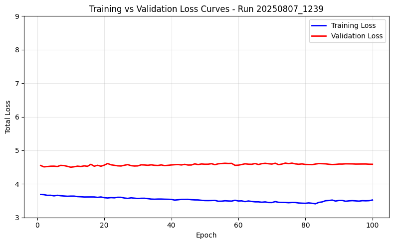

```python
plot_total_loss(str(results_path / 'results.csv'), ylim=(3, 9))
```

Training for an addtional 100 epochs was not really beneficial. Validation loss plateaus more or less straight away.

### 3.3 Single-Phase, in situ (hvrt) + pre-augmented dataset

#### 3.3.1 Mainstream processing, 60:40 imbalance (pre-, hvrt)

Note: In this instance, optimizer=auto selects **SGD** as optimizer for the first time

Create the data .yaml configuration file (overwrites previous .yaml file with the same name):

```python
# Create data configuration
import yaml

data_config = {
    'path':   str(PROJECT_ROOT / 'data'),
    'train':  'train_hvrt_60_40',
    'val':    'val',
    'test':   'test',
    'nc': 2,
    'names':  ['is_vessel', 'is_fishing']
}

# Save to configs directory
yaml_path = CONFIG_DIR / 'sar_data_aug.yaml'
with open(yaml_path, 'w') as f:
    yaml.dump(data_config, f)
```

```python
# Load the model
model = YOLO('yolov8n.pt')
```

```python
# Create a timestamp for the training run
timestamp = datetime.now().strftime('%Y%m%d_%H%M')

# Train the model
results = model.train(
    data=str(yaml_path),
    epochs=100,
    batch=16,
    imgsz=640,
    freeze=None,
    plots=True,
    project=RUNS_DIR / 'train_png_aug',
    name=timestamp,

    # Augmentation parameters
    auto_augment=None,
    hsv_h=0.0,
    hsv_s=0.0,
    hsv_v=0.0,
    translate=0.1,  # transaltion (+/- fraction)
    degrees=15.0,   # rotation (+/- degrees)
    scale=0.0,
    fliplr=0.5,     # horizontal flip (prob)
    flipud=0.5,     # vertical flip (prob.)
    mosaic=0.0
)
```

[output not shown]

```
train: Scanning /home/peterm/UWA/CITS5014/SARFish/modelling/data/train_hvrt_60_40/labels... 7773 images, 0 backgrounds,
```

```
train: New cache created: /home/peterm/UWA/CITS5014/SARFish/modelling/data/train_hvrt_60_40/labels.cache
albumentations: Blur(p=0.01, blur_limit=(3, 7)), MedianBlur(p=0.01, blur_limit=(3, 7)), ToGray(p=0.01, method='weighted_average', num_output_channels=3), CLAHE(p=0.01, clip_limit=(1.0, 4.0), tile_grid_size=(8, 8))
val: Fast image access ✅ (ping: 0.0±0.0 ms, read: 15.0±8.5 MB/s, size: 25.5 KB)
```

```
val: Scanning /home/peterm/UWA/CITS5014/SARFish/modelling/data/val/labels.cache... 463 images, 0 backgrounds, 0 corrupt:
```

```
Plotting labels to /home/peterm/UWA/CITS5014/SARFish/modelling/runs/train_png_aug/20250807_2129/labels.jpg...
optimizer: 'optimizer=auto' found, ignoring 'lr0=0.01' and 'momentum=0.937' and determining best 'optimizer', 'lr0' and 'momentum' automatically...
optimizer: SGD(lr=0.01, momentum=0.9) with parameter groups 57 weight(decay=0.0), 64 weight(decay=0.0005), 63 bias(decay=0.0)
TensorBoard: model graph visualization added ✅
Image sizes 640 train, 640 val
Using 8 dataloader workers
Logging results to /home/peterm/UWA/CITS5014/SARFish/modelling/runs/train_png_aug/20250807_2129
Starting training for 100 epochs...

      Epoch    GPU_mem   box_loss   cls_loss   dfl_loss  Instances       Size
```

```
      1/100      2.51G       2.29       4.21      2.192         13        640: 100%|██████████| 486/486 [01:48<00:00,  4
                 Class     Images  Instances      Box(P          R      mAP50  mAP50-95): 100%|██████████| 15/15 [00:04<
```

```
                   all        463        463      0.515     0.0287    0.00739    0.00181
```

```
      Epoch    GPU_mem   box_loss   cls_loss   dfl_loss  Instances       Size
```

```
      2/100      2.72G      1.891      2.298      1.711         13        640: 100%|██████████| 486/486 [01:39<00:00,  4
                 Class     Images  Instances      Box(P          R      mAP50  mAP50-95): 100%|██████████| 15/15 [00:06<
```

```
                   all        463        463      0.552     0.0634     0.0232    0.00637

      Epoch    GPU_mem   box_loss   cls_loss   dfl_loss  Instances       Size
```

```
      3/100      2.72G      1.861      1.891      1.742         13        640: 100%|██████████| 486/486 [02:15<00:00,  3
                 Class     Images  Instances      Box(P          R      mAP50  mAP50-95): 100%|██████████| 15/15 [00:04<
```

```
                   all        463        463      0.543     0.0861     0.0311    0.00704
```

```
      Epoch    GPU_mem   box_loss   cls_loss   dfl_loss  Instances       Size
```

```
      4/100      2.72G      1.841      1.734      1.745         13        640: 100%|██████████| 486/486 [01:51<00:00,  4
                 Class     Images  Instances      Box(P          R      mAP50  mAP50-95): 100%|██████████| 15/15 [00:06<
```

```
                   all        463        463      0.516     0.0136    0.00414   0.000971
```

```
      Epoch    GPU_mem   box_loss   cls_loss   dfl_loss  Instances       Size
```

```
      5/100      2.72G      1.769      1.663      1.729         13        640: 100%|██████████| 486/486 [02:03<00:00,  3
                 Class     Images  Instances      Box(P          R      mAP50  mAP50-95): 100%|██████████| 15/15 [00:04<
```

```
                   all        463        463     0.0575      0.107     0.0393     0.0107
```

```
      Epoch    GPU_mem   box_loss   cls_loss   dfl_loss  Instances       Size
```

```
      6/100      2.72G      1.714      1.617       1.71         13        640: 100%|██████████| 486/486 [02:14<00:00,  3
                 Class     Images  Instances      Box(P          R      mAP50  mAP50-95): 100%|██████████| 15/15 [00:05<
```

```
                   all        463        463       0.16      0.255      0.104     0.0321
```

```
      Epoch    GPU_mem   box_loss   cls_loss   dfl_loss  Instances       Size
```

```
      7/100      2.72G      1.668      1.586      1.675         13        640: 100%|██████████| 486/486 [01:47<00:00,  4
                 Class     Images  Instances      Box(P          R      mAP50  mAP50-95): 100%|██████████| 15/15 [00:04<
```

```
                   all        463        463      0.102       0.34     0.0817      0.019
```

```
      Epoch    GPU_mem   box_loss   cls_loss   dfl_loss  Instances       Size
```

```
      8/100      2.72G      1.646      1.566      1.683         13        640: 100%|██████████| 486/486 [02:16<00:00,  3
                 Class     Images  Instances      Box(P          R      mAP50  mAP50-95): 100%|██████████| 15/15 [00:05<
```

```
                   all        463        463     0.0859      0.305     0.0861     0.0248
```

```
      Epoch    GPU_mem   box_loss   cls_loss   dfl_loss  Instances       Size
```

```
      9/100      2.72G      1.629      1.542      1.663         13        640: 100%|██████████| 486/486 [01:48<00:00,  4
                 Class     Images  Instances      Box(P          R      mAP50  mAP50-95): 100%|██████████| 15/15 [00:04<
```

```
                   all        463        463      0.193      0.433      0.164     0.0464
```

```
      Epoch    GPU_mem   box_loss   cls_loss   dfl_loss  Instances       Size
```

```
     10/100      2.72G      1.605      1.523      1.649         13        640: 100%|██████████| 486/486 [02:08<00:00,  3
                 Class     Images  Instances      Box(P          R      mAP50  mAP50-95): 100%|██████████| 15/15 [00:06<
```

```
                   all        463        463      0.135      0.404      0.127     0.0366
```

```
      Epoch    GPU_mem   box_loss   cls_loss   dfl_loss  Instances       Size
```

```
     11/100      2.72G       1.59      1.517      1.654         13        640: 100%|██████████| 486/486 [01:24<00:00,  5
                 Class     Images  Instances      Box(P          R      mAP50  mAP50-95): 100%|██████████| 15/15 [00:03<
```

```
                   all        463        463     0.0994      0.253     0.0754     0.0202
```

```
      Epoch    GPU_mem   box_loss   cls_loss   dfl_loss  Instances       Size
```

```
     12/100      2.72G      1.569      1.514      1.629         13        640: 100%|██████████| 486/486 [02:24<00:00,  3
                 Class     Images  Instances      Box(P          R      mAP50  mAP50-95): 100%|██████████| 15/15 [00:04<
```

```
                   all        463        463      0.167      0.405       0.15     0.0449
```

```
      Epoch    GPU_mem   box_loss   cls_loss   dfl_loss  Instances       Size
```

```
     13/100      2.72G      1.562        1.5      1.619         13        640: 100%|██████████| 486/486 [01:56<00:00,  4
                 Class     Images  Instances      Box(P          R      mAP50  mAP50-95): 100%|██████████| 15/15 [00:06<
```

```
                   all        463        463      0.167      0.352      0.125     0.0435
```

```
      Epoch    GPU_mem   box_loss   cls_loss   dfl_loss  Instances       Size
```

```
     14/100      2.72G      1.554      1.488      1.624         13        640: 100%|██████████| 486/486 [01:32<00:00,  5
                 Class     Images  Instances      Box(P          R      mAP50  mAP50-95): 100%|██████████| 15/15 [00:03<
```

```
                   all        463        463      0.611      0.219       0.12     0.0328
```

```
      Epoch    GPU_mem   box_loss   cls_loss   dfl_loss  Instances       Size
```

```
     15/100      2.72G      1.537      1.476      1.595         13        640: 100%|██████████| 486/486 [02:20<00:00,  3
                 Class     Images  Instances      Box(P          R      mAP50  mAP50-95): 100%|██████████| 15/15 [00:03<
```

```
                   all        463        463      0.238      0.325      0.224     0.0602
```

```
      Epoch    GPU_mem   box_loss   cls_loss   dfl_loss  Instances       Size
```

```
     16/100      2.72G      1.533      1.477      1.593         13        640: 100%|██████████| 486/486 [01:38<00:00,  4
                 Class     Images  Instances      Box(P          R      mAP50  mAP50-95): 100%|██████████| 15/15 [00:06<
```

```
                   all        463        463     0.0974      0.331     0.0948     0.0304
```

```
      Epoch    GPU_mem   box_loss   cls_loss   dfl_loss  Instances       Size
```

```
     17/100      2.72G       1.52      1.465      1.587         13        640: 100%|██████████| 486/486 [01:49<00:00,  4
                 Class     Images  Instances      Box(P          R      mAP50  mAP50-95): 100%|██████████| 15/15 [00:03<
```

```
                   all        463        463      0.126      0.297     0.0831     0.0209
```

```
      Epoch    GPU_mem   box_loss   cls_loss   dfl_loss  Instances       Size
```

```
     18/100      2.72G      1.513       1.45      1.587         13        640: 100%|██████████| 486/486 [02:12<00:00,  3
                 Class     Images  Instances      Box(P          R      mAP50  mAP50-95): 100%|██████████| 15/15 [00:06<
```

```
                   all        463        463      0.494      0.156      0.149     0.0399
```

```
      Epoch    GPU_mem   box_loss   cls_loss   dfl_loss  Instances       Size
```

```
     19/100      2.72G      1.506      1.445      1.578         13        640: 100%|██████████| 486/486 [01:19<00:00,  6
                 Class     Images  Instances      Box(P          R      mAP50  mAP50-95): 100%|██████████| 15/15 [00:03<
```

```
                   all        463        463      0.232      0.352      0.249     0.0752
```

```
      Epoch    GPU_mem   box_loss   cls_loss   dfl_loss  Instances       Size
```

```
     20/100      2.72G      1.498      1.437      1.578         13        640: 100%|██████████| 486/486 [02:12<00:00,  3
                 Class     Images  Instances      Box(P          R      mAP50  mAP50-95): 100%|██████████| 15/15 [00:03<
```

```
                   all        463        463      0.174      0.281      0.173      0.048
```

```
      Epoch    GPU_mem   box_loss   cls_loss   dfl_loss  Instances       Size
```

```
     21/100      2.72G      1.484      1.435      1.572         13        640: 100%|██████████| 486/486 [01:51<00:00,  4
                 Class     Images  Instances      Box(P          R      mAP50  mAP50-95): 100%|██████████| 15/15 [00:05<
```

```
                   all        463        463      0.172      0.308      0.176     0.0524
```

```
      Epoch    GPU_mem   box_loss   cls_loss   dfl_loss  Instances       Size
```

```
     22/100      2.72G      1.479      1.434      1.555         13        640: 100%|██████████| 486/486 [01:31<00:00,  5
                 Class     Images  Instances      Box(P          R      mAP50  mAP50-95): 100%|██████████| 15/15 [00:04<
```

```
                   all        463        463      0.178        0.4      0.206     0.0628
```

```
      Epoch    GPU_mem   box_loss   cls_loss   dfl_loss  Instances       Size
```

```
     23/100      2.72G      1.477      1.428      1.554         13        640: 100%|██████████| 486/486 [02:13<00:00,  3
                 Class     Images  Instances      Box(P          R      mAP50  mAP50-95): 100%|██████████| 15/15 [00:03<
```

```
                   all        463        463      0.243      0.359       0.29      0.112
```

```
      Epoch    GPU_mem   box_loss   cls_loss   dfl_loss  Instances       Size
```

```
     24/100      2.72G      1.471      1.417      1.555         13        640: 100%|██████████| 486/486 [01:26<00:00,  5
                 Class     Images  Instances      Box(P          R      mAP50  mAP50-95): 100%|██████████| 15/15 [00:06<
```

```
                   all        463        463      0.305      0.412      0.284     0.0926
```

```
      Epoch    GPU_mem   box_loss   cls_loss   dfl_loss  Instances       Size
```

```
     25/100      2.72G      1.467      1.406       1.55         13        640: 100%|██████████| 486/486 [01:57<00:00,  4
                 Class     Images  Instances      Box(P          R      mAP50  mAP50-95): 100%|██████████| 15/15 [00:03<
```

```
                   all        463        463      0.279      0.377      0.296     0.0966
```

```
      Epoch    GPU_mem   box_loss   cls_loss   dfl_loss  Instances       Size
```

```
     26/100      2.72G      1.454      1.412      1.543         13        640: 100%|██████████| 486/486 [02:06<00:00,  3
                 Class     Images  Instances      Box(P          R      mAP50  mAP50-95): 100%|██████████| 15/15 [00:06<
```

```
                   all        463        463      0.357      0.424      0.382      0.152
```

```
      Epoch    GPU_mem   box_loss   cls_loss   dfl_loss  Instances       Size
```

```
     27/100      2.72G      1.459      1.402      1.538         13        640: 100%|██████████| 486/486 [01:40<00:00,  4
                 Class     Images  Instances      Box(P          R      mAP50  mAP50-95): 100%|██████████| 15/15 [00:06<
```

```
                   all        463        463       0.23      0.382      0.264     0.0881
```

```
      Epoch    GPU_mem   box_loss   cls_loss   dfl_loss  Instances       Size
```

```
     28/100      2.72G      1.439      1.402      1.524         13        640: 100%|██████████| 486/486 [01:54<00:00,  4
                 Class     Images  Instances      Box(P          R      mAP50  mAP50-95): 100%|██████████| 15/15 [00:04<
```

```
                   all        463        463      0.177      0.418      0.152     0.0628
```

```
      Epoch    GPU_mem   box_loss   cls_loss   dfl_loss  Instances       Size
```

```
     29/100      2.72G      1.439      1.383      1.528         13        640: 100%|██████████| 486/486 [02:14<00:00,  3
                 Class     Images  Instances      Box(P          R      mAP50  mAP50-95): 100%|██████████| 15/15 [00:04<
```

```
                   all        463        463      0.737      0.278      0.308      0.125
```

```
      Epoch    GPU_mem   box_loss   cls_loss   dfl_loss  Instances       Size
```

```
     30/100      2.72G      1.433      1.384      1.523         13        640: 100%|██████████| 486/486 [01:28<00:00,  5
                 Class     Images  Instances      Box(P          R      mAP50  mAP50-95): 100%|██████████| 15/15 [00:06<
```

```
                   all        463        463      0.307      0.402      0.331      0.121
```

```
      Epoch    GPU_mem   box_loss   cls_loss   dfl_loss  Instances       Size
```

```
     31/100      2.72G      1.422      1.378      1.514         13        640: 100%|██████████| 486/486 [02:06<00:00,  3
                 Class     Images  Instances      Box(P          R      mAP50  mAP50-95): 100%|██████████| 15/15 [00:04<
```

```
                   all        463        463      0.237      0.393      0.272     0.0968
```

```
      Epoch    GPU_mem   box_loss   cls_loss   dfl_loss  Instances       Size
```

```
     32/100      2.72G      1.429       1.38      1.523         13        640: 100%|██████████| 486/486 [02:12<00:00,  3
                 Class     Images  Instances      Box(P          R      mAP50  mAP50-95): 100%|██████████| 15/15 [00:05<
```

```
                   all        463        463      0.171      0.389      0.138     0.0461
```

```
      Epoch    GPU_mem   box_loss   cls_loss   dfl_loss  Instances       Size
```

```
     33/100      2.72G      1.414      1.371      1.515         13        640: 100%|██████████| 486/486 [01:34<00:00,  5
                 Class     Images  Instances      Box(P          R      mAP50  mAP50-95): 100%|██████████| 15/15 [00:04<
```

```
                   all        463        463      0.235      0.354      0.255     0.0947
```

```
      Epoch    GPU_mem   box_loss   cls_loss   dfl_loss  Instances       Size
```

```
     34/100      2.72G      1.417      1.361      1.514         13        640: 100%|██████████| 486/486 [02:35<00:00,  3
                 Class     Images  Instances      Box(P          R      mAP50  mAP50-95): 100%|██████████| 15/15 [00:04<
```

```
                   all        463        463      0.164      0.296       0.17     0.0532
```

```
      Epoch    GPU_mem   box_loss   cls_loss   dfl_loss  Instances       Size
```

```
     35/100      2.72G      1.411      1.362      1.502         13        640: 100%|██████████| 486/486 [01:25<00:00,  5
                 Class     Images  Instances      Box(P          R      mAP50  mAP50-95): 100%|██████████| 15/15 [00:03<
```

```
                   all        463        463      0.295        0.4      0.279     0.0966
```

```
      Epoch    GPU_mem   box_loss   cls_loss   dfl_loss  Instances       Size
```

```
     36/100      2.72G      1.411      1.357      1.503         13        640: 100%|██████████| 486/486 [02:22<00:00,  3
                 Class     Images  Instances      Box(P          R      mAP50  mAP50-95): 100%|██████████| 15/15 [00:04<
```

```
                   all        463        463      0.133      0.407      0.184     0.0658
```

```
      Epoch    GPU_mem   box_loss   cls_loss   dfl_loss  Instances       Size
```

```
     37/100      2.72G        1.4       1.35      1.503         13        640: 100%|██████████| 486/486 [01:30<00:00,  5
                 Class     Images  Instances      Box(P          R      mAP50  mAP50-95): 100%|██████████| 15/15 [00:05<
```

```
                   all        463        463      0.348      0.274      0.264     0.0923
```

```
      Epoch    GPU_mem   box_loss   cls_loss   dfl_loss  Instances       Size
```

```
     38/100      2.72G      1.399      1.341      1.495         13        640: 100%|██████████| 486/486 [02:20<00:00,  3
                 Class     Images  Instances      Box(P          R      mAP50  mAP50-95): 100%|██████████| 15/15 [00:05<
```

```
                   all        463        463      0.291      0.298      0.221     0.0766
```

```
      Epoch    GPU_mem   box_loss   cls_loss   dfl_loss  Instances       Size
```

```
     39/100      2.72G       1.39      1.339       1.49         13        640: 100%|██████████| 486/486 [01:30<00:00,  5
                 Class     Images  Instances      Box(P          R      mAP50  mAP50-95): 100%|██████████| 15/15 [00:05<
```

```
                   all        463        463      0.301      0.335      0.275     0.0962
```

```
      Epoch    GPU_mem   box_loss   cls_loss   dfl_loss  Instances       Size
```

```
     40/100      2.72G       1.39      1.329      1.488         13        640: 100%|██████████| 486/486 [02:16<00:00,  3
                 Class     Images  Instances      Box(P          R      mAP50  mAP50-95): 100%|██████████| 15/15 [00:03<
```

```
                   all        463        463      0.307      0.461      0.331       0.12
```

```
      Epoch    GPU_mem   box_loss   cls_loss   dfl_loss  Instances       Size
```

```
     41/100      2.72G      1.381      1.327      1.484         13        640: 100%|██████████| 486/486 [01:57<00:00,  4
                 Class     Images  Instances      Box(P          R      mAP50  mAP50-95): 100%|██████████| 15/15 [00:06<
```

```
                   all        463        463      0.288      0.384      0.287      0.109
```

```
      Epoch    GPU_mem   box_loss   cls_loss   dfl_loss  Instances       Size
```

```
     42/100      2.72G      1.376      1.321      1.481         13        640: 100%|██████████| 486/486 [01:47<00:00,  4
                 Class     Images  Instances      Box(P          R      mAP50  mAP50-95): 100%|██████████| 15/15 [00:03<
```

```
                   all        463        463      0.189      0.487      0.221     0.0782
```

```
      Epoch    GPU_mem   box_loss   cls_loss   dfl_loss  Instances       Size
```

```
     43/100      2.72G       1.38      1.312      1.479         13        640: 100%|██████████| 486/486 [02:19<00:00,  3
                 Class     Images  Instances      Box(P          R      mAP50  mAP50-95): 100%|██████████| 15/15 [00:04<
```

```
                   all        463        463      0.156      0.418      0.153     0.0576
```

```
      Epoch    GPU_mem   box_loss   cls_loss   dfl_loss  Instances       Size
```

```
     44/100      2.72G      1.371      1.316      1.476         13        640: 100%|██████████| 486/486 [01:39<00:00,  4
                 Class     Images  Instances      Box(P          R      mAP50  mAP50-95): 100%|██████████| 15/15 [00:06<
```

```
                   all        463        463      0.169      0.244      0.137     0.0462
```

```
      Epoch    GPU_mem   box_loss   cls_loss   dfl_loss  Instances       Size
```

```
     45/100      2.72G      1.361      1.296      1.471         13        640: 100%|██████████| 486/486 [02:09<00:00,  3
                 Class     Images  Instances      Box(P          R      mAP50  mAP50-95): 100%|██████████| 15/15 [00:04<
```

```
                   all        463        463      0.193      0.364      0.173     0.0653
```

```
      Epoch    GPU_mem   box_loss   cls_loss   dfl_loss  Instances       Size
```

```
     46/100      2.72G      1.367      1.294      1.473         13        640: 100%|██████████| 486/486 [02:01<00:00,  4
                 Class     Images  Instances      Box(P          R      mAP50  mAP50-95): 100%|██████████| 15/15 [00:05<
```

```
                   all        463        463      0.295       0.34       0.22     0.0685
```

```
      Epoch    GPU_mem   box_loss   cls_loss   dfl_loss  Instances       Size
```

```
     47/100      2.72G      1.356       1.29      1.464         13        640: 100%|██████████| 486/486 [01:55<00:00,  4
                 Class     Images  Instances      Box(P          R      mAP50  mAP50-95): 100%|██████████| 15/15 [00:04<
```

```
                   all        463        463       0.32      0.465      0.309       0.11
```

```
      Epoch    GPU_mem   box_loss   cls_loss   dfl_loss  Instances       Size
```

```
     48/100      2.72G      1.354      1.286      1.457         13        640: 100%|██████████| 486/486 [02:14<00:00,  3
                 Class     Images  Instances      Box(P          R      mAP50  mAP50-95): 100%|██████████| 15/15 [00:06<
```

```
                   all        463        463      0.105       0.45      0.109     0.0374
```

```
      Epoch    GPU_mem   box_loss   cls_loss   dfl_loss  Instances       Size
```

```
     49/100      2.72G      1.354      1.273      1.462         13        640: 100%|██████████| 486/486 [01:46<00:00,  4
                 Class     Images  Instances      Box(P          R      mAP50  mAP50-95): 100%|██████████| 15/15 [00:06<
```

```
                   all        463        463      0.157       0.36      0.134     0.0478
```

```
      Epoch    GPU_mem   box_loss   cls_loss   dfl_loss  Instances       Size
```

```
     50/100      2.72G      1.352      1.269      1.459         13        640: 100%|██████████| 486/486 [02:34<00:00,  3
                 Class     Images  Instances      Box(P          R      mAP50  mAP50-95): 100%|██████████| 15/15 [00:04<
```

```
                   all        463        463      0.145      0.495      0.138     0.0479
```

```
      Epoch    GPU_mem   box_loss   cls_loss   dfl_loss  Instances       Size
```

```
     51/100      2.72G      1.334      1.273      1.442         13        640: 100%|██████████| 486/486 [01:55<00:00,  4
                 Class     Images  Instances      Box(P          R      mAP50  mAP50-95): 100%|██████████| 15/15 [00:06<
```

```
                   all        463        463      0.219      0.421      0.229     0.0726
```

```
      Epoch    GPU_mem   box_loss   cls_loss   dfl_loss  Instances       Size
```

```
     52/100      2.72G      1.344      1.264      1.452         13        640: 100%|██████████| 486/486 [02:45<00:00,  2
                 Class     Images  Instances      Box(P          R      mAP50  mAP50-95): 100%|██████████| 15/15 [00:03<
```

```
                   all        463        463      0.205      0.508      0.253      0.098
```

```
      Epoch    GPU_mem   box_loss   cls_loss   dfl_loss  Instances       Size
```

```
     53/100      2.72G       1.34      1.252      1.449         13        640: 100%|██████████| 486/486 [01:49<00:00,  4
                 Class     Images  Instances      Box(P          R      mAP50  mAP50-95): 100%|██████████| 15/15 [00:06<
```

```
                   all        463        463      0.365      0.457      0.335      0.127
```

```
      Epoch    GPU_mem   box_loss   cls_loss   dfl_loss  Instances       Size
```

```
     54/100      2.72G      1.332      1.258      1.444         13        640: 100%|██████████| 486/486 [02:39<00:00,  3
                 Class     Images  Instances      Box(P          R      mAP50  mAP50-95): 100%|██████████| 15/15 [00:03<
```

```
                   all        463        463      0.326      0.369      0.264     0.0894
```

```
      Epoch    GPU_mem   box_loss   cls_loss   dfl_loss  Instances       Size
```

```
     55/100      2.72G      1.332      1.233      1.443         13        640: 100%|██████████| 486/486 [01:50<00:00,  4
                 Class     Images  Instances      Box(P          R      mAP50  mAP50-95): 100%|██████████| 15/15 [00:06<
```

```
                   all        463        463      0.342      0.402      0.301      0.104
```

```
      Epoch    GPU_mem   box_loss   cls_loss   dfl_loss  Instances       Size
```

```
     56/100      2.72G      1.328      1.234       1.44         13        640: 100%|██████████| 486/486 [02:43<00:00,  2
                 Class     Images  Instances      Box(P          R      mAP50  mAP50-95): 100%|██████████| 15/15 [00:03<
```

```
                   all        463        463      0.241      0.455      0.214     0.0743
```

```
      Epoch    GPU_mem   box_loss   cls_loss   dfl_loss  Instances       Size
```

```
     57/100      2.72G      1.318      1.223      1.431         13        640: 100%|██████████| 486/486 [01:53<00:00,  4
                 Class     Images  Instances      Box(P          R      mAP50  mAP50-95): 100%|██████████| 15/15 [00:05<
```

```
                   all        463        463      0.232      0.488      0.208     0.0679
```

```
      Epoch    GPU_mem   box_loss   cls_loss   dfl_loss  Instances       Size
```

```
     58/100      2.72G      1.307      1.217      1.422         13        640: 100%|██████████| 486/486 [02:58<00:00,  2
                 Class     Images  Instances      Box(P          R      mAP50  mAP50-95): 100%|██████████| 15/15 [00:05<
```

```
                   all        463        463      0.286      0.335      0.258     0.0838
```

```
      Epoch    GPU_mem   box_loss   cls_loss   dfl_loss  Instances       Size
```

```
     59/100      2.72G      1.311      1.211      1.425         13        640: 100%|██████████| 486/486 [01:43<00:00,  4
                 Class     Images  Instances      Box(P          R      mAP50  mAP50-95): 100%|██████████| 15/15 [00:06<
```

```
                   all        463        463      0.362       0.42      0.328      0.117
```

```
      Epoch    GPU_mem   box_loss   cls_loss   dfl_loss  Instances       Size
```

```
     60/100      2.72G        1.3      1.208      1.418         13        640: 100%|██████████| 486/486 [02:58<00:00,  2
                 Class     Images  Instances      Box(P          R      mAP50  mAP50-95): 100%|██████████| 15/15 [00:05<
```

```
                   all        463        463      0.311      0.312      0.202     0.0578
```

```
      Epoch    GPU_mem   box_loss   cls_loss   dfl_loss  Instances       Size
```

```
     61/100      2.72G      1.299      1.194      1.414         13        640: 100%|██████████| 486/486 [01:46<00:00,  4
                 Class     Images  Instances      Box(P          R      mAP50  mAP50-95): 100%|██████████| 15/15 [00:06<
```

```
                   all        463        463      0.285      0.211      0.167     0.0514
```

```
      Epoch    GPU_mem   box_loss   cls_loss   dfl_loss  Instances       Size
```

```
     62/100      2.72G      1.282      1.182      1.412         13        640: 100%|██████████| 486/486 [02:57<00:00,  2
                 Class     Images  Instances      Box(P          R      mAP50  mAP50-95): 100%|██████████| 15/15 [00:05<
```

```
                   all        463        463      0.319      0.379      0.236     0.0773
```

```
      Epoch    GPU_mem   box_loss   cls_loss   dfl_loss  Instances       Size
```

```
     63/100      2.72G      1.296      1.179      1.417         13        640: 100%|██████████| 486/486 [01:44<00:00,  4
                 Class     Images  Instances      Box(P          R      mAP50  mAP50-95): 100%|██████████| 15/15 [00:05<
```

```
                   all        463        463      0.169      0.235      0.128     0.0411
```

```
      Epoch    GPU_mem   box_loss   cls_loss   dfl_loss  Instances       Size
```

```
     64/100      2.72G      1.282      1.177      1.407         13        640: 100%|██████████| 486/486 [02:58<00:00,  2
                 Class     Images  Instances      Box(P          R      mAP50  mAP50-95): 100%|██████████| 15/15 [00:06<
```

```
                   all        463        463      0.248      0.219      0.154     0.0516
```

```
      Epoch    GPU_mem   box_loss   cls_loss   dfl_loss  Instances       Size
```

```
     65/100      2.72G      1.281      1.163      1.405         13        640: 100%|██████████| 486/486 [02:56<00:00,  2
                 Class     Images  Instances      Box(P          R      mAP50  mAP50-95): 100%|██████████| 15/15 [00:04<
```

```
                   all        463        463      0.333      0.386      0.274     0.0933
```

```
      Epoch    GPU_mem   box_loss   cls_loss   dfl_loss  Instances       Size
```

```
     66/100      2.72G      1.275      1.156        1.4         13        640: 100%|██████████| 486/486 [01:45<00:00,  4
                 Class     Images  Instances      Box(P          R      mAP50  mAP50-95): 100%|██████████| 15/15 [00:06<
```

```
                   all        463        463      0.271      0.294       0.17     0.0518
```

```
      Epoch    GPU_mem   box_loss   cls_loss   dfl_loss  Instances       Size
```

```
     67/100      2.72G      1.266      1.143      1.399         13        640: 100%|██████████| 486/486 [02:58<00:00,  2
                 Class     Images  Instances      Box(P          R      mAP50  mAP50-95): 100%|██████████| 15/15 [00:06<
```

```
                   all        463        463     0.0367      0.466      0.063     0.0186
```

```
      Epoch    GPU_mem   box_loss   cls_loss   dfl_loss  Instances       Size
```

```
     68/100      2.72G      1.272      1.136      1.399         13        640: 100%|██████████| 486/486 [02:56<00:00,  2
                 Class     Images  Instances      Box(P          R      mAP50  mAP50-95): 100%|██████████| 15/15 [00:05<
```

```
                   all        463        463     0.0481      0.645     0.0922     0.0292
```

```
      Epoch    GPU_mem   box_loss   cls_loss   dfl_loss  Instances       Size
```

```
     69/100      2.72G      1.266      1.132      1.391         13        640: 100%|██████████| 486/486 [02:58<00:00,  2
                 Class     Images  Instances      Box(P          R      mAP50  mAP50-95): 100%|██████████| 15/15 [00:06<
```

```
                   all        463        463     0.0769      0.436     0.0974     0.0288
```

```
      Epoch    GPU_mem   box_loss   cls_loss   dfl_loss  Instances       Size
```

```
     70/100      2.72G      1.249       1.12      1.382         13        640: 100%|██████████| 486/486 [02:57<00:00,  2
                 Class     Images  Instances      Box(P          R      mAP50  mAP50-95): 100%|██████████| 15/15 [00:06<
```

```
                   all        463        463     0.0614      0.431      0.092     0.0279

      Epoch    GPU_mem   box_loss   cls_loss   dfl_loss  Instances       Size
```

```
     71/100      2.72G      1.249      1.118      1.377         13        640: 100%|██████████| 486/486 [02:58<00:00,  2
                 Class     Images  Instances      Box(P          R      mAP50  mAP50-95): 100%|██████████| 15/15 [00:05<
```

```
                   all        463        463     0.0434      0.312     0.0545     0.0163
```

```
      Epoch    GPU_mem   box_loss   cls_loss   dfl_loss  Instances       Size
```

```
     72/100      2.72G      1.249      1.106      1.385         13        640: 100%|██████████| 486/486 [02:58<00:00,  2
                 Class     Images  Instances      Box(P          R      mAP50  mAP50-95): 100%|██████████| 15/15 [00:06<
```

```
                   all        463        463     0.0475      0.328     0.0628     0.0181
```

```
      Epoch    GPU_mem   box_loss   cls_loss   dfl_loss  Instances       Size
```

```
     73/100      2.72G      1.235      1.096      1.369         13        640: 100%|██████████| 486/486 [02:58<00:00,  2
                 Class     Images  Instances      Box(P          R      mAP50  mAP50-95): 100%|██████████| 15/15 [00:05<
```

```
                   all        463        463     0.0407      0.275     0.0532     0.0147
```

```
      Epoch    GPU_mem   box_loss   cls_loss   dfl_loss  Instances       Size
```

```
     74/100      2.72G      1.228      1.089      1.366         13        640: 100%|██████████| 486/486 [02:59<00:00,  2
                 Class     Images  Instances      Box(P          R      mAP50  mAP50-95): 100%|██████████| 15/15 [00:05<
```

```
                   all        463        463      0.163      0.322      0.121     0.0362
```

```
      Epoch    GPU_mem   box_loss   cls_loss   dfl_loss  Instances       Size
```

```
     75/100      2.72G      1.222      1.069      1.363         13        640: 100%|██████████| 486/486 [02:57<00:00,  2
                 Class     Images  Instances      Box(P          R      mAP50  mAP50-95): 100%|██████████| 15/15 [00:05<
```

```
                   all        463        463      0.275       0.26      0.173     0.0518
```

```
      Epoch    GPU_mem   box_loss   cls_loss   dfl_loss  Instances       Size
```

```
     76/100      2.72G      1.224      1.067      1.362         13        640: 100%|██████████| 486/486 [01:50<00:00,  4
                 Class     Images  Instances      Box(P          R      mAP50  mAP50-95): 100%|██████████| 15/15 [00:05<
```

```
                   all        463        463      0.263      0.251      0.167     0.0509
```

```
      Epoch    GPU_mem   box_loss   cls_loss   dfl_loss  Instances       Size
```

```
     77/100      2.72G      1.212      1.053      1.356         13        640: 100%|██████████| 486/486 [02:57<00:00,  2
                 Class     Images  Instances      Box(P          R      mAP50  mAP50-95): 100%|██████████| 15/15 [00:05<
```

```
                   all        463        463      0.279      0.234       0.18     0.0554
```

```
      Epoch    GPU_mem   box_loss   cls_loss   dfl_loss  Instances       Size
```

```
     78/100      2.72G       1.21      1.048      1.352         13        640: 100%|██████████| 486/486 [01:50<00:00,  4
                 Class     Images  Instances      Box(P          R      mAP50  mAP50-95): 100%|██████████| 15/15 [00:05<
```

```
                   all        463        463      0.316      0.266      0.204     0.0631
```

```
      Epoch    GPU_mem   box_loss   cls_loss   dfl_loss  Instances       Size
```

```
     79/100      2.72G      1.204      1.035      1.349         13        640: 100%|██████████| 486/486 [02:44<00:00,  2
                 Class     Images  Instances      Box(P          R      mAP50  mAP50-95): 100%|██████████| 15/15 [00:03<
```

```
                   all        463        463        0.3       0.25      0.203     0.0605
```

```
      Epoch    GPU_mem   box_loss   cls_loss   dfl_loss  Instances       Size
```

```
     80/100      2.72G      1.202      1.031      1.348         13        640: 100%|██████████| 486/486 [01:46<00:00,  4
                 Class     Images  Instances      Box(P          R      mAP50  mAP50-95): 100%|██████████| 15/15 [00:05<
```

```
                   all        463        463      0.102       0.41      0.155     0.0442
```

```
      Epoch    GPU_mem   box_loss   cls_loss   dfl_loss  Instances       Size
```

```
     81/100      2.72G       1.19      1.023      1.338         13        640: 100%|██████████| 486/486 [02:41<00:00,  3
                 Class     Images  Instances      Box(P          R      mAP50  mAP50-95): 100%|██████████| 15/15 [00:03<
```

```
                   all        463        463      0.121      0.322      0.144     0.0425
```

```
      Epoch    GPU_mem   box_loss   cls_loss   dfl_loss  Instances       Size
```

```
     82/100      2.72G      1.187      1.018      1.332         13        640: 100%|██████████| 486/486 [01:57<00:00,  4
                 Class     Images  Instances      Box(P          R      mAP50  mAP50-95): 100%|██████████| 15/15 [00:06<
```

```
                   all        463        463       0.21      0.275      0.161     0.0454
```

```
      Epoch    GPU_mem   box_loss   cls_loss   dfl_loss  Instances       Size
```

```
     83/100      2.72G      1.182      1.003       1.33         13        640: 100%|██████████| 486/486 [01:55<00:00,  4
                 Class     Images  Instances      Box(P          R      mAP50  mAP50-95): 100%|██████████| 15/15 [00:04<
```

```
                   all        463        463      0.288      0.217      0.167     0.0479
```

```
      Epoch    GPU_mem   box_loss   cls_loss   dfl_loss  Instances       Size
```

```
     84/100      2.72G      1.165     0.9935      1.324         13        640: 100%|██████████| 486/486 [02:37<00:00,  3
                 Class     Images  Instances      Box(P          R      mAP50  mAP50-95): 100%|██████████| 15/15 [00:06<
```

```
                   all        463        463      0.302      0.238      0.185     0.0539

      Epoch    GPU_mem   box_loss   cls_loss   dfl_loss  Instances       Size
```

```
     85/100      2.72G      1.165     0.9809      1.322         13        640: 100%|██████████| 486/486 [01:39<00:00,  4
                 Class     Images  Instances      Box(P          R      mAP50  mAP50-95): 100%|██████████| 15/15 [00:06<
```

```
                   all        463        463      0.125      0.399       0.17     0.0477
```

```
      Epoch    GPU_mem   box_loss   cls_loss   dfl_loss  Instances       Size
```

```
     86/100      2.72G      1.162     0.9801      1.317         13        640: 100%|██████████| 486/486 [02:22<00:00,  3
                 Class     Images  Instances      Box(P          R      mAP50  mAP50-95): 100%|██████████| 15/15 [00:03<
```

```
                   all        463        463      0.138      0.402      0.175     0.0514
```

```
      Epoch    GPU_mem   box_loss   cls_loss   dfl_loss  Instances       Size
```

```
     87/100      2.72G      1.155     0.9702      1.314         13        640: 100%|██████████| 486/486 [02:12<00:00,  3
                 Class     Images  Instances      Box(P          R      mAP50  mAP50-95): 100%|██████████| 15/15 [00:05<
```

```
                   all        463        463      0.136      0.374       0.17     0.0471
```

```
      Epoch    GPU_mem   box_loss   cls_loss   dfl_loss  Instances       Size
```

```
     88/100      2.72G      1.153     0.9596       1.31         13        640: 100%|██████████| 486/486 [01:40<00:00,  4
                 Class     Images  Instances      Box(P          R      mAP50  mAP50-95): 100%|██████████| 15/15 [00:06<
```

```
                   all        463        463      0.117      0.296      0.143     0.0366
```

```
      Epoch    GPU_mem   box_loss   cls_loss   dfl_loss  Instances       Size
```

```
     89/100      2.72G      1.135     0.9505      1.298         13        640: 100%|██████████| 486/486 [02:20<00:00,  3
                 Class     Images  Instances      Box(P          R      mAP50  mAP50-95): 100%|██████████| 15/15 [00:03<
```

```
                   all        463        463      0.109      0.243      0.124     0.0299
```

```
      Epoch    GPU_mem   box_loss   cls_loss   dfl_loss  Instances       Size
```

```
     90/100      2.72G      1.139     0.9462      1.304         13        640: 100%|██████████| 486/486 [02:11<00:00,  3
                 Class     Images  Instances      Box(P          R      mAP50  mAP50-95): 100%|██████████| 15/15 [00:05<
```

```
                   all        463        463      0.104      0.208       0.11     0.0264
```

```
Closing dataloader mosaic
albumentations: Blur(p=0.01, blur_limit=(3, 7)), MedianBlur(p=0.01, blur_limit=(3, 7)), ToGray(p=0.01, method='weighted_average', num_output_channels=3), CLAHE(p=0.01, clip_limit=(1.0, 4.0), tile_grid_size=(8, 8))

      Epoch    GPU_mem   box_loss   cls_loss   dfl_loss  Instances       Size
```

```
     91/100      2.72G      1.123     0.9345      1.293         13        640: 100%|██████████| 486/486 [01:33<00:00,  5
                 Class     Images  Instances      Box(P          R      mAP50  mAP50-95): 100%|██████████| 15/15 [00:05<
```

```
                   all        463        463      0.101      0.188     0.0994     0.0249
```

```
      Epoch    GPU_mem   box_loss   cls_loss   dfl_loss  Instances       Size
```

```
     92/100      2.72G      1.124     0.9264      1.295         13        640: 100%|██████████| 486/486 [02:10<00:00,  3
                 Class     Images  Instances      Box(P          R      mAP50  mAP50-95): 100%|██████████| 15/15 [00:03<
```

```
                   all        463        463     0.0828      0.141     0.0809     0.0198
```

```
      Epoch    GPU_mem   box_loss   cls_loss   dfl_loss  Instances       Size
```

```
     93/100      2.72G      1.115      0.922      1.287         13        640: 100%|██████████| 486/486 [02:15<00:00,  3
                 Class     Images  Instances      Box(P          R      mAP50  mAP50-95): 100%|██████████| 15/15 [00:05<
```

```
                   all        463        463     0.0902      0.154     0.0951     0.0227
```

```
      Epoch    GPU_mem   box_loss   cls_loss   dfl_loss  Instances       Size
```

```
     94/100      2.72G      1.107     0.9091      1.282         13        640: 100%|██████████| 486/486 [01:30<00:00,  5
                 Class     Images  Instances      Box(P          R      mAP50  mAP50-95): 100%|██████████| 15/15 [00:05<
```

```
                   all        463        463     0.0878      0.157     0.0933     0.0221
```

```
      Epoch    GPU_mem   box_loss   cls_loss   dfl_loss  Instances       Size
```

```
     95/100      2.72G      1.105     0.9091      1.282         13        640: 100%|██████████| 486/486 [02:13<00:00,  3
                 Class     Images  Instances      Box(P          R      mAP50  mAP50-95): 100%|██████████| 15/15 [00:03<
```

```
                   all        463        463     0.0832      0.151     0.0896      0.021
```

```
      Epoch    GPU_mem   box_loss   cls_loss   dfl_loss  Instances       Size
```

```
     96/100      2.72G      1.101     0.9009      1.277         13        640: 100%|██████████| 486/486 [02:10<00:00,  3
                 Class     Images  Instances      Box(P          R      mAP50  mAP50-95): 100%|██████████| 15/15 [00:05<
```

```
                   all        463        463     0.0764      0.153     0.0843     0.0196
```

```
      Epoch    GPU_mem   box_loss   cls_loss   dfl_loss  Instances       Size
```

```
     97/100      2.72G      1.094     0.8944      1.274         13        640: 100%|██████████| 486/486 [01:33<00:00,  5
                 Class     Images  Instances      Box(P          R      mAP50  mAP50-95): 100%|██████████| 15/15 [00:05<
```

```
                   all        463        463      0.127      0.101     0.0799     0.0179
```

```
      Epoch    GPU_mem   box_loss   cls_loss   dfl_loss  Instances       Size
```

```
     98/100      2.72G      1.086     0.8893      1.271         13        640: 100%|██████████| 486/486 [02:04<00:00,  3
                 Class     Images  Instances      Box(P          R      mAP50  mAP50-95): 100%|██████████| 15/15 [00:04<
```

```
                   all        463        463     0.0617      0.132     0.0705     0.0162
```

```
      Epoch    GPU_mem   box_loss   cls_loss   dfl_loss  Instances       Size
```

```
     99/100      2.72G      1.085     0.8878       1.27         13        640: 100%|██████████| 486/486 [02:14<00:00,  3
                 Class     Images  Instances      Box(P          R      mAP50  mAP50-95): 100%|██████████| 15/15 [00:05<
```

```
                   all        463        463     0.0613      0.131      0.069     0.0156
```

```
      Epoch    GPU_mem   box_loss   cls_loss   dfl_loss  Instances       Size
```

```
    100/100      2.72G      1.078     0.8805      1.262         13        640: 100%|██████████| 486/486 [01:34<00:00,  5
                 Class     Images  Instances      Box(P          R      mAP50  mAP50-95): 100%|██████████| 15/15 [00:05<
```

```
                   all        463        463      0.197     0.0869     0.0758     0.0159
```

```
100 epochs completed in 3.719 hours.
Optimizer stripped from /home/peterm/UWA/CITS5014/SARFish/modelling/runs/train_png_aug/20250807_2129/weights/last.pt, 6.3MB
Optimizer stripped from /home/peterm/UWA/CITS5014/SARFish/modelling/runs/train_png_aug/20250807_2129/weights/best.pt, 6.3MB

Validating /home/peterm/UWA/CITS5014/SARFish/modelling/runs/train_png_aug/20250807_2129/weights/best.pt...
Ultralytics 8.3.152 🚀 Python-3.10.12 torch-2.6.0+cu124 CUDA:0 (NVIDIA RTX 2000 Ada Generation Laptop GPU, 8188MiB)
Model summary (fused): 72 layers, 3,006,038 parameters, 0 gradients, 8.1 GFLOPs
```

```
                 Class     Images  Instances      Box(P          R      mAP50  mAP50-95): 100%|██████████| 15/15 [00:06<
```

```
                   all        463        463      0.355       0.42       0.38      0.152
             is_vessel        331        331       0.46      0.583       0.56      0.224
            is_fishing        132        132      0.249      0.258      0.201     0.0799
Speed: 0.4ms preprocess, 6.0ms inference, 0.0ms loss, 2.4ms postprocess per image
Results saved to /home/peterm/UWA/CITS5014/SARFish/modelling/runs/train_png_aug/20250807_2129
```

Poor result, despite a larger dataset. Now try alternative processing on the same dataset

```python
results_path = RUNS_DIR / 'train_png_aug' / '20250807_2129'
```

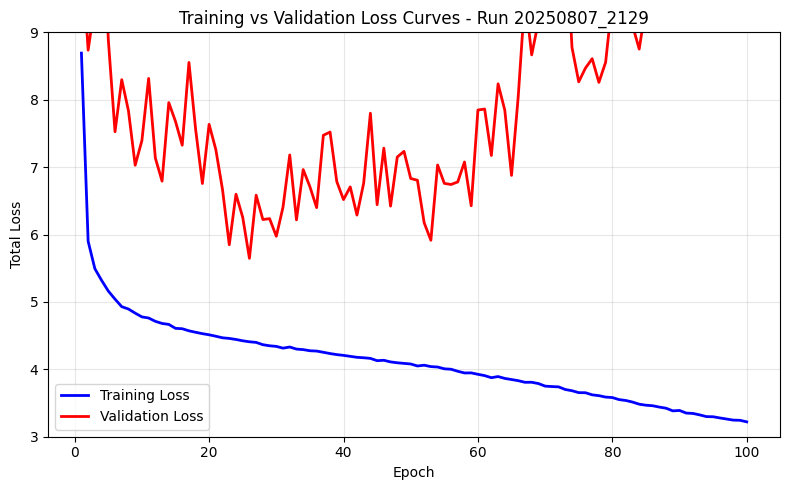

```python
plot_total_loss(str(results_path / 'results.csv'), ylim=(3, 9))
```

Poor result. Mainstream processing even with augmentation performs badly.

#### 3.3.2 Alternative processing, 60:40 imbalance (pre-, hvrt)

Note: Optimizer=auto has selected **SGD** as optimizer again

Create the data .yaml configuration file (overwrites previous .yaml file with the same name):

```python
# Create data configuration
import yaml

data_config = {
    'path':   str(PROJECT_ROOT / 'data'),
    'train':  'train_hvrt_60_40_alt',
    'val':    'val_alt',
    'test':   'test_alt',
    'nc': 2,
    'names': ['is_vessel', 'is_fishing']
}

# Save to configs directory
yaml_path = CONFIG_DIR / 'sar_data_aug_alt.yaml'
with open(yaml_path, 'w') as f:
    yaml.dump(data_config, f)
```

```python
# Load the model
model = YOLO('yolov8n.pt')
```

```python
# Create a timestamp for the training run
timestamp = datetime.now().strftime('%Y%m%d_%H%M')

# Train the model
results = model.train(
    data=str(yaml_path),
    epochs=100,
    batch=16,
    imgsz=640,
    freeze=None,
    plots=True,
    project=RUNS_DIR / 'train_png_aug_alt',
    name=timestamp,

    # Augmentation parameters
    auto_augment=None,
    hsv_h=0.0,
    hsv_s=0.0,
    hsv_v=0.0,
    translate=0.1,  # transaltion (+/- fraction)
    degrees=15.0,   # rotation (+/- degrees)
    scale=0.0,
    fliplr=0.5,     # horizontal flip (prob)
    flipud=0.5,     # vertical flip (prob.)
    mosaic=0.0
)
```

```
New https://pypi.org/project/ultralytics/8.3.176 available 😃 Update with 'pip install -U ultralytics'
Ultralytics 8.3.152 🚀 Python-3.10.12 torch-2.6.0+cu124 CUDA:0 (NVIDIA RTX 2000 Ada Generation Laptop GPU, 8188MiB)
engine/trainer: agnostic_nms=False, amp=True, augment=False, auto_augment=None, batch=16, bgr=0.0, box=7.5, cache=False, cfg=None, classes=None, close_mosaic=10, cls=0.5, conf=None, copy_paste=0.0, copy_paste_mode=flip, cos_lr=False, cutmix=0.0, data=/home/peterm/UWA/CITS5014/SARFish/modelling/confi…
Overriding model.yaml nc=80 with nc=2

                   from  n    params  module                                       arguments
  0                  -1  1       464  ultralytics.nn.modules.conv.Conv             [3, 16, 3, 2]
  1                  -1  1      4672  ultralytics.nn.modules.conv.Conv             [16, 32, 3, 2]
  2                  -1  1      7360  ultralytics.nn.modules.block.C2f             [32, 32, 1, True]
  3                  -1  1     18560  ultralytics.nn.modules.conv.Conv             [32, 64, 3, 2]
  4                  -1  2     49664  ultralytics.nn.modules.block.C2f             [64, 64, 2, True]
  5                  -1  1     73984  ultralytics.nn.modules.conv.Conv             [64, 128, 3, 2]
  6                  -1  2    197632  ultralytics.nn.modules.block.C2f             [128, 128, 2, True]
  7                  -1  1    295424  ultralytics.nn.modules.conv.Conv             [128, 256, 3, 2]
  8                  -1  1    460288  ultralytics.nn.modules.block.C2f             [256, 256, 1, True]
  9                  -1  1    164608  ultralytics.nn.modules.block.SPPF            [256, 256, 5]
 10                  -1  1         0  torch.nn.modules.upsampling.Upsample         [None, 2, 'nearest']
 11             [-1, 6]  1         0  ultralytics.nn.modules.conv.Concat           [1]
 12                  -1  1    148224  ultralytics.nn.modules.block.C2f             [384, 128, 1]
 13                  -1  1         0  torch.nn.modules.upsampling.Upsample         [None, 2, 'nearest']
 14             [-1, 4]  1         0  ultralytics.nn.modules.conv.Concat           [1]
 15                  -1  1     37248  ultralytics.nn.modules.block.C2f             [192, 64, 1]
 16                  -1  1     36992  ultralytics.nn.modules.conv.Conv             [64, 64, 3, 2]
 17            [-1, 12]  1         0  ultralytics.nn.modules.conv.Concat           [1]
 18                  -1  1    123648  ultralytics.nn.modules.block.C2f             [192, 128, 1]
 19                  -1  1    147712  ultralytics.nn.modules.conv.Conv             [128, 128, 3, 2]
 20             [-1, 9]  1         0  ultralytics.nn.modules.conv.Concat           [1]
 21                  -1  1    493056  ultralytics.nn.modules.block.C2f             [384, 256, 1]
 22        [15, 18, 21]  1    751702  ultralytics.nn.modules.head.Detect           [2, [64, 128, 256]]
Model summary: 129 layers, 3,011,238 parameters, 3,011,222 gradients, 8.2 GFLOPs

Transferred 319/355 items from pretrained weights
TensorBoard: Start with 'tensorboard --logdir /home/peterm/UWA/CITS5014/SARFish/modelling/runs/train_png_aug_alt/20250808_1712', view at http://localhost:6006/
Freezing layer 'model.22.dfl.conv.weight'
AMP: running Automatic Mixed Precision (AMP) checks...
AMP: checks passed ✅
train: Fast image access ✅ (ping: 0.0±0.0 ms, read: 1476.1±825.7 MB/s, size: 20.3 KB)
```

```
train: Scanning /home/peterm/UWA/CITS5014/SARFish/modelling/data/train_hvrt_60_40_alt/labels.cache... 7773 images, 0 bac
```

```
albumentations: Blur(p=0.01, blur_limit=(3, 7)), MedianBlur(p=0.01, blur_limit=(3, 7)), ToGray(p=0.01, method='weighted_average', num_output_channels=3), CLAHE(p=0.01, clip_limit=(1.0, 4.0), tile_grid_size=(8, 8))
```

```
val: Fast image access ✅ (ping: 0.0±0.0 ms, read: 1423.8±1042.3 MB/s, size: 20.6 KB)
```

```
val: Scanning /home/peterm/UWA/CITS5014/SARFish/modelling/data/val_alt/labels.cache... 463 images, 0 backgrounds, 0 corr
```

```
Plotting labels to /home/peterm/UWA/CITS5014/SARFish/modelling/runs/train_png_aug_alt/20250808_1712/labels.jpg...
optimizer: 'optimizer=auto' found, ignoring 'lr0=0.01' and 'momentum=0.937' and determining best 'optimizer', 'lr0' and 'momentum' automatically...
optimizer: SGD(lr=0.01, momentum=0.9) with parameter groups 57 weight(decay=0.0), 64 weight(decay=0.0005), 63 bias(decay=0.0)
TensorBoard: model graph visualization added ✅
Image sizes 640 train, 640 val
Using 8 dataloader workers
Logging results to /home/peterm/UWA/CITS5014/SARFish/modelling/runs/train_png_aug_alt/20250808_1712
Starting training for 100 epochs...

      Epoch    GPU_mem   box_loss   cls_loss   dfl_loss  Instances       Size
```

```
      1/100      2.27G      2.278      4.134      2.134         13        640: 100%|██████████| 486/486 [01:40<00:00,  4
                 Class     Images  Instances      Box(P          R      mAP50  mAP50-95): 100%|██████████| 15/15 [00:06<
```

```
                   all        463        463      0.413      0.453      0.357      0.137

      Epoch    GPU_mem   box_loss   cls_loss   dfl_loss  Instances       Size
```

```
      2/100      2.45G      1.902      2.276      1.697         13        640: 100%|██████████| 486/486 [02:55<00:00,  2
                 Class     Images  Instances      Box(P          R      mAP50  mAP50-95): 100%|██████████| 15/15 [00:05<
```

```
                   all        463        463      0.242      0.569      0.297     0.0957
```

```
      Epoch    GPU_mem   box_loss   cls_loss   dfl_loss  Instances       Size
```

```
      3/100      2.46G      1.864      1.874       1.73         13        640: 100%|██████████| 486/486 [01:48<00:00,  4
                 Class     Images  Instances      Box(P          R      mAP50  mAP50-95): 100%|██████████| 15/15 [00:06<
```

```
                   all        463        463      0.229      0.496      0.314      0.108
```

```
      Epoch    GPU_mem   box_loss   cls_loss   dfl_loss  Instances       Size
```

```
      4/100      2.47G      1.854      1.745      1.802         13        640: 100%|██████████| 486/486 [02:53<00:00,  2
                 Class     Images  Instances      Box(P          R      mAP50  mAP50-95): 100%|██████████| 15/15 [00:05<
```

```
                   all        463        463      0.325       0.57      0.386      0.143
```

```
      Epoch    GPU_mem   box_loss   cls_loss   dfl_loss  Instances       Size
```

```
      5/100      2.48G       1.77      1.666      1.779         13        640: 100%|██████████| 486/486 [02:52<00:00,  2
                 Class     Images  Instances      Box(P          R      mAP50  mAP50-95): 100%|██████████| 15/15 [00:05<
```

```
                   all        463        463      0.363      0.486      0.376      0.151
```

```
      Epoch    GPU_mem   box_loss   cls_loss   dfl_loss  Instances       Size
```

```
      6/100      2.48G      1.726      1.617      1.748         13        640: 100%|██████████| 486/486 [01:35<00:00,  5
                 Class     Images  Instances      Box(P          R      mAP50  mAP50-95): 100%|██████████| 15/15 [00:06<
```

```
                   all        463        463      0.387      0.538      0.419      0.179
```

```
      Epoch    GPU_mem   box_loss   cls_loss   dfl_loss  Instances       Size
```

```
      7/100      2.48G      1.679      1.584      1.734         13        640: 100%|██████████| 486/486 [02:54<00:00,  2
                 Class     Images  Instances      Box(P          R      mAP50  mAP50-95): 100%|██████████| 15/15 [00:05<
```

```
                   all        463        463      0.328       0.58      0.374      0.151
```

```
      Epoch    GPU_mem   box_loss   cls_loss   dfl_loss  Instances       Size
```

```
      8/100      2.48G      1.639      1.557      1.721         13        640: 100%|██████████| 486/486 [01:48<00:00,  4
                 Class     Images  Instances      Box(P          R      mAP50  mAP50-95): 100%|██████████| 15/15 [00:04<
```

```
                   all        463        463      0.339      0.508      0.376      0.144
```

```
      Epoch    GPU_mem   box_loss   cls_loss   dfl_loss  Instances       Size
```

```
      9/100      2.48G      1.618      1.549      1.708         13        640: 100%|██████████| 486/486 [02:39<00:00,  3
                 Class     Images  Instances      Box(P          R      mAP50  mAP50-95): 100%|██████████| 15/15 [00:06<
```

```
                   all        463        463       0.38       0.47      0.396      0.162
```

```
      Epoch    GPU_mem   box_loss   cls_loss   dfl_loss  Instances       Size
```

```
     10/100      2.48G      1.596      1.526      1.687         13        640: 100%|██████████| 486/486 [02:25<00:00,  3
                 Class     Images  Instances      Box(P          R      mAP50  mAP50-95): 100%|██████████| 15/15 [00:04<
```

```
                   all        463        463      0.434      0.498      0.419       0.17
```

```
      Epoch    GPU_mem   box_loss   cls_loss   dfl_loss  Instances       Size
```

```
     11/100      2.48G      1.582      1.511      1.678         13        640: 100%|██████████| 486/486 [01:57<00:00,  4
                 Class     Images  Instances      Box(P          R      mAP50  mAP50-95): 100%|██████████| 15/15 [00:05<
```

```
                   all        463        463      0.342      0.576      0.446      0.182
```

```
      Epoch    GPU_mem   box_loss   cls_loss   dfl_loss  Instances       Size
```

```
     12/100      2.49G      1.567      1.506      1.665         13        640: 100%|██████████| 486/486 [02:55<00:00,  2
                 Class     Images  Instances      Box(P          R      mAP50  mAP50-95): 100%|██████████| 15/15 [00:06<
```

```
                   all        463        463      0.457      0.502      0.435      0.192
```

```
      Epoch    GPU_mem   box_loss   cls_loss   dfl_loss  Instances       Size
```

```
     13/100      2.49G      1.555      1.497      1.651         13        640: 100%|██████████| 486/486 [02:54<00:00,  2
                 Class     Images  Instances      Box(P          R      mAP50  mAP50-95): 100%|██████████| 15/15 [00:06<
```

```
                   all        463        463      0.472      0.526      0.492      0.201
```

```
      Epoch    GPU_mem   box_loss   cls_loss   dfl_loss  Instances       Size
```

```
     14/100      2.49G      1.538      1.486      1.659         13        640: 100%|██████████| 486/486 [02:54<00:00,  2
                 Class     Images  Instances      Box(P          R      mAP50  mAP50-95): 100%|██████████| 15/15 [00:06<
```

```
                   all        463        463      0.461      0.588      0.492      0.216
```

```
      Epoch    GPU_mem   box_loss   cls_loss   dfl_loss  Instances       Size
```

```
     15/100      2.49G      1.532      1.471      1.648         13        640: 100%|██████████| 486/486 [02:54<00:00,  2
                 Class     Images  Instances      Box(P          R      mAP50  mAP50-95): 100%|██████████| 15/15 [00:06<
```

```
                   all        463        463       0.39      0.601       0.44       0.17
```

```
      Epoch    GPU_mem   box_loss   cls_loss   dfl_loss  Instances       Size
```

```
     16/100      2.49G      1.526      1.478      1.632         13        640: 100%|██████████| 486/486 [01:52<00:00,  4
                 Class     Images  Instances      Box(P          R      mAP50  mAP50-95): 100%|██████████| 15/15 [00:06<
```

```
                   all        463        463      0.432      0.595      0.509      0.227
```

```
      Epoch    GPU_mem   box_loss   cls_loss   dfl_loss  Instances       Size
```

```
     17/100      2.49G      1.507      1.467       1.63         13        640: 100%|██████████| 486/486 [02:54<00:00,  2
                 Class     Images  Instances      Box(P          R      mAP50  mAP50-95): 100%|██████████| 15/15 [00:05<
```

```
                   all        463        463      0.476      0.579      0.514      0.221
```

```
      Epoch    GPU_mem   box_loss   cls_loss   dfl_loss  Instances       Size
```

```
     18/100      2.49G      1.505      1.453      1.618         13        640: 100%|██████████| 486/486 [01:42<00:00,  4
                 Class     Images  Instances      Box(P          R      mAP50  mAP50-95): 100%|██████████| 15/15 [00:05<
```

```
                   all        463        463      0.495      0.576      0.507      0.211
```

```
      Epoch    GPU_mem   box_loss   cls_loss   dfl_loss  Instances       Size
```

```
     19/100      2.49G      1.502      1.449      1.624         13        640: 100%|██████████| 486/486 [02:54<00:00,  2
                 Class     Images  Instances      Box(P          R      mAP50  mAP50-95): 100%|██████████| 15/15 [00:06<
```

```
                   all        463        463      0.449      0.642       0.47      0.191
```

```
      Epoch    GPU_mem   box_loss   cls_loss   dfl_loss  Instances       Size
```

```
     20/100      2.49G       1.49      1.449      1.624         13        640: 100%|██████████| 486/486 [01:43<00:00,  4
                 Class     Images  Instances      Box(P          R      mAP50  mAP50-95): 100%|██████████| 15/15 [00:06<
```

```
                   all        463        463      0.466      0.581      0.517      0.226
```

```
      Epoch    GPU_mem   box_loss   cls_loss   dfl_loss  Instances       Size
```

```
     21/100      2.49G      1.478      1.439      1.602         13        640: 100%|██████████| 486/486 [02:54<00:00,  2
                 Class     Images  Instances      Box(P          R      mAP50  mAP50-95): 100%|██████████| 15/15 [00:05<
```

```
                   all        463        463      0.434      0.557      0.479      0.211
```

```
      Epoch    GPU_mem   box_loss   cls_loss   dfl_loss  Instances       Size
```

```
     22/100      2.49G       1.47      1.439      1.599         13        640: 100%|██████████| 486/486 [02:53<00:00,  2
                 Class     Images  Instances      Box(P          R      mAP50  mAP50-95): 100%|██████████| 15/15 [00:05<
```

```
                   all        463        463      0.442       0.57      0.504      0.225
```

```
      Epoch    GPU_mem   box_loss   cls_loss   dfl_loss  Instances       Size
```

```
     23/100      2.49G      1.467      1.419      1.589         13        640: 100%|██████████| 486/486 [01:32<00:00,  5
                 Class     Images  Instances      Box(P          R      mAP50  mAP50-95): 100%|██████████| 15/15 [00:06<
```

```
                   all        463        463      0.497      0.567      0.494      0.221
```

```
      Epoch    GPU_mem   box_loss   cls_loss   dfl_loss  Instances       Size
```

```
     24/100      2.49G      1.466       1.42      1.596         13        640: 100%|██████████| 486/486 [02:55<00:00,  2
                 Class     Images  Instances      Box(P          R      mAP50  mAP50-95): 100%|██████████| 15/15 [00:05<
```

```
                   all        463        463        0.5      0.579      0.497      0.224
```

```
      Epoch    GPU_mem   box_loss   cls_loss   dfl_loss  Instances       Size
```

```
     25/100      2.49G      1.465      1.406      1.597         13        640: 100%|██████████| 486/486 [01:34<00:00,  5
                 Class     Images  Instances      Box(P          R      mAP50  mAP50-95): 100%|██████████| 15/15 [00:06<
```

```
                   all        463        463      0.451      0.591       0.48      0.215
```

```
      Epoch    GPU_mem   box_loss   cls_loss   dfl_loss  Instances       Size
```

```
     26/100      2.49G      1.451        1.4      1.596         13        640: 100%|██████████| 486/486 [02:54<00:00,  2
                 Class     Images  Instances      Box(P          R      mAP50  mAP50-95): 100%|██████████| 15/15 [00:05<
```

```
                   all        463        463      0.483       0.64      0.533      0.242
```

```
      Epoch    GPU_mem   box_loss   cls_loss   dfl_loss  Instances       Size
```

```
     27/100      2.49G      1.452      1.397      1.588         13        640: 100%|██████████| 486/486 [01:49<00:00,  4
                 Class     Images  Instances      Box(P          R      mAP50  mAP50-95): 100%|██████████| 15/15 [00:04<
```

```
                   all        463        463      0.513      0.613      0.556      0.251
```

```
      Epoch    GPU_mem   box_loss   cls_loss   dfl_loss  Instances       Size
```

```
     28/100      2.49G       1.43      1.396      1.568         13        640: 100%|██████████| 486/486 [02:35<00:00,  3
                 Class     Images  Instances      Box(P          R      mAP50  mAP50-95): 100%|██████████| 15/15 [00:06<
```

```
                   all        463        463      0.526      0.605       0.56      0.257
```

```
      Epoch    GPU_mem   box_loss   cls_loss   dfl_loss  Instances       Size
```

```
     29/100      2.49G      1.432      1.385       1.57         13        640: 100%|██████████| 486/486 [02:10<00:00,  3
                 Class     Images  Instances      Box(P          R      mAP50  mAP50-95): 100%|██████████| 15/15 [00:03<
```

```
                   all        463        463      0.545      0.609      0.567       0.25
```

```
      Epoch    GPU_mem   box_loss   cls_loss   dfl_loss  Instances       Size
```

```
     30/100      2.49G      1.422      1.391      1.565         13        640: 100%|██████████| 486/486 [02:28<00:00,  3
                 Class     Images  Instances      Box(P          R      mAP50  mAP50-95): 100%|██████████| 15/15 [00:05<
```

```
                   all        463        463      0.483      0.618      0.527      0.244
```

```
      Epoch    GPU_mem   box_loss   cls_loss   dfl_loss  Instances       Size
```

```
     31/100      2.49G      1.426      1.377      1.566         13        640: 100%|██████████| 486/486 [02:16<00:00,  3
                 Class     Images  Instances      Box(P          R      mAP50  mAP50-95): 100%|██████████| 15/15 [00:03<
```

```
                   all        463        463      0.518      0.613      0.538      0.246
```

```
      Epoch    GPU_mem   box_loss   cls_loss   dfl_loss  Instances       Size
```

```
     32/100      2.49G      1.415      1.377       1.56         13        640: 100%|██████████| 486/486 [02:11<00:00,  3
                 Class     Images  Instances      Box(P          R      mAP50  mAP50-95): 100%|██████████| 15/15 [00:05<
```

```
                   all        463        463      0.549      0.587      0.566      0.252
```

```
      Epoch    GPU_mem   box_loss   cls_loss   dfl_loss  Instances       Size
```

```
     33/100      2.49G      1.412      1.367      1.552         13        640: 100%|██████████| 486/486 [02:34<00:00,  3
                 Class     Images  Instances      Box(P          R      mAP50  mAP50-95): 100%|██████████| 15/15 [00:03<
```

```
                   all        463        463      0.483      0.644      0.538      0.242
```

```
      Epoch    GPU_mem   box_loss   cls_loss   dfl_loss  Instances       Size
```

```
     34/100      2.49G      1.409      1.365      1.555         13        640: 100%|██████████| 486/486 [01:54<00:00,  4
                 Class     Images  Instances      Box(P          R      mAP50  mAP50-95): 100%|██████████| 15/15 [00:06<
```

```
                   all        463        463      0.516      0.609      0.554      0.258
```

```
      Epoch    GPU_mem   box_loss   cls_loss   dfl_loss  Instances       Size
```

```
     35/100      2.49G      1.399      1.361      1.545         13        640: 100%|██████████| 486/486 [02:24<00:00,  3
                 Class     Images  Instances      Box(P          R      mAP50  mAP50-95): 100%|██████████| 15/15 [00:03<
```

```
                   all        463        463      0.565      0.594      0.568      0.253
```

```
      Epoch    GPU_mem   box_loss   cls_loss   dfl_loss  Instances       Size
```

```
     36/100      2.49G      1.402      1.358       1.55         13        640: 100%|██████████| 486/486 [02:13<00:00,  3
                 Class     Images  Instances      Box(P          R      mAP50  mAP50-95): 100%|██████████| 15/15 [00:06<
```

```
                   all        463        463      0.544      0.587      0.523      0.252
```

```
      Epoch    GPU_mem   box_loss   cls_loss   dfl_loss  Instances       Size
```

```
     37/100      2.49G      1.391       1.35      1.538         13        640: 100%|██████████| 486/486 [02:39<00:00,  3
                 Class     Images  Instances      Box(P          R      mAP50  mAP50-95): 100%|██████████| 15/15 [00:03<
```

```
                   all        463        463      0.528      0.584      0.543       0.24
```

```
      Epoch    GPU_mem   box_loss   cls_loss   dfl_loss  Instances       Size
```

```
     38/100      2.49G      1.398      1.339      1.543         13        640: 100%|██████████| 486/486 [01:52<00:00,  4
                 Class     Images  Instances      Box(P          R      mAP50  mAP50-95): 100%|██████████| 15/15 [00:06<
```

```
                   all        463        463      0.507      0.647      0.536       0.25
```

```
      Epoch    GPU_mem   box_loss   cls_loss   dfl_loss  Instances       Size
```

```
     39/100      2.49G       1.38      1.334      1.535         13        640: 100%|██████████| 486/486 [02:54<00:00,  2
                 Class     Images  Instances      Box(P          R      mAP50  mAP50-95): 100%|██████████| 15/15 [00:06<
```

```
                   all        463        463       0.55      0.594      0.562      0.262
```

```
      Epoch    GPU_mem   box_loss   cls_loss   dfl_loss  Instances       Size
```

```
     40/100      2.49G      1.382      1.336      1.531         13        640: 100%|██████████| 486/486 [02:54<00:00,  2
                 Class     Images  Instances      Box(P          R      mAP50  mAP50-95): 100%|██████████| 15/15 [00:06<
```

```
                   all        463        463      0.568      0.603      0.549       0.26
```

```
      Epoch    GPU_mem   box_loss   cls_loss   dfl_loss  Instances       Size
```

```
     41/100      2.49G      1.371      1.326      1.527         13        640: 100%|██████████| 486/486 [01:41<00:00,  4
                 Class     Images  Instances      Box(P          R      mAP50  mAP50-95): 100%|██████████| 15/15 [00:05<
```

```
                   all        463        463      0.598      0.603      0.559      0.262
```

```
      Epoch    GPU_mem   box_loss   cls_loss   dfl_loss  Instances       Size
```

```
     42/100      2.49G      1.368      1.317      1.518         13        640: 100%|██████████| 486/486 [02:55<00:00,  2
                 Class     Images  Instances      Box(P          R      mAP50  mAP50-95): 100%|██████████| 15/15 [00:06<
```

```
                   all        463        463      0.557      0.605      0.567      0.267
```

```
      Epoch    GPU_mem   box_loss   cls_loss   dfl_loss  Instances       Size
```

```
     43/100      2.49G      1.367      1.313      1.521         13        640: 100%|██████████| 486/486 [01:45<00:00,  4
                 Class     Images  Instances      Box(P          R      mAP50  mAP50-95): 100%|██████████| 15/15 [00:05<
```

```
                   all        463        463      0.537      0.639      0.552      0.254
```

```
      Epoch    GPU_mem   box_loss   cls_loss   dfl_loss  Instances       Size
```

```
     44/100      2.49G       1.37      1.314      1.522         13        640: 100%|██████████| 486/486 [02:56<00:00,  2
                 Class     Images  Instances      Box(P          R      mAP50  mAP50-95): 100%|██████████| 15/15 [00:05<
```

```
                   all        463        463      0.578      0.627      0.578      0.279
```

```
      Epoch    GPU_mem   box_loss   cls_loss   dfl_loss  Instances       Size
```

```
     45/100      2.49G      1.354      1.295      1.509         13        640: 100%|██████████| 486/486 [02:55<00:00,  2
                 Class     Images  Instances      Box(P          R      mAP50  mAP50-95): 100%|██████████| 15/15 [00:05<
```

```
                   all        463        463      0.577       0.62      0.573      0.278
```

```
      Epoch    GPU_mem   box_loss   cls_loss   dfl_loss  Instances       Size
```

```
     46/100      2.49G      1.356       1.29      1.513         13        640: 100%|██████████| 486/486 [01:43<00:00,  4
                 Class     Images  Instances      Box(P          R      mAP50  mAP50-95): 100%|██████████| 15/15 [00:06<
```

```
                   all        463        463      0.568      0.604      0.565      0.269
```

```
      Epoch    GPU_mem   box_loss   cls_loss   dfl_loss  Instances       Size
```

```
     47/100      2.49G       1.35      1.288      1.507         13        640: 100%|██████████| 486/486 [02:54<00:00,  2
                 Class     Images  Instances      Box(P          R      mAP50  mAP50-95): 100%|██████████| 15/15 [00:05<
```

```
                   all        463        463      0.567      0.604      0.564      0.268
```

```
      Epoch    GPU_mem   box_loss   cls_loss   dfl_loss  Instances       Size
```

```
     48/100      2.49G      1.345      1.281        1.5         13        640: 100%|██████████| 486/486 [02:53<00:00,  2
                 Class     Images  Instances      Box(P          R      mAP50  mAP50-95): 100%|██████████| 15/15 [00:04<
```

```
                   all        463        463      0.582      0.591      0.565      0.269
```

```
      Epoch    GPU_mem   box_loss   cls_loss   dfl_loss  Instances       Size
```

```
     49/100      2.49G      1.338      1.277      1.501         13        640: 100%|██████████| 486/486 [01:41<00:00,  4
                 Class     Images  Instances      Box(P          R      mAP50  mAP50-95): 100%|██████████| 15/15 [00:05<
```

```
                   all        463        463      0.583      0.591      0.569      0.264
```

```
      Epoch    GPU_mem   box_loss   cls_loss   dfl_loss  Instances       Size
```

```
     50/100      2.49G      1.333       1.27      1.491         13        640: 100%|██████████| 486/486 [02:56<00:00,  2
                 Class     Images  Instances      Box(P          R      mAP50  mAP50-95): 100%|██████████| 15/15 [00:05<
```

```
                   all        463        463      0.562      0.634       0.56      0.266
```

```
      Epoch    GPU_mem   box_loss   cls_loss   dfl_loss  Instances       Size
```

```
     51/100      2.49G      1.327      1.257      1.484         13        640: 100%|██████████| 486/486 [02:53<00:00,  2
                 Class     Images  Instances      Box(P          R      mAP50  mAP50-95): 100%|██████████| 15/15 [00:06<
```

```
                   all        463        463      0.583      0.637      0.557      0.262

      Epoch    GPU_mem   box_loss   cls_loss   dfl_loss  Instances       Size
```

```
     52/100      2.49G      1.334      1.249      1.489         13        640: 100%|██████████| 486/486 [01:39<00:00,  4
                 Class     Images  Instances      Box(P          R      mAP50  mAP50-95): 100%|██████████| 15/15 [00:06<
```

```
                   all        463        463      0.549      0.629      0.543      0.261
```

```
      Epoch    GPU_mem   box_loss   cls_loss   dfl_loss  Instances       Size
```

```
     53/100      2.49G      1.328      1.248      1.485         13        640: 100%|██████████| 486/486 [02:55<00:00,  2
                 Class     Images  Instances      Box(P          R      mAP50  mAP50-95): 100%|██████████| 15/15 [00:06<
```

```
                   all        463        463      0.554      0.621      0.553      0.262
```

```
      Epoch    GPU_mem   box_loss   cls_loss   dfl_loss  Instances       Size
```

```
     54/100      2.49G      1.319      1.244      1.475         13        640: 100%|██████████| 486/486 [02:54<00:00,  2
                 Class     Images  Instances      Box(P          R      mAP50  mAP50-95): 100%|██████████| 15/15 [00:05<
```

```
                   all        463        463      0.574      0.609      0.565      0.274
```

```
      Epoch    GPU_mem   box_loss   cls_loss   dfl_loss  Instances       Size
```

```
     55/100      2.49G      1.316      1.228      1.474         13        640: 100%|██████████| 486/486 [01:39<00:00,  4
                 Class     Images  Instances      Box(P          R      mAP50  mAP50-95): 100%|██████████| 15/15 [00:06<
```

```
                   all        463        463      0.595      0.598      0.565      0.269
```

```
      Epoch    GPU_mem   box_loss   cls_loss   dfl_loss  Instances       Size
```

```
     56/100      2.49G      1.311      1.224      1.467         13        640: 100%|██████████| 486/486 [02:55<00:00,  2
                 Class     Images  Instances      Box(P          R      mAP50  mAP50-95): 100%|██████████| 15/15 [00:06<
```

```
                   all        463        463      0.583      0.647      0.579      0.276
```

```
      Epoch    GPU_mem   box_loss   cls_loss   dfl_loss  Instances       Size
```

```
     57/100      2.49G      1.303      1.222      1.461         13        640: 100%|██████████| 486/486 [02:57<00:00,  2
                 Class     Images  Instances      Box(P          R      mAP50  mAP50-95): 100%|██████████| 15/15 [00:06<
```

```
                   all        463        463      0.564      0.645      0.572      0.273
```

```
      Epoch    GPU_mem   box_loss   cls_loss   dfl_loss  Instances       Size
```

```
     58/100      2.49G      1.295        1.2       1.46         13        640: 100%|██████████| 486/486 [01:49<00:00,  4
                 Class     Images  Instances      Box(P          R      mAP50  mAP50-95): 100%|██████████| 15/15 [00:06<
```

```
                   all        463        463      0.576      0.644      0.566      0.268
```

```
      Epoch    GPU_mem   box_loss   cls_loss   dfl_loss  Instances       Size
```

```
     59/100      2.49G        1.3      1.193      1.461         13        640: 100%|██████████| 486/486 [02:56<00:00,  2
                 Class     Images  Instances      Box(P          R      mAP50  mAP50-95): 100%|██████████| 15/15 [00:06<
```

```
                   all        463        463      0.596      0.619      0.564       0.27
```

```
      Epoch    GPU_mem   box_loss   cls_loss   dfl_loss  Instances       Size
```

```
     60/100      2.49G       1.29      1.195      1.453         13        640: 100%|██████████| 486/486 [02:55<00:00,  2
                 Class     Images  Instances      Box(P          R      mAP50  mAP50-95): 100%|██████████| 15/15 [00:05<
```

```
                   all        463        463      0.588      0.579      0.547      0.261
```

```
      Epoch    GPU_mem   box_loss   cls_loss   dfl_loss  Instances       Size
```

```
     61/100      2.49G      1.288      1.178      1.453         13        640: 100%|██████████| 486/486 [01:45<00:00,  4
                 Class     Images  Instances      Box(P          R      mAP50  mAP50-95): 100%|██████████| 15/15 [00:06<
```

```
                   all        463        463      0.555      0.626      0.549      0.258
```

```
      Epoch    GPU_mem   box_loss   cls_loss   dfl_loss  Instances       Size
```

```
     62/100      2.49G      1.278      1.169      1.448         13        640: 100%|██████████| 486/486 [02:56<00:00,  2
                 Class     Images  Instances      Box(P          R      mAP50  mAP50-95): 100%|██████████| 15/15 [00:05<
```

```
                   all        463        463      0.577      0.626      0.549      0.264
```

```
      Epoch    GPU_mem   box_loss   cls_loss   dfl_loss  Instances       Size
```

```
     63/100      2.49G      1.281       1.16      1.444         13        640: 100%|██████████| 486/486 [01:43<00:00,  4
                 Class     Images  Instances      Box(P          R      mAP50  mAP50-95): 100%|██████████| 15/15 [00:06<
```

```
                   all        463        463      0.568      0.645      0.559      0.259
```

```
      Epoch    GPU_mem   box_loss   cls_loss   dfl_loss  Instances       Size
```

```
     64/100      2.49G      1.273      1.154      1.444         13        640: 100%|██████████| 486/486 [02:56<00:00,  2
                 Class     Images  Instances      Box(P          R      mAP50  mAP50-95): 100%|██████████| 15/15 [00:06<
```

```
                   all        463        463      0.596      0.596      0.564      0.262
```

```
      Epoch    GPU_mem   box_loss   cls_loss   dfl_loss  Instances       Size
```

```
     65/100      2.49G      1.266      1.139      1.436         13        640: 100%|██████████| 486/486 [01:45<00:00,  4
                 Class     Images  Instances      Box(P          R      mAP50  mAP50-95): 100%|██████████| 15/15 [00:05<
```

```
                   all        463        463      0.545      0.623      0.546      0.259
```

```
      Epoch    GPU_mem   box_loss   cls_loss   dfl_loss  Instances       Size
```

```
     66/100      2.49G      1.264      1.138      1.435         13        640: 100%|██████████| 486/486 [02:55<00:00,  2
                 Class     Images  Instances      Box(P          R      mAP50  mAP50-95): 100%|██████████| 15/15 [00:05<
```

```
                   all        463        463      0.546      0.641      0.546      0.258
```

```
      Epoch    GPU_mem   box_loss   cls_loss   dfl_loss  Instances       Size
```

```
     67/100      2.49G      1.249       1.12      1.422         13        640: 100%|██████████| 486/486 [01:40<00:00,  4
                 Class     Images  Instances      Box(P          R      mAP50  mAP50-95): 100%|██████████| 15/15 [00:06<
```

```
                   all        463        463      0.522       0.67      0.556      0.262
```

```
      Epoch    GPU_mem   box_loss   cls_loss   dfl_loss  Instances       Size
```

```
     68/100      2.49G      1.251      1.116      1.424         13        640: 100%|██████████| 486/486 [02:55<00:00,  2
                 Class     Images  Instances      Box(P          R      mAP50  mAP50-95): 100%|██████████| 15/15 [00:05<
```

```
                   all        463        463      0.551      0.636      0.561      0.264
```

```
      Epoch    GPU_mem   box_loss   cls_loss   dfl_loss  Instances       Size
```

```
     69/100      2.49G      1.243      1.104       1.42         13        640: 100%|██████████| 486/486 [01:36<00:00,  5
                 Class     Images  Instances      Box(P          R      mAP50  mAP50-95): 100%|██████████| 15/15 [00:06<
```

```
                   all        463        463      0.533      0.658      0.559      0.262
```

```
      Epoch    GPU_mem   box_loss   cls_loss   dfl_loss  Instances       Size
```

```
     70/100      2.49G      1.228      1.092       1.41         13        640: 100%|██████████| 486/486 [02:55<00:00,  2
                 Class     Images  Instances      Box(P          R      mAP50  mAP50-95): 100%|██████████| 15/15 [00:05<
```

```
                   all        463        463      0.549      0.604      0.559      0.258
```

```
      Epoch    GPU_mem   box_loss   cls_loss   dfl_loss  Instances       Size
```

```
     71/100      2.49G      1.229      1.089      1.407         13        640: 100%|██████████| 486/486 [01:48<00:00,  4
                 Class     Images  Instances      Box(P          R      mAP50  mAP50-95): 100%|██████████| 15/15 [00:06<
```

```
                   all        463        463      0.576      0.611      0.567      0.262
```

```
      Epoch    GPU_mem   box_loss   cls_loss   dfl_loss  Instances       Size
```

```
     72/100      2.49G      1.222      1.082      1.408         13        640: 100%|██████████| 486/486 [02:30<00:00,  3
                 Class     Images  Instances      Box(P          R      mAP50  mAP50-95): 100%|██████████| 15/15 [00:03<
```

```
                   all        463        463      0.564      0.602      0.573      0.261
```

```
      Epoch    GPU_mem   box_loss   cls_loss   dfl_loss  Instances       Size
```

```
     73/100      2.49G      1.217      1.068      1.396         13        640: 100%|██████████| 486/486 [02:04<00:00,  3
                 Class     Images  Instances      Box(P          R      mAP50  mAP50-95): 100%|██████████| 15/15 [00:06<
```

```
                   all        463        463      0.607      0.589      0.573       0.26
```

```
      Epoch    GPU_mem   box_loss   cls_loss   dfl_loss  Instances       Size
```

```
     74/100      2.49G      1.212      1.061      1.392         13        640: 100%|██████████| 486/486 [02:56<00:00,  2
                 Class     Images  Instances      Box(P          R      mAP50  mAP50-95): 100%|██████████| 15/15 [00:05<
```

```
                   all        463        463       0.58      0.617      0.569      0.261
```

```
      Epoch    GPU_mem   box_loss   cls_loss   dfl_loss  Instances       Size
```

```
     75/100      2.49G      1.203      1.042      1.386         13        640: 100%|██████████| 486/486 [01:46<00:00,  4
                 Class     Images  Instances      Box(P          R      mAP50  mAP50-95): 100%|██████████| 15/15 [00:06<
```

```
                   all        463        463      0.572       0.61      0.563      0.258
```

```
      Epoch    GPU_mem   box_loss   cls_loss   dfl_loss  Instances       Size
```

```
     76/100      2.49G      1.206      1.034      1.387         13        640: 100%|██████████| 486/486 [02:55<00:00,  2
                 Class     Images  Instances      Box(P          R      mAP50  mAP50-95): 100%|██████████| 15/15 [00:04<
```

```
                   all        463        463      0.586      0.607      0.571      0.258
```

```
      Epoch    GPU_mem   box_loss   cls_loss   dfl_loss  Instances       Size
```

```
     77/100      2.49G      1.193      1.025      1.379         13        640: 100%|██████████| 486/486 [01:50<00:00,  4
                 Class     Images  Instances      Box(P          R      mAP50  mAP50-95): 100%|██████████| 15/15 [00:05<
```

```
                   all        463        463      0.587      0.595      0.566      0.259
```

```
      Epoch    GPU_mem   box_loss   cls_loss   dfl_loss  Instances       Size
```

```
     78/100      2.49G      1.191      1.023      1.377         13        640: 100%|██████████| 486/486 [02:55<00:00,  2
                 Class     Images  Instances      Box(P          R      mAP50  mAP50-95): 100%|██████████| 15/15 [00:04<
```

```
                   all        463        463      0.565      0.602      0.558      0.257
```

```
      Epoch    GPU_mem   box_loss   cls_loss   dfl_loss  Instances       Size
```

```
     79/100      2.49G      1.181      1.011      1.371         13        640: 100%|██████████| 486/486 [01:45<00:00,  4
                 Class     Images  Instances      Box(P          R      mAP50  mAP50-95): 100%|██████████| 15/15 [00:05<
```

```
                   all        463        463      0.545      0.613      0.549      0.253
```

```
      Epoch    GPU_mem   box_loss   cls_loss   dfl_loss  Instances       Size
```

```
     80/100      2.49G       1.18     0.9944      1.367         13        640: 100%|██████████| 486/486 [02:55<00:00,  2
                 Class     Images  Instances      Box(P          R      mAP50  mAP50-95): 100%|██████████| 15/15 [00:04<
```

```
                   all        463        463      0.566      0.596      0.558      0.257
```

```
      Epoch    GPU_mem   box_loss   cls_loss   dfl_loss  Instances       Size
```

```
     81/100      2.49G      1.164      0.986      1.358         13        640: 100%|██████████| 486/486 [01:44<00:00,  4
                 Class     Images  Instances      Box(P          R      mAP50  mAP50-95): 100%|██████████| 15/15 [00:05<
```

```
                   all        463        463      0.575      0.589      0.551      0.254
```

```
      Epoch    GPU_mem   box_loss   cls_loss   dfl_loss  Instances       Size
```

```
     82/100      2.49G      1.158     0.9869      1.351         13        640: 100%|██████████| 486/486 [02:55<00:00,  2
                 Class     Images  Instances      Box(P          R      mAP50  mAP50-95): 100%|██████████| 15/15 [00:03<
```

```
                   all        463        463      0.532      0.618      0.556      0.258
```

```
      Epoch    GPU_mem   box_loss   cls_loss   dfl_loss  Instances       Size
```

```
     83/100      2.49G      1.148     0.9761      1.343         13        640: 100%|██████████| 486/486 [01:42<00:00,  4
                 Class     Images  Instances      Box(P          R      mAP50  mAP50-95): 100%|██████████| 15/15 [00:05<
```

```
                   all        463        463      0.562      0.581      0.554      0.256
```

```
      Epoch    GPU_mem   box_loss   cls_loss   dfl_loss  Instances       Size
```

```
     84/100      2.49G      1.143     0.9572      1.346         13        640: 100%|██████████| 486/486 [02:39<00:00,  3
                 Class     Images  Instances      Box(P          R      mAP50  mAP50-95): 100%|██████████| 15/15 [00:03<
```

```
                   all        463        463      0.559      0.604      0.553      0.252
```

```
      Epoch    GPU_mem   box_loss   cls_loss   dfl_loss  Instances       Size
```

```
     85/100      2.49G      1.136     0.9491      1.338         13        640: 100%|██████████| 486/486 [02:00<00:00,  4
                 Class     Images  Instances      Box(P          R      mAP50  mAP50-95): 100%|██████████| 15/15 [00:06<
```

```
                   all        463        463      0.562      0.591      0.553      0.254
```

```
      Epoch    GPU_mem   box_loss   cls_loss   dfl_loss  Instances       Size
```

```
     86/100      2.49G      1.133     0.9492      1.335         13        640: 100%|██████████| 486/486 [02:09<00:00,  3
                 Class     Images  Instances      Box(P          R      mAP50  mAP50-95): 100%|██████████| 15/15 [00:03<
```

```
                   all        463        463      0.573      0.558       0.55      0.251
```

```
      Epoch    GPU_mem   box_loss   cls_loss   dfl_loss  Instances       Size
```

```
     87/100      2.49G      1.124     0.9371      1.331         13        640: 100%|██████████| 486/486 [02:23<00:00,  3
                 Class     Images  Instances      Box(P          R      mAP50  mAP50-95): 100%|██████████| 15/15 [00:05<
```

```
                   all        463        463      0.604      0.548      0.552       0.25
```

```
      Epoch    GPU_mem   box_loss   cls_loss   dfl_loss  Instances       Size
```

```
     88/100      2.49G      1.123     0.9316      1.325         13        640: 100%|██████████| 486/486 [01:45<00:00,  4
                 Class     Images  Instances      Box(P          R      mAP50  mAP50-95): 100%|██████████| 15/15 [00:03<
```

```
                   all        463        463      0.608       0.55       0.56      0.253
```

```
      Epoch    GPU_mem   box_loss   cls_loss   dfl_loss  Instances       Size
```

```
     89/100      2.49G      1.116     0.9209      1.322         13        640: 100%|██████████| 486/486 [02:39<00:00,  3
                 Class     Images  Instances      Box(P          R      mAP50  mAP50-95): 100%|██████████| 15/15 [00:05<
```

```
                   all        463        463      0.569      0.596      0.562      0.253
```

```
      Epoch    GPU_mem   box_loss   cls_loss   dfl_loss  Instances       Size
```

```
     90/100      2.49G      1.109     0.9122      1.318         13        640: 100%|██████████| 486/486 [01:40<00:00,  4
                 Class     Images  Instances      Box(P          R      mAP50  mAP50-95): 100%|██████████| 15/15 [00:05<
```

```
                   all        463        463      0.561      0.606       0.56      0.254
```

```
Closing dataloader mosaic
albumentations: Blur(p=0.01, blur_limit=(3, 7)), MedianBlur(p=0.01, blur_limit=(3, 7)), ToGray(p=0.01, method='weighted_average', num_output_channels=3), CLAHE(p=0.01, clip_limit=(1.0, 4.0), tile_grid_size=(8, 8))

      Epoch    GPU_mem   box_loss   cls_loss   dfl_loss  Instances       Size
```

```
     91/100      2.49G      1.095     0.9085      1.308         13        640: 100%|██████████| 486/486 [02:41<00:00,  3
                 Class     Images  Instances      Box(P          R      mAP50  mAP50-95): 100%|██████████| 15/15 [00:03<
```

```
                   all        463        463      0.565      0.598      0.559      0.254
```

```
      Epoch    GPU_mem   box_loss   cls_loss   dfl_loss  Instances       Size
```

```
     92/100      2.49G      1.094     0.8962      1.308         13        640: 100%|██████████| 486/486 [01:55<00:00,  4
                 Class     Images  Instances      Box(P          R      mAP50  mAP50-95): 100%|██████████| 15/15 [00:05<
```

```
                   all        463        463      0.546      0.623      0.561      0.255
```

```
      Epoch    GPU_mem   box_loss   cls_loss   dfl_loss  Instances       Size
```

```
     93/100      2.49G      1.084     0.8872      1.301         13        640: 100%|██████████| 486/486 [02:41<00:00,  3
                 Class     Images  Instances      Box(P          R      mAP50  mAP50-95): 100%|██████████| 15/15 [00:05<
```

```
                   all        463        463      0.551       0.62      0.563      0.254
```

```
      Epoch    GPU_mem   box_loss   cls_loss   dfl_loss  Instances       Size
```

```
     94/100      2.49G      1.081     0.8837      1.297         13        640: 100%|██████████| 486/486 [02:07<00:00,  3
                 Class     Images  Instances      Box(P          R      mAP50  mAP50-95): 100%|██████████| 15/15 [00:07<
```

```
                   all        463        463       0.54      0.621      0.558      0.253
```

```
      Epoch    GPU_mem   box_loss   cls_loss   dfl_loss  Instances       Size
```

```
     95/100      2.49G      1.078     0.8736      1.297         13        640: 100%|██████████| 486/486 [02:58<00:00,  2
                 Class     Images  Instances      Box(P          R      mAP50  mAP50-95): 100%|██████████| 15/15 [00:06<
```

```
                   all        463        463      0.538      0.636      0.558      0.253
```

```
      Epoch    GPU_mem   box_loss   cls_loss   dfl_loss  Instances       Size
```

```
     96/100      2.49G      1.063      0.868      1.284         13        640: 100%|██████████| 486/486 [02:57<00:00,  2
                 Class     Images  Instances      Box(P          R      mAP50  mAP50-95): 100%|██████████| 15/15 [00:06<
```

```
                   all        463        463      0.532      0.633      0.553      0.251
```

```
      Epoch    GPU_mem   box_loss   cls_loss   dfl_loss  Instances       Size
```

```
     97/100      2.49G      1.067     0.8666      1.287         13        640: 100%|██████████| 486/486 [03:01<00:00,  2
                 Class     Images  Instances      Box(P          R      mAP50  mAP50-95): 100%|██████████| 15/15 [00:07<
```

```
                   all        463        463      0.537      0.644      0.555      0.254
```

```
      Epoch    GPU_mem   box_loss   cls_loss   dfl_loss  Instances       Size
```

```
     98/100      2.49G      1.053     0.8566       1.28         13        640: 100%|██████████| 486/486 [02:59<00:00,  2
                 Class     Images  Instances      Box(P          R      mAP50  mAP50-95): 100%|██████████| 15/15 [00:06<
```

```
                   all        463        463      0.539      0.637      0.554      0.253
```

```
      Epoch    GPU_mem   box_loss   cls_loss   dfl_loss  Instances       Size
```

```
     99/100      2.49G      1.053     0.8504      1.276         13        640: 100%|██████████| 486/486 [02:58<00:00,  2
                 Class     Images  Instances      Box(P          R      mAP50  mAP50-95): 100%|██████████| 15/15 [00:06<
```

```
                   all        463        463      0.558      0.619      0.555      0.252
```

```
      Epoch    GPU_mem   box_loss   cls_loss   dfl_loss  Instances       Size
```

```
    100/100      2.49G      1.051     0.8516      1.275         13        640: 100%|██████████| 486/486 [02:59<00:00,  2
                 Class     Images  Instances      Box(P          R      mAP50  mAP50-95): 100%|██████████| 15/15 [00:06<
```

```
                   all        463        463      0.557      0.619      0.557      0.251
```

```
100 epochs completed in 4.195 hours.
Optimizer stripped from /home/peterm/UWA/CITS5014/SARFish/modelling/runs/train_png_aug_alt/20250808_1712/weights/last.pt, 6.3MB
Optimizer stripped from /home/peterm/UWA/CITS5014/SARFish/modelling/runs/train_png_aug_alt/20250808_1712/weights/best.pt, 6.3MB

Validating /home/peterm/UWA/CITS5014/SARFish/modelling/runs/train_png_aug_alt/20250808_1712/weights/best.pt...
Ultralytics 8.3.152 🚀 Python-3.10.12 torch-2.6.0+cu124 CUDA:0 (NVIDIA RTX 2000 Ada Generation Laptop GPU, 8188MiB)
Model summary (fused): 72 layers, 3,006,038 parameters, 0 gradients, 8.1 GFLOPs
```

```
                 Class     Images  Instances      Box(P          R      mAP50  mAP50-95): 100%|██████████| 15/15 [00:07<
```

```
                   all        463        463      0.579      0.627      0.578      0.279
             is_vessel        331        331      0.739      0.573      0.709      0.367
            is_fishing        132        132      0.419      0.682      0.447      0.191
Speed: 0.6ms preprocess, 6.4ms inference, 0.0ms loss, 2.2ms postprocess per image
Results saved to /home/peterm/UWA/CITS5014/SARFish/modelling/runs/train_png_aug_alt/20250808_1712
```

Plot total loss curves:

```python
results_path = RUNS_DIR / 'train_png_aug_alt' / '20250808_1712'
```

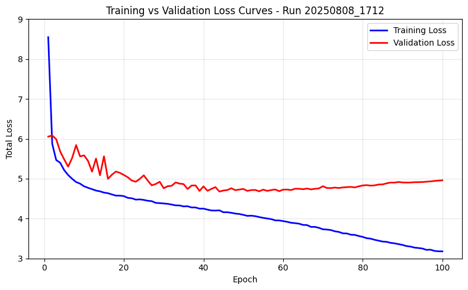

```python
plot_total_loss(str(results_path / 'results.csv'), ylim=(3, 9))
```

#### 3.3.3 Alternative processing, 1:1 imbalance (pre-, hvrt + mosaic)

Create the data .yaml configuration file (overwrites previous .yaml file with the same name):

```python
# Create data configuration
import yaml

data_config = {
    'path':   str(PROJECT_ROOT / 'data'),
    'train':  'train_hvrt_bal_alt',
    'val':    'val_alt',
    'test':   'test_alt',
    'nc': 2,
    'names': ['is_vessel', 'is_fishing']
}

# Save to configs directory
yaml_path = CONFIG_DIR / 'sar_data_aug_alt.yaml'
with open(yaml_path, 'w') as f:
    yaml.dump(data_config, f)
```

```python
# Load the model
model = YOLO('yolov8n.pt')
```

```python
# Create a timestamp for the training run
timestamp = datetime.now().strftime('%Y%m%d_%H%M')

# Train the model
results = model.train(
    data=str(yaml_path),
    epochs=100,
    batch=16,
    imgsz=640,
    freeze=None,
    plots=True,
    project=RUNS_DIR / 'train_png_aug_alt',
    name=timestamp,

    # Optimization
    optimizer='SGD',      # explicit SGD
    lr0=0.01,             # initial learning rate
    lrf=0.01,             # final learning rate factor
    momentum=0.9,         # SGD momentum/Adam beta1
    weight_decay=0.0005,  # optimizer weight decay
    warmup_epochs=3.0,    # warmup epochs
    warmup_momentum=0.8,  # warmup momentum
    warmup_bias_lr=0.1,   # warmup bias lr


    # Augmentation parameters
    auto_augment=None,
    hsv_h=0.0,
    hsv_s=0.0,
    hsv_v=0.0,
    translate=0.1,  # transaltion (+/- fraction)
    degrees=15.0,   # rotation (+/- degrees)
    scale=0.0,
    fliplr=0.5,     # horizontal flip (prob.)
    flipud=0.5,     # vertical flip (prob.)
    mosaic=1.0      # image mosaic (prob.)
)
```

```
New https://pypi.org/project/ultralytics/8.3.177 available 😃 Update with 'pip install -U ultralytics'
Ultralytics 8.3.152 🚀 Python-3.10.12 torch-2.6.0+cu124 CUDA:0 (NVIDIA RTX 2000 Ada Generation Laptop GPU, 8188MiB)
engine/trainer: agnostic_nms=False, amp=True, augment=False, auto_augment=None, batch=16, bgr=0.0, box=7.5, cache=False, cfg=None, classes=None, close_mosaic=10, cls=0.5, conf=None, copy_paste=0.0, copy_paste_mode=flip, cos_lr=False, cutmix=0.0, data=/home/peterm/UWA/CITS5014/SARFish/modelling/confi…
Overriding model.yaml nc=80 with nc=2

                   from  n    params  module                                       arguments
  0                  -1  1       464  ultralytics.nn.modules.conv.Conv             [3, 16, 3, 2]
  1                  -1  1      4672  ultralytics.nn.modules.conv.Conv             [16, 32, 3, 2]
  2                  -1  1      7360  ultralytics.nn.modules.block.C2f             [32, 32, 1, True]
  3                  -1  1     18560  ultralytics.nn.modules.conv.Conv             [32, 64, 3, 2]
  4                  -1  2     49664  ultralytics.nn.modules.block.C2f             [64, 64, 2, True]
  5                  -1  1     73984  ultralytics.nn.modules.conv.Conv             [64, 128, 3, 2]
  6                  -1  2    197632  ultralytics.nn.modules.block.C2f             [128, 128, 2, True]
  7                  -1  1    295424  ultralytics.nn.modules.conv.Conv             [128, 256, 3, 2]
  8                  -1  1    460288  ultralytics.nn.modules.block.C2f             [256, 256, 1, True]
  9                  -1  1    164608  ultralytics.nn.modules.block.SPPF            [256, 256, 5]
 10                  -1  1         0  torch.nn.modules.upsampling.Upsample         [None, 2, 'nearest']
 11             [-1, 6]  1         0  ultralytics.nn.modules.conv.Concat           [1]
 12                  -1  1    148224  ultralytics.nn.modules.block.C2f             [384, 128, 1]
 13                  -1  1         0  torch.nn.modules.upsampling.Upsample         [None, 2, 'nearest']
 14             [-1, 4]  1         0  ultralytics.nn.modules.conv.Concat           [1]
 15                  -1  1     37248  ultralytics.nn.modules.block.C2f             [192, 64, 1]
 16                  -1  1     36992  ultralytics.nn.modules.conv.Conv             [64, 64, 3, 2]
 17            [-1, 12]  1         0  ultralytics.nn.modules.conv.Concat           [1]
 18                  -1  1    123648  ultralytics.nn.modules.block.C2f             [192, 128, 1]
 19                  -1  1    147712  ultralytics.nn.modules.conv.Conv             [128, 128, 3, 2]
 20             [-1, 9]  1         0  ultralytics.nn.modules.conv.Concat           [1]
 21                  -1  1    493056  ultralytics.nn.modules.block.C2f             [384, 256, 1]
 22        [15, 18, 21]  1    751702  ultralytics.nn.modules.head.Detect           [2, [64, 128, 256]]
Model summary: 129 layers, 3,011,238 parameters, 3,011,222 gradients, 8.2 GFLOPs

Transferred 319/355 items from pretrained weights
TensorBoard: Start with 'tensorboard --logdir /home/peterm/UWA/CITS5014/SARFish/modelling/runs/train_png_aug_alt/20250811_2039', view at http://localhost:6006/
Freezing layer 'model.22.dfl.conv.weight'
AMP: running Automatic Mixed Precision (AMP) checks...
AMP: checks passed ✅
train: Fast image access ✅ (ping: 0.3±0.4 ms, read: 80.7±11.2 MB/s, size: 19.8 KB)
```

```
train: Scanning /home/peterm/UWA/CITS5014/SARFish/modelling/data/train_hvrt_bal_alt/labels.cache... 7559 images, 0 backg
```

```
albumentations: Blur(p=0.01, blur_limit=(3, 7)), MedianBlur(p=0.01, blur_limit=(3, 7)), ToGray(p=0.01, method='weighted_average', num_output_channels=3), CLAHE(p=0.01, clip_limit=(1.0, 4.0), tile_grid_size=(8, 8))
val: Fast image access ✅ (ping: 0.2±0.3 ms, read: 36.2±9.0 MB/s, size: 20.6 KB)
```

```
val: Scanning /home/peterm/UWA/CITS5014/SARFish/modelling/data/val_alt/labels.cache... 463 images, 0 backgrounds, 0 corr
```

```
Plotting labels to /home/peterm/UWA/CITS5014/SARFish/modelling/runs/train_png_aug_alt/20250811_2039/labels.jpg...
optimizer: SGD(lr=0.01, momentum=0.9) with parameter groups 57 weight(decay=0.0), 64 weight(decay=0.0005), 63 bias(decay=0.0)
TensorBoard: model graph visualization added ✅
Image sizes 640 train, 640 val
Using 8 dataloader workers
Logging results to /home/peterm/UWA/CITS5014/SARFish/modelling/runs/train_png_aug_alt/20250811_2039
Starting training for 100 epochs...

      Epoch    GPU_mem   box_loss   cls_loss   dfl_loss  Instances       Size
```

```
      1/100      1.94G      2.282      3.347      2.201         11        640: 100%|██████████| 473/473 [01:54<00:00,  4
                 Class     Images  Instances      Box(P          R      mAP50  mAP50-95): 100%|██████████| 15/15 [00:06<
```

```
                   all        463        463      0.094      0.221     0.0648     0.0152
```

```
      Epoch    GPU_mem   box_loss   cls_loss   dfl_loss  Instances       Size
```

```
      2/100      2.25G      2.073      2.286      1.941          8        640: 100%|██████████| 473/473 [02:36<00:00,  3
                 Class     Images  Instances      Box(P          R      mAP50  mAP50-95): 100%|██████████| 15/15 [00:04<
```

```
                   all        463        463       0.29      0.465      0.275     0.0928
```

```
      Epoch    GPU_mem   box_loss   cls_loss   dfl_loss  Instances       Size
```

```
      3/100      2.26G      2.072      2.151      1.913         10        640: 100%|██████████| 473/473 [01:31<00:00,  5
                 Class     Images  Instances      Box(P          R      mAP50  mAP50-95): 100%|██████████| 15/15 [00:06<
```

```
                   all        463        463     0.0931      0.065      0.023    0.00571
```

```
      Epoch    GPU_mem   box_loss   cls_loss   dfl_loss  Instances       Size
```

```
      4/100      2.26G      2.024      2.089      1.892         12        640: 100%|██████████| 473/473 [02:21<00:00,  3
                 Class     Images  Instances      Box(P          R      mAP50  mAP50-95): 100%|██████████| 15/15 [00:03<
```

```
                   all        463        463      0.374      0.432      0.345      0.116
```

```
      Epoch    GPU_mem   box_loss   cls_loss   dfl_loss  Instances       Size
```

```
      5/100      2.26G      1.986          2      1.851          9        640: 100%|██████████| 473/473 [01:44<00:00,  4
                 Class     Images  Instances      Box(P          R      mAP50  mAP50-95): 100%|██████████| 15/15 [00:05<
```

```
                   all        463        463       0.38      0.512      0.448      0.167
```

```
      Epoch    GPU_mem   box_loss   cls_loss   dfl_loss  Instances       Size
```

```
      6/100      2.26G      1.935      1.918      1.809         10        640: 100%|██████████| 473/473 [02:02<00:00,  3
                 Class     Images  Instances      Box(P          R      mAP50  mAP50-95): 100%|██████████| 15/15 [00:04<
```

```
                   all        463        463      0.323       0.51      0.347      0.134
```

```
      Epoch    GPU_mem   box_loss   cls_loss   dfl_loss  Instances       Size
```

```
      7/100      2.26G      1.904      1.869      1.793          7        640: 100%|██████████| 473/473 [02:03<00:00,  3
                 Class     Images  Instances      Box(P          R      mAP50  mAP50-95): 100%|██████████| 15/15 [00:06<
```

```
                   all        463        463      0.448       0.46      0.411      0.169
```

```
      Epoch    GPU_mem   box_loss   cls_loss   dfl_loss  Instances       Size
```

```
      8/100      2.26G      1.875       1.85      1.768          9        640: 100%|██████████| 473/473 [02:03<00:00,  3
                 Class     Images  Instances      Box(P          R      mAP50  mAP50-95): 100%|██████████| 15/15 [00:04<
```

```
                   all        463        463      0.321      0.562      0.422      0.159
```

```
      Epoch    GPU_mem   box_loss   cls_loss   dfl_loss  Instances       Size
```

```
      9/100      2.27G      1.859      1.818      1.742          9        640: 100%|██████████| 473/473 [02:11<00:00,  3
                 Class     Images  Instances      Box(P          R      mAP50  mAP50-95): 100%|██████████| 15/15 [00:06<
```

```
                   all        463        463      0.263       0.55      0.368      0.143
```

```
      Epoch    GPU_mem   box_loss   cls_loss   dfl_loss  Instances       Size
```

```
     10/100      2.28G      1.833      1.796      1.728          9        640: 100%|██████████| 473/473 [01:56<00:00,  4
                 Class     Images  Instances      Box(P          R      mAP50  mAP50-95): 100%|██████████| 15/15 [00:05<
```

```
                   all        463        463      0.392      0.586      0.472      0.197

      Epoch    GPU_mem   box_loss   cls_loss   dfl_loss  Instances       Size
```

```
     11/100      2.28G      1.809      1.772      1.722         11        640: 100%|██████████| 473/473 [01:55<00:00,  4
                 Class     Images  Instances      Box(P          R      mAP50  mAP50-95): 100%|██████████| 15/15 [00:05<
```

```
                   all        463        463      0.273      0.649      0.411      0.185
```

```
      Epoch    GPU_mem   box_loss   cls_loss   dfl_loss  Instances       Size
```

```
     12/100      2.28G      1.797      1.763      1.707          8        640: 100%|██████████| 473/473 [02:18<00:00,  3
                 Class     Images  Instances      Box(P          R      mAP50  mAP50-95): 100%|██████████| 15/15 [00:05<
```

```
                   all        463        463      0.343      0.616      0.434      0.185
```

```
      Epoch    GPU_mem   box_loss   cls_loss   dfl_loss  Instances       Size
```

```
     13/100      2.28G      1.783      1.744      1.688          9        640: 100%|██████████| 473/473 [01:48<00:00,  4
                 Class     Images  Instances      Box(P          R      mAP50  mAP50-95): 100%|██████████| 15/15 [00:05<
```

```
                   all        463        463      0.375      0.622      0.493      0.195
```

```
      Epoch    GPU_mem   box_loss   cls_loss   dfl_loss  Instances       Size
```

```
     14/100      2.28G      1.749      1.714      1.672          9        640: 100%|██████████| 473/473 [01:59<00:00,  3
                 Class     Images  Instances      Box(P          R      mAP50  mAP50-95): 100%|██████████| 15/15 [00:06<
```

```
                   all        463        463       0.41      0.571      0.495      0.207
```

```
      Epoch    GPU_mem   box_loss   cls_loss   dfl_loss  Instances       Size
```

```
     15/100      2.28G       1.75      1.719       1.68          7        640: 100%|██████████| 473/473 [02:16<00:00,  3
                 Class     Images  Instances      Box(P          R      mAP50  mAP50-95): 100%|██████████| 15/15 [00:05<
```

```
                   all        463        463      0.301      0.586      0.436      0.183
```

```
      Epoch    GPU_mem   box_loss   cls_loss   dfl_loss  Instances       Size
```

```
     16/100      2.28G      1.737      1.697      1.664          9        640: 100%|██████████| 473/473 [01:54<00:00,  4
                 Class     Images  Instances      Box(P          R      mAP50  mAP50-95): 100%|██████████| 15/15 [00:06<
```

```
                   all        463        463      0.454      0.488      0.468      0.199
```

```
      Epoch    GPU_mem   box_loss   cls_loss   dfl_loss  Instances       Size
```

```
     17/100      2.28G      1.714      1.686       1.64         11        640: 100%|██████████| 473/473 [02:23<00:00,  3
                 Class     Images  Instances      Box(P          R      mAP50  mAP50-95): 100%|██████████| 15/15 [00:05<
```

```
                   all        463        463      0.346       0.58      0.437      0.198

      Epoch    GPU_mem   box_loss   cls_loss   dfl_loss  Instances       Size
```

```
     18/100      2.28G      1.711      1.683      1.651         12        640: 100%|██████████| 473/473 [01:55<00:00,  4
                 Class     Images  Instances      Box(P          R      mAP50  mAP50-95): 100%|██████████| 15/15 [00:06<
```

```
                   all        463        463      0.366      0.563      0.466      0.198
```

```
      Epoch    GPU_mem   box_loss   cls_loss   dfl_loss  Instances       Size
```

```
     19/100      2.28G      1.697      1.675      1.626          9        640: 100%|██████████| 473/473 [02:19<00:00,  3
                 Class     Images  Instances      Box(P          R      mAP50  mAP50-95): 100%|██████████| 15/15 [00:05<
```

```
                   all        463        463        0.4       0.59      0.466      0.209
```

```
      Epoch    GPU_mem   box_loss   cls_loss   dfl_loss  Instances       Size
```

```
     20/100      2.28G       1.68      1.678      1.631         12        640: 100%|██████████| 473/473 [01:43<00:00,  4
                 Class     Images  Instances      Box(P          R      mAP50  mAP50-95): 100%|██████████| 15/15 [00:05<
```

```
                   all        463        463      0.359      0.633      0.451      0.207
```

```
      Epoch    GPU_mem   box_loss   cls_loss   dfl_loss  Instances       Size
```

```
     21/100      2.28G       1.68      1.666      1.622          8        640: 100%|██████████| 473/473 [02:31<00:00,  3
                 Class     Images  Instances      Box(P          R      mAP50  mAP50-95): 100%|██████████| 15/15 [00:04<
```

```
                   all        463        463      0.313      0.631      0.422      0.171
```

```
      Epoch    GPU_mem   box_loss   cls_loss   dfl_loss  Instances       Size
```

```
     22/100      2.28G      1.677      1.651      1.621         11        640: 100%|██████████| 473/473 [01:46<00:00,  4
                 Class     Images  Instances      Box(P          R      mAP50  mAP50-95): 100%|██████████| 15/15 [00:05<
```

```
                   all        463        463      0.405      0.594       0.46      0.213
```

```
      Epoch    GPU_mem   box_loss   cls_loss   dfl_loss  Instances       Size
```

```
     23/100      2.28G      1.653      1.632       1.61          9        640: 100%|██████████| 473/473 [02:25<00:00,  3
                 Class     Images  Instances      Box(P          R      mAP50  mAP50-95): 100%|██████████| 15/15 [00:05<
```

```
                   all        463        463      0.387      0.647      0.522      0.225
```

```
      Epoch    GPU_mem   box_loss   cls_loss   dfl_loss  Instances       Size
```

```
     24/100      2.28G      1.659      1.647      1.611          9        640: 100%|██████████| 473/473 [01:47<00:00,  4
                 Class     Images  Instances      Box(P          R      mAP50  mAP50-95): 100%|██████████| 15/15 [00:05<
```

```
                   all        463        463      0.389      0.632      0.513      0.222

      Epoch    GPU_mem   box_loss   cls_loss   dfl_loss  Instances       Size
```

```
     25/100      2.28G      1.637       1.62       1.59          6        640: 100%|██████████| 473/473 [02:24<00:00,  3
                 Class     Images  Instances      Box(P          R      mAP50  mAP50-95): 100%|██████████| 15/15 [00:04<
```

```
                   all        463        463      0.431      0.615       0.54      0.243
```

```
      Epoch    GPU_mem   box_loss   cls_loss   dfl_loss  Instances       Size
```

```
     26/100      2.28G      1.646      1.625      1.606         11        640: 100%|██████████| 473/473 [01:45<00:00,  4
                 Class     Images  Instances      Box(P          R      mAP50  mAP50-95): 100%|██████████| 15/15 [00:06<
```

```
                   all        463        463      0.395      0.569      0.488      0.212
```

```
      Epoch    GPU_mem   box_loss   cls_loss   dfl_loss  Instances       Size
```

```
     27/100      2.28G      1.635      1.617      1.591         12        640: 100%|██████████| 473/473 [02:53<00:00,  2
                 Class     Images  Instances      Box(P          R      mAP50  mAP50-95): 100%|██████████| 15/15 [00:06<
```

```
                   all        463        463      0.387      0.611      0.509      0.233
```

```
      Epoch    GPU_mem   box_loss   cls_loss   dfl_loss  Instances       Size
```

```
     28/100      2.28G       1.63      1.621      1.587          9        640: 100%|██████████| 473/473 [02:52<00:00,  2
                 Class     Images  Instances      Box(P          R      mAP50  mAP50-95): 100%|██████████| 15/15 [00:06<
```

```
                   all        463        463      0.392      0.577      0.502      0.228
```

```
      Epoch    GPU_mem   box_loss   cls_loss   dfl_loss  Instances       Size
```

```
     29/100      2.28G       1.62       1.61      1.584          8        640: 100%|██████████| 473/473 [01:26<00:00,  5
                 Class     Images  Instances      Box(P          R      mAP50  mAP50-95): 100%|██████████| 15/15 [00:04<
```

```
                   all        463        463      0.491      0.561      0.525      0.238
```

```
      Epoch    GPU_mem   box_loss   cls_loss   dfl_loss  Instances       Size
```

```
     30/100      2.28G      1.621      1.612       1.58         11        640: 100%|██████████| 473/473 [02:35<00:00,  3
                 Class     Images  Instances      Box(P          R      mAP50  mAP50-95): 100%|██████████| 15/15 [00:06<
```

```
                   all        463        463      0.358      0.583      0.479      0.218
```

```
      Epoch    GPU_mem   box_loss   cls_loss   dfl_loss  Instances       Size
```

```
     31/100      2.28G      1.613       1.61      1.577          9        640: 100%|██████████| 473/473 [01:28<00:00,  5
                 Class     Images  Instances      Box(P          R      mAP50  mAP50-95): 100%|██████████| 15/15 [00:04<
```

```
                   all        463        463      0.481      0.543      0.548      0.252
```

```
      Epoch    GPU_mem   box_loss   cls_loss   dfl_loss  Instances       Size
```

```
     32/100      2.28G      1.607      1.606      1.574         13        640: 100%|██████████| 473/473 [02:35<00:00,  3
                 Class     Images  Instances      Box(P          R      mAP50  mAP50-95): 100%|██████████| 15/15 [00:05<
```

```
                   all        463        463      0.474      0.603      0.515       0.23
```

```
      Epoch    GPU_mem   box_loss   cls_loss   dfl_loss  Instances       Size
```

```
     33/100      2.28G      1.604      1.594      1.572         10        640: 100%|██████████| 473/473 [01:36<00:00,  4
                 Class     Images  Instances      Box(P          R      mAP50  mAP50-95): 100%|██████████| 15/15 [00:06<
```

```
                   all        463        463      0.442      0.608      0.529      0.222
```

```
      Epoch    GPU_mem   box_loss   cls_loss   dfl_loss  Instances       Size
```

```
     34/100      2.28G      1.588      1.576      1.568          8        640: 100%|██████████| 473/473 [02:46<00:00,  2
                 Class     Images  Instances      Box(P          R      mAP50  mAP50-95): 100%|██████████| 15/15 [00:04<
```

```
                   all        463        463      0.479      0.609      0.568      0.256
```

```
      Epoch    GPU_mem   box_loss   cls_loss   dfl_loss  Instances       Size
```

```
     35/100      2.28G      1.586      1.585       1.56         12        640: 100%|██████████| 473/473 [01:29<00:00,  5
                 Class     Images  Instances      Box(P          R      mAP50  mAP50-95): 100%|██████████| 15/15 [00:06<
```

```
                   all        463        463      0.498      0.588      0.557      0.256
```

```
      Epoch    GPU_mem   box_loss   cls_loss   dfl_loss  Instances       Size
```

```
     36/100      2.28G      1.577       1.57       1.55          9        640: 100%|██████████| 473/473 [02:27<00:00,  3
                 Class     Images  Instances      Box(P          R      mAP50  mAP50-95): 100%|██████████| 15/15 [00:04<
```

```
                   all        463        463      0.511      0.579      0.577      0.262
```

```
      Epoch    GPU_mem   box_loss   cls_loss   dfl_loss  Instances       Size
```

```
     37/100      2.28G      1.584      1.571      1.552          9        640: 100%|██████████| 473/473 [01:52<00:00,  4
                 Class     Images  Instances      Box(P          R      mAP50  mAP50-95): 100%|██████████| 15/15 [00:06<
```

```
                   all        463        463      0.455      0.584      0.543      0.254
```

```
      Epoch    GPU_mem   box_loss   cls_loss   dfl_loss  Instances       Size
```

```
     38/100      2.28G      1.567      1.566      1.554          8        640: 100%|██████████| 473/473 [01:52<00:00,  4
                 Class     Images  Instances      Box(P          R      mAP50  mAP50-95): 100%|██████████| 15/15 [00:04<
```

```
                   all        463        463      0.482      0.619      0.556      0.254
```

```
      Epoch    GPU_mem   box_loss   cls_loss   dfl_loss  Instances       Size
```

```
     39/100      2.28G      1.562      1.562      1.547         12        640: 100%|██████████| 473/473 [02:09<00:00,  3
                 Class     Images  Instances      Box(P          R      mAP50  mAP50-95): 100%|██████████| 15/15 [00:05<
```

```
                   all        463        463      0.507       0.62      0.586      0.278
```

```
      Epoch    GPU_mem   box_loss   cls_loss   dfl_loss  Instances       Size
```

```
     40/100      2.28G      1.555      1.565       1.54         10        640: 100%|██████████| 473/473 [01:40<00:00,  4
                 Class     Images  Instances      Box(P          R      mAP50  mAP50-95): 100%|██████████| 15/15 [00:04<
```

```
                   all        463        463      0.506      0.625      0.579       0.27
```

```
      Epoch    GPU_mem   box_loss   cls_loss   dfl_loss  Instances       Size
```

```
     41/100      2.28G      1.562      1.557      1.547         10        640: 100%|██████████| 473/473 [02:10<00:00,  3
                 Class     Images  Instances      Box(P          R      mAP50  mAP50-95): 100%|██████████| 15/15 [00:06<
```

```
                   all        463        463      0.492      0.622      0.578      0.268
```

```
      Epoch    GPU_mem   box_loss   cls_loss   dfl_loss  Instances       Size
```

```
     42/100      2.28G      1.554      1.551      1.544         10        640: 100%|██████████| 473/473 [01:20<00:00,  5
                 Class     Images  Instances      Box(P          R      mAP50  mAP50-95): 100%|██████████| 15/15 [00:04<
```

```
                   all        463        463      0.484        0.6      0.577      0.268
```

```
      Epoch    GPU_mem   box_loss   cls_loss   dfl_loss  Instances       Size
```

```
     43/100      2.28G      1.552      1.539      1.544         13        640: 100%|██████████| 473/473 [02:19<00:00,  3
                 Class     Images  Instances      Box(P          R      mAP50  mAP50-95): 100%|██████████| 15/15 [00:05<
```

```
                   all        463        463      0.509      0.595      0.566      0.255
```

```
      Epoch    GPU_mem   box_loss   cls_loss   dfl_loss  Instances       Size
```

```
     44/100      2.28G      1.543      1.545      1.537         11        640: 100%|██████████| 473/473 [01:19<00:00,  5
                 Class     Images  Instances      Box(P          R      mAP50  mAP50-95): 100%|██████████| 15/15 [00:05<
```

```
                   all        463        463      0.506      0.608      0.553      0.248
```

```
      Epoch    GPU_mem   box_loss   cls_loss   dfl_loss  Instances       Size
```

```
     45/100      2.28G      1.543      1.537      1.531         10        640: 100%|██████████| 473/473 [02:09<00:00,  3
                 Class     Images  Instances      Box(P          R      mAP50  mAP50-95): 100%|██████████| 15/15 [00:03<
```

```
                   all        463        463      0.518      0.597      0.571      0.268
```

```
      Epoch    GPU_mem   box_loss   cls_loss   dfl_loss  Instances       Size
```

```
     46/100      2.28G      1.527      1.538      1.523          8        640: 100%|██████████| 473/473 [01:45<00:00,  4
                 Class     Images  Instances      Box(P          R      mAP50  mAP50-95): 100%|██████████| 15/15 [00:05<
```

```
                   all        463        463      0.494      0.592      0.577      0.265
```

```
      Epoch    GPU_mem   box_loss   cls_loss   dfl_loss  Instances       Size
```

```
     47/100      2.28G      1.532       1.53      1.523          8        640: 100%|██████████| 473/473 [01:35<00:00,  4
                 Class     Images  Instances      Box(P          R      mAP50  mAP50-95): 100%|██████████| 15/15 [00:03<
```

```
                   all        463        463      0.489      0.625      0.571      0.267
```

```
      Epoch    GPU_mem   box_loss   cls_loss   dfl_loss  Instances       Size
```

```
     48/100      2.28G      1.523      1.515      1.523         10        640: 100%|██████████| 473/473 [02:13<00:00,  3
                 Class     Images  Instances      Box(P          R      mAP50  mAP50-95): 100%|██████████| 15/15 [00:04<
```

```
                   all        463        463      0.535      0.555      0.569      0.255
```

```
      Epoch    GPU_mem   box_loss   cls_loss   dfl_loss  Instances       Size
```

```
     49/100      2.28G      1.523      1.526      1.521          8        640: 100%|██████████| 473/473 [01:18<00:00,  6
                 Class     Images  Instances      Box(P          R      mAP50  mAP50-95): 100%|██████████| 15/15 [00:04<
```

```
                   all        463        463      0.467        0.6      0.563      0.258
```

```
      Epoch    GPU_mem   box_loss   cls_loss   dfl_loss  Instances       Size
```

```
     50/100      2.28G      1.517      1.522      1.517          9        640: 100%|██████████| 473/473 [02:12<00:00,  3
                 Class     Images  Instances      Box(P          R      mAP50  mAP50-95): 100%|██████████| 15/15 [00:03<
```

```
                   all        463        463      0.514      0.597       0.55      0.251
```

```
      Epoch    GPU_mem   box_loss   cls_loss   dfl_loss  Instances       Size
```

```
     51/100      2.28G      1.521       1.52      1.521          9        640: 100%|██████████| 473/473 [01:35<00:00,  4
                 Class     Images  Instances      Box(P          R      mAP50  mAP50-95): 100%|██████████| 15/15 [00:06<
```

```
                   all        463        463      0.472      0.638      0.559      0.258
```

```
      Epoch    GPU_mem   box_loss   cls_loss   dfl_loss  Instances       Size
```

```
     52/100      2.28G      1.512      1.519      1.505          9        640: 100%|██████████| 473/473 [01:49<00:00,  4
                 Class     Images  Instances      Box(P          R      mAP50  mAP50-95): 100%|██████████| 15/15 [00:04<
```

```
                   all        463        463      0.486      0.613       0.54      0.252
```

```
      Epoch    GPU_mem   box_loss   cls_loss   dfl_loss  Instances       Size
```

```
     53/100      2.28G      1.509      1.509      1.513         10        640: 100%|██████████| 473/473 [02:04<00:00,  3
                 Class     Images  Instances      Box(P          R      mAP50  mAP50-95): 100%|██████████| 15/15 [00:03<
```

```
                   all        463        463      0.507      0.588      0.565       0.27
```

```
      Epoch    GPU_mem   box_loss   cls_loss   dfl_loss  Instances       Size
```

```
     54/100      2.28G      1.514      1.504      1.509          9        640: 100%|██████████| 473/473 [01:23<00:00,  5
                 Class     Images  Instances      Box(P          R      mAP50  mAP50-95): 100%|██████████| 15/15 [00:04<
```

```
                   all        463        463       0.52      0.607      0.593      0.271
```

```
      Epoch    GPU_mem   box_loss   cls_loss   dfl_loss  Instances       Size
```

```
     55/100      2.28G      1.498      1.515      1.507          9        640: 100%|██████████| 473/473 [02:04<00:00,  3
                 Class     Images  Instances      Box(P          R      mAP50  mAP50-95): 100%|██████████| 15/15 [00:05<
```

```
                   all        463        463      0.558      0.572      0.597      0.275
```

```
      Epoch    GPU_mem   box_loss   cls_loss   dfl_loss  Instances       Size
```

```
     56/100      2.28G      1.501      1.499      1.506         11        640: 100%|██████████| 473/473 [01:25<00:00,  5
                 Class     Images  Instances      Box(P          R      mAP50  mAP50-95): 100%|██████████| 15/15 [00:03<
```

```
                   all        463        463       0.53      0.609        0.6       0.26
```

```
      Epoch    GPU_mem   box_loss   cls_loss   dfl_loss  Instances       Size
```

```
     57/100      2.28G      1.484      1.493      1.499          9        640: 100%|██████████| 473/473 [02:07<00:00,  3
                 Class     Images  Instances      Box(P          R      mAP50  mAP50-95): 100%|██████████| 15/15 [00:03<
```

```
                   all        463        463      0.524      0.591      0.576      0.266
```

```
      Epoch    GPU_mem   box_loss   cls_loss   dfl_loss  Instances       Size
```

```
     58/100      2.28G      1.488      1.493      1.495          8        640: 100%|██████████| 473/473 [01:19<00:00,  5
                 Class     Images  Instances      Box(P          R      mAP50  mAP50-95): 100%|██████████| 15/15 [00:04<
```

```
                   all        463        463      0.517       0.61      0.593      0.277
```

```
      Epoch    GPU_mem   box_loss   cls_loss   dfl_loss  Instances       Size
```

```
     59/100      2.28G      1.482      1.488      1.493          9        640: 100%|██████████| 473/473 [02:04<00:00,  3
                 Class     Images  Instances      Box(P          R      mAP50  mAP50-95): 100%|██████████| 15/15 [00:04<
```

```
                   all        463        463      0.505      0.616      0.599      0.275
```

```
      Epoch    GPU_mem   box_loss   cls_loss   dfl_loss  Instances       Size
```

```
     60/100      2.28G      1.488      1.492      1.496          9        640: 100%|██████████| 473/473 [01:33<00:00,  5
                 Class     Images  Instances      Box(P          R      mAP50  mAP50-95): 100%|██████████| 15/15 [00:05<
```

```
                   all        463        463      0.547      0.637       0.61       0.28
```

```
      Epoch    GPU_mem   box_loss   cls_loss   dfl_loss  Instances       Size
```

```
     61/100      2.28G      1.484      1.475      1.485          9        640: 100%|██████████| 473/473 [01:47<00:00,  4
                 Class     Images  Instances      Box(P          R      mAP50  mAP50-95): 100%|██████████| 15/15 [00:03<
```

```
                   all        463        463      0.533      0.619      0.599       0.28
```

```
      Epoch    GPU_mem   box_loss   cls_loss   dfl_loss  Instances       Size
```

```
     62/100      2.28G      1.465      1.475      1.484          9        640: 100%|██████████| 473/473 [01:41<00:00,  4
                 Class     Images  Instances      Box(P          R      mAP50  mAP50-95): 100%|██████████| 15/15 [00:05<
```

```
                   all        463        463      0.504      0.651        0.6      0.275
```

```
      Epoch    GPU_mem   box_loss   cls_loss   dfl_loss  Instances       Size
```

```
     63/100      2.28G      1.469      1.463      1.482          8        640: 100%|██████████| 473/473 [01:38<00:00,  4
                 Class     Images  Instances      Box(P          R      mAP50  mAP50-95): 100%|██████████| 15/15 [00:03<
```

```
                   all        463        463      0.559      0.636      0.606       0.28
```

```
      Epoch    GPU_mem   box_loss   cls_loss   dfl_loss  Instances       Size
```

```
     64/100      2.28G      1.463      1.465      1.484          8        640: 100%|██████████| 473/473 [02:01<00:00,  3
                 Class     Images  Instances      Box(P          R      mAP50  mAP50-95): 100%|██████████| 15/15 [00:04<
```

```
                   all        463        463      0.535      0.636      0.605      0.281
```

```
      Epoch    GPU_mem   box_loss   cls_loss   dfl_loss  Instances       Size
```

```
     65/100      2.28G      1.463      1.467      1.481         10        640: 100%|██████████| 473/473 [01:19<00:00,  5
                 Class     Images  Instances      Box(P          R      mAP50  mAP50-95): 100%|██████████| 15/15 [00:04<
```

```
                   all        463        463      0.533      0.647      0.578      0.269
```

```
      Epoch    GPU_mem   box_loss   cls_loss   dfl_loss  Instances       Size
```

```
     66/100      2.28G      1.461      1.442      1.481         12        640: 100%|██████████| 473/473 [02:04<00:00,  3
                 Class     Images  Instances      Box(P          R      mAP50  mAP50-95): 100%|██████████| 15/15 [00:04<
```

```
                   all        463        463      0.538      0.633      0.589      0.275
```

```
      Epoch    GPU_mem   box_loss   cls_loss   dfl_loss  Instances       Size
```

```
     67/100      2.28G      1.447      1.462      1.473         11        640: 100%|██████████| 473/473 [01:20<00:00,  5
                 Class     Images  Instances      Box(P          R      mAP50  mAP50-95): 100%|██████████| 15/15 [00:04<
```

```
                   all        463        463      0.554      0.635       0.61      0.281
```

```
      Epoch    GPU_mem   box_loss   cls_loss   dfl_loss  Instances       Size
```

```
     68/100      2.28G      1.461      1.462      1.481         11        640: 100%|██████████| 473/473 [02:03<00:00,  3
                 Class     Images  Instances      Box(P          R      mAP50  mAP50-95): 100%|██████████| 15/15 [00:04<
```

```
                   all        463        463      0.588      0.615      0.604      0.275
```

```
      Epoch    GPU_mem   box_loss   cls_loss   dfl_loss  Instances       Size
```

```
     69/100      2.28G      1.447      1.451      1.471          9        640: 100%|██████████| 473/473 [01:21<00:00,  5
                 Class     Images  Instances      Box(P          R      mAP50  mAP50-95): 100%|██████████| 15/15 [00:03<
```

```
                   all        463        463      0.565      0.619      0.599      0.275
```

```
      Epoch    GPU_mem   box_loss   cls_loss   dfl_loss  Instances       Size
```

```
     70/100      2.28G      1.447      1.443      1.472          7        640: 100%|██████████| 473/473 [02:01<00:00,  3
                 Class     Images  Instances      Box(P          R      mAP50  mAP50-95): 100%|██████████| 15/15 [00:04<
```

```
                   all        463        463      0.518      0.666      0.585      0.272
```

```
      Epoch    GPU_mem   box_loss   cls_loss   dfl_loss  Instances       Size
```

```
     71/100      2.28G      1.441      1.448      1.464          8        640: 100%|██████████| 473/473 [01:23<00:00,  5
                 Class     Images  Instances      Box(P          R      mAP50  mAP50-95): 100%|██████████| 15/15 [00:04<
```

```
                   all        463        463      0.552      0.637      0.606      0.284
```

```
      Epoch    GPU_mem   box_loss   cls_loss   dfl_loss  Instances       Size
```

```
     72/100      2.28G      1.444      1.453      1.468          9        640: 100%|██████████| 473/473 [01:31<00:00,  5
                 Class     Images  Instances      Box(P          R      mAP50  mAP50-95): 100%|██████████| 15/15 [00:06<
```

```
                   all        463        463       0.56      0.634       0.61      0.278
```

```
      Epoch    GPU_mem   box_loss   cls_loss   dfl_loss  Instances       Size
```

```
     73/100      2.28G      1.432      1.432      1.457          7        640: 100%|██████████| 473/473 [01:50<00:00,  4
                 Class     Images  Instances      Box(P          R      mAP50  mAP50-95): 100%|██████████| 15/15 [00:04<
```

```
                   all        463        463      0.546      0.633      0.591      0.275
```

```
      Epoch    GPU_mem   box_loss   cls_loss   dfl_loss  Instances       Size
```

```
     74/100      2.28G      1.431      1.432      1.455         11        640: 100%|██████████| 473/473 [01:35<00:00,  4
                 Class     Images  Instances      Box(P          R      mAP50  mAP50-95): 100%|██████████| 15/15 [00:06<
```

```
                   all        463        463      0.553       0.59      0.594       0.28
```

```
      Epoch    GPU_mem   box_loss   cls_loss   dfl_loss  Instances       Size
```

```
     75/100      2.28G       1.43      1.452      1.458         11        640: 100%|██████████| 473/473 [01:47<00:00,  4
                 Class     Images  Instances      Box(P          R      mAP50  mAP50-95): 100%|██████████| 15/15 [00:04<
```

```
                   all        463        463      0.532      0.624      0.594       0.28
```

```
      Epoch    GPU_mem   box_loss   cls_loss   dfl_loss  Instances       Size
```

```
     76/100      2.28G      1.419      1.417      1.454          9        640: 100%|██████████| 473/473 [01:31<00:00,  5
                 Class     Images  Instances      Box(P          R      mAP50  mAP50-95): 100%|██████████| 15/15 [00:06<
```

```
                   all        463        463      0.547       0.66      0.602      0.281
```

```
      Epoch    GPU_mem   box_loss   cls_loss   dfl_loss  Instances       Size
```

```
     77/100      2.28G      1.425      1.425      1.457         11        640: 100%|██████████| 473/473 [01:52<00:00,  4
                 Class     Images  Instances      Box(P          R      mAP50  mAP50-95): 100%|██████████| 15/15 [00:04<
```

```
                   all        463        463      0.557      0.647      0.616       0.28
```

```
      Epoch    GPU_mem   box_loss   cls_loss   dfl_loss  Instances       Size
```

```
     78/100      2.28G      1.428      1.417      1.458          8        640: 100%|██████████| 473/473 [01:25<00:00,  5
                 Class     Images  Instances      Box(P          R      mAP50  mAP50-95): 100%|██████████| 15/15 [00:03<
```

```
                   all        463        463      0.548      0.644      0.606      0.282
```

```
      Epoch    GPU_mem   box_loss   cls_loss   dfl_loss  Instances       Size
```

```
     79/100      2.28G      1.413      1.412      1.445         11        640: 100%|██████████| 473/473 [02:02<00:00,  3
                 Class     Images  Instances      Box(P          R      mAP50  mAP50-95): 100%|██████████| 15/15 [00:03<
```

```
                   all        463        463      0.568      0.639      0.608      0.283
```

```
      Epoch    GPU_mem   box_loss   cls_loss   dfl_loss  Instances       Size
```

```
     80/100      2.28G      1.407      1.405      1.444         10        640: 100%|██████████| 473/473 [01:19<00:00,  5
                 Class     Images  Instances      Box(P          R      mAP50  mAP50-95): 100%|██████████| 15/15 [00:03<
```

```
                   all        463        463      0.577      0.603      0.626      0.287
```

```
      Epoch    GPU_mem   box_loss   cls_loss   dfl_loss  Instances       Size
```

```
     81/100      2.28G      1.423      1.403      1.452         10        640: 100%|██████████| 473/473 [01:59<00:00,  3
                 Class     Images  Instances      Box(P          R      mAP50  mAP50-95): 100%|██████████| 15/15 [00:03<
```

```
                   all        463        463      0.586      0.616      0.604      0.277
```

```
      Epoch    GPU_mem   box_loss   cls_loss   dfl_loss  Instances       Size
```

```
     82/100      2.28G      1.404      1.403      1.445         12        640: 100%|██████████| 473/473 [01:28<00:00,  5
                 Class     Images  Instances      Box(P          R      mAP50  mAP50-95): 100%|██████████| 15/15 [00:05<
```

```
                   all        463        463      0.581      0.628      0.598      0.278
```

```
      Epoch    GPU_mem   box_loss   cls_loss   dfl_loss  Instances       Size
```

```
     83/100      2.28G      1.408      1.385      1.447          9        640: 100%|██████████| 473/473 [01:47<00:00,  4
                 Class     Images  Instances      Box(P          R      mAP50  mAP50-95): 100%|██████████| 15/15 [00:03<
```

```
                   all        463        463      0.586      0.633        0.6       0.28
```

```
      Epoch    GPU_mem   box_loss   cls_loss   dfl_loss  Instances       Size
```

```
     84/100      2.28G      1.401      1.398      1.442          8        640: 100%|██████████| 473/473 [01:43<00:00,  4
                 Class     Images  Instances      Box(P          R      mAP50  mAP50-95): 100%|██████████| 15/15 [00:05<
```

```
                   all        463        463      0.562      0.625        0.6      0.279
```

```
      Epoch    GPU_mem   box_loss   cls_loss   dfl_loss  Instances       Size
```

```
     85/100      2.28G      1.391       1.39      1.434          9        640: 100%|██████████| 473/473 [01:28<00:00,  5
                 Class     Images  Instances      Box(P          R      mAP50  mAP50-95): 100%|██████████| 15/15 [00:03<
```

```
                   all        463        463       0.58      0.618      0.608      0.282
```

```
      Epoch    GPU_mem   box_loss   cls_loss   dfl_loss  Instances       Size
```

```
     86/100      2.28G      1.395      1.384      1.436          9        640: 100%|██████████| 473/473 [01:55<00:00,  4
                 Class     Images  Instances      Box(P          R      mAP50  mAP50-95): 100%|██████████| 15/15 [00:04<
```

```
                   all        463        463       0.57      0.627      0.609      0.283
```

```
      Epoch    GPU_mem   box_loss   cls_loss   dfl_loss  Instances       Size
```

```
     87/100      2.28G      1.393      1.383      1.434         10        640: 100%|██████████| 473/473 [01:18<00:00,  6
                 Class     Images  Instances      Box(P          R      mAP50  mAP50-95): 100%|██████████| 15/15 [00:03<
```

```
                   all        463        463      0.581      0.626      0.608      0.283
```

```
      Epoch    GPU_mem   box_loss   cls_loss   dfl_loss  Instances       Size
```

```
     88/100      2.28G      1.388      1.385      1.434          9        640: 100%|██████████| 473/473 [02:01<00:00,  3
                 Class     Images  Instances      Box(P          R      mAP50  mAP50-95): 100%|██████████| 15/15 [00:04<
```

```
                   all        463        463      0.579      0.637      0.607      0.282
```

```
      Epoch    GPU_mem   box_loss   cls_loss   dfl_loss  Instances       Size
```

```
     89/100      2.28G      1.378      1.376      1.431         10        640: 100%|██████████| 473/473 [01:18<00:00,  6
                 Class     Images  Instances      Box(P          R      mAP50  mAP50-95): 100%|██████████| 15/15 [00:03<
```

```
                   all        463        463      0.572      0.625      0.602       0.28
```

```
      Epoch    GPU_mem   box_loss   cls_loss   dfl_loss  Instances       Size
```

```
     90/100      2.28G      1.378      1.369      1.428         10        640: 100%|██████████| 473/473 [01:59<00:00,  3
                 Class     Images  Instances      Box(P          R      mAP50  mAP50-95): 100%|██████████| 15/15 [00:03<
```

```
                   all        463        463      0.557       0.64      0.601      0.278
```

```
Closing dataloader mosaic
albumentations: Blur(p=0.01, blur_limit=(3, 7)), MedianBlur(p=0.01, blur_limit=(3, 7)), ToGray(p=0.01, method='weighted_average', num_output_channels=3), CLAHE(p=0.01, clip_limit=(1.0, 4.0), tile_grid_size=(8, 8))

      Epoch    GPU_mem   box_loss   cls_loss   dfl_loss  Instances       Size
```

```
     91/100      2.28G      1.326      1.184      1.374          7        640: 100%|██████████| 473/473 [01:21<00:00,  5
                 Class     Images  Instances      Box(P          R      mAP50  mAP50-95): 100%|██████████| 15/15 [00:04<
```

```
                   all        463        463      0.566      0.658        0.6       0.28
```

```
      Epoch    GPU_mem   box_loss   cls_loss   dfl_loss  Instances       Size
```

```
     92/100      2.28G      1.311      1.168      1.368          7        640: 100%|██████████| 473/473 [01:45<00:00,  4
                 Class     Images  Instances      Box(P          R      mAP50  mAP50-95): 100%|██████████| 15/15 [00:06<
```

```
                   all        463        463      0.586      0.638        0.6      0.279
```

```
      Epoch    GPU_mem   box_loss   cls_loss   dfl_loss  Instances       Size
```

```
     93/100      2.28G      1.312      1.162      1.366          7        640: 100%|██████████| 473/473 [01:25<00:00,  5
                 Class     Images  Instances      Box(P          R      mAP50  mAP50-95): 100%|██████████| 15/15 [00:03<
```

```
                   all        463        463      0.593      0.655        0.6      0.278
```

```
      Epoch    GPU_mem   box_loss   cls_loss   dfl_loss  Instances       Size
```

```
     94/100      2.28G      1.298      1.148      1.358          7        640: 100%|██████████| 473/473 [01:57<00:00,  4
                 Class     Images  Instances      Box(P          R      mAP50  mAP50-95): 100%|██████████| 15/15 [00:03<
```

```
                   all        463        463      0.607      0.652      0.596      0.279
```

```
      Epoch    GPU_mem   box_loss   cls_loss   dfl_loss  Instances       Size
```

```
     95/100      2.28G      1.287      1.142       1.35          7        640: 100%|██████████| 473/473 [01:15<00:00,  6
                 Class     Images  Instances      Box(P          R      mAP50  mAP50-95): 100%|██████████| 15/15 [00:04<
```

```
                   all        463        463      0.598      0.641      0.598      0.281
```

```
      Epoch    GPU_mem   box_loss   cls_loss   dfl_loss  Instances       Size
```

```
     96/100      2.28G       1.28      1.135      1.347          7        640: 100%|██████████| 473/473 [02:00<00:00,  3
                 Class     Images  Instances      Box(P          R      mAP50  mAP50-95): 100%|██████████| 15/15 [00:04<
```

```
                   all        463        463      0.589      0.653        0.6      0.282
```

```
      Epoch    GPU_mem   box_loss   cls_loss   dfl_loss  Instances       Size
```

```
     97/100      2.28G      1.281      1.133      1.345          7        640: 100%|██████████| 473/473 [01:16<00:00,  6
                 Class     Images  Instances      Box(P          R      mAP50  mAP50-95): 100%|██████████| 15/15 [00:04<
```

```
                   all        463        463      0.592      0.654      0.603      0.281
```

```
      Epoch    GPU_mem   box_loss   cls_loss   dfl_loss  Instances       Size
```

```
     98/100      2.28G      1.275      1.121      1.344          7        640: 100%|██████████| 473/473 [01:57<00:00,  4
                 Class     Images  Instances      Box(P          R      mAP50  mAP50-95): 100%|██████████| 15/15 [00:04<
```

```
                   all        463        463      0.592      0.649      0.606      0.282
```

```
      Epoch    GPU_mem   box_loss   cls_loss   dfl_loss  Instances       Size
```

```
     99/100      2.28G      1.271      1.122      1.341          7        640: 100%|██████████| 473/473 [01:24<00:00,  5
                 Class     Images  Instances      Box(P          R      mAP50  mAP50-95): 100%|██████████| 15/15 [00:04<
```

```
                   all        463        463      0.586      0.647      0.603      0.281
```

```
      Epoch    GPU_mem   box_loss   cls_loss   dfl_loss  Instances       Size
```

```
    100/100      2.28G      1.267      1.116      1.337          7        640: 100%|██████████| 473/473 [02:04<00:00,  3
                 Class     Images  Instances      Box(P          R      mAP50  mAP50-95): 100%|██████████| 15/15 [00:04<
```

```
                   all        463        463      0.582      0.652      0.604      0.279
```

```
100 epochs completed in 3.254 hours.
Optimizer stripped from /home/peterm/UWA/CITS5014/SARFish/modelling/runs/train_png_aug_alt/20250811_2039/weights/last.pt, 6.3MB
Optimizer stripped from /home/peterm/UWA/CITS5014/SARFish/modelling/runs/train_png_aug_alt/20250811_2039/weights/best.pt, 6.3MB

Validating /home/peterm/UWA/CITS5014/SARFish/modelling/runs/train_png_aug_alt/20250811_2039/weights/best.pt...
Ultralytics 8.3.152 🚀 Python-3.10.12 torch-2.6.0+cu124 CUDA:0 (NVIDIA RTX 2000 Ada Generation Laptop GPU, 8188MiB)
Model summary (fused): 72 layers, 3,006,038 parameters, 0 gradients, 8.1 GFLOPs
```

```
                 Class     Images  Instances      Box(P          R      mAP50  mAP50-95): 100%|██████████| 15/15 [00:05<
```

```
                   all        463        463      0.578      0.603      0.626      0.286
             is_vessel        331        331      0.718      0.683      0.783      0.389
            is_fishing        132        132      0.438      0.523      0.469      0.183
Speed: 0.2ms preprocess, 1.9ms inference, 0.0ms loss, 2.7ms postprocess per image
Results saved to /home/peterm/UWA/CITS5014/SARFish/modelling/runs/train_png_aug_alt/20250811_2039
```

Plot total loss curves:

```python
results_path = RUNS_DIR / 'train_png_aug_alt' / '20250811_2039'
```

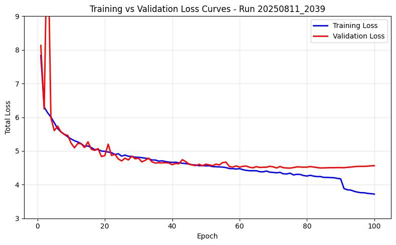

```python
%matplotlib inline
plot_total_loss(str(results_path / 'results.csv'), ylim=(3, 9))
```

#### 3.3.4 Alternative processing, 1:1 imbalance, hard-clip (pre-, hvrt + mosaic)

Create the data .yaml configuration file (overwrites previous .yaml file with the same name):

```python
# Create data configuration
import yaml

data_config = {
    'path':   str(PROJECT_ROOT / 'data'),
    'train':  'train_hvrt_bal_alt_clip3372',
    'val':    'val_alt_clip3372',
    'test':   '',
    'nc': 2,
    'names': ['is_vessel', 'is_fishing']
}

# Save to configs directory
yaml_path = CONFIG_DIR / 'sar_data_aug_alt.yaml'
with open(yaml_path, 'w') as f:
    yaml.dump(data_config, f)
```

```python
# Load the model
model = YOLO('yolov8n.pt')
```

```python
# Create a timestamp for the training run
timestamp = datetime.now().strftime('%Y%m%d_%H%M')

# Train the model
results = model.train(
    data=str(yaml_path),
    epochs=100,
    batch=16,
    imgsz=640,
    freeze=None,
    plots=True,
    project=RUNS_DIR / 'train_png_aug_alt',
    name=timestamp,

    # Optimization
    optimizer='SGD',      # explicit SGD
    lr0=0.01,             # initial learning rate
    lrf=0.01,             # final learning rate factor
    momentum=0.9,         # SGD momentum/Adam beta1
    weight_decay=0.0005,  # optimizer weight decay
    warmup_epochs=3.0,    # warmup epochs
    warmup_momentum=0.8,  # warmup momentum
    warmup_bias_lr=0.1,   # warmup bias lr


    # Augmentation parameters
    auto_augment=None,
    hsv_h=0.0,
    hsv_s=0.0,
    hsv_v=0.0,
    translate=0.1,  # transaltion (+/- fraction)
    degrees=15.0,   # rotation (+/- degrees)
    scale=0.0,
    fliplr=0.5,     # horizontal flip (prob.)
    flipud=0.5,     # vertical flip (prob.)
    mosaic=1.0      # image mosaic (prob.)
)
```

```
New https://pypi.org/project/ultralytics/8.3.178 available 😃 Update with 'pip install -U ultralytics'
Ultralytics 8.3.152 🚀 Python-3.10.12 torch-2.6.0+cu124 CUDA:0 (NVIDIA RTX 2000 Ada Generation Laptop GPU, 8188MiB)
engine/trainer: agnostic_nms=False, amp=True, augment=False, auto_augment=None, batch=16, bgr=0.0, box=7.5, cache=False, cfg=None, classes=None, close_mosaic=10, cls=0.5, conf=None, copy_paste=0.0, copy_paste_mode=flip, cos_lr=False, cutmix=0.0, data=/home/peterm/UWA/CITS5014/SARFish/modelling/confi…
Overriding model.yaml nc=80 with nc=2

                   from  n    params  module                                       arguments
  0                  -1  1       464  ultralytics.nn.modules.conv.Conv             [3, 16, 3, 2]
  1                  -1  1      4672  ultralytics.nn.modules.conv.Conv             [16, 32, 3, 2]
  2                  -1  1      7360  ultralytics.nn.modules.block.C2f             [32, 32, 1, True]
  3                  -1  1     18560  ultralytics.nn.modules.conv.Conv             [32, 64, 3, 2]
  4                  -1  2     49664  ultralytics.nn.modules.block.C2f             [64, 64, 2, True]
  5                  -1  1     73984  ultralytics.nn.modules.conv.Conv             [64, 128, 3, 2]
  6                  -1  2    197632  ultralytics.nn.modules.block.C2f             [128, 128, 2, True]
  7                  -1  1    295424  ultralytics.nn.modules.conv.Conv             [128, 256, 3, 2]
  8                  -1  1    460288  ultralytics.nn.modules.block.C2f             [256, 256, 1, True]
  9                  -1  1    164608  ultralytics.nn.modules.block.SPPF            [256, 256, 5]
 10                  -1  1         0  torch.nn.modules.upsampling.Upsample         [None, 2, 'nearest']
 11             [-1, 6]  1         0  ultralytics.nn.modules.conv.Concat           [1]
 12                  -1  1    148224  ultralytics.nn.modules.block.C2f             [384, 128, 1]
 13                  -1  1         0  torch.nn.modules.upsampling.Upsample         [None, 2, 'nearest']
 14             [-1, 4]  1         0  ultralytics.nn.modules.conv.Concat           [1]
 15                  -1  1     37248  ultralytics.nn.modules.block.C2f             [192, 64, 1]
 16                  -1  1     36992  ultralytics.nn.modules.conv.Conv             [64, 64, 3, 2]
 17            [-1, 12]  1         0  ultralytics.nn.modules.conv.Concat           [1]
 18                  -1  1    123648  ultralytics.nn.modules.block.C2f             [192, 128, 1]
 19                  -1  1    147712  ultralytics.nn.modules.conv.Conv             [128, 128, 3, 2]
 20             [-1, 9]  1         0  ultralytics.nn.modules.conv.Concat           [1]
 21                  -1  1    493056  ultralytics.nn.modules.block.C2f             [384, 256, 1]
 22        [15, 18, 21]  1    751702  ultralytics.nn.modules.head.Detect           [2, [64, 128, 256]]
Model summary: 129 layers, 3,011,238 parameters, 3,011,222 gradients, 8.2 GFLOPs

Transferred 319/355 items from pretrained weights
TensorBoard: Start with 'tensorboard --logdir /home/peterm/UWA/CITS5014/SARFish/modelling/runs/train_png_aug_alt/20250813_2224', view at http://localhost:6006/
Freezing layer 'model.22.dfl.conv.weight'
AMP: running Automatic Mixed Precision (AMP) checks...
AMP: checks passed ✅
train: Fast image access ✅ (ping: 0.0±0.0 ms, read: 960.7±466.9 MB/s, size: 12.6 KB)
```

```
train: Scanning /home/peterm/UWA/CITS5014/SARFish/modelling/data/train_hvrt_bal_alt_clip3372/labels... 7559 images, 0 ba
```

```
train: New cache created: /home/peterm/UWA/CITS5014/SARFish/modelling/data/train_hvrt_bal_alt_clip3372/labels.cache
albumentations: Blur(p=0.01, blur_limit=(3, 7)), MedianBlur(p=0.01, blur_limit=(3, 7)), ToGray(p=0.01, method='weighted_average', num_output_channels=3), CLAHE(p=0.01, clip_limit=(1.0, 4.0), tile_grid_size=(8, 8))
val: Fast image access ✅ (ping: 0.0±0.0 ms, read: 1004.1±448.9 MB/s, size: 12.8 KB)
```

```
val: Scanning /home/peterm/UWA/CITS5014/SARFish/modelling/data/val_alt_clip3372/labels... 463 images, 0 backgrounds, 0 c
```

```
val: New cache created: /home/peterm/UWA/CITS5014/SARFish/modelling/data/val_alt_clip3372/labels.cache
```

```
Plotting labels to /home/peterm/UWA/CITS5014/SARFish/modelling/runs/train_png_aug_alt/20250813_2224/labels.jpg...
optimizer: SGD(lr=0.01, momentum=0.9) with parameter groups 57 weight(decay=0.0), 64 weight(decay=0.0005), 63 bias(decay=0.0)
TensorBoard: model graph visualization added ✅
Image sizes 640 train, 640 val
Using 8 dataloader workers
Logging results to /home/peterm/UWA/CITS5014/SARFish/modelling/runs/train_png_aug_alt/20250813_2224
Starting training for 100 epochs...

      Epoch    GPU_mem   box_loss   cls_loss   dfl_loss  Instances       Size
```

```
      1/100      1.97G      2.268       3.31       2.16         11        640: 100%|██████████| 473/473 [01:27<00:00,  5
                 Class     Images  Instances      Box(P          R      mAP50  mAP50-95): 100%|██████████| 15/15 [00:04<
```

```
                   all        463        463       0.22       0.28      0.135     0.0332

      Epoch    GPU_mem   box_loss   cls_loss   dfl_loss  Instances       Size
```

```
      2/100      2.29G      2.074      2.317      1.941          8        640: 100%|██████████| 473/473 [02:22<00:00,  3
                 Class     Images  Instances      Box(P          R      mAP50  mAP50-95): 100%|██████████| 15/15 [00:05<
```

```
                   all        463        463      0.357      0.466      0.328      0.113
```

```
      Epoch    GPU_mem   box_loss   cls_loss   dfl_loss  Instances       Size
```

```
      3/100      2.29G      2.065      2.171      1.886         10        640: 100%|██████████| 473/473 [02:38<00:00,  2
                 Class     Images  Instances      Box(P          R      mAP50  mAP50-95): 100%|██████████| 15/15 [00:06<
```

```
                   all        463        463      0.285       0.34      0.224      0.071
```

```
      Epoch    GPU_mem   box_loss   cls_loss   dfl_loss  Instances       Size
```

```
      4/100       2.3G      2.028      2.113       1.89         12        640: 100%|██████████| 473/473 [02:38<00:00,  2
                 Class     Images  Instances      Box(P          R      mAP50  mAP50-95): 100%|██████████| 15/15 [00:06<
```

```
                   all        463        463      0.239      0.287      0.181      0.061
```

```
      Epoch    GPU_mem   box_loss   cls_loss   dfl_loss  Instances       Size
```

```
      5/100      2.32G      1.987       2.03      1.852          9        640: 100%|██████████| 473/473 [02:38<00:00,  2
                 Class     Images  Instances      Box(P          R      mAP50  mAP50-95): 100%|██████████| 15/15 [00:06<
```

```
                   all        463        463      0.423      0.437      0.399      0.147
```

```
      Epoch    GPU_mem   box_loss   cls_loss   dfl_loss  Instances       Size
```

```
      6/100      2.33G      1.938      1.954      1.811         10        640: 100%|██████████| 473/473 [02:39<00:00,  2
                 Class     Images  Instances      Box(P          R      mAP50  mAP50-95): 100%|██████████| 15/15 [00:06<
```

```
                   all        463        463      0.288      0.262      0.198     0.0723
```

```
      Epoch    GPU_mem   box_loss   cls_loss   dfl_loss  Instances       Size
```

```
      7/100      2.34G      1.909      1.891      1.789          7        640: 100%|██████████| 473/473 [02:38<00:00,  2
                 Class     Images  Instances      Box(P          R      mAP50  mAP50-95): 100%|██████████| 15/15 [00:05<
```

```
                   all        463        463      0.411      0.505      0.411      0.168
```

```
      Epoch    GPU_mem   box_loss   cls_loss   dfl_loss  Instances       Size
```

```
      8/100      2.34G      1.886      1.884      1.773          9        640: 100%|██████████| 473/473 [02:38<00:00,  2
                 Class     Images  Instances      Box(P          R      mAP50  mAP50-95): 100%|██████████| 15/15 [00:06<
```

```
                   all        463        463      0.284      0.475      0.352      0.138
```

```
      Epoch    GPU_mem   box_loss   cls_loss   dfl_loss  Instances       Size
```

```
      9/100      2.36G      1.857      1.834      1.761          9        640: 100%|██████████| 473/473 [02:38<00:00,  2
                 Class     Images  Instances      Box(P          R      mAP50  mAP50-95): 100%|██████████| 15/15 [00:06<
```

```
                   all        463        463      0.361      0.612      0.416      0.174
```

```
      Epoch    GPU_mem   box_loss   cls_loss   dfl_loss  Instances       Size
```

```
     10/100      2.38G      1.842       1.82      1.739          9        640: 100%|██████████| 473/473 [02:38<00:00,  2
                 Class     Images  Instances      Box(P          R      mAP50  mAP50-95): 100%|██████████| 15/15 [00:05<
```

```
                   all        463        463      0.101     0.0809     0.0323     0.0109
```

```
      Epoch    GPU_mem   box_loss   cls_loss   dfl_loss  Instances       Size
```

```
     11/100      2.39G      1.827      1.797      1.732         11        640: 100%|██████████| 473/473 [02:38<00:00,  2
                 Class     Images  Instances      Box(P          R      mAP50  mAP50-95): 100%|██████████| 15/15 [00:06<
```

```
                   all        463        463      0.297       0.56      0.386      0.153
```

```
      Epoch    GPU_mem   box_loss   cls_loss   dfl_loss  Instances       Size
```

```
     12/100      2.39G      1.805      1.772      1.709          8        640: 100%|██████████| 473/473 [02:38<00:00,  2
                 Class     Images  Instances      Box(P          R      mAP50  mAP50-95): 100%|██████████| 15/15 [00:06<
```

```
                   all        463        463       0.38      0.626       0.48      0.209
```

```
      Epoch    GPU_mem   box_loss   cls_loss   dfl_loss  Instances       Size
```

```
     13/100      2.41G      1.794      1.763      1.697          9        640: 100%|██████████| 473/473 [02:38<00:00,  2
                 Class     Images  Instances      Box(P          R      mAP50  mAP50-95): 100%|██████████| 15/15 [00:06<
```

```
                   all        463        463      0.356      0.604      0.458      0.192
```

```
      Epoch    GPU_mem   box_loss   cls_loss   dfl_loss  Instances       Size
```

```
     14/100      2.42G      1.751       1.74      1.669          9        640: 100%|██████████| 473/473 [02:38<00:00,  2
                 Class     Images  Instances      Box(P          R      mAP50  mAP50-95): 100%|██████████| 15/15 [00:06<
```

```
                   all        463        463      0.371      0.567      0.443      0.188
```

```
      Epoch    GPU_mem   box_loss   cls_loss   dfl_loss  Instances       Size
```

```
     15/100      2.43G      1.754      1.742      1.679          7        640: 100%|██████████| 473/473 [02:38<00:00,  2
                 Class     Images  Instances      Box(P          R      mAP50  mAP50-95): 100%|██████████| 15/15 [00:05<
```

```
                   all        463        463       0.36      0.656      0.471      0.194
```

```
      Epoch    GPU_mem   box_loss   cls_loss   dfl_loss  Instances       Size
```

```
     16/100      2.43G      1.745       1.72      1.677          9        640: 100%|██████████| 473/473 [02:38<00:00,  2
                 Class     Images  Instances      Box(P          R      mAP50  mAP50-95): 100%|██████████| 15/15 [00:06<
```

```
                   all        463        463      0.473      0.533      0.487      0.218
```

```
      Epoch    GPU_mem   box_loss   cls_loss   dfl_loss  Instances       Size
```

```
     17/100      2.46G      1.713      1.713      1.652         11        640: 100%|██████████| 473/473 [02:37<00:00,  2
                 Class     Images  Instances      Box(P          R      mAP50  mAP50-95): 100%|██████████| 15/15 [00:06<
```

```
                   all        463        463      0.391      0.552      0.437      0.191
```

```
      Epoch    GPU_mem   box_loss   cls_loss   dfl_loss  Instances       Size
```

```
     18/100      2.47G      1.718      1.695      1.661         12        640: 100%|██████████| 473/473 [02:38<00:00,  2
                 Class     Images  Instances      Box(P          R      mAP50  mAP50-95): 100%|██████████| 15/15 [00:05<
```

```
                   all        463        463      0.455      0.499      0.469        0.2
```

```
      Epoch    GPU_mem   box_loss   cls_loss   dfl_loss  Instances       Size
```

```
     19/100      2.48G      1.702       1.69      1.645          9        640: 100%|██████████| 473/473 [02:38<00:00,  2
                 Class     Images  Instances      Box(P          R      mAP50  mAP50-95): 100%|██████████| 15/15 [00:06<
```

```
                   all        463        463      0.455      0.602      0.483      0.212
```

```
      Epoch    GPU_mem   box_loss   cls_loss   dfl_loss  Instances       Size
```

```
     20/100      2.48G      1.689      1.693      1.646         12        640: 100%|██████████| 473/473 [02:38<00:00,  2
                 Class     Images  Instances      Box(P          R      mAP50  mAP50-95): 100%|██████████| 15/15 [00:06<
```

```
                   all        463        463      0.411       0.61      0.479      0.215
```

```
      Epoch    GPU_mem   box_loss   cls_loss   dfl_loss  Instances       Size
```

```
     21/100       2.5G      1.682      1.683      1.628          8        640: 100%|██████████| 473/473 [02:37<00:00,  3
                 Class     Images  Instances      Box(P          R      mAP50  mAP50-95): 100%|██████████| 15/15 [00:06<
```

```
                   all        463        463      0.433      0.553      0.476      0.203
```

```
      Epoch    GPU_mem   box_loss   cls_loss   dfl_loss  Instances       Size
```

```
     22/100      2.51G      1.679      1.665      1.625         11        640: 100%|██████████| 473/473 [02:37<00:00,  2
                 Class     Images  Instances      Box(P          R      mAP50  mAP50-95): 100%|██████████| 15/15 [00:06<
```

```
                   all        463        463      0.438       0.52      0.448      0.195
```

```
      Epoch    GPU_mem   box_loss   cls_loss   dfl_loss  Instances       Size
```

```
     23/100      2.52G      1.661      1.652      1.612          9        640: 100%|██████████| 473/473 [02:37<00:00,  3
                 Class     Images  Instances      Box(P          R      mAP50  mAP50-95): 100%|██████████| 15/15 [00:05<
```

```
                   all        463        463      0.462      0.541      0.477       0.21
```

```
      Epoch    GPU_mem   box_loss   cls_loss   dfl_loss  Instances       Size
```

```
     24/100      2.53G      1.657      1.656      1.613          9        640: 100%|██████████| 473/473 [02:37<00:00,  3
                 Class     Images  Instances      Box(P          R      mAP50  mAP50-95): 100%|██████████| 15/15 [00:06<
```

```
                   all        463        463      0.434      0.563      0.521      0.228
```

```
      Epoch    GPU_mem   box_loss   cls_loss   dfl_loss  Instances       Size
```

```
     25/100      2.54G      1.647       1.63      1.599          6        640: 100%|██████████| 473/473 [02:37<00:00,  3
                 Class     Images  Instances      Box(P          R      mAP50  mAP50-95): 100%|██████████| 15/15 [00:06<
```

```
                   all        463        463      0.415      0.632       0.51      0.235
```

```
      Epoch    GPU_mem   box_loss   cls_loss   dfl_loss  Instances       Size
```

```
     26/100      2.56G      1.647      1.637      1.606         11        640: 100%|██████████| 473/473 [02:37<00:00,  3
                 Class     Images  Instances      Box(P          R      mAP50  mAP50-95): 100%|██████████| 15/15 [00:05<
```

```
                   all        463        463      0.365      0.565      0.458      0.203
```

```
      Epoch    GPU_mem   box_loss   cls_loss   dfl_loss  Instances       Size
```

```
     27/100      2.57G      1.641      1.628      1.592         12        640: 100%|██████████| 473/473 [02:37<00:00,  3
                 Class     Images  Instances      Box(P          R      mAP50  mAP50-95): 100%|██████████| 15/15 [00:06<
```

```
                   all        463        463       0.43      0.623      0.517      0.233
```

```
      Epoch    GPU_mem   box_loss   cls_loss   dfl_loss  Instances       Size
```

```
     28/100      2.57G      1.639      1.627      1.591          9        640: 100%|██████████| 473/473 [02:37<00:00,  3
                 Class     Images  Instances      Box(P          R      mAP50  mAP50-95): 100%|██████████| 15/15 [00:06<
```

```
                   all        463        463      0.396      0.538      0.483       0.21
```

```
      Epoch    GPU_mem   box_loss   cls_loss   dfl_loss  Instances       Size
```

```
     29/100      2.59G       1.63      1.626      1.584          8        640: 100%|██████████| 473/473 [02:37<00:00,  3
                 Class     Images  Instances      Box(P          R      mAP50  mAP50-95): 100%|██████████| 15/15 [00:06<
```

```
                   all        463        463      0.449      0.557      0.518      0.242
```

```
      Epoch    GPU_mem   box_loss   cls_loss   dfl_loss  Instances       Size
```

```
     30/100       2.6G      1.626      1.626       1.58         11        640: 100%|██████████| 473/473 [02:37<00:00,  3
                 Class     Images  Instances      Box(P          R      mAP50  mAP50-95): 100%|██████████| 15/15 [00:06<
```

```
                   all        463        463      0.444      0.541      0.496      0.219
```

```
      Epoch    GPU_mem   box_loss   cls_loss   dfl_loss  Instances       Size
```

```
     31/100      2.62G      1.617      1.619      1.575          9        640: 100%|██████████| 473/473 [02:37<00:00,  3
                 Class     Images  Instances      Box(P          R      mAP50  mAP50-95): 100%|██████████| 15/15 [00:06<
```

```
                   all        463        463       0.52      0.585      0.545      0.254
```

```
      Epoch    GPU_mem   box_loss   cls_loss   dfl_loss  Instances       Size
```

```
     32/100      2.62G      1.619      1.618      1.575         13        640: 100%|██████████| 473/473 [02:37<00:00,  3
                 Class     Images  Instances      Box(P          R      mAP50  mAP50-95): 100%|██████████| 15/15 [00:06<
```

```
                   all        463        463      0.475      0.598      0.517      0.237
```

```
      Epoch    GPU_mem   box_loss   cls_loss   dfl_loss  Instances       Size
```

```
     33/100      2.64G      1.605      1.609      1.569         10        640: 100%|██████████| 473/473 [02:38<00:00,  2
                 Class     Images  Instances      Box(P          R      mAP50  mAP50-95): 100%|██████████| 15/15 [00:06<
```

```
                   all        463        463      0.442      0.599      0.515      0.233
```

```
      Epoch    GPU_mem   box_loss   cls_loss   dfl_loss  Instances       Size
```

```
     34/100      2.65G      1.587       1.59      1.566          8        640: 100%|██████████| 473/473 [02:37<00:00,  3
                 Class     Images  Instances      Box(P          R      mAP50  mAP50-95): 100%|██████████| 15/15 [00:05<
```

```
                   all        463        463      0.445      0.586      0.549      0.246
```

```
      Epoch    GPU_mem   box_loss   cls_loss   dfl_loss  Instances       Size
```

```
     35/100      2.66G      1.583      1.589      1.569         12        640: 100%|██████████| 473/473 [02:37<00:00,  3
                 Class     Images  Instances      Box(P          R      mAP50  mAP50-95): 100%|██████████| 15/15 [00:06<
```

```
                   all        463        463      0.507      0.522       0.55      0.262

      Epoch    GPU_mem   box_loss   cls_loss   dfl_loss  Instances       Size
```

```
     36/100      2.66G      1.576      1.582      1.556          9        640: 100%|██████████| 473/473 [02:37<00:00,  3
                 Class     Images  Instances      Box(P          R      mAP50  mAP50-95): 100%|██████████| 15/15 [00:06<
```

```
                   all        463        463      0.516      0.565      0.575      0.263
```

```
      Epoch    GPU_mem   box_loss   cls_loss   dfl_loss  Instances       Size
```

```
     37/100      2.68G      1.587      1.593      1.567          9        640: 100%|██████████| 473/473 [02:38<00:00,  2
                 Class     Images  Instances      Box(P          R      mAP50  mAP50-95): 100%|██████████| 15/15 [00:05<
```

```
                   all        463        463      0.502      0.586      0.546      0.254
```

```
      Epoch    GPU_mem   box_loss   cls_loss   dfl_loss  Instances       Size
```

```
     38/100       2.7G      1.574      1.581      1.561          8        640: 100%|██████████| 473/473 [02:38<00:00,  2
                 Class     Images  Instances      Box(P          R      mAP50  mAP50-95): 100%|██████████| 15/15 [00:06<
```

```
                   all        463        463      0.501      0.569       0.56       0.25
```

```
      Epoch    GPU_mem   box_loss   cls_loss   dfl_loss  Instances       Size
```

```
     39/100      2.71G      1.565      1.571      1.547         12        640: 100%|██████████| 473/473 [02:37<00:00,  3
                 Class     Images  Instances      Box(P          R      mAP50  mAP50-95): 100%|██████████| 15/15 [00:05<
```

```
                   all        463        463      0.521      0.567      0.559      0.258
```

```
      Epoch    GPU_mem   box_loss   cls_loss   dfl_loss  Instances       Size
```

```
     40/100      2.71G      1.566      1.572      1.551         10        640: 100%|██████████| 473/473 [02:37<00:00,  3
                 Class     Images  Instances      Box(P          R      mAP50  mAP50-95): 100%|██████████| 15/15 [00:06<
```

```
                   all        463        463       0.49      0.628      0.583      0.267
```

```
      Epoch    GPU_mem   box_loss   cls_loss   dfl_loss  Instances       Size
```

```
     41/100      2.73G      1.563      1.569      1.549         10        640: 100%|██████████| 473/473 [02:37<00:00,  3
                 Class     Images  Instances      Box(P          R      mAP50  mAP50-95): 100%|██████████| 15/15 [00:06<
```

```
                   all        463        463      0.492      0.594      0.562      0.252
```

```
      Epoch    GPU_mem   box_loss   cls_loss   dfl_loss  Instances       Size
```

```
     42/100      2.74G      1.559      1.559      1.541         10        640: 100%|██████████| 473/473 [02:37<00:00,  3
                 Class     Images  Instances      Box(P          R      mAP50  mAP50-95): 100%|██████████| 15/15 [00:05<
```

```
                   all        463        463      0.502      0.597      0.591      0.276
```

```
      Epoch    GPU_mem   box_loss   cls_loss   dfl_loss  Instances       Size
```

```
     43/100      2.75G      1.555      1.547      1.538         13        640: 100%|██████████| 473/473 [02:37<00:00,  3
                 Class     Images  Instances      Box(P          R      mAP50  mAP50-95): 100%|██████████| 15/15 [00:06<
```

```
                   all        463        463      0.481       0.58      0.564       0.26

      Epoch    GPU_mem   box_loss   cls_loss   dfl_loss  Instances       Size
```

```
     44/100      2.76G      1.551      1.553      1.535         11        640: 100%|██████████| 473/473 [02:37<00:00,  3
                 Class     Images  Instances      Box(P          R      mAP50  mAP50-95): 100%|██████████| 15/15 [00:06<
```

```
                   all        463        463      0.524      0.596       0.56      0.246
```

```
      Epoch    GPU_mem   box_loss   cls_loss   dfl_loss  Instances       Size
```

```
     45/100      2.78G      1.552      1.545      1.531         10        640: 100%|██████████| 473/473 [02:36<00:00,  3
                 Class     Images  Instances      Box(P          R      mAP50  mAP50-95): 100%|██████████| 15/15 [00:05<
```

```
                   all        463        463      0.519      0.573      0.568      0.266
```

```
      Epoch    GPU_mem   box_loss   cls_loss   dfl_loss  Instances       Size
```

```
     46/100      2.79G      1.529      1.548      1.526          8        640: 100%|██████████| 473/473 [02:37<00:00,  3
                 Class     Images  Instances      Box(P          R      mAP50  mAP50-95): 100%|██████████| 15/15 [00:06<
```

```
                   all        463        463      0.522      0.614      0.582       0.27
```

```
      Epoch    GPU_mem   box_loss   cls_loss   dfl_loss  Instances       Size
```

```
     47/100       2.8G      1.529      1.535      1.515          8        640: 100%|██████████| 473/473 [02:37<00:00,  3
                 Class     Images  Instances      Box(P          R      mAP50  mAP50-95): 100%|██████████| 15/15 [00:06<
```

```
                   all        463        463      0.523       0.62      0.586      0.269
```

```
      Epoch    GPU_mem   box_loss   cls_loss   dfl_loss  Instances       Size
```

```
     48/100       2.8G      1.529       1.53      1.519         10        640: 100%|██████████| 473/473 [02:36<00:00,  3
                 Class     Images  Instances      Box(P          R      mAP50  mAP50-95): 100%|██████████| 15/15 [00:05<
```

```
                   all        463        463      0.542      0.591      0.575      0.257
```

```
      Epoch    GPU_mem   box_loss   cls_loss   dfl_loss  Instances       Size
```

```
     49/100      2.82G      1.523      1.532      1.522          8        640: 100%|██████████| 473/473 [02:36<00:00,  3
                 Class     Images  Instances      Box(P          R      mAP50  mAP50-95): 100%|██████████| 15/15 [00:06<
```

```
                   all        463        463      0.513      0.582      0.553       0.26
```

```
      Epoch    GPU_mem   box_loss   cls_loss   dfl_loss  Instances       Size
```

```
     50/100      2.83G      1.517      1.537      1.515          9        640: 100%|██████████| 473/473 [01:46<00:00,  4
                 Class     Images  Instances      Box(P          R      mAP50  mAP50-95): 100%|██████████| 15/15 [00:06<
```

```
                   all        463        463      0.515      0.588      0.557       0.26
```

```
      Epoch    GPU_mem   box_loss   cls_loss   dfl_loss  Instances       Size
```

```
     51/100      2.84G      1.518       1.54      1.517          9        640: 100%|██████████| 473/473 [02:37<00:00,  3
                 Class     Images  Instances      Box(P          R      mAP50  mAP50-95): 100%|██████████| 15/15 [00:05<
```

```
                   all        463        463      0.499      0.614      0.576      0.274
```

```
      Epoch    GPU_mem   box_loss   cls_loss   dfl_loss  Instances       Size
```

```
     52/100      2.85G      1.511      1.532      1.504          9        640: 100%|██████████| 473/473 [02:37<00:00,  3
                 Class     Images  Instances      Box(P          R      mAP50  mAP50-95): 100%|██████████| 15/15 [00:05<
```

```
                   all        463        463      0.521      0.594      0.571      0.265
```

```
      Epoch    GPU_mem   box_loss   cls_loss   dfl_loss  Instances       Size
```

```
     53/100      2.87G      1.512      1.515      1.515         10        640: 100%|██████████| 473/473 [02:37<00:00,  3
                 Class     Images  Instances      Box(P          R      mAP50  mAP50-95): 100%|██████████| 15/15 [00:06<
```

```
                   all        463        463      0.566      0.584      0.599       0.28
```

```
      Epoch    GPU_mem   box_loss   cls_loss   dfl_loss  Instances       Size
```

```
     54/100      2.88G      1.513      1.515      1.515          9        640: 100%|██████████| 473/473 [02:37<00:00,  3
                 Class     Images  Instances      Box(P          R      mAP50  mAP50-95): 100%|██████████| 15/15 [00:06<
```

```
                   all        463        463      0.536      0.574      0.582      0.266
```

```
      Epoch    GPU_mem   box_loss   cls_loss   dfl_loss  Instances       Size
```

```
     55/100      2.89G      1.506      1.524      1.511          9        640: 100%|██████████| 473/473 [02:37<00:00,  3
                 Class     Images  Instances      Box(P          R      mAP50  mAP50-95): 100%|██████████| 15/15 [00:05<
```

```
                   all        463        463      0.544      0.575      0.578       0.27
```

```
      Epoch    GPU_mem   box_loss   cls_loss   dfl_loss  Instances       Size
```

```
     56/100      2.89G      1.491      1.514      1.503         11        640: 100%|██████████| 473/473 [01:37<00:00,  4
                 Class     Images  Instances      Box(P          R      mAP50  mAP50-95): 100%|██████████| 15/15 [00:05<
```

```
                   all        463        463      0.533      0.628      0.603      0.277
```

```
      Epoch    GPU_mem   box_loss   cls_loss   dfl_loss  Instances       Size
```

```
     57/100      2.91G      1.483      1.499      1.494          9        640: 100%|██████████| 473/473 [02:37<00:00,  3
                 Class     Images  Instances      Box(P          R      mAP50  mAP50-95): 100%|██████████| 15/15 [00:06<
```

```
                   all        463        463      0.527      0.601      0.585      0.271
```

```
      Epoch    GPU_mem   box_loss   cls_loss   dfl_loss  Instances       Size
```

```
     58/100      2.92G      1.484      1.498      1.492          8        640: 100%|██████████| 473/473 [02:37<00:00,  3
                 Class     Images  Instances      Box(P          R      mAP50  mAP50-95): 100%|██████████| 15/15 [00:06<
```

```
                   all        463        463      0.516      0.616      0.597      0.282
```

```
      Epoch    GPU_mem   box_loss   cls_loss   dfl_loss  Instances       Size
```

```
     59/100      2.94G      1.482      1.494      1.494          9        640: 100%|██████████| 473/473 [02:36<00:00,  3
                 Class     Images  Instances      Box(P          R      mAP50  mAP50-95): 100%|██████████| 15/15 [00:05<
```

```
                   all        463        463      0.531      0.581      0.554      0.261
```

```
      Epoch    GPU_mem   box_loss   cls_loss   dfl_loss  Instances       Size
```

```
     60/100      2.94G      1.485      1.499      1.493          9        640: 100%|██████████| 473/473 [01:40<00:00,  4
                 Class     Images  Instances      Box(P          R      mAP50  mAP50-95): 100%|██████████| 15/15 [00:05<
```

```
                   all        463        463      0.522      0.599      0.571      0.268
```

```
      Epoch    GPU_mem   box_loss   cls_loss   dfl_loss  Instances       Size
```

```
     61/100      2.96G      1.486      1.486       1.49          9        640: 100%|██████████| 473/473 [02:37<00:00,  3
                 Class     Images  Instances      Box(P          R      mAP50  mAP50-95): 100%|██████████| 15/15 [00:06<
```

```
                   all        463        463      0.522      0.626       0.58      0.271

      Epoch    GPU_mem   box_loss   cls_loss   dfl_loss  Instances       Size
```

```
     62/100      2.97G      1.464      1.478      1.486          9        640: 100%|██████████| 473/473 [02:37<00:00,  3
                 Class     Images  Instances      Box(P          R      mAP50  mAP50-95): 100%|██████████| 15/15 [00:05<
```

```
                   all        463        463      0.552      0.622      0.588      0.273
```

```
      Epoch    GPU_mem   box_loss   cls_loss   dfl_loss  Instances       Size
```

```
     63/100      2.98G      1.465       1.47      1.488          8        640: 100%|██████████| 473/473 [01:37<00:00,  4
                 Class     Images  Instances      Box(P          R      mAP50  mAP50-95): 100%|██████████| 15/15 [00:06<
```

```
                   all        463        463      0.547      0.594      0.581      0.279
```

```
      Epoch    GPU_mem   box_loss   cls_loss   dfl_loss  Instances       Size
```

```
     64/100      2.98G      1.459      1.474      1.484          8        640: 100%|██████████| 473/473 [02:37<00:00,  3
                 Class     Images  Instances      Box(P          R      mAP50  mAP50-95): 100%|██████████| 15/15 [00:05<
```

```
                   all        463        463      0.562      0.595      0.586      0.275
```

```
      Epoch    GPU_mem   box_loss   cls_loss   dfl_loss  Instances       Size
```

```
     65/100         3G      1.467      1.475       1.49         10        640: 100%|██████████| 473/473 [02:36<00:00,  3
                 Class     Images  Instances      Box(P          R      mAP50  mAP50-95): 100%|██████████| 15/15 [00:05<
```

```
                   all        463        463      0.537      0.602      0.591      0.273
```

```
      Epoch    GPU_mem   box_loss   cls_loss   dfl_loss  Instances       Size
```

```
     66/100      3.02G      1.458      1.457      1.478         12        640: 100%|██████████| 473/473 [01:41<00:00,  4
                 Class     Images  Instances      Box(P          R      mAP50  mAP50-95): 100%|██████████| 15/15 [00:06<
```

```
                   all        463        463      0.548      0.616      0.595      0.278
```

```
      Epoch    GPU_mem   box_loss   cls_loss   dfl_loss  Instances       Size
```

```
     67/100      3.03G      1.444      1.476      1.473         11        640: 100%|██████████| 473/473 [02:37<00:00,  3
                 Class     Images  Instances      Box(P          R      mAP50  mAP50-95): 100%|██████████| 15/15 [00:06<
```

```
                   all        463        463      0.527      0.639      0.583      0.272
```

```
      Epoch    GPU_mem   box_loss   cls_loss   dfl_loss  Instances       Size
```

```
     68/100      3.03G      1.465      1.464      1.484         11        640: 100%|██████████| 473/473 [02:37<00:00,  3
                 Class     Images  Instances      Box(P          R      mAP50  mAP50-95): 100%|██████████| 15/15 [00:05<
```

```
                   all        463        463      0.564       0.62       0.57      0.265
```

```
      Epoch    GPU_mem   box_loss   cls_loss   dfl_loss  Instances       Size
```

```
     69/100      3.05G      1.446      1.463      1.465          9        640: 100%|██████████| 473/473 [01:39<00:00,  4
                 Class     Images  Instances      Box(P          R      mAP50  mAP50-95): 100%|██████████| 15/15 [00:06<
```

```
                   all        463        463      0.557      0.608      0.578       0.27
```

```
      Epoch    GPU_mem   box_loss   cls_loss   dfl_loss  Instances       Size
```

```
     70/100      3.06G      1.446      1.456      1.472          7        640: 100%|██████████| 473/473 [02:37<00:00,  3
                 Class     Images  Instances      Box(P          R      mAP50  mAP50-95): 100%|██████████| 15/15 [00:06<
```

```
                   all        463        463      0.577      0.613       0.59      0.272
```

```
      Epoch    GPU_mem   box_loss   cls_loss   dfl_loss  Instances       Size
```

```
     71/100      3.07G      1.442      1.448      1.461          8        640: 100%|██████████| 473/473 [01:48<00:00,  4
                 Class     Images  Instances      Box(P          R      mAP50  mAP50-95): 100%|██████████| 15/15 [00:04<
```

```
                   all        463        463      0.551      0.613      0.609      0.284
```

```
      Epoch    GPU_mem   box_loss   cls_loss   dfl_loss  Instances       Size
```

```
     72/100      3.07G      1.441      1.453      1.471          9        640: 100%|██████████| 473/473 [02:16<00:00,  3
                 Class     Images  Instances      Box(P          R      mAP50  mAP50-95): 100%|██████████| 15/15 [00:06<
```

```
                   all        463        463      0.556      0.635      0.606      0.281
```

```
      Epoch    GPU_mem   box_loss   cls_loss   dfl_loss  Instances       Size
```

```
     73/100      3.09G       1.43      1.444       1.46          7        640: 100%|██████████| 473/473 [02:37<00:00,  3
                 Class     Images  Instances      Box(P          R      mAP50  mAP50-95): 100%|██████████| 15/15 [00:06<
```

```
                   all        463        463      0.538      0.621      0.591      0.274
```

```
      Epoch    GPU_mem   box_loss   cls_loss   dfl_loss  Instances       Size
```

```
     74/100      3.11G      1.426      1.432      1.454         11        640: 100%|██████████| 473/473 [01:28<00:00,  5
                 Class     Images  Instances      Box(P          R      mAP50  mAP50-95): 100%|██████████| 15/15 [00:06<
```

```
                   all        463        463      0.552      0.608      0.595      0.279
```

```
      Epoch    GPU_mem   box_loss   cls_loss   dfl_loss  Instances       Size
```

```
     75/100      3.12G      1.435      1.443      1.461         11        640: 100%|██████████| 473/473 [02:38<00:00,  2
                 Class     Images  Instances      Box(P          R      mAP50  mAP50-95): 100%|██████████| 15/15 [00:05<
```

```
                   all        463        463      0.519      0.648      0.605      0.284
```

```
      Epoch    GPU_mem   box_loss   cls_loss   dfl_loss  Instances       Size
```

```
     76/100      3.12G       1.42      1.416      1.451          9        640: 100%|██████████| 473/473 [02:37<00:00,  3
                 Class     Images  Instances      Box(P          R      mAP50  mAP50-95): 100%|██████████| 15/15 [00:05<
```

```
                   all        463        463      0.554      0.621      0.605      0.288
```

```
      Epoch    GPU_mem   box_loss   cls_loss   dfl_loss  Instances       Size
```

```
     77/100      3.14G      1.421      1.423      1.449         11        640: 100%|██████████| 473/473 [01:33<00:00,  5
                 Class     Images  Instances      Box(P          R      mAP50  mAP50-95): 100%|██████████| 15/15 [00:05<
```

```
                   all        463        463      0.567      0.628      0.597      0.281
```

```
      Epoch    GPU_mem   box_loss   cls_loss   dfl_loss  Instances       Size
```

```
     78/100      3.15G      1.418      1.416      1.449          8        640: 100%|██████████| 473/473 [02:37<00:00,  3
                 Class     Images  Instances      Box(P          R      mAP50  mAP50-95): 100%|██████████| 15/15 [00:06<
```

```
                   all        463        463      0.576      0.635      0.598      0.279
```

```
      Epoch    GPU_mem   box_loss   cls_loss   dfl_loss  Instances       Size
```

```
     79/100      3.16G      1.411      1.419      1.439         11        640: 100%|██████████| 473/473 [02:10<00:00,  3
                 Class     Images  Instances      Box(P          R      mAP50  mAP50-95): 100%|██████████| 15/15 [00:04<
```

```
                   all        463        463      0.568      0.636      0.598      0.278
```

```
      Epoch    GPU_mem   box_loss   cls_loss   dfl_loss  Instances       Size
```

```
     80/100      3.17G      1.409      1.409      1.442         10        640: 100%|██████████| 473/473 [01:55<00:00,  4
                 Class     Images  Instances      Box(P          R      mAP50  mAP50-95): 100%|██████████| 15/15 [00:06<
```

```
                   all        463        463      0.562      0.619      0.595      0.277
```

```
      Epoch    GPU_mem   box_loss   cls_loss   dfl_loss  Instances       Size
```

```
     81/100      3.19G      1.418      1.409      1.446         10        640: 100%|██████████| 473/473 [02:37<00:00,  3
                 Class     Images  Instances      Box(P          R      mAP50  mAP50-95): 100%|██████████| 15/15 [00:05<
```

```
                   all        463        463      0.576       0.62      0.594      0.278
```

```
      Epoch    GPU_mem   box_loss   cls_loss   dfl_loss  Instances       Size
```

```
     82/100       3.2G      1.401      1.401      1.442         12        640: 100%|██████████| 473/473 [01:39<00:00,  4
                 Class     Images  Instances      Box(P          R      mAP50  mAP50-95): 100%|██████████| 15/15 [00:06<
```

```
                   all        463        463      0.568      0.639      0.595      0.279
```

```
      Epoch    GPU_mem   box_loss   cls_loss   dfl_loss  Instances       Size
```

```
     83/100      3.21G      1.409      1.397      1.444          9        640: 100%|██████████| 473/473 [02:37<00:00,  3
                 Class     Images  Instances      Box(P          R      mAP50  mAP50-95): 100%|██████████| 15/15 [00:05<
```

```
                   all        463        463      0.567      0.638      0.603      0.282
```

```
      Epoch    GPU_mem   box_loss   cls_loss   dfl_loss  Instances       Size
```

```
     84/100      3.21G      1.398      1.398      1.435          8        640: 100%|██████████| 473/473 [01:38<00:00,  4
                 Class     Images  Instances      Box(P          R      mAP50  mAP50-95): 100%|██████████| 15/15 [00:05<
```

```
                   all        463        463      0.578      0.666      0.614      0.282
```

```
      Epoch    GPU_mem   box_loss   cls_loss   dfl_loss  Instances       Size
```

```
     85/100      3.23G      1.387      1.385      1.431          9        640: 100%|██████████| 473/473 [02:37<00:00,  3
                 Class     Images  Instances      Box(P          R      mAP50  mAP50-95): 100%|██████████| 15/15 [00:05<
```

```
                   all        463        463       0.57      0.658      0.611      0.285
```

```
      Epoch    GPU_mem   box_loss   cls_loss   dfl_loss  Instances       Size
```

```
     86/100      3.24G      1.394      1.379      1.436          9        640: 100%|██████████| 473/473 [01:30<00:00,  5
                 Class     Images  Instances      Box(P          R      mAP50  mAP50-95): 100%|██████████| 15/15 [00:06<
```

```
                   all        463        463      0.559      0.649      0.605      0.283
```

```
      Epoch    GPU_mem   box_loss   cls_loss   dfl_loss  Instances       Size
```

```
     87/100      3.25G      1.391      1.373      1.428         10        640: 100%|██████████| 473/473 [02:38<00:00,  2
                 Class     Images  Instances      Box(P          R      mAP50  mAP50-95): 100%|██████████| 15/15 [00:06<
```

```
                   all        463        463      0.576      0.634      0.604       0.28
```

```
      Epoch    GPU_mem   box_loss   cls_loss   dfl_loss  Instances       Size
```

```
     88/100      3.26G      1.384      1.378      1.429          9        640: 100%|██████████| 473/473 [01:35<00:00,  4
                 Class     Images  Instances      Box(P          R      mAP50  mAP50-95): 100%|██████████| 15/15 [00:06<
```

```
                   all        463        463       0.58      0.626      0.601       0.28
```

```
      Epoch    GPU_mem   box_loss   cls_loss   dfl_loss  Instances       Size
```

```
     89/100      3.28G      1.375      1.367      1.424         10        640: 100%|██████████| 473/473 [02:38<00:00,  2
                 Class     Images  Instances      Box(P          R      mAP50  mAP50-95): 100%|██████████| 15/15 [00:06<
```

```
                   all        463        463      0.566      0.642      0.596       0.28
```

```
      Epoch    GPU_mem   box_loss   cls_loss   dfl_loss  Instances       Size
```

```
     90/100      3.29G      1.375      1.361      1.423         10        640: 100%|██████████| 473/473 [01:30<00:00,  5
                 Class     Images  Instances      Box(P          R      mAP50  mAP50-95): 100%|██████████| 15/15 [00:06<
```

```
                   all        463        463      0.573      0.623      0.601       0.28
```

```
Closing dataloader mosaic
albumentations: Blur(p=0.01, blur_limit=(3, 7)), MedianBlur(p=0.01, blur_limit=(3, 7)), ToGray(p=0.01, method='weighted_average', num_output_channels=3), CLAHE(p=0.01, clip_limit=(1.0, 4.0), tile_grid_size=(8, 8))

      Epoch    GPU_mem   box_loss   cls_loss   dfl_loss  Instances       Size
```

```
     91/100       3.3G      1.321      1.171       1.36          7        640: 100%|██████████| 473/473 [02:38<00:00,  2
                 Class     Images  Instances      Box(P          R      mAP50  mAP50-95): 100%|██████████| 15/15 [00:05<
```

```
                   all        463        463      0.586      0.611      0.602      0.282
```

```
      Epoch    GPU_mem   box_loss   cls_loss   dfl_loss  Instances       Size
```

```
     92/100       3.3G        1.3       1.16      1.356          7        640: 100%|██████████| 473/473 [01:33<00:00,  5
                 Class     Images  Instances      Box(P          R      mAP50  mAP50-95): 100%|██████████| 15/15 [00:06<
```

```
                   all        463        463      0.593      0.587      0.599      0.281
```

```
      Epoch    GPU_mem   box_loss   cls_loss   dfl_loss  Instances       Size
```

```
     93/100      3.32G      1.301      1.152      1.354          7        640: 100%|██████████| 473/473 [02:37<00:00,  3
                 Class     Images  Instances      Box(P          R      mAP50  mAP50-95): 100%|██████████| 15/15 [00:06<
```

```
                   all        463        463      0.594      0.584      0.597      0.279
```

```
      Epoch    GPU_mem   box_loss   cls_loss   dfl_loss  Instances       Size
```

```
     94/100      3.33G      1.289      1.141      1.346          7        640: 100%|██████████| 473/473 [01:40<00:00,  4
                 Class     Images  Instances      Box(P          R      mAP50  mAP50-95): 100%|██████████| 15/15 [00:05<
```

```
                   all        463        463      0.587      0.602      0.597      0.281
```

```
      Epoch    GPU_mem   box_loss   cls_loss   dfl_loss  Instances       Size
```

```
     95/100      3.35G      1.278       1.13      1.338          7        640: 100%|██████████| 473/473 [02:18<00:00,  3
                 Class     Images  Instances      Box(P          R      mAP50  mAP50-95): 100%|██████████| 15/15 [00:04<
```

```
                   all        463        463      0.579      0.607      0.588      0.277
```

```
      Epoch    GPU_mem   box_loss   cls_loss   dfl_loss  Instances       Size
```

```
     96/100      3.35G       1.28      1.125      1.338          7        640: 100%|██████████| 473/473 [01:54<00:00,  4
                 Class     Images  Instances      Box(P          R      mAP50  mAP50-95): 100%|██████████| 15/15 [00:06<
```

```
                   all        463        463      0.591      0.597      0.588      0.276
```

```
      Epoch    GPU_mem   box_loss   cls_loss   dfl_loss  Instances       Size
```

```
     97/100      3.37G      1.275      1.123      1.335          7        640: 100%|██████████| 473/473 [02:36<00:00,  3
                 Class     Images  Instances      Box(P          R      mAP50  mAP50-95): 100%|██████████| 15/15 [00:06<
```

```
                   all        463        463      0.603      0.595       0.59      0.275
```

```
      Epoch    GPU_mem   box_loss   cls_loss   dfl_loss  Instances       Size
```

```
     98/100      3.38G      1.267      1.109      1.331          7        640: 100%|██████████| 473/473 [01:34<00:00,  4
                 Class     Images  Instances      Box(P          R      mAP50  mAP50-95): 100%|██████████| 15/15 [00:05<
```

```
                   all        463        463      0.601      0.585      0.588      0.276
```

```
      Epoch    GPU_mem   box_loss   cls_loss   dfl_loss  Instances       Size
```

```
     99/100      3.39G      1.265      1.102      1.329          7        640: 100%|██████████| 473/473 [02:37<00:00,  3
                 Class     Images  Instances      Box(P          R      mAP50  mAP50-95): 100%|██████████| 15/15 [00:05<
```

```
                   all        463        463        0.6      0.591      0.589      0.277
```

```
      Epoch    GPU_mem   box_loss   cls_loss   dfl_loss  Instances       Size
```

```
    100/100       3.4G      1.257      1.099      1.322          7        640: 100%|██████████| 473/473 [01:32<00:00,  5
                 Class     Images  Instances      Box(P          R      mAP50  mAP50-95): 100%|██████████| 15/15 [00:06<
```

```
                   all        463        463      0.593      0.599      0.585      0.275
```

```
100 epochs completed in 4.188 hours.
Optimizer stripped from /home/peterm/UWA/CITS5014/SARFish/modelling/runs/train_png_aug_alt/20250813_2224/weights/last.pt, 6.3MB
Optimizer stripped from /home/peterm/UWA/CITS5014/SARFish/modelling/runs/train_png_aug_alt/20250813_2224/weights/best.pt, 6.3MB

Validating /home/peterm/UWA/CITS5014/SARFish/modelling/runs/train_png_aug_alt/20250813_2224/weights/best.pt...
Ultralytics 8.3.152 🚀 Python-3.10.12 torch-2.6.0+cu124 CUDA:0 (NVIDIA RTX 2000 Ada Generation Laptop GPU, 8188MiB)
Model summary (fused): 72 layers, 3,006,038 parameters, 0 gradients, 8.1 GFLOPs
```

```
                 Class     Images  Instances      Box(P          R      mAP50  mAP50-95): 100%|██████████| 15/15 [00:06<
```

```
                   all        463        463      0.559      0.618      0.606      0.287
             is_vessel        331        331      0.685      0.623      0.747       0.38
            is_fishing        132        132      0.433      0.612      0.464      0.195
Speed: 0.5ms preprocess, 5.6ms inference, 0.0ms loss, 2.7ms postprocess per image
Results saved to /home/peterm/UWA/CITS5014/SARFish/modelling/runs/train_png_aug_alt/20250813_2224
```

Plot total loss curves:

```python
results_path = RUNS_DIR / 'train_png_aug_alt' / '20250813_2224'
```

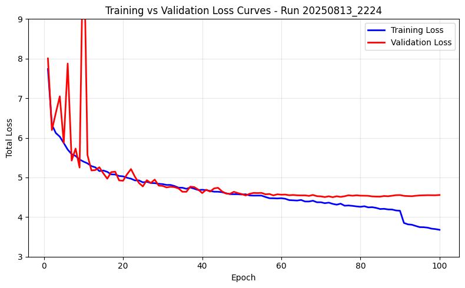

```python
%matplotlib inline
plot_total_loss(str(results_path / 'results.csv'), ylim=(3, 9))
```